# 前言

# Preface

……面对一个无限的主题，很难说得有限，而所有主题都是无限的。

… it is hard to be finite upon an infinite subject, and all subjects are infinite.

——赫尔曼·梅尔维尔（1850），第 1170 页

—Herman Melville (1850), p. 1170

我们所熟知的数学与科学，在很大程度上都是试图用有限的心智把握无限的结果。德国数学家理查德·戴德金早在 1854 年就表达过这一点（见 Ewald（1996），第 755—756 页）：

Mathematics and science as we know them are very much the result of trying to grasp infinity with our finite minds. The German mathematician Richard Dedekind said as much in 1854 (see Ewald (1996), pp. 755–756):

……科学是人的作品，因此受制于人的任意性，以及心智能力的一切不完善。对于一个拥有无限理解力的人，科学实质上就不再存在：我们通过漫长推理链条才获得的最终结论，对他而言会是立即显明的真理。

…as the work of man, science is subject to his arbitrariness and to all the imperfections of his mental powers. There would essentially be no more science for a man gifted with an unbounded understanding—a man for whom the final conclusions, which we attain through a long chain of inferences, would be immediately evident truths.

戴德金的话反映了 19 世纪数学对无限日益增强的认识。当时，对无限过程的推理，即微积分，已成为科学与工程不可或缺的工具。他写下这段话时，一个新时代正在到来：无限与逻辑首次被当作数学概念来研究。这带来了一系列进展，其中有些出自戴德金本人，使此前有关这些主题的全部知识几乎显得幼稚而简单。

Dedekind’s words reflect the growing awareness of infinity in 19th-century mathematics, as reasoning about infinite processes (calculus) became an indispensable tool of science and engineering. He wrote at the dawn of an era in which infinity and logic were viewed as mathematical concepts for the first time. This led to advances (some of them due to Dedekind himself) that made all previous knowledge of these topics seem almost childishly simple.

19 世纪 70 年代格奥尔格·康托尔的集合论，以及 20 世纪 30 年代库尔特·哥德尔的不完备性定理，推动了人们对无限的认识。介绍这些进展的通俗著作已有很多。然而，这些书通常只着眼于集合论或逻辑的某一方面。我认为，康托尔与哥德尔的成果构成一个浑然一体的整体，这一点尚未得到充分阐明。本书旨在解释这个整体：集合论与逻辑相互作用，两者又开始影响主流数学。后一点是相当晚近的发展，在通俗叙述中尚未得到多少篇幅。

Many popular books have been written on the advances in our understanding of infinity sparked by the set theory of Georg Cantor in the 1870s, and incompleteness theorems of Kurt Gödel in the 1930s. However, such books generally dwell on a single aspect of either set theory or logic. I believe it has not been made clear that the results of Cantor and Gödel form a seamless whole. The aim of this book is to explain the whole, in which set theory *interacts* with logic, and both begin to affect mainstream mathematics (the latter quite a recent development, not yet given much space in popular accounts).

特别是，我花了一些心思讲述逻辑史上两位受到忽视的人物：埃米尔·波斯特与格哈德·根岑。波斯特比哥德尔更早发现不完备性，只是后来才发表证明。然而，他的证明比哥德尔的证明更清楚地揭示了不完备性在康托尔集合论中的起源，以及它与计算理论的联系。根据哥德尔的定理，数论的一致性依赖数论之外的某个假设；根岑找到了这样的最小假设，它源于康托尔的序数理论，从而为深入理解数论和组合数学中的不可证明性铺平了道路。

In particular, I have taken some pains to tell the story of two neglected figures in the history of logic, Emil Post and Gerhard Gentzen. Post discovered incompleteness before Gödel, though he did not publish his proof until later. However, his proof makes clear (more so than Gödel’s did) the origin of incompleteness in Cantor’s set theory and its connections with the theory of computation. Gentzen, in the light of Gödel’s theorem that the consistency of number theory depends on an assumption from outside number theory, found the *minimum* such assumption—one that grows out of Cantor’s theory of ordinal numbers—paving the way for new insights into unprovability in number theory and combinatorics.

本书可视为我的《渴望不可能》的续篇。那本书的主要观点是，数学的许多部分要求我们接受某种形式的无限。本书探讨接受无限所带来的丰富而惊人的后果。无限有许多层次，可以上升到几乎难以置信的高度；然而，即使最高的层次，也会对有限对象，例如自然数 1、2、3、……产生“可观察”的影响。因此，无限可能比理论物理的某些部分更贴近现实！与这一主张相应，本书几乎不要求高中数学以外的知识，只要求读者愿意努力理解陌生的思想。如果符号逻辑的记号实在过于陌生，也可以跳过记号密集的部分，仍然把握故事的主旨。

This book can be viewed as a sequel to my *Yearning for the Impossible,* the main message of which was that many parts of mathematics demand that we accept some form of infinity. The present book explores the consequences of accepting infinity, which are rich and surprising. There are many levels of infinity, ascending to heights that almost defy belief, yet even the highest levels have “observable” effects at the level of finite objects, such as the natural numbers 1, 2, 3, …. Thus, infinity may be more down-to-earth than certain parts of theoretical physics! In keeping with this claim, I have assumed very little beyond high school mathematics, except a willingness to grapple with alien ideas. If the notation of symbolic logic proves *too* alien, it is possible to skip the notation-heavy parts and still get the gist of the story.

为了让读者逐步进入集合论与逻辑的技术细节，我尝试在每章追踪一条线索：从一个自然的数学问题出发，依次介绍历史上对它的回应。每种回应通常又引出新问题，新的概念和定理由此产生。每章结尾有一节较长的“历史背景”，尝试把这条线索放进数学及其历史的更大图景中。我的用意是先近距离呈现关键思想，再用更宽广的视野重访并巩固它们。但这并非唯一的阅读方式。有些读者可能急于了解核心定理，至少初读时会跳过历史背景。另一些读者希望从一开始就掌握全貌，可以先读历史背景，再回来补充细节。

I have tried to ease the reader into the technicalities of set theory and logic by tracing a single thread in each chapter, beginning with a natural mathematical question and following a sequence of historic responses to it. Each response typically leads to new questions, and from them new concepts and theorems emerge. At the end of the chapter there is a longish section called “Historical Background,” which attempts to situate the thread in a bigger picture of mathematics and its history. My intention is to present key ideas in closeup first, then to revisit and reinforce them by showing a wider view. But this is not the only way to read the book. Some readers may be impatient to get to the core theorems, and will skip the historical background sections, at least at first reading. Others, in search of a big picture from the beginning, may begin by reading the historical background and then come back to fill in details.

从 20 世纪 60 年代起，这本书就一直在我的潜意识中酝酿。当时我先在墨尔本大学读本科，后在麻省理工学院读研究生。集合论与逻辑是我在数学中最热爱的领域，但我花了很长时间才看清它们的全貌。老师们的投入这么晚才得到回报，我向他们致歉！我尤其感谢墨尔本大学的布鲁斯·克雷文，支持我对他专业以外领域的兴趣；也感谢麻省理工学院的老师小哈特利·罗杰斯与杰拉尔德·萨克斯，拓宽了我在逻辑与集合论方面的视野。

The book has been developing in my unconscious since the 1960s, when I was an undergraduate at the University of Melbourne and a graduate student at MIT. Set theory and logic were then my passions in mathematics, but it took a long time for me to see them in perspective—I apologize to my teachers for the late return on their investment! I particularly want to thank Bruce Craven of Melbourne for indulging my interest in a field outside his specialty, and my MIT teachers Hartley Rogers Jr. and Gerald Sacks for widening my horizons in logic and set theory.

近些年来，我要感谢杰里米·阿维加德帮助我了解最新进展，以及卡梅伦·弗里尔对本书早期草稿极为详尽的批评。约翰·道森也提出了非常有益的意见。如仍有错误，完全由我负责。写作和研究期间，旧金山大学与莫纳什大学提供了宝贵的支持与设施。

In recent times I have to thank Jeremy Avigad for bringing me up to date, and Cameron Freer for a very detailed criticism of an earlier draft of this book. John Dawson also made very helpful comments. If errors remain, they are entirely my fault. The University of San Francisco and Monash University provided valuable support and facilities while I was writing and researching.

我还要感谢朋友阿贝·谢尼策多年来帮助校对，以及儿子迈克尔和罗伯特分担这项繁重工作。最后，一如既往地感谢妻子伊莱恩。

I also want to thank my friend Abe Shenitzer for his perennial help with proofreading, and my sons Michael and Robert for sharing this onerous task. Finally, I thank my wife Elaine, as always.

约翰·斯蒂尔韦尔

John Stillwell

旧金山大学、莫纳什大学

University of San Francisco and Monash University

2010 年 3 月

March 2010

# 第 1 章 对角线论证

# - Chapter 1 - The Diagonal Argument

概览

Preview

无限是数学的命脉，因为即使最简单的数学对象，即正整数 1、2、3、4、5、6、7、……，也没有尽头。关于无限，最古老也最出色的论证之一，是欧几里得证明素数 2、3、5、7、11、13、……构成一个无限序列。尽管对这个序列几乎一无所知，欧几里得仍然成功了，因为他转而证明任何有限的素数序列都不完整。也就是说，他说明了如何找到一个素数 p，使它不同于任意给定的素数 p₁、p₂、……、pₙ。

Infinity is the lifeblood of mathematics, because there is no end to even the simplest mathematical objects—the positive integers 1, 2, 3, 4, 5, 6, 7, … . One of the oldest and best arguments about infinity is Euclid’s proof that the prime numbers 2, 3, 5, 7, 11, 13, … form an infinite sequence. Euclid succeeds despite knowing virtually nothing about the sequence, by showing instead that any *finite* sequence of primes is incomplete. That is, he shows how to find a prime *p* different from any given primes *p*<sub>1</sub>, *p*<sub>2</sub>, … , *p<sub>n</sub>*.

像素数这样的集合称为可数无限集，因为可以把其元素排成一个列表，有第一个元素、第二个元素、第三个元素，依此类推。正如欧几里得所证明的，这个列表是无限的，但每个元素都出现在某个有限的位置，因此都能被“数到”。

A set like the prime numbers is called *countably infinite* because we can order its members in a list with a first member, second member, third member, and so on. As Euclid showed, the list is infinite, but each member appears at some finite position, and hence gets “counted.”

可数无限集一直伴随着我们，而且除了计数，确实很难用其他方式把握无限。但在 1874 年，德国数学家格奥尔格·康托尔证明实数集不可数，表明无限比此前想象的更加复杂。他的方法令人联想到欧几里得的证明，却高出一个层次：他证明任何可数无限的实数列表都不完整。

Countably infinite sets have always been with us, and indeed it is hard to grasp infinity in any way other than by counting. But in 1874 the German mathematician Georg Cantor showed that infinity is more complicated than previously thought, by showing that the set of real numbers is *uncountable.* He did this in a way reminiscent of Euclid’s proof, but one level higher, by showing that any countably infinite list of real numbers is incomplete.

给定一个可数列表 x₁、x₂、x₃、……，康托尔的方法能找到一个与其中每个数都不同的实数 x。这种方法如今称为对角线论证，原因将在下文说明。对角线论证有几种变式，从逻辑上说，它是证明不可数集存在的最简单方法。它是书名中第一条“通向无限之路”，因此本章专门讨论它。第二条道路通过序数展开，也是康托尔发现的，将在第 2 章讨论。

Cantor’s method finds a real number *x* different from any on a given countable list *x*<sub>1</sub>, *x*<sub>2</sub>, *x*<sub>3</sub>, … by what is now called the *diagonal argument*, for reasons that will become clear below. The diagonal argument (which comes in several variations) is logically the simplest way to prove the existence of uncountable sets. It is the first “road to infinity” of our title, so we devote this chapter to it. A second road—via the *ordinals*—was also discovered by Cantor, and it will be discussed in Chapter 2.

## 1.1 计数与可数性

## 1.1 Counting and Countability

如果我进一步问有多少个平方数，人们可以如实回答：平方数与相应的平方根一样多，因为每个平方数都有自己的平方根，每个平方根都有自己的平方数，而且没有平方数有不止一个平方根，也没有平方根有不止一个平方数。

If I should ask further how many squares there are, one might reply truly that there are as many as the corresponding number of roots, since every square has its own root and every root has its own square, while no square has more than one root and no root more than one square.

——伽利略·伽利莱，

—Galileo Galilei,

《关于两门新科学的对话》，第一天。

*Dialogues Concerning the Two New Sciences*,First day.

数数 1、2、3、4、……是无限过程最简单、最清楚的例子。我们知道数数永远不会结束，因为不存在最后一个数。事实上，人们最初往往认为“无限”与“永不结束”意思相同。然而，在某种意义上，这个无休止的计数过程穷尽了正整数集 {1,2,3,4,……}，因为每个正整数最终都会被数到。这使正整数集区别于其他一些集合，例如直线上的点集，后者似乎无法“通过计数穷尽”。因此，不妨再多花一点时间思考计数过程，考察一些能够通过数其元素而穷尽的无限集。

The process of counting 1, 2, 3, 4, … is the simplest and clearest example of an *infinite process.* We know that counting never ends, because there is no last number, and indeed one’s first thought is that “infinite” and “neverending” mean the same thing. Yet, in a sense, the endless counting process *exhausts* the set {1,2,3,4, …} of positive integers, because each positive integer is eventually reached. This distinguishes the set of positive integers from other sets—such as the set of points on a line— which seemingly cannot be “exhausted by counting.” Thus it may be enlightening to dwell a little longer on the process of counting, and to survey some of the infinite sets that can be exhausted by counting their members.

首先，“数”一组对象是什么意思？对对象“计数”，等同于把它们排成一个可能无限的列表：第一个对象、第二个对象、第三个对象，依此类推，使给定集合中的每个对象都出现在列表上，当然是在某个正整数位置。例如，如果按递增顺序列出平方数来“数”它们，

First, what do we mean by “counting” a set of objects? “Counting” objects is the same as arranging them in a (possibly infinite) *list*—first object, second object, third object, and so on—so that each object in the given set appears on the list, necessarily at some positive integer position. For example, if we “count” the squares by listing them in increasing order,

$1,4,9,16,25,36,49,64,81,100,121,144,169,196,225, …$

那么平方数 900 就出现在列表的第 30 个位置。列出一个集合，在数学上等同于以某种方式给其元素分配正整数。不过，直观想象这个列表，往往比算出每个元素具体分配到哪个整数更容易。

then the square 900 appears at position 30 on the list. Listing a set is mathematically the same as assigning the positive integers in some way to its members, but it is often easier to visualize the list than to work out the exact integer assigned to each member.

因此，列出正偶数的过程，与列出正整数的过程完全平行。原因就在于两个列表逐项匹配，我们把这种匹配称为一一对应。函数 f(n)=2n 概括了这一对应，因为它把每个正整数 n 恰好配给一个正偶数 2n，而每个正偶数 2n 也恰好与一个正整数 n 配对。

Thus listing the positive even numbers is a process completely parallel to the process of listing the positive integers. The reason lies in the item-by-item matching of the two lists, which we call a *one-to-one correspondence.* The function *f* (*n*) = 2*n* encapsulates this correspondence, because it matches each positive integer *n* with exactly one positive even number 2*n*, and each positive even number 2*n* is matched with exactly one positive integer *n.*

因此，呼应本节开头引用的伽利略的例子：如果我问有多少个偶数，人们可以如实回答，偶数与相应的正整数一样多。在伽利略的例子以及我这个更简单的例子中，都可以看到正整数集与其一部分之间的一一对应。这种令人不安的性质，是无限集世界的第一个特征。

So, to echo the example of Galileo quoted at the beginning of this section: if I should ask how many even numbers there are, one might reply truly that there are as many as the corresponding positive integers. In both Galileo’s example, and my more simple-minded one, one sees a one-to-one correspondence between the set of positive integers and a part of itself. This unsettling property is the first characteristic of the world of infinite sets.

### 可数无限集

### Countably Infinite Sets

如果一个集合的元素能够排成一个无限列表，也就是说，能够与正整数建立一一对应，就称它为可数无限集。格奥尔格·康托尔在 19 世纪 70 年代开创了集合的一般研究，他把可数无限集的这种共同性质称为它们的基数。对于有限集，两个集合的基数相同，当且仅当它们的元素个数相同。因此，对有限集来说，基数概念实质上就是数的概念。

A set whose members can be put in an infinite list—that is, in one-to-one correspondence with the positive integers—is called *countably infinite.* This common property of countably infinite sets was called their *cardinality* by Georg Cantor, who initiated the general study of sets in the 1870s. In the case of finite sets, two sets have the same cardinality if and only if they have the same number of elements. So the concept of cardinality is essentially the *same* as the concept of number for finite sets.

对于可数无限集，共同的基数也可以看作元素的“个数”。康托尔把这个“数”称为超限数，记作 ℵ₀，读作“阿列夫零”。例如，可以说正整数有 ℵ₀ 个。不过，必须记住，ℵ₀ 比普通的数更有弹性。集合 {1,2,3,4,……} 和 {2,4,6,8,……} 的基数都是 ℵ₀，尽管后者是前者的真子集。因此，也可以说偶数有 ℵ₀ 个。

For countably infinite sets, the common cardinality can also be regarded as the “number” of elements. This “number” was called a *transfinite number* and denoted ℵ<sub>0</sub> (“aleph zero” or “aleph nought”) by Cantor. One can say, for instance, that there are ℵ<sub>0</sub> positive integers. However, one has to bear in mind that ℵ<sub>0</sub> is more elastic than an ordinary number. The sets {1, 2, 3, 4, …} and {2, 4, 6, 8, …} both have cardinality ℵ<sub>0</sub>,even though the second set is a strict subset of the first. So one can also say that there are ℵ<sub>0</sub> even numbers.

而且，基数 ℵ₀ 还可以伸展，涵盖乍看之下比集合 {1,2,3,4,……} 大得多的集合。考虑图 1.1 所示的点集。这个网格有无限多行，每行又有无限多个点，但我们仍然可以像图中那样，把每个点与一个不同的正整数配对。只需沿一系列有限的对角线观察这些点，从左下角开始，依次沿各条对角线“数”下去。

Moreover, the cardinality ℵ<sub>0</sub> stretches to cover sets that at first glance seem much larger than the set {1, 2, 3, 4, …}. Consider the set of dots shown in Figure 1.1. The grid has infinitely many infinite rows of dots, but nevertheless we can pair each dot with a different positive integer as shown in the figure. Simply view the dots along a series of finite diagonal lines, and “count” along the successive diagonals, starting in the bottom left corner.

用非常类似的方法，可以证明正分数组成的集合是可数的，因为每个分数 m/n 都对应一对正整数 (m,n)。由此可知，正有理数集是可数的，因为每个正有理数都可以用一个分数表示。诚然，同一个数有许多分数表示，例如数 1/2 也可以表示为 2/4、3/6、4/8 等等。但我们可以遍历分数列表，略去所有表示此前已出现过的数的分数，从而列出正有理数。

There is a very similar proof that the set of (positive) fractions is countable, since each fraction *m/n* corresponds to the pair (*m*, *n*) of positive integers. It follows that the set of positive rational numbers is countable, since each positive rational number is given by a fraction. Admittedly, there are many fractions for the same number—for example the number 1/2 is also given by the fractions 2/4, 3/6, 4/8, and so on—-but we can list the positive rational numbers by going through the list of fractions and omitting all fractions that represent previous numbers on the list.

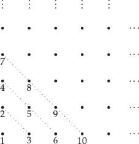

图 1.1 数无限网格中的点。

**Figure 1.1.** Counting the dots in an infinite grid.

## 1.2 一种无限大小能适用于所有集合吗？

## 1.2 Does One Infinite Size Fit All?

物理学家乔治·伽莫夫（1947）在《从一到无穷大》中，用一种巧妙的方法说明基数 ℵ₀ 的弹性。他设想了一家名为希尔伯特旅馆的旅馆，其中有无限多个房间，编号为 1、2、3、4、……。列出一个无限集的元素，就等同于把这些元素作为“客人”安排进希尔伯特旅馆，每个房间住一位。

A nice way to illustrate the elasticity of the cardinality ℵ<sub>0</sub> was introduced by the physicist George Gamow (1947) in his book *One, Two, Three, …, Infinity.* Gamow imagines a hotel, called *Hilbert’s hotel,in* which there are infinitely many rooms, numbered 1, 2, 3, 4, … . Listing the members of an infinite set is the same as accommodating the members as “guests” in Hilbert’s hotel, one to each room.

旅馆甚至还能容纳可数无限多个、每个又有可数无限多位客人的团体。比如，假设客人乘坐编号为 1、2、3、4、……的无限多辆巴士到达，而每辆巴士上的客人也编号为 1、2、3、4、……。第 1 辆巴士上的客人可以按如下方式安排：

There is even room for a countable infinity of countable infinities of guests. Suppose, say, that the guests arrive on infinite buses numbered 1, 2, 3, 4, …, and that each bus has guests numbered 1, 2, 3, 4 , … . The guests in bus 1 can be accommodated as follows:

$put guest 1 in room 1; then skip 1 room; that is, put guest 2 in room 3; then skip 2 rooms; that is, put guest 3 in room 6; then skip 3 rooms; that is, put guest 4 in room 10; then skip 4 rooms; ... .$

第 1 辆巴士的客人全部下车后，空房间分成若干组，各组分别有 1、2、3、4、……个房间。因此，可以让第 2 辆巴士的客人分别住进每组最左边的房间。之后，空房间又分成分别有 1、2、3、4、……个房间的各组，所以可以对第 3 辆巴士重复这个过程，依此类推。（你可能注意到，每辆巴士的客人所住的房间编号序列，都与图 1.1 中某一行的编号相同。）

After the first bus has been unloaded, the unoccupied rooms are in blocks of 1, 2,3,4, … rooms, so we can unload the second bus by putting its guests in the leftmost room of each block. After that, the unoccupied rooms are *again* in blocks of 1, 2, 3, 4, … rooms, so we can repeat the process with the third bus, and so on. (You may notice that each busload occupies a sequence of rooms numbered the same as a row in Figure 1.1.)

结果是，整整 ℵ₀ 辆巴士、每辆 ℵ₀ 位客人，都能住进希尔伯特旅馆，而且每个房间恰好住一位客人。用符号表示：ℵ₀×ℵ₀=ℵ₀。

The result is that the whole series of ℵ<sub>0</sub> busloads, each with ℵ<sub>0</sub> guests, can be packed into Hilbert’s hotel—with exactly one guest per room. In symbols: ℵ<sub>0</sub> × ℵ<sub>0</sub> = ℵ<sub>0</sub>.

刚才得到的“基数算术”等式，

The equations of “cardinal arithmetic” just obtained,

$ℵ0+1=ℵ0,ℵ0+ℵ0=ℵ0,ℵ0×ℵ0=ℵ0,$

说明了超限数 ℵ₀ 有多么大的弹性。它的弹性如此之大，以至于人们开始怀疑：基数算术是否除了说任何无限集的基数都是 ℵ₀ 以外，就再没有什么可说的了。如果所有超限数都相同，那么谈论它们当然是浪费时间。但幸运的是，它们并不全都相同。特别是，直线上的点集，其基数严格大于 ℵ₀。康托尔在 1874 年发现了这个差异，在无限的世界中打开一道裂缝；从那以后，出人意料的结果不断从中涌现。归根结底，关于无限有很多话可说，而本书的目的就是解释为什么。

show just how elastic the transfinite number ℵ<sub>0</sub> is. So much so, one begins to suspect that cardinal arithmetic has nothing to say except that any infinite set has cardinality ℵ<sub>0</sub>. And if all transfinite numbers are the same it is surely a waste of time to talk about them. But fortunately they are *not* all the same. In particular, the set of points on the line has cardinality strictly *larger* than ℵ<sub>0</sub>. Cantor discovered this difference in 1874, opening a crack in the world of the infinite from which unexpected consequences have spilled ever since. There is, after all, a lot to say about infinity, and the purpose of this book is to explain why.

## 1.3 康托尔的对角线论证

## 1.3 Cantor’s Diagonal Argument

在研究直线上的点集之前，我们先考察一个相关但稍易处理的集合：所有正整数集合组成的集合。正整数集合 S 可以用一个由 0 和 1 组成的无限序列描述：当且仅当 n 是 S 的元素时，第 n 位为 1。表 1.1 给出几个例子：

Before studying the set of points on the line, we look at a related set that is slightly easier to handle: the set of all sets of positive integers. A set *S* of positive integers can be described by an infinite sequence of 0s and 1s, with 1 in the *n*th place just in case *n* is a member of *S.* Table 1.1 shows a few examples:

表 1.1 正整数集合的描述。 Table 1.1 Descriptions of positive integer sets.

| 子集 subset | 1 | 2 | 3 | 4 | 5 | 6 | 7 | 8 | 9 | 10 | 11 | … |
| --- | --- | --- | --- | --- | --- | --- | --- | --- | --- | --- | --- | --- |
| 偶数 even numbers | 0 | 1 | 0 | 1 | 0 | 1 | 0 | 1 | 0 | 1 | 0 | … |
| 平方数 squares | 1 | 0 | 0 | 1 | 0 | 0 | 0 | 0 | 1 | 0 | 0 | … |
| 素数 primes | 0 | 1 | 1 | 0 | 1 | 0 | 1 | 0 | 0 | 0 | 1 | … |

现在假设我们有 ℵ₀ 个正整数集合。这意味着可以把这些集合列成一个列表 S₁、S₂、S₃、……，其中第 n 项 Sₙ 是与整数 n 配对的集合。我们将描述一个与 S₁、S₂、S₃、……中的每个集合都不同的集合 S，从而证明这样的列表永远不可能包含所有正整数集合。

Now suppose that we have ℵ<sub>0</sub> sets of positive integers. That means we can form a list of the sets, *S*<sub>1</sub>, *S*<sub>2</sub>, *S*<sub>3</sub>,… , whose *n*th member *S<sub>n</sub>* is the set paired with integer *n.* We show that such a list can never include *all* sets of positive integers by describing a set *S* different from each of *S*<sub>1</sub>, *S*<sub>2</sub>, *S*<sub>3</sub>,….

这很容易：对于每个数 n，当且仅当 n 不属于 Sₙ 时，把 n 放进 S。于是，S 与每个 Sₙ 在数 n 上的归属情况都不同：如果 n 属于 Sₙ，那么 n 不属于 S；如果 n 不属于 Sₙ，那么 n 属于 S。因此，S 不在列表 S₁、S₂、S₃、……中，所以任何这样的列表都不可能包含所有正整数集合。

This is easy: for each number *n*, put *n* in *S* just in case *n* is *not* in *S<sub>n</sub>*. It follows that *S differs from each S<sub>n</sub> with respect to the number n: if n is S<sub>n</sub>, then n is not in S;if n is not S<sub>n</sub>, then n is in S.* Thus *S* is not on the list *S*<sub>1</sub>, *S*<sub>2</sub>, *S*3, … , and hence no such list can include all sets of positive integers.

表 1.2 对角线论证。 Table 1.2 The diagonal argument.

| 子集 subset | 1 | 2 | 3 | 4 | 5 | 6 | 7 | 8 | 9 | 10 | 11 | … |
| --- | --- | --- | --- | --- | --- | --- | --- | --- | --- | --- | --- | --- |
| *S*<sub>1</sub> | **0** | 1 | 0 | 1 | 0 | 1 | 0 | 1 | 0 | 1 | 0 | … |
| *S*<sub>2</sub> | 1 | **0** | 0 | 1 | 0 | 0 | 0 | 0 | 1 | 0 | 0 | … |
| *S*<sub>3</sub> | 0 | 1 | **1** | 0 | 1 | 0 | 1 | 0 | 0 | 0 | 1 | … |
| *S*<sub>4</sub> | 1 | 0 | 1 | **0** | 1 | 0 | 1 | 0 | 1 | 0 | 1 | … |
| *S*<sub>5</sub> | 0 | 0 | 1 | 0 | **0** | 1 | 0 | 0 | 1 | 0 | 0 | … |
| *S*<sub>6</sub> | 1 | 1 | 0 | 1 | 1 | **0** | 1 | 1 | 0 | 1 | 1 | … |
| *S*<sub>7</sub> | 1 | 1 | 1 | 1 | 1 | 1 | **1** | 1 | 1 | 1 | 1 | … |
| *S*<sub>8</sub> | 0 | 0 | 0 | 0 | 0 | 0 | 0 | **0** | 0 | 0 | 0 | … |
| *S*<sub>9</sub> | 0 | 0 | 0 | 0 | 0 | 0 | 0 | 0 | **1** | 0 | 0 | … |
| *S*<sub>10</sub> | 1 | 0 | 0 | 1 | 0 | 0 | 1 | 0 | 0 | **1** | 0 | … |
| *S*<sub>11</sub> | 0 | 1 | 0 | 0 | 1 | 0 | 0 | 1 | 0 | 0 | **0** | … |
| ⁝ |  |  |  |  |  |  |  |  |  |  |  | … |
| S | **1** | **1** | **0** | **1** | **1** | **1** | **0** | **1** | **0** | **0** | **1** | … |

刚才的论证称为对角线论证，因为可以把它直观地呈现如下。设想一个无限表格，其中每一行都像上面的例子一样，把集合 S₁、S₂、S₃、……编码为 0 和 1 的序列。例如，我们可能得到表 1.2 中的那些集合。

The argument we have just made is called a *diagonal* argument because it can be presented visually as follows. Imagine an infinite table whose rows encode the sets *S*<sub>1</sub>, *S*<sub>2</sub>, *S*<sub>3</sub>,… as sequences of 0s and 1s, as in the examples above. We might have, say, the sets shown in Table 1.2.

表示 n 是否属于 Sₙ 的数字 1 或 0 用粗体标出，构成一个由粗体数字组成的对角线序列：

The digit (1 or 0) that signals whether or not *n* belongs to *S<sub>n</sub>* is set in bold type, giving a diagonal sequence of bold digits

$00100010110…$

把对角线序列中的每个数字反转，就得到 S 的序列。因此，S 的序列必然与 S₁、S₂、S₃、……中所有集合的序列都不同。

The sequence for *S* is obtained by switching each digit in the diagonal sequence. Hence the sequence for *S* is necessarily different from the sequences for all of *S*<sub>1</sub>, *S*<sub>2</sub>, *S*<sub>3</sub>,….

所有 0、1 序列组成的集合，其基数记作 $2ℵ0$。采用这个符号，是因为序列的第一位有两种可能，第二位有两种可能，第三位有两种可能，依此类推，序列的全部 ℵ₀ 位都是如此。因此，可以合理地说，0、1 序列共有 2×2×2×⋯ 种可能，其中有 ℵ₀ 个因子，所以正自然数的子集共有 $2ℵ0$ 个。

The cardinality of the set of all sequences of 0s and 1s is called $2ℵ0$. We use this symbol because there are two possibilities for the first digit in the sequence, two possibilities for the second digit, two possibilities for the third, and so on, for all the ℵ<sub>0</sub> digits in the sequence. Thus it is reasonable to say that there are 2 × 2 × 2 × ⋯ (ℵ<sub>0</sub> factors) possible sequences of 0s and 1s, and hence there are $2ℵ0$ sets of positive natural numbers.

对角线论证表明，$2ℵ0$ 严格大于 $ℵ0$，因为正整数可以与某些正整数集合建立一一对应，却不能与所有这样的集合建立一一对应。正如刚才所见，如果把数 1、2、3、4、……分配给集合 S₁、S₂、S₃、S₄、……，总会有某个集合，例如 S，没有被分配到数。

*The diagonal argument shows that* $2ℵ0$ *is strictly greater than* $ℵ0$ because there is a one-to-one correspondence between the positive integers and certain sets of positive integers, but not with *all* such sets. As we have just seen, if the numbers 1, 2, 3, 4,… are assigned to sets *S*<sub>1</sub>, *S*<sub>2</sub>, *S*<sub>3</sub>, *S*<sub>4</sub>,… there will always be a set (such as *S*) that fails to be assigned a number.

### 对角线论证的逻辑

### The Logic of the Diagonal Argument

许多数学家强烈主张，这个证明的有效性毫无疑问；另一些人却不承认它。就我个人而言，我丝毫看不出这个证明的说服力……如果这的确是一个证明，那么我的头脑无法完成它显然要求我完成的那些事情。

Many mathematicians aggressively maintain that there can be no doubt of the validity of this proof, whereas others do not admit it. I personally cannot see an iota of appeal in this proof … my mind will not do the things that it is obviously expected to do if this is indeed a proof.

——P. W. 布里奇曼（1955），第 101 页

—P .W. Bridgman (1955), p. 101

P. W. 布里奇曼是哈佛大学的实验物理学家，1946 年诺贝尔物理学奖得主。他也很可能是不理解对角线论证的人中最聪明者之一。如果你对上面的论证感到困难，尽可放心：一位诺贝尔奖得主也同样困惑。不过，我认为，有数学经验的读者不应难以理解对角线论证。原因如下。

P. W. Bridgman was an experimental physicist at Harvard, and winner of the Nobel prize for physics in 1946. He was also, in all probability, one of the smartest people *not* to understand the diagonal argument. If you had any trouble with the argument above, you can rest assured that a Nobel prize winner was equally troubled. On the other hand, I do not think that any mathematically experienced reader *should* have trouble with the diagonal argument. Here is why.

对角线论证的逻辑，实际上与欧几里得证明素数有无限多个的逻辑非常相似。欧几里得面临的困难是：素数没有明显规律，因此素数的全体难以把握。于是，他干脆不去考虑素数的全体，转而论证任何有限的素数列表都不完整。

The logic of the diagonal argument is really very similar to that of Euclid’s proof that there are infinitely many primes. Euclid faced the difficulty that the totality of primes is hard to comprehend, since they follow no apparent pattern. So, he avoided even considering the totality of primes by arguing instead that *any finite list of primes is incomplete.*

给定一个有限的素数列表 p₁、p₂、……、pₙ，构造数

Given a finite list of primes *p*<sub>1</sub>, *p*<sub>2</sub>,…, *p<sub>n</sub>*, one forms the number

$N=p1p2⋯pn+1,$

显然，它不能被 p₁、p₂、……、pₙ 中任何一个整除，因为分别相除时余数都是 1。但 N 总能被某个素数整除，因此素数列表 p₁、p₂、……、pₙ 不完整。而且，通过找出能整除 N 的最小的不小于 2 的数，我们还能找到一个不在列表中的具体素数 p。

which is obviously not divisible by any one of *p*<sub>1</sub>, *p*<sub>2</sub>,…*,p<sub>n</sub>* (they each leave remainder 1). But *N* is divisible by *some* prime number, so the list *p*<sub>1</sub>, *p*<sub>2</sub>,…, *p<sub>n</sub>* of primes is incomplete. Moreover, we can find a specific prime *p* not on the list by finding the smallest number ≥ 2 that divides *N.*

同样，不可数集也非常难以把握，所以我们避免直接这样做，而是假设给定了这个集合中元素的一个可数列表 S₁、S₂、S₃、……。“给定”一词可以按你希望的严格程度解释。例如，如果 S₁、S₂、S₃、……是 0、1 序列，你可以要求有一条规则，在第 m+n 阶段给出 Sₙ 的第 m 位。对角线论证仍然有效，并且给出一个完全确定、不在给定列表中的 S。（事实上，它还会引出关于计算序列的规则的一些有趣结论，见第 3 章。）

An uncountable set is likewise very hard to comprehend, so we avoid doing so and instead suppose that we are given a countable list *S*<sub>1</sub>, *S*<sub>2</sub>, *S*<sub>3</sub>, … of members of the set. The word “given” may be interpreted as strictly as you like. For example, if *S*<sub>1</sub>, *S*<sub>2</sub>, *S*<sub>3</sub>, … are sequences of 0s and 1s, you may demand a *rule* that gives the mth digit of *S<sub>n</sub>* at stage *m + n.* The diagonal argument still works, and it gives a *completely specific S* not on the given list. (Indeed, it also leads to some interesting conclusions about rules for computing sequences, as we will see in Chapter 3.)

### 直线上的点集

### The Set of Points on the Line

集合论的目标，是回答一个极为重要的问题：能否以原子式的方式，把直线看作一个点的集合。

The goal of set theory is to answer the question of highest importance: whether one can view the line in an atomistic manner, as a set of points.

——尼古拉·卢津（1930），第 2 页。

—Nikolai Luzin (1930), p. 2.

这里的“直线”是指数轴，其“点”称为实数。每个实数都有一个十进制展开，小数点后是无限的十进制数字序列。例如，

By the “line” we mean the number line, whose “points” are known as the *real numbers.* Each real number has a *decimal expansion* with an infinite sequence of decimal digits after the decimal point. For example,

$π=3.14159265358979323846.…$

如果只考虑 0 与 1 之间的实数，那么每个数都由小数点后的数字序列给出，其中每一项都是 0、1、2、3、4、5、6、7、8 或 9。因此，0 与 1 之间可数无限多个实数 x₁、x₂、x₃、x₄、……，可以用一个表格编码，它与我们用来编码可数无限多个正整数集合的表格十分相似。同样，对于每个正整数 n，只要使 x 的第 n 位不同于 xₙ 的第 n 位，就可以构造一个与 x₁、x₂、x₃、x₄、……中每个数都不同的实数 x。和前面一样，这相当于查看表格对角线上的数字，并逐一改变它们。

If we stick to real numbers between 0 and 1, then each number is given by the sequence of digits after the decimal point, each term of which is one of 0, 1, 2, 3, 4, 5, 6, 7, 8, or 9. A countable infinity of real numbers *x*<sub>1</sub>, *x*<sub>2</sub>, *x*<sub>3</sub>, *x*<sub>4</sub>,… between 0 and 1 can therefore be encoded by a table very like the table we used to encode a countable infinity of sets of positive integers. Likewise, we can construct a real number *x different* from each of *x*<sub>1</sub>, *x*<sub>2</sub>, *x*<sub>3</sub>, *x*<sub>4</sub>,… by arranging that the nth digit of *x* is different from the *n*th digit of *x<sub>n</sub>*, for each positive integer *n.* As before, this amounts to looking at the diagonal digits in the table, and changing each one of them.

然而，这次的对角线构造有一个小问题。改变对角线上的每个数字，确实会产生一个与 x₁、x₂、x₃、x₄、……的所有给定序列都不同的数字序列。但这并不能保证新序列表示一个新的数。例如，对角线构造得到的序列可能是

However, there is now a slight problem with the diagonal construction. Changing each diagonal digit certainly produces a sequence of digits different from all the sequences given for *x*<sub>1</sub>, *x*<sub>2</sub>, *x*<sub>3</sub>, *x*<sub>4</sub>,… . But this does not ensure that the new sequence represents a new number. It could happen, for example, that the sequence obtained by the diagonal construction is

$0⋅49999999999999 …$

而给定的某个序列是

and that one of the given sequences is

$x1=0⋅50000000000000 …$

这两个序列不同，却表示同一个数，即 1/2。两个序列只有在其中一个以无限多个 9 结尾时，才可能表示同一个数。因此，只要在改变对角线数字时，永远不把它改成 0 或 9，就能避免这个问题。例如，可以采用下面的规则。

These are different sequences, but they represent the same number, namely 1/2. Since two sequences can represent the same number only if one of them ends in an infinite sequence of 9s, we can avoid this problem by never changing a diagonal digit to a 0 or a 9. For example, we could use the following rule.

如果 xₙ 的第 n 位是 1，就令 x 的第 n 位为 2。

If the *n*th digit of *x<sub>n</sub>* is 1, let the *n*th digit of *x* be 2.

如果 xₙ 的第 n 位不是 1，就令 x 的第 n 位为 1。

If the *n*th digit of *x<sub>n</sub>* is not 1, let the *n*th digit of *x* be 1.

按照这条规则，x 不仅在数字序列上与 x₁、x₂、x₃、……不同，而且作为一个数，也与 x₁、x₂、x₃、……不同。因此，我们证明了实数集的基数大于正自然数集的基数。如果列出一个实数列表 x₁、x₂、x₃、x₄、……，总会有某个实数，例如 x，不在列表中。

With this rule, *x* does not merely have a sequence of digits different from those for *x*<sub>1</sub>, *x*<sub>2</sub>, *x*<sub>3</sub>,… . *As a number, x* is different from *x*<sub>1</sub>, *x*<sub>2</sub>, *x*<sub>3</sub>,… . Thus we have proved that *the set of real numbers is of greater cardinality than the set of positive natural numbers.* If we make a list of real numbers *x*<sub>1</sub>, *x*<sub>2</sub>, *x*<sub>3</sub>, *x*<sub>4</sub>, … there will always be a real number (such as *x)* not on the list.

事实上，实数集，无论是 0 与 1 之间的实数集，还是整条数轴上的实数集，其基数都是 $2ℵ0$，与所有 0、1 序列组成的集合的基数相同。基数 $2N0$ 与 ℵ₀ 一样，可以度量数学中熟悉的集合的“大小”。随着我们进一步考察可数集与不可数集的例子，其中的原因会更加清楚。

In fact, the set of real numbers (whether between 0 and 1 or over the whole number line) has cardinality $2ℵ0$—the same as that of the set of sequences of 0s and 1s. The cardinality $2N0$, like ℵ<sub>0</sub>, measures the “size” among familiar sets in mathematics. The reasons for this will become clearer as we explore further examples of countable and uncountable sets.

## 1.4 超越数

## 1.4 Transcendental Numbers

［关于实数能否与自然数一一对应的问题］……如果答案是否定的，就会得到刘维尔定理，即超越数存在性定理的一个新证明。

[On the question whether the real numbers can be made to correspond with the natural numbers]…if it could be answered with no, then one would have a new proof of Liouville’s theorem that there are transcendental numbers.

——格奥尔格·康托尔，1873 年 12 月 2 日致戴德金的信，见 Ewald（1996），第 844 页。

—Georg Cantor, Letter to Dedekind, 2 December 1873, in Ewald (1996), p. 844.

康托尔于 1874 年发现不可数集，是数学史上最出人意料的事件之一。在此之前，多数人甚至不认为无限是合法的数学概念，更不可能设想有必要区分可数与不可数两种无限。不可数性的思想过于新颖，多数数学家无法欣赏。因此，康托尔发表这一发现时淡化了不可数性，只通过“代数数的一个性质”间接引入它。

Cantor’s discovery of uncountable sets in 1874 was one of the most unexpected events in the history of mathematics. Before 1874, infinity was not even considered a legitimate mathematical concept by most people, so the need to distinguish between countable and uncountable infinities could not have been imagined. The idea of uncountability was just *too* original to be appreciated by most mathematicians. Because of this, Cantor downplayed the idea of uncountability in the published version of his discovery, introducing it only indirectly via a “property of the algebraic numbers.”

19 世纪数学家非常熟悉代数数。如果数 x 满足一个整系数多项式方程，也就是形如下式的方程，就称它为代数数：

The algebraic numbers were very familiar to 19th-century mathematicians. A number *x* is called *algebraic* if it satisfies a polynomial equation with integer coefficients, that is, an equation of the form

$anxn+an−1xn−1+⋯+a1x+a0=0, where a0,a1,…,an−1,an are integers.$

代数数包括所有有理数 m/n，其中 m、n 为整数，也包括许多无理数，例如 $2,$、$3,$、$23$ 等。实际上，要找出不是代数数的数相当困难。法国数学家约瑟夫·刘维尔于 1844 年找到了第一个例子。他使用的结果大意是：无理代数数不能被有理数过分精确地逼近。

刘维尔随后考虑数

Liouville then considered the number

$x=0⋅101001000000100000000000000000000000010…,$

其中连续各段 0 的长度依次为 1、2、3×2、4×3×2、……。他证明 x 是无理数，却能被有理数非常精确地逼近，因此 x 不是代数数。这类数如今称为超越数，因为它们超出了代数方法的描述范围。描述它们总要使用无限过程，例如无限小数或无穷级数。第一个被证明是超越数的“著名”常数是

where the successive blocks of 0s have lengths 1, 2, 3 × 2, 4 × 3 × 2, … . He showed that *x* is irrational but that it *can* be closely approximated by rationals, hence *x* is not algebraic. Such numbers are now called *transcendental*, because they transcend description by algebraic means. Invariably, they have to be described by infinite processes, such as infinite decimals or infinite series. The first “well-known” number to be proved transcendental was

$e=1+11+11×2+11×2×3+11×2×3×4+⋯,$

刘维尔的同胞夏尔·埃尔米特于 1873 年运用颇为困难的微积分证明 e 是超越数。这项工作令他筋疲力尽，以至于放弃了证明 π 是超越数的打算。德国数学家费迪南德·林德曼于 1882 年首次证明 π 的超越性，所用的是埃尔米特的方法以及上面联系 e 与 π 的等式。

Liouville’s compatriot Charles Hermite proved that *e* is transcendental in 1873, using some difficult calculus. In fact, Hermite was so exhausted by the effort that he gave up the idea of trying to prove that *π* is transcendental. The transcendance of *π* was first proved by the German mathematician Ferdinand Lindemann in 1882, using Hermite’s methods and the above equation connecting *e* and *π.*

总之，1874 年已知的超越数研究方法只有刘维尔与埃尔米特的方法，都需要高深的代数与微积分。康托尔却完全不用高等数学，仅仅证明代数数集可数，就证明了超越数存在，令世人惊讶。结合实数不可数的结果，可知有些实数是超越数。事实上，“大多数”实数必然是超越数。集合论不仅轻易找到了超越数，还表明此前已知的寥寥几个超越数，实际上属于一个庞大而不可数的多数群体。

At any rate, in 1874 the only known approaches to transcendental numbers were those of Liouville and Hermite, using sophisticated algebra and calculus. Cantor surprised the world by showing the existence of transcendental numbers without any advanced math at all—simply by proving that *the set of algebraic numbers is countable.* Combining this with his result that real numbers are uncountable, it follows that some real numbers are transcendental. In fact, “most” real numbers must be transcendental. Not only does set theory find transcendental numbers easily, it also shows that the handful of transcendental numbers previously known actually belong to the vast, uncountable, majority.

我们已经看过康托尔证明实数不可数的一种方法，现在只需解释代数数为何只有可数多个。为此，回到定义代数数的方程：

Since we have already seen one of Cantor’s proofs that there are uncountably many reals, it remains to explain why there are only countably many algebraic numbers. To do this we come back to the equations that define algebraic numbers:

$anxn+an−1xn−1+⋯+a1x+a0=0,$ (1)

其中 a₀、a₁、……、aₙ₋₁、aₙ 都是整数。初等代数告诉我们，方程（1）至多有 n 个解。因此，只要能列出所有形如（1）的方程，就能列出所有代数数。康托尔为此采用了一个称为方程“高度”的量，

where *a*<sub>0</sub>, *a*<sub>1</sub>,…,*a<sub>n</sub>*<sub>−1</sub>,*a<sub>n</sub>* are integers. The equation (1) has at most *n* solutions, as one learns in elementary algebra, so we can list all algebraic numbers if we can list all equations of the form (1). To do this, Cantor used a quantity called the *height* of the equation,

$h=| an |+| an−1 |+⋯+| a0 |+n,$

这是同事理查德·戴德金建议的。不难看出，给定高度 h 的方程只有有限多个，因为它们的次数 n≤h，每个系数的绝对值也都小于 h。因此，可以先列出高度为 1 的方程，再列高度为 2、3 等的方程，从而列出所有方程，也就列出了所有代数数。

suggested by his colleague Richard Dedekind. It is not hard to see that *there are only finitely many equations with a given height h*, since they necessarily have degree *n ≤ h* and each coefficient has absolute value less than h. Therefore, we can list all equations (and hence all algebraic numbers) by first listing the equations of height 1, then those of height 2, those of height 3, and so on.

这个列举过程说明代数数构成可数集，证明完毕。

This listing process shows that the algebraic numbers form a countable set, and hence we are done.

## 1.5 其他不可数性证明

## 1.5 Other Uncountability Proofs

我们没有介绍康托尔 1874 年的第一个不可数性证明，因为它比 1891 年的对角线证明更复杂。1874 年证明的逻辑基本相同：可数的数集不包含所有数，因为总能找到一个在它之外的数。但构造这个“局外者”x 的方法，并不明显具有“对角线”形式。x 是某个递增数列 x₁、x₂、x₃、x₄、……的最小上界，即大于这些数的最小数。然而，考察这些数的小数位时，最小上界也开始显得具有“对角线”性质。

We have not described Cantor’s first uncountability proof, from 1874, because it is more complicated than his diagonal proof, which dates from 1891. The logic of the 1874 proof is basically the same—a countable set of numbers does not include all numbers because we can always find a number outside it—but the construction of the outsider *x* is not obviously “diagonal.” Rather, *x* is a *least upper bound* of a certain increasing sequence of numbers *x*<sub>1</sub>, *x*<sub>2</sub>, *x*<sub>3</sub>, *x*<sub>4</sub>,that is, *x* is the least number greater than all of *x*<sub>1</sub>, *x*<sub>2</sub>, *x*<sub>3</sub>, *x*<sub>4</sub>, … . However, the least upper bound begins to look “diagonal” when one studies the decimal digits of *x*<sub>1</sub>, *x*<sub>2</sub>, *x*<sub>3</sub>, *x*<sub>4</sub>,… .

例如，假设 x₁、x₂、x₃、x₄、……具有如下小数展开：

Suppose, for the sake of example, that the numbers *x*<sub>1</sub>, *x*<sub>2</sub>, *x*<sub>3</sub>, *x*<sub>4</sub>,… have the following decimal digits:

$x1=1.413…x2=1.4141…x3=1.414232…x4=1.414235621…x5=1.4142356235…x6=1.4142356237… ⋮$

由于 x₁<x₂<x₃<⋯，每个小数 xᵢ₊₁ 都与前一个 xᵢ 在某一位之前相同，而在首次不同的位置，xᵢ₊₁ 的数字较大。这些首次不同的数字用粗体标出，构成一条“锯齿形对角线”。数列的最小上界 x，就是把截至这条“对角线”的所有小数片段合在一起：

Because *x*<sub>1</sub> *< x<sub>2</sub> < x<sub>3</sub> <* ⋯ , each decimal *x<sub>i</sub>*<sub>+1</sub> agrees with its predecessor *x<sub>i</sub>* up to a certain digit, and *x*<sub>i+1</sub> has a *larger* digit than *x<sub>i</sub>* at the first place where they disagree. These digits of first disagreement (shown in bold type) form a “jagged diagonal.” And the least upper bound *x* of the sequence *x*<sub>1</sub>, *x*<sub>2</sub>, *x*<sub>3</sub>, *x*<sub>4</sub>, … is obtained by uniting all the decimal segments up to this “diagonal”:

$x=1.4142356237…$

因此，在某种意义上，康托尔最初的不可数性证明也包含对角线构造。

Thus there is a sense in which Cantor’s original uncountability proof involves a diagonal construction.

德国数学家阿克塞尔·哈纳克于 1885 年利用测度概念发现的一个精彩证明，也具有这种性质。设 a₁、a₂、a₃、a₄、……是任意实数列表。哈纳克指出，可以用总长度任意小，例如 ε 的线段覆盖所有这些数。取长为 ε 的线段，分成两半，用长为 ε/2 的一半覆盖 a₁；再把余下的一半分成两半，用长为 ε/4 的线段覆盖 a₂，依此类推。这样就得到如下覆盖：

The same is true of a remarkable proof discovered by the German mathematician Axel Harnack in 1885, using the concept of *measure.* Suppose that *a*<sub>1</sub>, *a*<sub>2</sub>, *a*<sub>3</sub>, *a*<sub>4</sub>, … is any list of real numbers. Harnack observes that we can cover all of these numbers by line segments of total length as small as we please, say *ε*. Just take a line segment of length *ε*, break it in half, and use a segment of length *ε*/2 to cover the number *a*<sub>1</sub>.Then break the remaining segment of length *ε*/2 in half and use a segment of length *ε*/4 to cover *a*<sub>2</sub>, and so on. Thus we cover

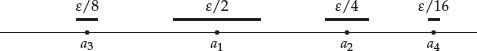

图 1.6 哈纳克对可数集的覆盖。

**Figure 1.6.** Harnack’s covering of a countable set.

$a1 by an interval of length ε/2, a2 by an interval of length ε/4, a3 by an interval of length ε/8, a4 by an interval of length ε/16,$

如图 1.6 所示。整个无限列表 a₁、a₂、a₃、a₄、……都被总长度至多为 ε 的线段覆盖。

as shown in Figure 1.6. And *the whole infinite list a*<sub>1</sub>, *a*<sub>2</sub>, *a*<sub>3</sub>, *a*<sub>4</sub>,… *is covered by line segments of total length at most* ε.

因此，这些数不包含所有实数。事实上，它们远未填满整条直线，这个集合的总长度为零！所以，任何列表都不能穷尽实数，甚至远远做不到。这个证明更鲜明地说明实数为何不可数，但似乎没有给出一个明确不在给定列表中的数。这个缺点恰好可以用对角线构造轻易弥补。为配合十进制记法，稍微修改覆盖区间的长度也更方便。

It follows that the numbers *a*<sub>1</sub>, *a*<sub>2</sub>, *a*<sub>3</sub>, *a*<sub>4</sub>, … do not include all real numbers. In fact, far from filling the whole line, the set of numbers *a*<sub>1</sub>, *a*<sub>2</sub>, *a*<sub>3</sub>, *a*<sub>4</sub>,,… has total length zero! Thus no list exhausts the set of real numbers, or even comes close. This proof shows more dramatically why there are uncountably many real numbers, but it does not seem to yield any *particular* number not in the given list *a*<sub>1</sub>, *a*<sub>2</sub>, *a*<sub>3</sub>, *a*<sub>4</sub>,…., This defect is easily fixed, by none other than the diagonal construction. (It is also convenient to modify the lengths of the covering intervals in order to suit decimal notation.)

设 a₁、a₂、a₃、a₄、……以无限小数给出，例如

Suppose that the numbers *a*<sub>1</sub>, *a*<sub>2</sub>, *a*<sub>3</sub>, *a*<sub>4</sub>,,… are given as infinite decimals, say

$a1=1.73205…, a2=0.11111…,a3=3⋅14159…, a4=0.99999…, ⋮$

如果用长为 1/10 的区间覆盖 a₁，那么在第一位小数上与 a₁ 至少相差 2 的数 x，一定在第一个覆盖区间之外。例如，把 a₁ 的第一位改为 5，则 x=0.5……在第一个区间之外。接着，用长为 1/100 的区间覆盖 a₂，那么第二位小数与 a₂ 至少相差 2 的数，一定在第二个区间之外。例如，把第二位改为 3，则 x=0.53……同时在前两个区间之外。同样，用长为 1/1000 的区间覆盖 a₃，则 x=0.533……在前三个区间之外。

If we cover *a*<sub>1</sub> by an interval of length 1/10 then numbers *x* that differ from *a*<sub>1</sub> in the first decimal place by at least 2 are definitely *outside* the first covering interval. We can change the first digit in *a*<sub>1</sub> to 5, for example, so *x* = 0 · 5 … is outside the first interval. Next, if we cover *a*<sub>2</sub> by an interval of length 1/100, then numbers *x* that differ from *a*<sub>2</sub> in the second decimal place by at least 2 are definitely outside the second covering interval. For example, we could change the second digit in *a*<sub>2</sub> to 3, so *x* = 0 · 53… is outside the first and second intervals. Similarly, if we cover *a*<sub>3</sub> by an interval of length 1/1000, then *x* = 0 · 533 … is outside the first, second, and third intervals.

显然可以继续这样做：用长为 1/10ⁿ 的区间覆盖每个 aₙ，同时适当选择 x 的第 n 位，使它与 aₙ 的第 n 位不同，从而得到一个在所有区间之外的数 x。这显然是对角线构造。

It is clear that we can continue in this way to cover each real number *a<sub>n</sub>* by an interval of length 1/10*<sup>n</sup>*, and at the same time find a number *x* outside all the intervals by choosing the *n*th digit of *x* to be suitably different from the *n*th digit of *a<sub>n</sub>.* This is clearly a diagonal construction.

因此，康托尔可能是从此前的不可数性证明中提炼出了对角线论证。事实上，另一位关注无限的德国数学家保罗·杜布瓦-雷蒙，早在 1875 年就描述过一种更明确的“对角线”构造。下一节讨论他的工作。

Thus it may be that Cantor distilled the diagonal argument from previous uncountability proofs. Indeed, a more explicitly “diagonal” construction had already been described in 1875 by another German mathematician with an interest in the infinite, Paul du Bois-Reymond. We discuss his work in the next section.

## 1.6 增长速度

## 1.6 Rates of Growth

从古代阿基米德尝试估计宇宙中的沙粒数，到今天“指数增长”成为陈词滥调，人们一直着迷于大数和快速增长。借助现代数学记号，很容易描述增长惊人的函数或数列；比较不同函数的增长速度则稍微困难一些。

From ancient times, when Archimedes tried to estimate the number of grains of sand in the universe, until today, when “exponential growth” has become a cliché, people have been fascinated by large numbers and rapid rates of growth. With modern mathematical notation it is quite easy to describe functions or sequences with extravagant growth and, with somewhat greater difficulty, to compare growth rates of different functions.

例如，函数 f(n)=n 的值依次为

For example, the function *f* (*n*) *= n*, whose sequence of values is

$1,2,3,4,5,6,…,$

这个函数会增长到超过任何界限，但不如 g(n)=n² 增长得快，后者的值构成平方数列：

is a function that grows beyond all bounds. But it does not grow as fast as the function *g*(*n*) *= n*<sup>2</sup>, whose values form the sequence of squares:

$1, 4, 9,16,25,36,….$

原因可从 g(n)/f(n)=n 看出，这个比值本身也超过一切界限，即通常所说的趋于无穷。一般地，约定当 G(n)/F(n) 趋于无穷时，称 G(n) 比 F(n) 增长得快。用符号表示为

We can see why by looking at *g*(*n*) /*f* (*n*) *= n*, which itself grows beyond all bounds, or *tends to infinity*, as we usually say. In general, let us agree to say that a function *G*(*n*) *grows faster* than a function *F*(*n*) if *G*(*n*)*/F*(*n*) tends to infinity. We write this relationship symbolically as

$G(n)/F(n)→∞ as n→∞.$

立刻可知，n³ 比 n² 增长得快，n⁴ 比 n³ 增长得快，依此类推。因此，无限函数族 {n,n²,n³,n⁴,……} 所代表的增长速度没有最大者，称为多项式增长速度族。

It follows immediately that *n*<sup>3</sup> grows faster than *n*<sup>2</sup>, *n*<sup>4</sup> grows faster than *n*<sup>3</sup>, and so on. Thus the infinite family of functions {*n*, *n*<sup>2</sup>, *n*<sup>3</sup>, *n*<sup>4</sup>,…} represents a family of growth rates with *no greatest member.* It is called the family of *polynomial* growth rates.

虽然没有最大的多项式增长速度，却存在超过所有多项式的增长速度。例如函数 2ⁿ 具有指数增长，对任何固定 k 都比 nᵏ 增长得快。这里不证明这一点，因为另一个函数更明显地胜过 n、n²、n³、n⁴、……，即

Although there is no greatest polynomial rate of growth, there is a growth rate greater than all polynomial rates. Consider, for example, the growth rate of the function 2*<sup>n</sup>*. This function has exponential growth, and it grows faster than *n<sup>k</sup>* for any fixed k. We shall not pause to prove this fact, because there is another function that beats all of *n, n*<sup>2</sup>, *n*<sup>3</sup>, *n*<sup>4</sup>,… more obviously; namely, the function

$d(n)=nn.$

显然，

It is clear that

$nn>n2 for all n>2, nn>n3 for all n>3, nn>n4 for all n>4, and so on.$

因此，对任意 k，当 n 足够大时都有 nⁿ>nᵏ⁺¹。由此 nⁿ/nᵏ 在 n→∞ 时趋于 ∞，因为我们已知 nᵏ⁺¹/nᵏ 在 n→∞ 时趋于 ∞。

Thus, for any *k, n<sup>n</sup> > n<sup>k+</sup>*<sup>1</sup> for all sufficiently large *n*. It follows that *n<sup>n</sup> /n<sup>k</sup>* → ∞ as *n* → ∞, because we already know that *n<sup>k+</sup>*<sup>1</sup>/*n<sup>k</sup>* → ∞ as *n* → ∞.

d(n)=nⁿ 的值，正是函数 n、n²、n³、n⁴、……的值表中对角线上的值：

The values of *d*(*n*) *= n<sup>n</sup>* are nothing but the *diagonal values* in the table of values of the functions *n, n*<sup>2</sup>, *n*<sup>3</sup>, *n*<sup>4</sup>,… :

$d(1)=11 is the first value of n, d(2)=22 is the second value of n2, d(3)=33 is the third value of n3, and so on.$

类似思想适用于任意函数序列。这实质上是杜布瓦-雷蒙 1875 年的发现，因此以他的名字命名。

A similar idea applies to any sequence of functions. This is essentially what du Bois-Reymond discovered in 1875, so we name the result after him.

杜布瓦-雷蒙定理：如果 f₁、f₂、f₃、……是一个正整数函数列表，那么存在一个正整数函数，比任意 fᵢ 都增长得快。

Theorem of du Bois-Reymond. *If f*<sub>1</sub>, *f*<sub>2</sub>, *f*<sub>3</sub>,… *is a list of positive integer functions, then there is a positive integer function that grows faster than any f<sub>i</sub>.*

证明：由于所有函数值都为正，有

*Proof:* Since all function values are positive, we have

$f1(n)+f2(n)+⋯+fn(n)>fi(n) for each i≤n.$

因此，定义 f(n)=f₁(n)+f₂(n)+⋯+fₙ(n)，便有对所有 n>i，f(n)≥fᵢ(n)。也就是说，f 至少与每个 fᵢ 增长得一样快。

The function *f* defined by *f* (*n*) = *f*<sub>1</sub> (*n*)+ *f*<sub>2</sub>(*n*) + ⋯ *+ f<sub>n</sub>*(*n*), therefore satisfies *f* (*n*) ≥ *f<sub>i</sub>*(*n*) for all *n > i*.That is, *f* grows *at least as fast* as any function *f<sub>i</sub>.*

于是，若定义函数 d 为

Consequently, if we define a function *d* by

$d(n)=n f(n),$

则 n→∞ 时 d(n)/f(n)→∞，所以 d 比任意 fᵢ 都增长得快。□

then *d*(*n*) / *f* (*n*) → *∞* as *n* → *∞*so *d* grows faster than any function *f<sub>i</sub>*. *□*

由此可知，任何函数列表都不足以“赶超”每一个自然数函数。这正是杜布瓦-雷蒙感兴趣的地方，也是一个意义深远的发现，后面还会再谈。不过请注意，我们再次得到了证明不可数性的对角线论证。称 d(n)=nf(n) 为“对角线”函数，是因为 f(n) 是 f₁、f₂、f₃、……的函数值表中，对角线上及其上方各项的和。

It follows that no list of functions grows fast enough to “overtake” every function of natural numbers. This was what interested du Bois-Reymond, and it is indeed a very pregnant discovery, to which we will return later. But notice also that we again have a diagonal argument for uncountability. (We regard the function *d*(*n*) *= nf*(*n*) as “diagonal” because *f* (*n*) is the sum of entries in or above the diagonal in the table of function values for *f*<sub>1</sub>, *f*<sub>2</sub>, *f*<sub>3</sub>,….)

正整数函数集不可数，因为对任意这样的函数列表 f₁(n)、f₂(n)、f₃(n)、……，都存在不在列表中的函数 d(n)。

*The set of positive integer functions is uncountable*, because *for any list of such functions f*<sub>1</sub> (*n*), *f*<sub>2</sub>(*n*), *f*<sub>3</sub>(*n*),… *there is a function d*(*n*) *not in the list.*

## 1.7 连续统的基数

## 1.7 The Cardinality of the Continuum

迄今我们发现了三个不可数集：实数集、正整数的子集组成的集合，以及从正整数到正整数的函数组成的集合。在某种意义上，它们本质上是同一个集合，因此三者的不可数性都由类似论证得出，并不奇怪。

So far we have found three uncountable sets: the set of real numbers, the set of subsets of the positive integers, and the set of functions of positive integers with positive integer values. In a certain sense these three are essentially the *same* set, so it is not so surprising that in each case their uncountability follows by a similar argument.

与第 1.1 节讨论的几个可数集一样，这三个不可数集具有相同的基数。第 1.3 节把它记作 $2N0$，也称为连续统的基数，因为实数连续统是具有基数 $2ℵ0$ 的最具体的集合。我们可以把全体实数想象为一条连续的直线，即“数轴”；但在正整数的所有子集与实数配对之前，很难想象这些子集构成的整体。

Like the several countable sets discussed in Section 1.1, these three uncountable sets have the same cardinality. We called it $2N0$ in Section 1.3, and it is also called the *cardinality of the continuum*, since the continuum of real numbers is the most concrete set with cardinality $2ℵ0$.We can visualize the totality of all real numbers as a continuous line—the “number line”—but it is quite hard to visualize the totality of sets of positive integers, say, until these sets have been matched up with real numbers.

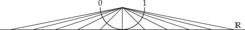

图 1.7 ℝ 与区间 (0,1) 之间的一一对应。

**Figure 1.7.** One-to-one correspondence between R and the interval (0,1).

在建立实数与正整数子集的一一对应之前，先注意全体实数集 ℝ 与 0、1 之间的实数区间 (0,1) 存在一一对应。把 0、1 之间的线段弯成半圆，再如图 1.7 所示把半圆投影到数轴 ℝ 上，从几何上就很清楚。

Before establishing a one-to-one correspondence between real numbers and sets of positive integers, we first observe that *there is a one-to-one correspondence between the set* ℝ *of all real numbers and the interval* (0, 1) *of real numbers between* 0 *and* 1. This is geometrically obvious if one bends the line segment between 0 and 1 into a semicircle and then projects the semicircle onto the number line ℝ as shown in Figure 1.7.

### 实数与集合之间的对应

### Correspondence between Real Numbers and Sets

1/3 在 (0,1) 的左半边，因此第一位为 0；又在 (0,1/2) 的右半边，因此第二位为 1。显然，1/3 以 1:2 的比例分割 (0,1)，也以相同比例分割 (1/4,1/2)，因此这个过程从此重复。于是 1/3 的二进制展开为

$.010101010101010101010101…$

（这里的点是“二进制小数点”，而不是十进制小数点。）当 x 恰好落在二等分线上时，就会出现歧义，例如 x=1/2 或 x=1/4。这时，在分割线碰到 x 的那一步，可以把 x 分配给左子区间或右子区间，但此后就没有选择了。如果写 0，把 x 分给左半边，那么 x 此后就会位于每个新子区间的右半边，于是这个 0 后面跟着无限多个 1。例如，1/2 有二进制展开

(where the dot is a “binary point” instead of the decimal point). Ambiguity enters when *x* falls on a line of bisection; for example, when *x* = 1/2 or *x* = 1/4. In that case, we can assign *x* to either the left or right subinterval when the line of subdivision hits *x*, but thereafter we have no choice. If we write 0—thus assigning *x* to the left half—then *x* will lie in the right half of every subinterval constructed thereafter, and the 0 will be followed by an infinite sequence of 1s. For example, 1/2 has the binary expansion

$.011111111111111111111111111….$

但如果一开始选 1，此后每一位都是 0，因此 1/2 的另一种二进制展开为

But if we choose 1 at the beginning, then every digit thereafter is 0, so the other binary expansion of 1/2 is

$.100000000000000000000000…$

这类似于十进制展开的歧义：1/2 既可写成 0.499999999……，也可写成 0.500000000……。

(This is analogous to the ambiguity in decimal expansions, where 1/2 can be written as both ·499999999 … and ·500000000 ….)

一般地，(0,1) 中每个二进分数 p/2ᑫ 都对应两个不同的 0、1 序列。二者具有相同的初始片段，之后一个接 10000……，另一个接 01111……。因此，每个二进分数对应两个不同的自然数子集。幸而二进分数只有可数多个，例如它们是有理数集的子集，所以这种一一对应的失效很容易修补。

In general, each *binary fraction p/*2*<sup>q</sup>* in (0,1) corresponds to two different sequences of 0s and 1s. Both sequences have the same initial segment, in one case followed by 10000… and in the other case followed by 01111 … . Thus each binary fraction corresponds to two different sets of natural numbers. Fortunately, there are only countably many binary fractions (for example, because they form a subset of the set of rationals) so this breakdown of the one-to-one correspondence is easily fixed.

事实上，第 1.1 节已经说明，二对一对应的可数集也能一一对应，例如全体自然数集与偶数集。因此，可以把以 10000……或 01111……结尾的序列与二进分数之间的二对一对应，重新安排为一一对应。再结合其余 0、1 序列与其余 (0,1) 中的数之间的一一对应，就得到所需的自然数子集与 0、1 之间实数的一一对应。

In fact we have already seen, in Section 1.1, how countable sets in two-to-one correspondence are also in one-to-one correspondence (consider the set of all natural numbers and the set of all even numbers). Thus the two-to-one correspondence between sequences ending in 10000 … or 01111 … and binary fractions can be rearranged into a one-to-one correspondence. Combining this with the one-to-one correspondence between the remaining sequences of 0s and 1s and the remaining numbers between 0 and 1 gives the required one-to-one correspondence between sets of natural numbers and real numbers between 0 and 1.

### 函数与实数之间的对应

### Correspondence between Functions and Real Numbers

每个从正整数到正整数的函数 f，可按如下方法对应到 0、1 之间的一个实数。先写下 f 的函数值序列，例如

Each function *f* on the set of positive integers, with positive integer values, corresponds to a real number between 0 and 1 as follows. First write down the sequence of values of *f*, say,

$4,2,6,1,1,8,3,5,….$

再把这个序列编码为 0、1 序列：把每个正整数 f(n) 替换为由 f(n)−1 个 1 构成的块，其中可能一个 1 也没有；把每个逗号替换为 0：

Next, encode this sequence by a sequence of 0s and 1s, replacing each positive integer *f* (*n*) by a block of *f* (*n*) − 1 (hence possibly zero) 1s, and each comma by a 0:

$111010111110001111111011011110…$

最后，在前面加上二进制小数点，使这个序列成为某个实数的二进制展开。这个展开必定含无限多个 0，因为函数 f 有无限多个值。这恰好合适，因为它意味着我们排除了所有以 1111……结尾的二进制展开，因此 0、1 之间每个实数至多出现一次。

Finally, insert a binary point in front to make this sequence the binary expansion of a real number. The expansion is necessarily one with infinitely many 0s, because the function *f* has infinitely many values. But this is fine, because it means we omit all binary expansions ending in 1111…, and hence we get each real number between 0 and 1 at most once.

反过来，0、1 之间每个实数都有一个唯一的、含无限多个 0 的二进制展开，而这个展开编码了唯一的函数 f。例如，若二进制展开为

Conversely, each real between 0 and 1 has a unique binary expansion with infinitely many 0s, and there is a unique function *f* encoded by this expansion. For example, if the binary expansion is

$.001011001111101101010101….$

那么 f 的各个函数值依次为

then the successive values of *f* are

$1,1,2,3,1,6,3,2,2,2,2,….$

一般地，

In general,

$f(1)=( number of 1s before the first 0)+1, f(2)=( number of 1s after the first 0 and before the second 0)+1, f(3)=( number of 1s after the second 0 and before the third 0)+1, and so on.$

因此，二进制展开在正整数函数与 0、1 之间的实数之间建立了一一对应。

Thus binary expansions give a one-to-one correspondence between positive integer functions and real numbers between 0 and 1.

## 1.8 历史背景

## 1.8 Historical Background

### 古希腊的无限

### Infinity in Ancient Greece

芝诺断言，一个东西不可能在有限时间内越过或逐一遇到无限多个东西；他的论证作出了一个错误的假设。

Zeno’s argument makes a false assumption in asserting that it is impossible for a thing to pass over or severally to meet with infinite[ly many] things in finite time.

——亚里士多德

—Aristotle

《物理学》第 VI 卷，第 2 章。

*Physics*, Book VI, Chap. 2.

自古以来，无限就是数学的重要组成部分，尽管人们常认为使用它有害。公元前 500 年前后，毕达哥拉斯学派发现 $2$ 的无理性，由此开始了理解我们今天所谓实数概念的漫长历程。这也是一场更大斗争的一部分：调和几何中出现的连续量，即长度、面积、体积，与计数中出现的离散自然数 1、2、3、4、……。

Since ancient times, infinity has been a key part of mathematics, though its use has often been considered harmful. Around 500 bce, the Pythagoreans discovered the irrationality of $2$, thus beginning a long struggle to grasp (what we now call) the concept of real number. This was part of a larger struggle to reconcile the continuous magnitudes arising in geometry—length, area, volume—with the discrete natural numbers 1, 2, 3, 4,… arising from counting.

无理性的冲击，显然使希腊人不愿把连续量当作数。例如，他们把两个长度的乘积看作矩形，三个长度的乘积看作长方体，四个长度的乘积则完全没有意义。尽管如此，他们在联系连续量与自然数方面仍取得了重大进展。公元前 350 年前后，欧多克索斯提出“比例理论”，我们从欧几里得《几何原本》第 V 卷得知这一理论；在 19 世纪以前，这是最接近实数定义的工作。欧几里得把无理长度 l 刻画为使某个过程，即对 l 与 1 施行欧几里得算法，永不终止的长度。阿基米德通过无限过程求曲边图形的面积与体积，在某些方法中甚至打破了不得使用“实无限”集合的禁忌。

The shock of irrationality apparently left the Greeks unwilling to treat continuous magnitudes as numbers. For example, they viewed the product of two lengths as a rectangle, the product of three lengths as a box, and the product of four lengths as having no meaning at all. Nevertheless, they made great progress in *relating* continuous magnitudes to the natural numbers. Around 350 bce, Eudoxus introduced a “theory of proportion” (known to us from Book V of Euclid’s *Elements*), which was as close as anyone came to defining real numbers before the 19th century. Euclid characterized irrational lengths *l* as those for which a certain process (the euclidean algorithm on *l* and 1) is infinite. Archimedes found areas and volumes of curved figures by infinite processes, even breaking the taboo against “actual” infinite sets in some of his methods.

直到 19 世纪，几乎所有数学家都严格区分所谓潜无限与实无限。潜无限通常是一个永不终止的过程，例如数数 1、2、3、……，或把曲边区域分割成越来越小的三角形。实无限则是假定这个无尽过程已经完成，例如全体自然数构成的集合 {1,2,3,……}。原则上，说无尽过程已经完成是矛盾的；但实际上，许多过程有明确的极限，仿佛迫切要求被视为完成。

Almost all mathematicians until the 19th century made a sharp distinction between what they called the *potential* and *actual* infinite. The potential infinite is typically an *unending process*, such as counting 1, 2, 3,… or cutting a curved region into smaller and smaller triangles. The actual infinite is the supposed *completion* of an unending process, such as the set {1, 2, 3,…} of all natural numbers. In principle, it is contradictory to speak of the completion of an unending process, but in practice many processes beg for completion, because they have a clear *limit.*

芝诺著名的悖论，例如阿喀琉斯与乌龟，都涉及具有明确极限的过程。阿喀琉斯从乌龟后面出发，但跑得更快，所以显然会在某处追上。至少芝诺担心的是，阿喀琉斯在无限多个阶段中都落在乌龟后面：第一阶段在他到达乌龟起点时结束；第二阶段在他跑完乌龟第一阶段的路程时结束；第三阶段在他跑完乌龟第二阶段的路程时结束，依此类推。于是，运动似乎要求完成一个无限事件序列。希腊人因此觉得运动概念有问题，试图用潜无限来化解悖论，正如亚里士多德在《物理学》中所做的那样。对我们而言，这或许反而支持实无限存在的观点。

The famous paradoxes of Zeno, such as Achilles and the tortoise, involve processes with a clear limit. Achilles starts behind the tortoise, but runs faster, so clearly he will catch up with the tortoise at some point. The worry, at least for Zeno, is that Achilles is behind the tortoise *at infinitely many stages* (the first stage ends when Achilles reaches the tortoise’s starting point, the second when Achilles completes the tortoise’s first stage, the third when Achilles completes the tortoise’s second stage, and so on). So, apparently, motion involves completing an infinite sequence of events. For the Greeks, this made the concept of motion seem problematic, and they looked for ways to resolve the paradox in terms of potential infinity (as Aristotle did in his *Physics*). For us, it probably supports the idea that actual infinity exists.

无论如何，古希腊数学中有许多例子表明，无限过程的极限能够带来有趣的新知识。例如，欧几里得与阿基米德发现，四面体体积与抛物线弓形面积，都可以通过无穷级数

At any rate, in ancient Greek mathematics there are many examples where the limit of an infinite process gives interesting new knowledge. For example, Euclid and Archimedes found that both the volume of the tetrahedron and the area of a parabolic segment may be found from the infinite series

$1+14+142+143+144+⋯,$

求出，其和为 4/3。他们只考虑下列潜在无限的各项，便能求得这个和：

which has sum 4/3. They are able to find this sum by considering only the potential infinity of terms

$1, 1+14′, 1+14+142, 1+14+142+143, 1+14+142+143+144, …$

并证明

and showing that

- 其中每一项都小于 4/3，而且

  each of these terms is less than 4/3, and
- 任意小于 4/3 的数，最终都会被数列中的某一项超过。

  each number less than 4/3 is exceeded by some term in the sequence.

因此，把 4/3 称为 $1+14+142+143+144+⋯$ 的和是合理的，因为我们已穷尽其他所有可能性。这种同样由欧多克索斯发明的穷竭法，能够在许多希腊人感兴趣的问题中避免实无限，但并非所有问题都能如此。

Thus it is fair to call 4/3 the sum of $1+14+142+143+144+⋯$, because we have exhausted all other possibilities. This *method of exhaustion*, also invented by Eudoxus, can be used to avoid actual infinities in many of the cases that interested the Greeks. *But not all.*

阿基米德写过一本《方法》，它失传了许多世纪，没有影响后来数学的发展。书中描述了他发现某些最著名结果的方法，例如球的体积等于其外切圆柱体积的 2/3。此书在 1900 年前后重现，人们这才意识到，阿基米德曾以一种无法规避的方式使用实无限。在求某些体积时，他把立体看作厚度为零的薄片之和。我们现在知道，这样的薄片有不可数多个，对应于直线上不可数多个点，因此不能把所有薄片之和看作有限和的“极限”。当然，阿基米德不大可能对不可数性有所察觉，尽管他也许怀疑自己面对的是一种新的无限。¹

Archimedes wrote a book called *The Method*, which was lost for many centuries and did not influence the later development of mathematics. It describes the method by which he discovered some of his most famous results, such as the theorem that the volume of a sphere is 2/3 the volume of its circumscribing cylinder. The book resurfaced around 1900, and only then was it realized that Archimedes had used actual infinity in a way that cannot be avoided. In finding certain volumes, Archimedes views a solid body as a sum of *slices of zero thickness.* As we now know, there are uncountably many such slices—corresponding to the uncountably many points on the line—so one cannot view the sum of all slices as the “limit” of finite sums. Of course, it is unlikely that Archimedes had any inkling of uncountability, though he may have suspected that he was dealing with a new kind of infinity.<sup>1</sup>

《方法》表明，关于无限，甚至关于连续统的直观确实存在，而且有助于数学发现。1800 年前后，这种直观结出了更多果实。

*The Method* gives evidence that *intuition about infinity,even* about the continuum, exists and is useful in making mathematical discoveries. More fruits of this intuition appeared around 1800.

### 关于连续统的最早现代直观

### The First Modern Intuitions About the Continuum

……我们赋予直线以完备性、无隙性或连续性。那么，这种连续性究竟是什么？

… we ascribe to the straight line completeness, absence of gaps, or continuity. In what then does this continuity consist?

——理查德·戴德金

—Richard Dedekind

《连续性与无理数》第 III 章，见 Dedekind（1901），第 10 页。

*Continuity and Irrational Numbers*, Chapter III, in Dedekind (1901), p. 10.

连续统 [0,1] 的根本性质，就是它确实是连续的，也就是说，它毫无空隙地填满两端点之间的空间。1800 年前后，德国数学家卡尔·弗里德里希·高斯意识到，这个看似显然的性质，是证明一个困难定理的关键。此前几位数学家都曾试图证明它，却徒劳无功，这就是所谓“代数基本定理”。这个定理断言，任意多项式方程，例如

The fundamental property of the continuum [0, 1] is that it is, well, *continuous*, in the sense that it *fills the space between its endpoints without gaps.* Around 1800, the German mathematician Carl Friedrich Gauss realized that this seemingly obvious property is the key to a difficult theorem that several mathematicians had vainly sought to prove—the so-called “fundamental theorem of algebra.” This theorem states that any polynomial equation, such as

$x4−2x2+3x+7=0, or x5−x+1=0,$

都有某个复数 x 满足它。高斯本人证明这个定理时也遇到了困难；按现代标准，他提出的所有证明都不完整。不过，1816 年他给出的一个证明，清楚地指出了困难所在：归根结底，问题在于连续统没有空隙。

is satisfied by some complex number *x*. Gauss himself had trouble proving the theorem, and all the proofs he offered are incomplete by modern standards. However, in 1816 he gave a proof that clearly identifies the difficulty: it all boils down to the absence of gaps in the continuum.

高斯 1816 年的证明，通过纯代数运算，把任意多项式方程化为一个奇数次方程，例如 p(x)=0。这意味着 p(x) 的最高次项是 x 的奇数次幂，例如上面第二个例子中的 x⁵。x 的绝对值很大时，多项式 p(x) 由最高次项支配，因此，从很大的负 x 值变到很大的正 x 值时，p(x) 会改变符号，因为 x 的任意奇数次幂都是如此。

Gauss’s 1816 proof takes any polynomial equation and reduces it, by purely algebraic manipulations, to an equation of *odd degree*, say *p*(*x*) =0. This means that the highest-degree term in *p*(*x*),such as *x*<sup>5</sup> in the second example above, is an odd power of *x*. Now, for large values of *x*,the polynomial *p*(*x*) is dominated by its highest-degree term, and so *p*(*x*) *changes sign* between large negative values of *x* and large positive values of *x*, since this happens to any odd power of *x.*

因此，图像 y=p(x) 是一条从负 y 值移到正 y 值的连续曲线。图 1.9 画出了具体例子 y=x⁵−x+1 的曲线。由于曲线从 x 轴下方移到上方，而 x 轴没有空隙，曲线必定与 x 轴相交。

Thus the graph *y = p*(*x*) is a continuous curve which moves from negative values of *y* to positive values. Figure 1.9 shows the curve for the actual example *y = x*<sup>5</sup> − *x* + 1. Since the curve passes from below to above the *x*-axis, and the *x*-axis has no gaps, the curve necessarily *meets* the *x*-axis.

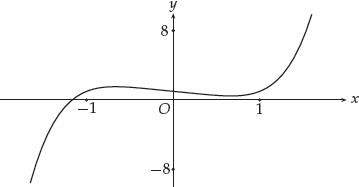

图 1.9 多项式 y=x⁵−x+1 的图像。

**Figure 1.9.** Graph of the polynomial *y = x*<sup>5</sup> − *x +* 1.

也就是说，存在一个实数 x，使 x⁵−x+1=0。类似地，任意奇数次多项式方程都有实数解，代数基本定理随之成立。高斯化归到奇数次的过程，还涉及解二次方程；我们知道二次方程有解，有时解在复数域中。

That is, *there is a real value of x for which x*<sup>5</sup> − *x* + 1 = 0. Similarly, any odd-degree polynomial equation has a real solution, and the fundamental theorem of algebra follows. (Gauss’s reduction to odd degree also involves solving quadratic equations, which we know have solutions, sometimes in the complex numbers.)

高斯的直观使他默认了今天所谓的介值定理：若连续函数 f(x) 在 x=a 与 x=b 之间既取正值又取负值，那么在二者之间的某个 x=c 处必取零值。捷克数学家伯纳德·波尔查诺于 1816 年首先指出这一假设并尝试证明。他不仅从一个此前被认为属于代数的定理中看出了连续函数的性质，还意识到介值性质依赖连续统的本性，这些认识都超越了时代。

Gauss’s intuition had led him to assume what we now call the *intermediate value theorem:* any continuous function *f*(*x*) that takes both positive and negative values between *x* = *a* and *x* = *b* takes the value zero for some *x = c* between *a* and *b*. The first to identify this assumption, and to attempt to prove it, was the Czech mathematician Bernard Bolzano in 1816. Bolzano was ahead of his time, not only in noticing a property of continuous functions in a theorem previously thought to belong to algebra, but also in realizing that the intermediate value property depends on the nature of the continuum.

波尔查诺的证明尝试并不完整，因为当时完全没有连续统的定义。不过，他正确指出，任何合理的连续统概念都必须满足一个完备性条件，即最小上界性质：若实数集 S 有上界，则 S 有最小上界。也就是说，在所有大于或等于 S 中每个元素的数中，存在最小者。

Bolzano’s attempted proof was incomplete, because a definition of the continuum was completely lacking in his time. However, he correctly identified a *completeness condition* that any reasonable concept of continuum must satisfy. This is the *least upper bound property* :if *S* is a set of real numbers with an upper bound, then *S* has a least upper bound. (That is, among the numbers greater than or equal to all members of *S*, there is a least.)

1858 年，理查德·戴德金为这一思路带来了令人满意的结局：他用所谓有理数的分割来定义实数。直观上，分割就像用一把无限锋利的刀，把有理数分成下集 L 与上集 U。形式上，分割是一个有序对 (L,U)，其中 L、U 合在一起包含全部有理数，并且 L 中每个元素都小于 U 中每个元素。分割 (L,U) 按如下方式同时表示有理数与无理数：

In 1858, Richard Dedekind brought this train of thought to a satisfying conclusion, defining real numbers by what he called *cuts* in the rationals. A cut is intuitively a separation of the rational numbers into a *lower set L* and an *upper set U*, as if by an infinitely sharp knife. Formally, a cut is a pair (*L, U*) where *L* and *U* are sets that together are all the rationals and such that every member of *L* is less than every member of *U*. Cuts (*L, U*) represent both rational and irrational numbers as follows:

- 如果 L 有最大元素，或 U 有最小元素，记为 r，那么 (L,U) 就表示有理数 r。

  If *L* has a greatest member, or *U* has a least member, say *r*, then (*L, U*) represents the rational number *r.*
- 如果 L 没有最大元素，U 也没有最小元素，那么 (L,U) 就表示一个无理数。例如，当 U 由平方大于 2 的正有理数组成，L 由其余有理数组成时，就出现这种情况。有序对 (L,U) 此时表示我们称为 $2$ 的无理数。

  If *L* has no greatest member and *U* has no least member, then (*L, U*) represents an irrational number. (This happens, for example, when *U* consists of the positive rationals with square > 2, and *L* consists of the remaining rationals. The pair (*L, U*) then represents the irrational number we call $2$.)

后一类分割代表有理数中的一个空隙，同时也提供了填补这个空隙的对象，即分割 (L,U)。戴德金以令人惊叹的胆识，填满有理数中的每一个空隙，从而创造了一个无隙的连续统；而他用来填补空隙的对象，实质上就是空隙本身。²

The latter type of cut represents a *gap* in the rationals and, at the same time, provides an object to fill the gap—the cut (*L*, *U*). With breathtaking nerve, Dedekind created a gapless continuum by filling each gap in the rationals, *taking the object that fills each gap to be essentially the gap itself.*<sup>2</sup>

再论无限小数

Infinite decimals revisited

应该指出，本章前面用来模拟实数的无限小数，实质上是戴德金分割的一种更易读的版本。一个无限小数，例如 3.14159……，代表了较稀疏的十进分数集中的一个分割，把小于 3.14159……的最近邻数，

It should be mentioned that the infinite decimals, used to model real numbers earlier in this chapter, are essentially a more readable version of Dedekind cuts. An infinite decimal, such as 3.14159…, represents a cut in the less crowded set of *decimal fractions*, separating the nearest neighbors less than 3.14159…,

$3,3.1,3.14,3.141,3.1415,3.14159,…,$

与大于 3.14159……的最近邻数，

from the nearest neighbors greater than 3.14159… ,

$4, 3.2, 3.15,3.142,3.1416,3.14160,….$

分开。无限小数容易阅读和理解，但请试着定义它们的和与积！你大概最终还是会对它们邻近的十进分数作加法与乘法，与处理戴德金分割十分相似。

Infinite decimals are easy to read and understand, but try defining their sum and product! You will probably fall back on adding and multiplying their neighboring decimal fractions, much as with Dedekind cuts.

当然，仅仅知道分割集合没有空隙还不够。还必须知道分割确实像数那样运算。这一点成立：可以用分割中的有理数定义两个分割的“和”与“积”，而这些运算满足通常的代数性质。例如，$2+3$ 所对应分割的下集，

Of course, it is not enough that there are no gaps in the set of cuts. We also need to know that *cuts are entities that behave like numbers*. This is true. One can define the “sum” and “product” of two cuts in terms of the rational numbers in them, and this “sum” and “product” have the usual algebraic properties. For example, the cut for $2+3$ has lower

由所有形如 r+s 的数组成，其中 r 属于 $2$ 的下集，s 属于 $3.$ 的下集。由于 r+s=s+r，这与 $3+2$ 对应的分割相同。更妙的是，任意有界分割集 S 都有最小上界：把 S 中所有分割的下集合并，就得到这个最小上界的下集。

set consisting of all the numbers *r* + *s*, where r is in the lower set for $2$ and s is in the lower set for $3.$ This is the same as the eut for $3+2$ because *r + s = s + r.* Best of all, *any bounded set S of cuts has a least upper bound.* The least upper bound of *S* has a lower set obtained by uniting the lower sets for all members of *S.*

因此，借助戴德金的实数定义，终于能够证明介值定理，进而证明代数基本定理。同时，这个证明也开启了数学思想的新方向：此前未定义的数学对象开始用集合定义，而每个集合都成为合法的数学对象，包括不可数的实数集。

Thus, with Dedekind’s definition of real numbers, it was finally possible to prove the intermediate value theorem, and hence the fundamental theorem of algebra. At the same time, the proof initiated a new direction in mathematical thought. Previously undefined mathematical objects became defined in terms of sets, and every set became a legitimate mathematical object—even the uncountable set of real numbers.

事实上，许多数学家欢迎实数集，把它当作直线的数学模型。今天，“数轴”看起来似乎很简单，其实不然！对知道“点”实际上是无限有理数集的一个分割的人来说，一个点就是整个宇宙。尽管如此，19 世纪 70 年代的许多数学家仍认为，几何的算术化是建立数学基础的最佳途径。算术化解决了数与几何量之间的古老冲突，也为几何与微积分提供了共同基础。它出现得正是时候，因为康托尔刚开始探索集合概念本身。

Indeed, the set of real numbers was welcomed by many mathematicians as a mathematical model of the line. Today, the “number line” seems like a simple idea, but it is not! A “point” is a whole universe to someone who knows that it is actually a cut in the infinite set of rational numbers. Nonetheless, in the 1870s, many mathematicians saw this *arithmetization of geometry* as the best way to build the foundations of mathematics. Arithmetization resolved the ancient conflict between numbers and geometric magnitudes; it also provided a common foundation for geometry and calculus. And arithmetization was timely because Cantor had just started exploring the set concept itself.

然而，对集合概念的进一步探索又带来了意外。

However, further exploration of the set concept led to some surprises.

### 集合论的悖论

### The Paradoxes of Set Theory

……不过是智慧女神跟人类开的一场玩笑。

… a mere practical joke played on mankind by the goddess of wisdom.

——阿兹里尔·莱维（1979），第 7 页。

—Azriel Levy (1979), p. 7.

保罗·杜布瓦-雷蒙基于函数的对角线论证（第 1.6 节）影响深远，本书后面将会看到。康托尔基于集合的对角线论证（第 1.3 节），则产生了更直接、更戏剧性的后果。

The function-based diagonal argument of Paul du Bois-Reymond (Section 1.6) had far-reaching consequences, as we will see in later chapters of this book. The set-based diagonal argument of Cantor (Section 1.3) had consequences that were more immediate and dramatic.

In 1891, Cantor realized that the diagonal argument applies to *any* set, showing that *any set X has more subsets than members.* Of course, we cannot generally visualize a tabulation of subsets of X, as we did in Section 1.3 for subsets of the natural numbers. It is sufficient to consider any *one-to-one correspondence* between members *x* of *X* and subsets of *X*. Let *S<sub>x</sub>* be the subset corresponding to *x*.From the sets *S<sub>x</sub>* we define the “diagonal set” *S*, whose members are the *x* such that *x* does *not* belong to *S<sub>x</sub>.*

It is clear that *S differs from each set S<sub>x</sub>* with respect to the element *x*:if *x* is in *S<sub>x</sub>* then *x* is not in *S*, and if *x* is not *S<sub>x</sub>* then *x* is in *S*.Thus,any pairing of subsets of *X* with members of *X* fails to include all subsets. This is what we mean by saying that *X* has more subsets than members.

It follows, in turn, that *there is no largest set.* And, therefore, *there is no such thing as the “set of all sets”*—because the set of all sets, if it exists, is necessarily the largest set. When Cantor noticed this, in 1895, it seems to have given him some pause. What exactly does the word “set” mean if there is no set of all sets? Cantor did not have a precise answer to this question, but neither was he greatly perturbed. He had no commitment to the “set of all sets” and was content to consider only sets obtained by clear operations on given sets, such as collecting all subsets.

The question was more troubling for philosophers of mathematics, such as Gottlob Frege and Bertrand Russell, who believed that any property *Ƥ* should determine a set—the set of all objects with property *Ƥ*. When the property in question is “being a set” then this belief leads to the “set of all sets.” Indeed, Russell rediscovered the contradiction in the “set of all sets” in 1901, in a form that became famous as the *Russell paradox.* Russell’s contribution was to distill the contradiction into “the set of all sets that are not members of themselves.” The latter “set” *R* is immediately self-contradictory, since *R* belongs to *R* if and only if *R* does *not* belong to *R.*

罗素的论证使数学家确信，集合概念需要澄清，也强化了 19 世纪 70 年代以来数学需要稳固基础的思想。这场“基础危机”，以及后面还会遇到的其他“危机”，产生了深远后果，本书余下部分将会说明。德国数学家恩斯特·策梅洛（1908）这样描述集合论面临的问题：

Russell’s argument convinced mathematicians that the set concept needs clarification, and it reinforced the idea from the 1870s that mathematics needs secure foundations. This “crisis in foundations” (and other “crises” we will meet later) had profound consequences, as we will see in the rest of the book. The problem facing set theory was described by the German mathematician Ernst Zermelo (1908) as follows.

……某些矛盾似乎威胁着这门学科本身的存在……尤其是，考虑到“所有不以自身为元素的集合所组成的集合”导致的“罗素二律背反”，如今似乎已不能允许把任意逻辑定义的概念的外延都视为一个集合或类。

… the very existence of this discipline seems to be threatened by certain contradictions … In particular, in view of the “Russell antinomy” of the set of all sets that do not contain themselves as elements, it no longer seems admissible today to assign to an arbitrary logically defined notion a set, or class, as its extension.

策梅洛相信，集合公理可以挽救集合论：把康托尔的直观形式化，即所有集合都由给定集合，例如自然数集，通过明确规定的运算，例如收集所有子集，产生。

Zermelo believed that set theory could be saved by *axioms for sets*, formalizing Cantor’s intuition that all sets arise from given sets (such as the set of natural numbers) by well-defined operations (such as collecting all subsets).

今天最常用的集合公理由策梅洛于 1908 年提出，他的同胞亚伯拉罕·弗兰克尔于 1922 年作了重要补充，后者后来移居以色列。因此，这些公理称为 ZF 公理。它们用一种尚未介绍的集合论形式语言写成，但借助“属于”概念，多数公理都可以用日常语言清楚表达。把以 a、b、c、……为元素的集合写作 {a,b,c,……}。花括号把对象 a、b、c、……收集为一个集合的元素，这些对象本身也可能是集合。

The axioms for sets most commonly used today are due to Zermelo (1908), with an important supplement from his compatriot (who later moved to Israel) Abraham Fraenkel in 1922. Because of this they are called the *ZF axioms.* They are written in a formal language for set theory that I have not introduced, but most of them can be clearly expressed in ordinary language with the help of the concept of “membership.” We write the set with members *a*, *b*, *c*,… as {*a*, *b*, *c*,…}. Thus the brackets “comprehend” the objects *a, b, c, …* (which may themselves be sets) as members of a set.

公理 1 两个集合相等，当且仅当它们具有相同的元素。

Axiom 1. Two sets are equal if and only if they have the same members.

公理 2 存在一个没有元素的集合，称为空集。

Axiom 2. There is a set with no members, called the *empty set.*

公理 3 对任意集合 X、Y，都存在一个仅以 X、Y 为元素的集合。这个集合 {X,Y} 称为 X、Y 的无序对。注意，当 Y=Z 时，公理 1 给出 {Y,Z}={Y}，因此配对公理也给出只含元素 Y 的“单元素集”{Y}。ZF 公理如下。

Axiom 3. For any sets *X* and *Y*, there is a set whose only members are *X* and *Y*. (This set, {X, *Y*}, is called the *unordered pair* of *X* and Y. Note that, when *Y = Z*, Axiom 1 gives {*Y, Z*} = {*Y*}. Thus the pairing axiom also gives us the “singleton” set {*Y*} whose single member is Y.) The ZF axioms are the following.

公理 4 对任意集合 X，都存在一个集合，其元素恰好是 X 的元素的元素。当 X={Y,Z} 时，这些元素组成的集合称为 Y 与 Z 的并集，记为 Y∪Z。一般地，这个集合称为 X 中各元素的并集。

Axiom 4. For any set *X* there is a set whose members are the members of members of X. (In the case where *X* = {*Y, Z*}, the members of members of *X* form what is called the *union of Y and Z*, denoted by *Y* ⋃ Z. In all cases, the set of members of members of *X* is called the *union* of the members of *X.*)

公理 5 对任意集合 X，都存在一个以 X 的所有子集为元素的集合。X 的子集，是指其每个元素都属于 X 的集合。X 的所有子集组成的集合，称为 X 的幂集。

Axiom 5. For any set X, there is a set whose members are the *subsets* of *X*, where a subset of *X* is a set whose members are members of *X.* (The set of subsets of *X* is called the *power set* of X.)

公理 6 对任意函数定义 f 和集合 X，所有 f(x)，其中 x 属于 X，构成一个集合。它称为函数 f 在定义域 X 上的值域；这个公理称为替代公理。

Axiom 6. For any function definition *f*, and set X, the values *f* (*x*), where *x* is a member of X, form a set. (This set is called the *range* of the function *f* on the *domain X*, and the axiom is called *replacement.*)

公理 7 任意非空集合 X 都有一个元素 Y，使 Y 没有任何元素属于 X。一个更有启发性、但较难用形式语言表达的版本是：属于关系不存在无限下降序列。也就是说，先取 X 的元素 X₁，再取 X₁ 的元素 X₂，依此类推，这个过程只能进行有限步。

Axiom 7. Any nonempty set *X* has a member *Y* with no members in X. (A more enlightening version of this axiom—though harder to express in formal language—is the following. *There is no infinite descending sequence for set membership.* That is, if one takes a member X<sub>1</sub> of X, then a member X<sub>2</sub> of X<sub>1</sub>, and so on, then this process can continue for only finitely many steps.)

公理 8 存在无限集。具体说，存在一个非空集合，每当 X 是其元素时，X∪{X} 也都是其元素。

Axiom 8. There is an infinite set, in fact a nonempty set which, along with any member *X*, also has the member *X* ⋃{*X*}*.*

公理 1–6 表明，集合通过配对、取并集、取幂集和替代，即取函数值域等运算，从空集构造出来。说函数 f“有定义”，是指 f 可由 ZF 形式语言中的公式表达；这种语言基本由逻辑符号、属于符号和等号组成。第 3、4、5 章将研究数学的形式语言。

Axioms 1–6 say that sets are built from the empty set by operations of pairing, union, power, and replacement (taking the range of a function). To say that a function *f* is “defined” means that *f* is expressed by a formula in the formal language of ZF, which basically consists of logic symbols and symbols for membership and equality. We study formal languages for mathematics in Chapters 3, 4, and 5.

神秘的公理 7 称为正则公理，它使我们能够证明，每个集合都由空集通过上述运算产生。可用的集合种类看似受到严格限制，实际上却足以扮演数学中通常需要的所有对象。首先，按照匈牙利数学家、后来成为美国数学家的约翰·冯·诺伊曼在 20 世纪 20 年代提出的思想，

The mysterious Axiom 7, called the *axiom of foundation, enables* us to prove that *every* set arises from the empty set by the operations above. It may seem that we have a severely limited menu of sets, but in fact there are sets that can play the roles of all the objects normally needed for mathematics. First, following an idea of the Hungarian (later American)

可以如下定义自然数。令 0 为空集，还能是什么呢？然后令

mathematician John von Neumann from the 1920s, we can define the natural numbers as follows. Let 0 be the empty set (what else?), then let

$1={0},2={0,1}3={0,1,2}$

依此类推。注意 n+1=n∪{n}，而且 m<n 当且仅当 m 是 n 的元素。因此，集合论免费提供了后继函数和“小于”关系的定义，我们便可以发展算术。

and so on. Notice that we have *n* + 1 = *n* ⋃{*n*} and *m < n* if and only if *m* is a member of *n*. Thus set theory gives us definitions of the successor function and the “less than” relation for free, and we can develop arithmetic.

接着，公理 8，即无穷公理，与公理 6 一起，告诉我们存在一个以 0、1、2、3、……为元素的集合，于是得到了自然数集。再取它的幂集，我们就已经踏上通往实数、数轴、几何、微积分以及几乎一切其他数学对象的道路。

Next, Axiom 8 (the *axiom of infinity*), together with Axiom 6, tells us that there is a set whose members are 0,1,2,3,…, so we have the set of natural numbers. Taking its power set, we are well on the way to the real numbers, the number line, geometry, calculus, and virtually everything else.

谁能想到空集竟能如此丰饶？

Who knew that the empty set could be so fruitful?

1 关于《方法》的最新研究报告，以及一些有趣的数学推测，参见 Netz 和 Noel（2007）。

For an up-to-date report on *The Method*, with some interesting mathematical speculations, see Netz and Noel (2007).

2 戴德金坚持自己有权创造一个新对象来填补每个空隙，这使其思想的纯粹性与大胆性稍有减色。坚持空隙本身就是一个真正的数学对象，并把它取为有序对 (L,U)，完全合理，而且更为简洁。

Dedekind slightly tarnished the purity and boldness of his idea by insisting on his right to *create a new object* to fill each gap. It is perfectly valid, and more economical, to insist that the gap itself is a genuine mathematical object, which we can take to be the pair (*L, U*).

# 第 2 章 序数

# - Chapter 2 - Ordinals

预览

Preview

上一章研究了能够完整“列出”的集合，其中每个元素都位于一个正整数位置。我们发现，即使列表无限长，有些集合仍不能这样列出。对角线论证总能给出一个新元素。能否把列表延续到无限之后？

In the previous chapter we studied sets that can be “listed” completely, with every member in a positive integer position. We found that some sets cannot be listed in this way, even though the list is infinite. The diagonal argument always gives a new member. Can we continue the list past infinity?

格奥尔格·康托尔借助序数概念，越过无限继续计数。自然数 0、1、2、3、……是有限序数，但它们有一个最小上界 ω，即第一个超限序数。一种简洁的形式化方法，是令 ω 为集合 {0,1,2,3,……}。于是，在按属于关系排序的列表 0、1、2、3、……、ω 中，ω 就是有限序数之后的第一项。

Georg Cantor counted past infinity using the concept of *ordinal numbers.* The natural numbers 0, 1, 2, 3, …are the finite ordinal numbers, but they have a least upper bound *ω*—the first *transfinite* ordinal number. A neat way to formalize this is to let *ω* be the set {0, 1, 2, 3,.. .}.Then *ω* is the first term beyond the finite ordinals on the list 0, 1, 2, 3,…, ω, ordered by membership.

与有限序数一样，每个超限序数都有后继，因此存在 ω+1、ω+2、ω+3 等序数。

Like the finite ordinals, each transfinite ordinal has a successor, so there are ordinals *ω* + 1, *ω* + 2, *ω* + 3, and so on.

序数能够跟上对角线论证产生新对象的步伐，因为任意可数序数集都有最小上界。ω+1、ω+2、ω+3、……之后是 ω·2；ω·2、ω·3、ω·4、……之后是 ω²；ω²、ω³、ω⁴、……之后是 ω^ω。这些还只是所谓可数序数中的少数例子。

Ordinals keep pace with the production of new objects by the diagonal argument, because any countable set of ordinals has a least upper bound. Beyond *ω* + 1, *ω* + 2, *ω* + 3,… there is *ω •* 2. Beyond *ω ·* 2, *ω ·* 3, *ω ·* 4,… there is *ω*<sup>2</sup>.Beyond *ω*<sup>2</sup>, *ω*<sup>3</sup>, *ω*<sup>4</sup>,… there is *ω<sup>ω</sup>* .And these are merely a few of what we call the *countable ordinals.*

全体可数序数的最小上界，是第一个不可数序数，记为 ω₁。因此，序数提供了另一条通往不可数无限的道路。这条路较慢，但可以说，更有秩序。

The least upper bound of the countable ordinals is the *first uncountable ordinal*, called *ω*<sub>1</sub>*.* Thus ordinals offer a different road to uncountable infinity. The ordinal road is slower, but more—shall we say—orderly.

序数不仅有序，而且是良序的。任意非空序数集都有最小元素；等价地，不存在无限下降的序数序列。因此，虽然通往某个序数的道路可能很长，任何返回的旅程却都很短，因为它是有限的。正如第 2.7、2.8 节将展示的，这一事实在有限对象的世界中有令人惊讶的后果。

Not only are ordinals ordered, they are well-ordered. Any nonempty set of them has a least member; equivalently, there is no infinite descending sequence of ordinals. Thus, *even though the road to an ordinal may be long, any return trip is short* (because it is finite). This fact has surprising consequences in the world of finite objects, as we show in Sections 2.7 and 2.8.

## 2.1 越过无限继续计数

## 2.1 Counting Past Infinity

什么时候数“1、2、3、……、无限”是合理的？一种情形，是试图按增长速度为函数排序时。正如第 1.6 节所见，很容易找到一个整数函数序列 f₁、f₂、f₃、……，其中每个函数都比前一个增长得快。我们还看到，在这种情形下，对角线函数 f(n)=fₙ(n) 比所有 f₁(n)、f₂(n)、f₃(n)、……都增长得快。因此，自然应给对角线函数 f 加上一个下标“数”，它大于所有数 1、2、3、……。遵循康托尔，我们用符号 ω 表示这个“数”。于是，当 fₖ(n)=nᵏ 时，fω(n)=fₙ(n)=nⁿ。

When is it reasonable to count 1, 2, 3, … infinity? One such occasion is when we try to order functions according to their rate of growth. As we saw in Section 1.6, it is easy to find a sequence *f*<sub>1</sub>, *f*<sub>2</sub>, *f*<sub>3</sub>,… of integer functions, each of which grows faster than the one before. We also saw, in this situation, that the diagonal function *f* (*n*) *= f<sub>n</sub>* (*n*) grows faster than *all* of *f*<sub>1</sub> (*n*), *f*<sub>2</sub>(*n*), *f*<sub>3</sub>(*n*), Thus it is natural to label the diagonal function *f* by a subscript “number” greater than all the numbers 1, 2, 3, …. Following Cantor, we use the symbol *ω* for this “number.” Thus *f<sub>w</sub>* (*n*) *= f<sub>n</sub>* (*n*) *= n<sup>n</sup>* when *f<sub>k</sub>*(*n*) *= n<sup>k</sup>*.

符号 ω 是希腊字母表的最后一个字母 omega，但它名不副实，因为它不是最后一个数。事实上，ω 是第一个超限序数，即大于所有 1、2、3、……的最小序数；这些数也称为有限序数。序数

The symbol *ω* is *omega*, the last letter of the Greek alphabet, but it belies its name because it is not the last number. In fact *ω* is the first *transfinite ordinal*, the least ordinal greater than all of 1, 2, 3, …, which are also known as the *finite ordinals.* The ordinal numbers

$1,2,3,…,ω$

有一个直接后继，称为 ω+1。它可以用整数函数

have an immediate successor, called *ω +* 1. It can be represented by the integer function

$fω+1(n)=nn+1$

表示，这个函数比 f₁、f₂、f₃、……、fω 中任意一个都增长得快。函数 fω₊₁ 的增长速度大于 fω，因为 n→∞ 时，fω₊₁(n)/fω(n)=n→∞。事实上，我们需要一整个无限的、越来越大的序数序列

which grows faster than any of *f*<sub>1</sub>, *f*<sub>2</sub>, *f*<sub>3</sub>,…, *f<sub>ω</sub>*. The function *f<sub>ω</sub>*<sub>+1</sub> has greater growth rate than *f<sub>ω</sub>* because *f<sub>ω</sub>*<sub>+1</sub>)/ *f<sub>ω</sub>* (*n*) *= n* → ∞ as *n* → ∞. In fact we need a whole infinite sequence of increasingly large ordinals

$ω+1, ω+2, ω+3, …$

来标记越来越快的函数

to label the increasingly fast-growing functions

$fω+1(n)=nn+1, fω+2(n)=nn+2, fω+3(n)=nn+3, ….$

当然，对角线构造又给出一个函数 f，比函数 fω₊₁(n)=nⁿ⁺¹、fω₊₂(n)=nⁿ⁺²、fω₊₃(n)=nⁿ⁺³、……中的任意一个都增长得快，即

And of course, the diagonal construction gives a function *f* that grows faster than any of the functions *f<sub>ω+</sub>*<sub>1</sub>(*n*) *= n<sup>n</sup>*<sup>+1</sup>*, f<sub>ω+</sub>*<sub>2</sub>(*n*)*= n<sup>n</sup>*<sup>+2</sup>, *f<sub>ω</sub>**<sub>+</sub>*<sub>3</sub>(*n*) *= n<sup>n+</sup>*<sup>3</sup>*,…*;namely,

$f(n)=n2n$

因此，我们需要用一个大于下面所有序数的序数来标记 f：

We therefore need to label *f* with an ordinal number greater than all of

$1,2, 3,…, ω,ω+1, ω+2, ω+3,….$

我们把这样的最小序数称为 ω·2。它本来也可以叫作 2·ω，但我们不这样做，因为序数有乘积的概念，而恰好 2·ω≠ω·2。

We call the least such ordinal *ω ·* 2. (It could equally well be called 2 · *ω*, but we don’t, because there is a concept of product of ordinals and it so happens that 2 · *ω* ≠ *ω ·* 2.)

我们知道，杜布瓦-雷蒙定理允许我们找到一个函数 g，比列表 g₁、g₂、g₃、……中的任意函数都增长得快。因此，要有条理地标记递增的增长速度，就需要任意序数集的最小上界，即大于或等于该集合所有元素的最小序数。到目前为止，我们有

As we know, du Bois-Reymond’s theorem allows us to find a function *g* that grows faster than any function on a list *g*<sub>1</sub>, *g*<sub>2</sub>, *g*<sub>3</sub>,… . To label increasing growth rates in an orderly manner we therefore need a least upper bound for any set of ordinal numbers—a least ordinal greater than or equal to all members of the set. So far we have

$ω= least upper bound of {1,2,3,…}ω⋅2= least upper bound of {ω+1,ω+2,ω+3,…}.$

我们还知道，若 g(n) 是任意递增函数，那么 ng(n) 也是递增函数，而且增长得更快。因此，若 g(n) 以序数 α 标记，就需要一个后继序数 α+1 来标记 ng(n)。从目前最大的序数 ω·2 出发，后继运算给出

We also know that, if *g*(*n*) is any increasing function, then *ng*(*n*) is an increasing function with greater growth rate. Thus if *g*(*n*) is labelled by the ordinal *α* we need a *successor ordinal α* + 1 to label *ng*(*n*).Starting with our biggest ordinal so far, *ω ·* 2, the successor operation gives

$ω⋅2+1, ω⋅2+2, ω⋅2+3, …,$

而最小上界运算给出一个大于其中所有序数的序数，自然称为 ω·3。这又开启另一个无限序列

and the least upper bound operation gives an ordinal greater than any of these, which is naturally called *ω ·* 3. This kicks off another infinite sequence

$ω⋅3+1, ω⋅3+2, ω⋅3+3, …,$

其最小上界为 ω·4，接着又有序列

with least upper bound *ω ·* 4, followed by the sequence

$ω⋅4+1, ω⋅4+2, ω⋅4+3, …,$

$ω, ω⋅2, ω⋅3, …$

这一切将走向何方？

Where Is All This Going?

从序数 ω² 出发，我们可以越过

Starting with the ordinal *ω<sup>2</sup>*, we can climb past

$ω2+1, ω2+2, ω2+3,… to ω2+ω,$

类似地，还可以越过

and similarly past

$ω2+ω⋅2, ω2+ω⋅3, ω2+ω⋅4, …, to ω2+ω2=ω2⋅2.$

经过类似的漫长攀登，依次到达

Similar long climbs lead successively to

$ω2⋅3, ω2⋅4, ω2⋅5, …,$

它们的最小上界自然称为 ω³。继续攀登，依次到达 ω⁴、ω⁵、ω⁶、……，它们的最小上界自然称为 ω^ω。再往后，很久以后，我们会到达令人眩晕的高度：

whose least upper bound we naturally call *ω*<sup>3</sup>. Further climbs lead successively to *ω*<sup>4</sup>, *ω*<sup>5</sup>, *ω*<sup>6</sup>,…, whose least upper bound is naturally called *ω<sup>ω</sup>.* After that (a *long* time after), we reach the dizzy heights of

$ωωω, ωωωω,ωωωωω,…,$

它们的最小上界也许可记为 $ωωωωω′$。此时我们已逼近标准数学记号的极限，因此把符号 $ωωωωω′$ 缩写为 ε₀。“ε₀”，读作 epsilon zero，是康托尔选的名字，略带讽刺意味，因为数学家传统上用希腊字母 ε 表示一个“小”量。

whose least upper bound might be denoted $ωωωωω′$. At this point we are reaching the limits of standard mathematical notation, so we abbreviate the symbol $ωωωωω′$ by ε<sub>0</sub>. The name ε<sub>0</sub> (“epsilon zero”) was chosen by Cantor, and it is slightly ironic, because the Greek letter *ε* is traditionally used by mathematicians to denote a “small” quantity.

实际上，与它之后的序数相比，ε₀ 的确很小。显然，我们可以无限继续产生序数，只是在为它们命名、识别相应正整数函数时，也许会遇到困难。函数 $fε0(n)$ 同样挑战着我们的记号能力，因为它是下面这些函数的对角线函数：

Actually, ε<sub>0</sub> *is* small compared with what comes after it. We can clearly continue the process of generating ordinal numbers indefinitely, though perhaps with some difficulty in finding names for them and in identifying the corresponding positive integer functions. (The function $fε0(n)$ also challenges our notational resources, because it is the diagonal function of the functions

$fω(n)=nn, fωω(n)=nnn, fωω(n)=nnnn, … ,$

你不妨验证一下。更根本的问题是：“无限继续”产生序数，究竟意味着什么？我们已不会再以为所有无限都相同，因此需要提出更精确的问题。至少有三个问题浮现在眼前：

as you might like to verify.) The more fundamental question is: what does it mean to “continue indefinitely” the process of generating ordinal numbers? We know better than to think that all infinities are the same, so we need to formulate a more precise question. At least three questions come to mind:

1. 当前产生序数的过程，即取后继与取最小上界，能否一直继续到不可数那么远？

   Can the current process for generating ordinal numbers (taking successors and least upper bounds) be continued *uncountably* far?
2. 如果可以，能否“展示”一个不可数的正整数函数集，按增长速度递增排列？

   If so, can we “exhibit” an uncountable set of positive integer functions, ordered by increasing growth rate?
3. 相应的增长速度，最终是否会超过任意给定正整数函数的增长速度？

   Do the corresponding growth rates eventually exceed that of any given positive integer function?

这些问题仍有些模糊，但下一节将对问题 1 给出精确回答。问题 2、3 也有某种意义上的答案，但它们与集合论的深刻问题纠缠在一起，本书只能在第 2.3、2.4 节作简要讨论。

These questions are still a little vague, but we will give a precise answer to Question 1 in the next section. Questions 2 and 3 also have answers (sort of) but they are entangled with deep questions of set theory we are able to discuss only briefly in this book (Sections 2.3 and 2.4).

尽管如此，仅仅是试图理解这些问题，就已对逻辑与数学的发展产生了惊人的成果，后面各章将会看到。

Nevertheless, simply trying to understand these questions has been amazingly fruitful in the development of logic and mathematics, as we will see in later chapters.

## 2.2 可数序数

## 2.2 The Countable Ordinals

第 1 章讨论了基数，但不必精确定义基数是什么。只需知道两个集合 A、B 何时具有相同基数，即 A、B 的元素之间存在一一对应，就够了。类似地，也可以说明集合 A、B 具有相同序数意味着什么，不过这稍微复杂一些。

In Chapter 1 we discussed cardinal numbers, though we did not need to define precisely what a cardinal number is. It is enough to know when two sets *A* and *B* have the *same* cardinal number, namely, when there is a one-to-one correspondence between the elements of *A* and *B.* Likewise, it is possible to say what it means for sets *A* and *B* to have the same ordinal number, though this is somewhat more complicated.

首先，A、B 必须是良序的。若 A 中元素之间的关系 <ₐ 满足下列条件，就称它把 A 线性排序。

First, it is necessary for *A* and *B* to be *well-ordered. A* is said to be *linearly ordered* by a relation *<<sub>A</sub>* on its members if the following conditions hold.

1. 对 A 中任意元素 a，都没有 a<ₐa。

   For any member *a* of *A, a* is not *<<sub>A</sub> a.*
2. 对 A 中任意两个元素 a₁、a₂，要么 a₁<ₐa₂，要么 a₂<ₐa₁。

   For any two members *a*<sub>1</sub> and *a*<sub>2</sub> of *A*,either *a*<sub>1</sub> *<<sub>A</sub> a*<sub>2</sub> or *a*<sub>2</sub> *<<sub>A</sub> a*<sub>1</sub>.
3. For any members *a*<sub>1</sub>, *a*<sub>2</sub>, *a*<sub>3</sub> of *A*, if *a*<sub>1</sub> *<<sub>A</sub> a*<sub>2</sub> and *a*<sub>2</sub> *<<sub>A</sub> a*<sub>3</sub> then *a*<sub>1</sub> <*<sub>A</sub> a*<sub>3</sub>.

   线序集的例子包括实数集和正整数集，采用数的通常 < 关系。不过，只有正整数集在 < 关系下是良序的。若序关系 <ₐ 还满足下面的附加条件，就称它为集合 A 的一个良序：

   Examples of linearly ordered sets are the real numbers and the positive integers, under the usual *<* relation for numbers. However, only the positive integers are well-ordered by the *<* relation. An order relation *<<sub>A</sub>* is called a *well-ordering* of a set *A* if it satisfies the additional condition:
4. A 的任意非空子集都有一个 <ₐ 最小元素，即某个元素 l，使得对其中任意不同于 l 的元素 a，都有 l<ₐa。这意味着 A 中不存在无限下降序列 a₁>ₐa₂>ₐa₃>ₐ⋯，否则子集 {a₁,a₂,a₃,……} 就没有 <ₐ 最小元素。

   Any nonempty subset of *A* has a <*<sub>A</sub>*-least element, that is, an element *l* such that *l <<sub>A</sub> a* for any *a* in *A* other than *l.* This implies that *there is no infinite descending sequence a*<sub>1</sub> *><sub>A</sub> a*<sub>2</sub> *><sub>A</sub> a<sub>3</sub> ><sub>A</sub>* ⋯ *of members of A*, otherwise the subset {*a*<sub>1</sub>, *a*<sub>2</sub>, *a*<sub>3</sub>,… } of *A* has no *<<sub>A</sub>*-least member.

实数在 < 下不是良序的，因为例如大于 0 的数所组成的集合就没有最小元素。任意正整数集都有最小元素，这是显然的。稍加思考也能看出，上一节写下的序数，按我们书写时从左到右的次序，也是良序的。例如，考虑小于 ω·2 的序数：

The real numbers are not well-ordered by *<* because, for example, the set of numbers greater than 0 has no least member. It is obvious that any set of positive integers has a least member. With only a little more thought, one sees that the ordinal numbers we wrote down in the previous section are also well-ordered by the left-to-right order in which we wrote them down. For example, consider the ordinals less than *ω* 2:

$1, 2, 3,…ω, ω+1, ω+2,…$

显然，这些序数的任意非空子集 S 都有一个最靠左的元素。如果 S 包含正整数，其中最小的正整数就是最靠左的元素。如果 S 只包含形如 ω+m 的序数，其中 m 为普通整数，那么 m 最小的那个就是最靠左的元素。对截至此前提及的任意序数的集合，都可使用类似论证，当然，包含的序数越大，论证也越复杂。

It is clear that any nonempty subset *S* of these ordinals has a leftmost member. If *S* includes any positive integers, then the least of these is leftmost. If *S* includes only elements among the ordinals *ω* + *m*, for ordinary integers *m*, then the leftmost element is the one for which the integer *m* is least. A similar argument applies for the sets of ordinals up to any ordinal we mentioned so far, though naturally the argument becomes more complicated as larger ordinals are included.

下面给出全体正整数集的一个良序，它不同于通常的良序。我们作如下排列：

Here is an example of a well-ordering—different from the standard one—of the set of all positive integers. We make the following picture,

$1,3,5,….2,4,6,…$

规定若数 m 在图中比数 n 更靠左，就称 m“小于”n。也就是说，若 m 为奇数而 n 为偶数，或者二者同为偶数或同为奇数且在通常意义下 m<n，就称 m“小于”n。正整数的这个次序，实际上与小于 ω·2 的序数的次序相同，下面精确说明这一点。

and say that number *m* is “less than” number *n* if *m* is further to the left in the picture. That is, *m* is “less than” *n* if either *m* is odd and *n* is even, or if they are both even or both odd and *m < n* in the usual sense. This ordering of positive integers is in fact the *same* as the ordering of ordinals less than *ω ·* 2, in a sense we now make precise.

若良序集 A、B 之间存在保持次序的一一对应 f，就称二者具有相同的序数。也就是说，A 中两个元素 a₁、a₂ 分别对应 B 中两个元素 f(a₁)、f(a₂)，B 中每个元素 b 都等于某个 a∈A 的 f(a)，并且

Two well-ordered sets *A* and *B* have the *same ordinal number* if there is a one-to-one correspondence *f* between *A* and *B* that preserves the ordering. That is, if *a*<sub>1</sub> and *a*<sub>2</sub> are two members of *A* then *f*(*a*<sub>1</sub>) and *f*(*a*<sub>2</sub>) are two members of *B*, any member *b* of *B* equals *f*(*a*) for some *a* in *A*, and

$a1<Aa2 if and only if f(a1)<Bf(a2).$

下面这两个次序

The two orderings

$1, 2, 3,…ω, ω+1, ω+2,…$

和

and

$1,3,5,…2,4,6,…$

显然在这个定义的意义下具有“相同的序数”，而且你大概已经想说，它们共同的序数是 ω·2。这是正确的，但完整说明需要定义“序数”概念，它比仅仅定义“与……具有相同序数”这一关系更复杂。不过，我们可以说明如何用第 1.8 节列出的 ZF 集合论公理为这一思想提供依据。

clearly have the “same ordinal number” in the sense of this definition, and indeed you probably have the urge to say the common ordinal number is *ω ·* 2. This is correct, though a full explanation requires a definition of the concept “ordinal number,” which is more complicated than merely defining the relation “same ordinal number as.” However, we indicate how the idea may be justified by the axioms for ZF set theory listed in Section 1.8.

第一个序数是空集，我们写成 {}，以明确表示它没有元素。空集存在是集合论的一条公理。正如第 1.8 节所述，约翰·冯·诺伊曼的巧妙思想，是令 0 为空集，再把有限序数依次定义为如下集合：

The first ordinal is the empty set, which we write {} to make it plain that it has no members. It is an axiom of set theory that the empty set exists. As mentioned in Section 1.8, John von Neumann had the brilliant idea to let 0 be the empty set, and to define the finite ordinals successively as the following sets:

$1={0}, 2={0,1}, 3={0,1,2}, ….$

一般地，有限序数 n+1={0,1,2,……,n} 是 n+1 的所有前驱组成的集合，因此小于集合 n+1 的序数，恰好就是它的元素。反过来，序数 n 的后继 n+1 就是集合 n∪{n}，其元素为 n 以及 n 的所有元素。因此，只需把旧集合当作新集合的元素，就能从“无”，即空集，构造出所有有限序数，并用属于关系为它们排序。

In general, the finite ordinal *n* + 1 = {0, 1, 2,…, *n*} is the set of all predecessors of *n* + 1 , so the ordinals less than the set *n* + 1 are precisely its members. Conversely, the *successor n* + 1 of the ordinal *n* is simply the set *n* ⋃{*n*}, whose members are *n* and the members of n. Thus we can build all the finite ordinals from “nothing” (the empty set) by taking old sets as members of new sets, and *we can order them by the membership relation.*

事情并不止于此。集合论的另一条公理，即无穷公理，说明可以把所有有限序数收集到一个集合中：

It doesn’t stop there. Another axiom of set theory (the axiom of infinity) says that we can collect all the finite ordinals in a single set

$ω={0,1,2,3,…}$

因此，第一个无限序数 ω 的前驱，恰好就是它的元素。接着，后继运算给出

Thus the predecessors of the first infinite ordinal, *ω*, are precisely its members. Then the successor operation gives

$ω+1=ω∪{ω}={0,1,2,…,ω}ω+2=ω+1∪{ω+1}={0,1,2,…,ω,ω+1}, ω+3=ω+2∪{ω+2}={0,1,2,…,ω,ω+1,ω+2} ⋯$

借助替代公理，还可以把迄今所有序数收集成集合

And we can (with the help of the replacement axiom) collect all the ordinals so far into the set

$ω⋅2={0,1,2,…,ω,ω+1,ω+2,…}.$

因此，序数 ω·2 代表其元素从左到右的次序

Thus the ordinal *ω ·* 2 represents the left-to-right ordering of its members

$0, 1, 2, … ω, ω+1, ω+2, …$

它与正整数从左到右的次序

which is the same as the left-to-right ordering of positive integers

$1, 3, 5, … 2, 4, 6,…,$

相同，正如上面所猜想的。上一节考虑的所有序数，都可以证明代表正整数的某种良序。另一个例子是 ω·3，它代表如下从左到右的次序：

as we surmised above. All of the ordinals considered in the previous section can be shown to represent well-orderings of the positive integers. Another example is *ω ·* 3, which represents the left-to right ordering

$1,4,7,…2,5,8,…3,6,9,….$

反过来，正整数的任意良序，都由一个所谓可数序数表示，即一个可数集 α，它具有推广上述特定序数的性质：α 在属于关系下是良序的，而且 α 的元素的任意元素，也都是 α 的元素。

Conversely, any well-ordering of the positive integers is represented by what we call a *countable ordinal*—a countable set *a* with properties that generalize those of the particular ordinals mentioned above: *a is well-ordered by the membership relation,and any member of a member of α is a member of a.*

可数序数远远超出了上一节费力才到达的 ε₀，远到难以想象。任意可数序数 α 都有一个可数后继 α+1；任意可数的递增可数序数序列 α₁<α₂<α₃<⋯，也都有一个可数的最小上界，或称极限，它由 α₁、α₂、α₃、……的所有元素合并而成。要看出这个集合为何可数，回想第 1.2 节如何把可数多个可数集安排进希尔伯特旅馆即可。因此，全体可数序数的集合，集合论公理保证它存在，是不可数的。否则，若可数序数只有可数多个，它们最小上界的后继就会是一个大于所有可数序数的可数序数，产生矛盾。

The countable ordinals go inconceivably far beyond the ordinal ε<sub>0</sub> that we struggled to reach in the last section. Any countable ordinal *α* has a countable successor *α +* 1, and any countable increasing sequence of countable ordinals *a*<sub>1</sub> *< a*<sub>2</sub> *< a*<sub>3</sub> *<* ⋯ has a countable least upper bound, or *limit*, obtained by collecting all the members of *α*<sub>1</sub>, *α*<sub>2</sub>, *α*<sub>3</sub>,… . (To see why this collection is countable, recall how we packed countably many countable sets into Hilbert’s hotel, in Section 1.2.) It follows that *the set of all countable ordinals* (the axioms of set theory guarantee that such a set exists) *is uncountable.* Because if there were only countably many countable ordinals, the successor of their least upper bound would be a countable ordinal greater than all countable ordinals—which is a contradiction.

### 关于记号与实现的说明

### Remarks on Notation and Realization

现在应该清楚，为什么不把已经用于第一个超限基数的符号 ℵ₀，也用于第一个超限序数。序数概念比基数概念更精细，因为集合的序数取决于集合的次序，而不仅是基数。事实上，刚才已经看到，可数序数有不可数多个，它们全都对应基数为 ℵ₀ 的集合的良序。

It should now be clear why we did not use the symbol ℵ<sub>0</sub>, already used for the first transfinite cardinal, for the first transfinite ordinal. The concept of ordinal is a refinement of the concept of cardinal, because the ordinal number of a set depends on the ordering of the set, not simply on its cardinality. Indeed, we have just seen that there are uncountably many countable ordinal numbers—all corresponding to well-orderings of a set of cardinality ℵ<sub>0</sub>.

遗憾的是，这意味着按通常对“名称”的理解，不存在可数序数的完整命名系统。实际中的“名称”是某个有限字母表上的字符串，而这样的字符串只有可数多个。先列出有限多个单字母串，再列有限多个双字母串、三字母串，依此类推，就能列出它们。因此，若想统一地命名所有可数序数，只能采用较理论化的方案，让每个序数本身，通常是一个无限集，充当自己的名称。

This means, unfortunately, that there is no complete system of names for countable ordinals, as we normally understand the concept of “name.” In practice, “names” are strings of letters in some finite alphabet, and there is only a countable infinity of such strings. We can list them by listing the finitely many one-letter strings first, then the finitely many two-letter strings, then the finitely many three-letter strings, and so on. Thus, if one wants to name all countable ordinals uniformly, one has to take the more theoretical option of letting each ordinal (generally, an infinite set) be its own name.

幸而，本书主要只需要直到 ε₀ 的序数名称，而这样的名称确实存在一个优美的统一系统。第 2.6 节将更详细地介绍它。

Fortunately, in this book we need names mainly for ordinals up to *ε*<sub>0</sub>, and a nice uniform system of such names exists. We describe this system more fully in Section 2.6.

如果序数 α 能以这种方式表示，那么 α+1 也能：先把表示 α 的有理数集中的每个元素除以 2，映入 (0,1/2)；再插入点 1/2，便表示 α+1。如果序数 α₁<α₂<α₃<⋯ 都能表示，那么它们的最小上界也能：把表示 α₁ 的有理数映入 (0,1/2)，表示 α₂ 的映入 (1/2,3/4)，表示 α₃ 的映入 (3/4,7/8)，依此类推；然后插入点 1，实现 α₁、α₂、α₃、……的最小上界。最后再除以 2，使所有用到的有理数都位于 (0,1) 内。

If an ordinal *α* is representable in this way, so is *α* + 1: first map the set of rationals representing *α* into (0, 1/2) by dividing each member by 2; then insert the point 1/2 to represent *α* + 1. And if ordinals *α*<sub>1</sub> *< α*<sub>2</sub> *< α*<sub>3</sub> *<* ⋯ are representable, then so is their least upper bound: map the rationals representing α1 into (0, 1/2), the rationals representing α<sub>2</sub> into (1/2, 3/4), the rationals representing α<sub>3</sub> into (3/4, 7/8),…, and then insert the point 1 to realize the least upper bound of *α*<sub>1</sub>, *α*<sub>2</sub>, *α*<sub>3</sub>,… . Finally, divide by 2 so that all the rationals used lie in (0, 1).

有理数集能够表示通过取后继和取可数最小上界得到的每个序数，而显然，每个可数序数都以这种方式产生。否则，考虑无法这样得到的最小可数序数：它不是极限就是后继，两种情形都会导致矛盾。

Sets of rationals represent every ordinal obtained by taking successors and countable least upper bounds, and it is clear that every countable ordinal arises in this way. (If not, consider the least countable ordinal *not* obtainable: it is either a limit or a successor, so we get a contradiction.)

## 2.3 选择公理

## 2.3 The Axiom of Choice

……即使对于无限多个集合组成的总体，也总存在某种映射，为每个集合指定其中的一个元素。

… even for an infinite totality of sets there are always mappings that associate with every set one of its elements.

——恩斯特·策梅洛（1904），第 516 页。

—Ernst Zermelo (1904), p. 516.

可数序数的总体，按大小排列时是良序的。取任意可数序数集 S，再选 S 中一个元素 α 即可看出这一点。要么 α 就是 S 的最小元素，要么 S 中有小于 α 的元素，而这些元素也都是 α 的元素。在后一部分 S 的元素中存在最小者，因为 α 是良序的。因此，无论哪种情形，可数序数集 S 都有最小元素。

The collection of countable ordinals, ordered by size, is well ordered. This can be seen by considering any set *S* of countable ordinals, and choosing a member *α* of S.Either *α* is the smallest member of *S*,or else there are members of *S* less than α, which are therefore members of a.Among the latter members of *S* there is a least, because *α* is well-ordered. Thus, in either case, the set *S* of countable ordinals has a least member.

因此，可数序数集本身也是一个序数，康托尔把它称为 ω₁。由于它有不可数多个元素，ω₁ 必然是不可数序数。事实上，ω₁ 是最小的不可数序数，因为小于它的任意序数都是可数的。因此，可数序数组成了最小可能的不可数集，康托尔把其基数称为 ℵ₁。产生不可数集 ℵ₁ 的思想，与最初产生不可数集的思想，即取正整数的所有 $2ℵ0$ 个子集，形成鲜明对照。基数 ℵ₁ 按构造就是良序的，而若不为 ZF 增添新公理，就无法为具有 $2ℵ0$ 个元素的集合建立良序。此外，ℵ₁ 是 ℵ₀ 之后的下一个大小，而 $2ℵ0$ 的大小几乎完全是个谜。

It follows that the set of countable ordinals is itself an ordinal number, which Cantor called *ω*<sub>1</sub>. Since it has uncountably many members, *ω*<sub>1</sub> is necessarily an uncountable ordinal. Indeed, *ω*<sub>1</sub> is the *least uncountable ordinal*, since any ordinal less than it is countable. Thus the countable ordinals make up the smallest possible uncountable set, whose cardinality was called ℵ<sub>1</sub> by Cantor. The idea that produces the uncountable set ℵ<sub>1</sub> contrasts strongly with our first idea for producing an uncountable set— taking all $2ℵ0$ subsets of the positive integers. The cardinal number ℵ<sub>1</sub> is well-ordered by construction, whereas there is no way (short of adding a new axiom to ZF) to well-order a set with $2ℵ0$ members. And the size of ℵ<sub>1</sub> is the next size after ℵ<sub>0</sub>, whereas the size of $2ℵ0$ is an almost complete mystery.

甚至 ℵ₁ 是否小于 $2ℵ0$ 都不清楚，因为二者可能根本无法比较！不等式 ℵ₁≤$2ℵ0$ 的意思是：某个大小为 ℵ₁ 的集合，例如可数序数集，与某个大小为 $2ℵ0$ 的集合，例如正整数函数集，的一个子集之间存在一一对应。

我们把可数序数与正整数函数联系起来的方案，看似正好能证明这一点，但其中有个陷阱。

Our scheme for associating countable ordinals with positive integer functions seems tailor-made to prove this fact, but there is a catch.

我们从下面用序数标记函数的方式开始：

We started with the following labelling of functions by ordinals—

$f1(n)=nf2(n)=n2f3(n)=n3 ⋮fω(n)=nnfω+1(n)=nn+1fω+2(n)=nn+2 ⋮fω⋅2(n)=nn2 ⋮$

可以顺利继续到 $fε0(n)$，大概还能更远。但假设对所有 β<α 都已定义 fβ(n)，当 α 是任意可数序数时，究竟如何定义 $fα(n)$ 呢？

—and we can continue happily to $fε0(n)$, and probably further. But exactly how do we define $fα(n)$,where *α* is an arbitrary countable ordinal, assuming that *f<sub>β</sub>*(*n*) has been defined for all ordinals *β <* α?

若 α 是后继序数，即对某个 β 有 α=β+1，就没有问题。这时令 fα(n)=n·fβ(n)。但若 α 是极限序数，即不是后继，就必须选择一个序数序列

There is no problem when *α* is a *successor* ordinal, that is, when *α = β* + 1 for some *β*. In this case we let *f<sub>α</sub>*(*n*) *= nf<sub>ß</sub>*(*n*).But when *α* is a *limit* ordinal, that is, not a successor, we have to choose a sequence

$β1<β2<β3<⋯$

使其最小上界为 α，再用杜布瓦-雷蒙定理，令 fα(n) 为一个比序列

of ordinals with least upper bound α, and let *f<sub>α</sub>*(*n*) be a function that grows faster than any member of the sequence

$fβ1(n), fβ2(n), fβ3(n), …,$

中每个函数都增长得快的函数。所得函数 fα 取决于序列 β₁、β₂、β₃、……的选择，即使 α=ω 也不例外。

using du Bois-Reymond’s theorem. The resulting function *f*<sub>α</sub> depends on the choice of sequence *β*<sub>1</sub>, *β*<sub>2</sub>, *β*<sub>3</sub>,…, eveninthe case *α = ω.*

看起来，极限为 α 的序列总有一种自然选择。事实上，英国著名数学家 G. H. 哈代于 1904 年正是提出用这种方法构造 ℵ₁ 个正整数函数组成的集合。然而，不存在一个显式规则，能够被证明对每个可数极限序数 α 都选出以 α 为极限的递增序列。这个困境，以及其他必须在没有明显规则时作无限多次选择的困境，使数学家确信集合论需要一条新公理，即所谓选择公理。

It may seem that there is always a natural choice for the sequence with limit α, and indeed the famous English mathematician G. H. Hardy proposed exactly this method for constructing a set of ℵ<sub>1</sub> positive integer functions in 1904. Yet there is no explicit rule for choosing an increasing sequence with limit *α* that can be proved to work for every countable limit ordinal α. This quandary, and others where it is necessary to make infinitely many choices in the absence of any apparent rule, convinced mathematicians that set theory needed a new axiom: the so-called *axiom of choice.*

选择公理的形式表述相当简单：

The formal statement of the axiom of choice is quite simple:

选择公理：对任意由非空集合 S 组成的集合 X，存在一个函数 choose(S)，称为 X 的选择函数，使得对 X 中每个集合 S，choose(S) 都属于 S。

Axiom of choice. *For any set X of nonempty sets S, there is a function choose(S)* (*a “ choice function for X”* ) *such that choose(S) is in S for each set S in X.*

第 2.9 节将介绍选择公理的一些经典应用。这里说明如何用它摆脱当前困境。对每个可数极限序数 α，令 xα 为所有以 α 为极限的递增序列组成的集合，再令 X 为所有这样的 xα 组成的集合。X 的选择函数 F 就为每个可数极限序数 α 给出一个以 α 为极限的递增序列 F(xα)。F 很难说是寻找这种序列的“规则”；不如说，它是在没有规则时所诉诸的东西。

Some classical applications of the axiom of choice are given in Section 2.9. Here is how we use the axiom of choice to get out of our present quandary. For each countable limit ordinal *α*, let *x<sub>α</sub>* be the set of *all* increasing sequences with limit *α*, and then let *X* be the set of all such *x<sub>α</sub>*. A choice function *F* for *X* gives an increasing sequence *F*(*x<sub>α</sub>*), with limit *α*, for each countable limit ordinal *α*. *F* is hardly a “rule” for finding a sequence with limit *α*. Rather, it is what one resorts to when no rule is available.

### 选择公理与良序

### The Axiom of Choice and Well-Ordering

为节省篇幅，以下把“选择公理”缩写为 AC。AC 涉及许多关于不可数集的问题。其中最简单的问题也许是：如何从每个非空实数集中选择一个数？任何想到的规则，例如选最小元素，都很容易看出会失效，正如第 2.2 节所述。事实上，只有 AC 才能保证实数集的选择函数存在。

To save space we now abbreviate “the axiom of choice” by AC. AC is involved in many questions involving uncountable sets. Perhaps the simplest such question is the following: how does one choose a number from each nonempty set of real numbers? Any rule that comes to mind—such as choosing the least member—is easily seen to break down, as we mentioned in Section 2.2. In fact, only AC guarantees that a choice function for sets of real numbers even exists.

但 AC 不只是在想作无限多次选择时的最后手段。它确实为神秘的不可数集世界带来了秩序，因为它蕴含每个集合都可以良序化。恩斯特·策梅洛于 1904 年证明了这一点。特别地，AC 蕴含实数集可以良序化。当然，这个良序没有“规则”，但如果设想它已经“给定”，那么实数几乎就像可数集一样容易处理。特别是，从每个非空实数集中选择元素的问题立刻得到解决：选择它在这个良序意义下的“最小”元素即可。

But AC is more than just a last resort when one wants to make infinitely many choices. AC literally brings order to the mysterious world of uncountable sets, because it implies that *every set can be well-ordered.* This was proved by Ernst Zermelo in 1904. In particular, AC implies that the set of real numbers can be well-ordered. Naturally, there is no “rule” for this well-ordering, but if we imagine being “given” the well-ordering, the real numbers become almost as easy to handle as a countable set. In particular, we can immediately solve the problem of choosing an element from each nonempty set of reals; namely, choose its “least” element in the sense of the well-ordering.

类似论证表明，可以为任意良序集的子集定义选择函数。因此，AC 实际上等价于“每个集合都可以良序化”这一断言，即所谓良序定理。

A similar argument shows that a choice function can be defined for the subsets of any well-ordered set. Hence AC is in fact *equivalent* to the assertion that every set can be well-ordered, the so-called *well-ordering theorem.*

由良序定理可知，基数可以用特定序数表示。例如，ℵ₀ 可用 ω 表示，ℵ₁ 可用 ω₁ 表示；一般地，任意集合 S 的基数，都可用 S 的所有良序中最小的序数表示。由此又可知，任意两个基数都可以比较，即一个小于或等于另一个。比较代表它们的序数，就能比较基数。这是 AC 为不可数集世界带来秩序的一种方式。

It follows from the well-ordering theorem that *cardinal numbers can be represented by particular ordinals.* For example, ℵ<sub>0</sub> can be represented by *ω*, ℵ<sub>1</sub> by *ω*<sub>1</sub>, and in general the cardinal number of any set *S* can be represented by the least ordinal number of well-orderings of *S*. It follows in turn that any two cardinal numbers are *comparable*: that is, one is less than or equal to the other. We compare cardinal numbers by comparing the ordinals that represent them. This is one of the ways in which AC brings order into the world of uncountable sets.

## 2.4 连续统假设

## 2.4 The Continuum Hypothesis

ℵ₁ 是可数序数集，这不过是产生更高基数的一种特殊且最简单的方法。相比之下，［连续统］由一种全新且更强的原则产生，即幂集公理。

ℵ<sub>1</sub> is the set of countable ordinals and this is merely a special and the simplest way of generating a higher cardinal. The [continuum] is, by contrast, generated by a totally new and more powerful principle, namely the Power Set Axiom.

——保罗·科恩（1966），第 151 页。

—Paul Cohen (1966), p. 151.

如果产生不可数集的两种基本方法，即取大小为 ℵ₀ 的集合的全部 $2ℵ0$ 个子集，以及取大小为 ℵ₀ 的全部 ℵ₁ 个序数，能得到相同基数，那就很好。但是否如此并不清楚。判定是否 $2ℵ0=ℵ1$ 的问题，称为连续统问题；自康托尔于 1883 年首次以这种形式提出以来，它一直悬而未决。¹ 断言 $2ℵ0=ℵ1$ 称为连续统假设，简称 CH。

It would be nice if the two basic methods for producing an uncountable set—taking all $2ℵ0$ subsets of the set of size ℵ<sub>0</sub>, and taking all ℵ<sub>1</sub> ordinals of size ℵ<sub>0</sub>—led to the same cardinality. But it is not clear that they do. The problem of deciding whether $2ℵ0=ℵ1$ is called the *continuum problem*, and it has been open since Cantor first raised the question in this form in 1883.<sup>1</sup> The claim that $2ℵ0=ℵ1$ is called the *continuum hypothesis* (CH).

20 世纪，我们对什么可以证明的理解取得了许多重大进展，本书后面将研究其中一些，但连续统问题仍是个谜。它似乎恰好处于人类理解无限的能力边界。不过，有两项突破至少有助于解释连续统问题为何困难。

The 20th century brought many dramatic advances in our understanding of what is provable—some of which we will study later in this book—but the continuum problem remains a mystery. It seems to lie at the very limit of the human capacity to understand the infinite. Nevertheless, there have been two breakthroughs that at least help to explain why the continuum problem is difficult.

CH 的不可证性由美国数学家保罗·科恩于 1963 年证明，本节开头引用了他的话。引文出自科恩 1966 年的一本书，该书阐述了他与哥德尔的结果。引文之前还有如下推测：

The unprovability of CH was shown in 1963 by the American mathematician Paul Cohen, whom we quoted at the beginning of this section. The quote is from a book that Cohen wrote in 1966, expounding his and Gödel’s results. It is preceded by the speculation that

作者认为，一种最终可能被接受的观点是：CH 显然是假的。

a point of view which the author feels may eventually come to be accepted is that CH is *obviously* false.

关于不可证语句的提醒

Warning about unprovable sentences

必须强调，只有在假设 ZF，或任何包含基本逻辑的其他系统，相容的前提下，才能证明某个语句在其中不可证。因为按照基本逻辑，从矛盾可以推出任何语句。我们会偶尔提醒这一点，但若每次声称语句不可证时都重申，就太冗长了。

It should be stressed that *unprovability in* ZF (or in any other system with basic logic) *can only be demonstrated under the assumption that the system is consistent.* This is because, by basic logic, *all sentences are deducible from an inconsistency.* We shall give occasional reminders of this point, but it would be tedious to mention it on every occasion when sentences are claimed to be unprovable.

这项提醒的要点是：ZF，或任何足够强的公理系统，的相容性确实是一项假设。后面会说明原因。

The point of this warning is that consistency of ZF (or of any reasonably strong axiom system) really *is* an assumption. We shall see later why this is so.

然而，迄今还没有提出能够解决 CH、又令人信服的新公理。也许不存在比 CH 本身更可信、却能判定 CH 的公理。但我们究竟怎样才能证明这一点呢？

However, no convincing new axioms that settle CH have yet been proposed. It is conceivable that CH cannot be settled by any axioms more plausible than itself. But how on earth would we prove *that?*

### 连续统假设与增长速度

### The Continuum Hypothesis and Rates of Growth

连续统假设为增长速度问题提供了一个部分答案。²

The continuum hypothesis gives a partial answer to the questions 2 and 3 that were raised in Section 2.1: can we “exhibit” a sequence of integer functions,

$f0,f1,…,fβ,…, where each β is a countable ordinal,$

是否存在这样的序列，使任意正整数函数 g 的增长速度，都被某个 fβ 超过？我们无法真正“展示”这样的序列，但 CH 蕴含存在一个长度为 ω₁、具有所需性质的良序序列。

such that each *f<sub>β</sub>* grows faster than any of its predecessors, and such that the growth rate of any given integer function *g* is exceeded by that of some *f<sub>β</sub>*? We cannot exactly “exhibit” such a sequence, but CH implies that *there exists* a well-ordered sequence of length *ω*<sub>1</sub> with the required property.

由第 1.7 节可知，正整数函数有 $2ℵ0$ 个，因此 CH 蕴含所有这些函数可以排列成序列

We know from Section 1.7 that there are $2ℵ0$ positive integer functions, so CH implies that all such functions may be arranged in a sequence

$f0,f1,…,fα,…, where α runs through all the countable ordinals.$

然后只需沿着这个序列，挑出适当的函数 fβ，使其比此前所有函数都增长得快。

It then suffices to run through this sequence, picking out a suitable functions *f<sub>β</sub>* that grow faster than all their predecessors.

精确地说，先选 f₀。此后，设 α 为此前所选函数的指标的最小上界，选取每个比截至 fα 的所有函数都增长得快的 fβ。原序列中，截至指标 α 的函数只有可数多个，因此由杜布瓦-雷蒙定理，存在一个函数 h，比它们都增长得快。由于序列 f₀、f₁、……、fα、……包含所有正整数函数，第一个这样的 h 必定作为某个 fβ 出现并被选中，且 β>α。因此，对原序列中任意指标 α<ω₁，都还会选出指标 β 超过它的新函数 fβ。而且按构造，每个 fβ 的增长速度都超过全体整数函数序列中 fα 之前的任意函数。因此，任意给定整数函数 g 的增长速度，都会被某个 fβ 超过。

To be precise, first pick *f*<sub>0</sub>. After that, pick each *f<sub>β</sub>* that grows faster than all functions up to *f<sub>α</sub>*where *α* is the least upper bound of the indices of functions previously picked. There are only countably many functions up to the index *α* in the original sequence, hence there is a function *h* that grows faster than them all, by du Bois-Reymond’s theorem. The first such *h* therefore occurs (and gets picked) as some *f<sub>β</sub>*,with *β* > α, since the sequence *f*<sub>0</sub>, *f*<sub>1</sub>,…,*f*<sub>α</sub>,…, includes *all* positive integer functions. Consequently, new functions *f<sub>β</sub>* will be picked for *β* beyond any index *α < ω*<sub>1</sub> in the original sequence. And, by construction, the growth rate of each *f<sub>β</sub>* exceeds that of any integer function preceding *f<sub>α</sub>* in the sequence of all integer functions. Thus the growth rate of any given integer function *g* is exceeded by that of some *f<sub>β</sub>.*

像这些 fβ 一样的函数序列称为标度。它就像一把带有 ω₁ 个刻度的尺子，可用来度量任意正整数函数的增长速度。法国数学家埃米尔·博雷尔在 1898 年的《函数论讲义》第 118 页中，首次猜想标度存在，并未诉诸 CH。博雷尔依靠杜布瓦-雷蒙的对角线论证，也依靠一种模糊的信念：通过对角线化的“超限重复”，就能超过任意给定整数函数的增长速度。

A sequence of functions such as the *f<sub>β</sub>* is called a *scale.* It is like a ruler (with a sequence of *ω*<sub>1</sub> marks on it) that we can use to measure the growth rate of any positive integer function. The existence of scales was first conjectured by the French mathematician Émile Borel, in his book *Ļecons sur la théorie des fonctions* (Lectures on the Theory of Functions) of 1898, p. 118, without appealing to CH. Borel relied on du Bois-Reymond’s diagonal argument, but also on a vague belief that by “transfinite repetition” of diagonalization one could overtake the growth rate of any given integer function.

## 2.5 Induction

2.5 归纳法

The quantity *a +* (*b + e*) is the successor of the quantity *a + b* …

若想达到任何确定的目标，即使只限于有限整数，也必须采用一种新的“推理方式”。它实质上就在于承认一个命题：在整数之后，还存在一个大于所有整数的数。我们必须采用的正是这种推理方式，因为没有它就无法作任何事情；它就是所谓归纳法。

—Hermann Grassmann (1861), §2, Section 16.

——昂利·庞加莱（1906），第 294 页。

We can give a precise account of ordinal symbols such as *ω* + *ω*, *ω*<sup>2</sup>, and *ω<sup>ω</sup>* by defining the sum, product, and exponential functions for countable ordinals. Our definitions extend the so-called *inductive* definitions of these functions for finite ordinals to *ω* and beyond, using the fact that every ordinal is either 0, a successor, or the least upper bound of its predecessors.

算术基本函数的归纳定义，由德国数学家赫尔曼·格拉斯曼于 1861 年首先提出。格拉斯曼认识到，自然数 0、1、2、3、4、5、……的关键性质，是它们从 0 出发，反复施行加 1 运算，他用 e 表示 1，而得到。自然数的这种归纳性质，使我们可以先给出 f(0)，再用已经定义的 f(n) 给出 f(n+1)，从而为所有自然数 n 定义函数 f(n)。

Inductive definitions of basic functions of arithmetic were first proposed by the German mathematician Hermann Grassmann in 1861. Grassmann recognized that the key property of the natural numbers 0, 1, 2, 3, 4, 5, … is that they originate from 0 by repeating the operation of adding 1 (which he denoted by e). This *inductive property* of natural numbers allows a function *f*(*n*) to be defined for all natural numbers *n* by first giving the value *f*(0), then giving *f*(*n* + 1) in terms of the value *f*(*n*) already defined.

当然，说“用 f(n) 给出”，是指应当使用某种已经知道的运算，由 f(n) 计算 f(n+1)。起初，唯一“已知”的运算是加 1，即后继

Of course, when we say “in terms of *f*(*n*)” we mean that *f*(*n* + 1) should be computed from *f*(*n*) using some operation already known. In the beginning, the only “known” operation is adding 1—the *successor*

函数，因此对 f(n) 唯一能做的就是加 1。但这已经足以对任意固定数 m，用下面一对等式定义和函数 f(n)=m+n：

*function*—so all we can do to *f*(*n*) is add 1. This is enough to define the *sum function f*(*n*) *= m + n*, for any fixed number *m*, by the following pair of equations:

$m+0=m,m+(n+1)=(m+n)+1.$

第一个等式规定 f(0)=m，称为定义的基础步骤。第二个等式规定 f(n+1)=f(n)+1，即 f(n) 的后继，称为归纳步骤。

The first equation, which declares that *f* (0) = m, is called the *base step* of the definition. The second equation, which declares that *f*(*n +* 1) = *f*(*n*) *+* 1 (the successor of *f*(*n*)) is called the *induction step.*

既然已对任意自然数 n 定义了加 n 运算，就可以用它通过下面两个等式定义积函数 g(n)=m·n：

Now that we have defined the operation of adding *n*, for any natural number *n*, we can use the operation to define the *product function g*(*n*) *= m·n* by the following two equations:

$m⋅0=0,m⋅(n+1)=m⋅n+m.$

然后用下列等式定义指数函数 mⁿ：

And then we define the *exponential function m<sup>n</sup>* by the equations:

$m0=1,mn+1=mn⋅m.$

这些定义中的归纳步骤，为所有能从 0 通过后继运算到达的数定义了函数，这些数就是自然数，也称有限序数。要到达 ω 这样的极限序数，需要在每个定义中插入一个最小上界步骤。这个步骤用所有小于极限序数 β 的 γ 所对应的 f(γ)，给出 f(β)。规则很简单：

The induction step in each of these definitions defines the function for all numbers that can be reached from 0 by the successor operation— the natural numbers, also known as the finite ordinals. To reach limit ordinals such as *ω* we need to insert a *least upper bound step* into each definition. The least upper bound step gives *f*(*β*) in terms of the values *f* (*γ*),for *γ* less than the limit ordinal *β*. The rule is simply that

f（各 γ 的最小上界）= 各函数值 f(γ) 的最小上界。

*f* (least upper bound of the *γ*) *=* least upper bound of the values *f* (*γ*)*.*

对于上面的函数，用 lub 表示最小上界，就有

For the functions above we have, writing lub for least upper bound,

$α+β=lubγ<β(α+γ), α⋅β=lubγ<βα⋅γ, αβ=lubγ<βαγ.$

现在用 α 代替 m，表示任意可数序数。初始等式 m+0=m 等，也应把 m 改写为 α。

We now write *α* to denote any countable ordinal instead of *m.* The initial equations *m+* 0 *= m*, and so on, should also be written with *α* in place of *m.*

这些定义表明，序数的和、积与指数函数，自然地推广了自然数上的相应函数。特别地，它们说明了为什么用 ω+1 表示 ω 的后继，为什么把序列 ω+1、ω+2、ω+3、……的极限写作 ω+ω，为什么 ω·2=ω+ω，以及为什么把序列 ω、ω²、ω³、……的极限写作 ω^ω。

These definitions show that the sum, product, and exponential functions for ordinals naturally extend the corresponding functions on natural numbers. In particular, they show why we use the notation *ω +* 1 for the successor of ω, why we write *ω + ω* for the limit of the sequence *ω +* 1, *ω +* 2, *ω +* 3,why *ω ·* 2 = *ω + ω*, and why we write *ω<sup>ω</sup>* for the limit of the sequence *ω, ω*<sup>2</sup>, *ω*<sup>3</sup>,… .

### 归纳证明

### Proof By Induction

有限数领域中从 n 到 n+1 的归纳法，现在由如下原则取代：关于序数 α 的命题 f(α)，若 f(0) 为真，并且从所有 ξ<α 的 f(ξ) 为真能够推出 f(α) 为真，那么它对每个 α 都为真。

Induction from *n* to *n* + 1 in the domain of finite numbers is now replaced by the following: A statement *f* (*α*) concerning an ordinal number *α* is true for every *α* if *f* (0) is true and if the truth of *f* (*α*) follows from the truth of *f* (*ξ*) for all *ξ < α.*

——费利克斯·豪斯多夫（1937/1957），第 72 页。

—Felix Hausdorff (1937/1957), p. 72.

通过归纳定义函数 f，会为每个可数序数 α 给出唯一的值 f(α)。证明这一事实，就是归纳证明的一个例子，它是归纳定义的自然伴随。例如，如何知道下面的定义

Defining a function *f* by induction gives a unique value *f* (*α*) for each countable ordinal α. Proving this fact is an example of *proof by induction—* the natural accompaniment to definition by induction. For example, how do we know that the definition

$m+0=m, m+(n+1)=(m+n)+1,$

对 m、n 的所有自然数取值，都赋予 m+n 唯一的值？把“对所有 m，m+n 都唯一”看作关于自然数 n 的命题。n=0 时它成立，因为 m+0 的唯一值是 m。若它对 n=k 成立，即 m+k 有唯一值，那么对 n=k+1 也成立，因为 m+(k+1) 的值为 (m+k)+1，即 m+k 的唯一后继。因此，这个命题对所有 n 成立，因为每个 n 都能从 0 反复取后继而得到。

gives a unique value to *m + n* for all natural number values of *m* and *n*? Think of “*m* + *n* is unique for all *m*” as a proposition about the natural number *n*. This proposition is true for *n* = 0, because *m* + 0 has the unique value m. And if the proposition is true for a value *n = k* − that is, if *m + k* has a unique value—then it is true for *n = k* + 1, since *m +* (*k* +1) has the value (*m* + k) + 1, the unique successor of *m* + *k*. Thus the proposition is true for all *n*, because any *n* can be reached from 0 by repeating the successor operation.

m+n 的唯一性归结为后继的唯一性。

*The uniqueness of m* + *n comes down to the uniqueness of successor.*

由于最小上界也是唯一的，证明任意序数 α、β 的 α+β 唯一，并不困难多少。把“对所有 α，α+β 都唯一”看作关于序数 β 的命题。它对 β=0 同样成立。现假设对所有小于某个 δ 的 β 都成立。若 δ 是后继序数，则由后继的唯一性，命题对 β=δ 也成立；否则，由最小上界的唯一性，α+δ=lubβ<δ(α+β) 也唯一。因此 α+β 对所有 β 都唯一，因为任意序数 β 都可以作为更小序数的后继或最小上界得到。

It is not much harder to prove that *α* + *β* is unique for all ordinals *α* and *β*, thanks to the uniqueness of least upper bounds. Think of “*α* + *β* is unique for all *α”* as a proposition about the ordinal *β.* Again, this proposition is true for *β* = 0. Now we suppose that the proposition is true for all *β* less than some *δ*. It follows that the proposition is true for *β = δ*—that is, *α + δ* is unique—by the uniqueness of successor if *δ* is a successor and otherwise by the uniqueness of least upper bounds, because *α + δ* = lub *β<δ*(*α* + *β*). Thus *α + β* is unique for all *β*, because any ordinal *β* can be reached as either the successor or the least upper bound of smaller ordinals.

因此，α+β 的唯一性，以及类似地，任意通过超限归纳定义的函数的唯一性，都推广到了所有序数。

*Thus the uniqueness of α + β (and, similarly, any function defined by transfinite induction) extends to all ordinals.*

不过，虽然这些函数的定义能够推广到超限情形，它们的性质却并非都能推广。例如，对任意有限序数 m、n，都有 m+n=n+m。格拉斯曼直接从归纳定义证明了这一点。然而，由和的定义中的极限情形可得

But while the *definitions* of these functions extend into the transfinite, not all of their properties do. For example, *m + n = n + m* for any finite ordinals *m* and n. This was proved by Grassmann directly from the inductive definition. Yet it follows from the limit case in the definition of sum that

$1+ω=lubγ<ω(1+i)=ω,$

因此 1+ω≠ω+1。另一方面，自然数的和、积与幂的一些有用性质，确实能推广到序数。例如加法结合律：l+(m+n)=(l+m)+n。

有限序数的结合律

The associative law for finite ordinals

把 l+(m+n)=(l+m)+n 看作关于 n 的命题。由和的定义，它对 n=0、1 成立。若 n=k+1，假设 l+(m+k)=(l+m)+k，则有

Think of *l +* (*m + n*) = (*l + m*) *+ n* as a proposition about *n*. This proposition is true for *n* = 0, 1 from the definition of sum. And if *n = k +* 1 we have, assuming *l +* (*m + k*) = (*l + m*)*+ k*,

$l+(m+(k+1))=l+((m+k)+1) by definition of sum =(l+(m+k))+1 by induction hypothesis =(((l+m)+k)+1) by induction hypothesis =(l+m)+(k+1) by definition of sum.$

因此，由归纳法，这个命题对所有有限 n 都成立。

Thus the proposition is true for all finite n,by induction.

这个证明实质上与格拉斯曼 1861 年对有限序数的证明相同。要把论证推广到所有序数，只需处理极限情形。

This proof is essentially the same as Grassmann’s 1861 proof for finite ordinals. To extend his argument to all ordinals we need only deal with the limit case.

乘法和幂运算的左分配律 α(β+γ)=αβ+αγ 与 α^(β+γ)=α^β·α^γ，也有类似证明。建议读者亲自试一试，并证明 (β+γ)α 并不总等于 βα+γα。

所有序数的结合律

The associative law for all ordinals

要证明 α+(β+γ)=(α+β)+γ，把它看作关于 γ 的命题。由上面的论证，对 γ=0、1，以及任意序数 α、β，这个命题成立。

To prove *α +* (*β + γ*) = (*α + β*)*+ γ*, think of this as a proposition about *γ*. The proposition is true for *γ* = 0,1 (and all ordinals *α* and *β*), by the argument above.

现假设对所有小于某个极限序数 δ 的 γ，以及任意 α、β，都有 α+(β+γ)=(α+β)+γ。那么命题对 γ=δ 也成立，因为

Now suppose that *α +* (*β + γ*) = (*α + β*) *+ γ* holds for all *γ* less than some limit ordinal *δ* (and all *α* and *β*). Then the proposition also holds for *γ = δ* because

$α+(β+δ)=α+(β+lubγ<δγ) =lubγ<δ[α+(β+γ)] by definition of sum =lubγ<δ[(α+β)+γ] by induction hypothesis =(α+β)+δ by definition of sum.$

因此，α+(β+γ)=(α+β)+γ 对所有序数 γ 都成立。

Thus *α +* (*β + γ*) = (*α + β*) *+ γ* holds for all ordinals *γ*.

## 2.6 康托尔标准形

## 2.6 Cantor Normal Form

例子 1+ω=ω≠ω+1 表明，对可数序数求和时，必须小心各项的次序。

The example 1 + *ω = ω* ≠ *ω +* 1 shows that one has to be careful about the order of terms in a sum of countable ordinals.

等式 1+ω=ω 表明，在一个序数右边加上一个“大得多”的序数时，前者会被吸收。因此，和式中位于“大得多”的项左边的序数可以省略。乘积也有类似现象。正如上一节所述，对序数 α、β、γ，有 α^β·α^γ=α^(β+γ)，因此

The equation 1 + *ω = ω* shows that an ordinal gets absorbed when a “much larger” ordinal is added on its right. So we can omit ordinals in sums to the left of “much larger” ones. A similar thing happens with products. Since *α<sup>β</sup> · α<sup>γ</sup> = α<sup>β+γ</sup>* for ordinals *α*, *β*,and *γ* (as mentioned in the previous section), we have

$ω⋅ωω=ω1⋅ωω=ω1+ω=ωω.$

所以，乘积中位于“大得多”的 ω 的幂左边的 ω 的幂，也可以省略。

Thus we can omit powers of *ω* in products to the left of “much larger” powers.

删去和式与乘积中的冗余项，就得到一种称为康托尔标准形的序数记法。这种记法只需用于小于 ε₀ 的序数，即小于下面序列中某一项的序数：

Omitting redundant terms in sums and products leads to a notation for ordinals known as the *Cantor normal form.* This notation is needed only for ordinals less than ε<sub>0</sub>, that is, ordinals less than some member of the sequence

$ω, ωω, ωωω, ωωωω,….$

这样的序数 α 必然位于这个序列的两项之间。举一个例子，就足以说明如何得到它的记法。

Such an ordinal α necessarily falls between two terms of this sequence, and example will suffice to show how we obtain its notation.

  $ωω2⋅7+ω⋅4, ωω2⋅7+ω⋅4+1, ωω2⋅7+ω⋅4+2,…$
- Suppose that $ωω2⋅7+ω⋅4<α<ωω2⋅7+ω⋅5$. This means that *α is* a term in the following sequence with limit $ωω2⋅7+ω⋅4+ω=ωω2⋅7+ω⋅5:$:

  $ωω2⋅7+ω⋅4+11, ωω2⋅7+ω⋅4+11+1, ωω2⋅7+ω⋅4+11+2, ….$

一般地，每个序数 α<ε₀ 都可以写成

In general, each ordinal *α <* ε<sub>0</sub> can be written in the form

## 2.7 古德斯坦定理

## 2.7 Goodstein’s Theorem

下面是一个较复杂的康托尔标准形序数：

A more elaborate example of an ordinal in Cantor normal form is

$α=ωωω+ω+ωωω+ωω+ω+1.$

普通正整数也有类似康托尔标准形的标准形，只需把 ω 替换为固定整数 b≥2。b=2 时，得到以 2 为底的康托尔标准形，其依据是每个正整数 n 都能唯一表示为若干个 2 的幂之和。例如，

Ordinary positive integers also have normal forms like the Cantor normal form, obtained by replacing *ω* by a fixed integer *b* ≥ 2. With *b* = 2 we get the *base 2 Cantor normal form*, which stems from the fact that each positive integer *n* can be uniquely expressed as a sum of powers of 2. For example,

$87=64+16+4+2+1=26+24+22+21+1.$

这些 2 的幂可以唯一确定：先写出不超过给定数的最大 2 的幂，再写出

The powers of 2 are found, uniquely, by first writing down the largest power of 2 not greater than the given number, then the largest power of 2

不超过给定数减去刚才那个最大幂所得余数的最大 2 的幂，依此类推。这样得到一列指数，对 87 而言是 6、4、2、1；这些指数也能写成 2 的幂之和，依此类推。在本例中，最终得到

not greater than the given number minus the largest power of 2, and so on. This gives a series of exponents (for 87 they are 6, 4, 2, 1) which can also be written as sums of powers of 2, and so on. In this case we obtain, in the end,

$87=222+21+222+22+21+1.$

因此，87 是上面序数 α 的某种“以 2 为底的对应物”。

Thus 87 is a kind of “base 2 analogue” of the ordinal number *α* above.

整数也有以 b=3、4、5 等为底的类似“康托尔标准形”，因为每个正整数都能唯一表示为 b 的幂之和。一般结论的论证相同：减去最大的 b 的幂，然后重复。当 b>2 时，同一个最大幂可能最多被减去 b−1 次，但这只意味着“以 b 为底的康托尔标准形”中可以出现正整数系数，就像把 b 替换为 ω 后得到的序数康托尔标准形一样。例如，以 5 为底时，

There are similar “Cantor normal forms” for integers to base *b* = 3, 4, 5, and so on, because each positive integer is a unique sum of powers of *b.* We arrive at the general result by the same argument: subtract the largest power of b, and repeat. When *b >* 2 it may be possible to subtract the largest power of *b* up to *b* − 1 times, but this means only that there can be positive integer coefficients in the “base *b* Cantor normal form”— as in the Cantor normal form ordinals obtained by replacing *b* by ω. For example, in base 5,

$87=52⋅3+51⋅2+2$

它对应序数 ω²·3+ω·2+2。底为 b 时，每个系数至多为 b−1。

which corresponds to the ordinal *ω*<sup>2</sup> · 3 *+ ω* · 2 *+* 2. When the base is *b*, each coefficient is at most *b* − 1.

1944 年，英国数学家 R. L. 古德斯坦注意到，序数与以 b 为底的数之间的这种对应，导出了正整数的一个惊人性质：对任意正整数 m₁，下述过程都会终止于数 0。

In 1944, the English mathematician R. L. Goodstein noticed that this correspondence between ordinals and numbers to base *b* leads to a surprising property of positive integers. Namely, *the following process terminates at the number 0 for any positive integer m*<sub>1</sub>:

古德斯坦过程。给定正整数 m₁，把它写成以 2 为底的康托尔标准形。把其中每个 2 都替换为 3，所得数记为 n₁，再令 m₂=n₁−1。

Goodstein process. *Given a positive integer m*<sub>1</sub>,*write m*<sub>1</sub> *in base 2 Cantor normal form. Let n*<sub>1</sub> *be the number that results from replacing each 2 in the base 2 Cantor normal form of m<sub>1</sub> by 3, and let m*<sub>2</sub> *= n*<sub>1</sub> − 1.

现在把 m₂ 写成以 3 为底的康托尔标准形，把每个 3 替换为 4，得到新数 n₂，再令 m₃=n₂−1。

*Now write m<sub>2</sub> in base 3 Cantor normal form, replace each 3 by a 4 to get a new number n*<sub>2</sub>*, and let m*<sub>3</sub> *= n*<sub>2</sub> − 1.

再把 m₃ 写成以 4 为底的康托尔标准形，把每个 4 替换为 5，得到 n₃，再令 m₄=n₃−1。

*Now write m<sub>3</sub> in base 4 Cantor normal form, replace each 4 by a 5 to get n<sub>3</sub>, and let m*<sub>4</sub> *= n*<sub>3</sub> − 1.

接着把 m₄ 写成以 5 为底的康托尔标准形，依此类推。

*Now write m*<sub>4</sub> *in base 5 Cantor normal form, and so on.*

把底从 b 改为 b+1，往往会产生大得多的数，减去 1 似乎几乎无助于缩小它。但只有当康托尔标准形中确实出现 b 时，才能把 b 替换为 b+1。实际情况是，经过一段时间，通常是极其漫长的时间，所有 b 都会消失。后面会看到，这种消失源于序数康托尔标准形的行为，后者控制着以 b 为底的标准形的行为。归根结底，古德斯坦过程的有限性，来自任意下降序数序列都是有限的这一事实。

Changing the base from *b* to *b +* 1 tends to create a much larger number, and subtracting 1 would seem to be of almost no help in reducing its size. But replacement of *b* by *b +* 1 can only take place when the Cantor normal form actually contains occurrences of *b.* It so happens that after a time (usually a very long time) all occurrences of *b* disappear. As we will see, this disappearance is due to the behavior of the Cantor normal form for ordinals, which controls the behavior of the base *b* normal form. Ultimately, the finiteness of the Goodstein process is due to the fact that any descending sequence of ordinals is finite.

很难给出有启发性的古德斯坦过程数值例子，因为 m₁ 从 3 变为 4 时，过程会突然从平凡变得难以处理。不过还是试一试。至少可以用 m₁=3，说明稍后尝试描述 m₁=4 时所用的列表方式。m₁=3 时最值得注意的是，标准形表示的数值并不总下降，而相应序数却始终下降。表 2.1 中这个例子有一个令人失望的平凡之处：除了 m₁=2+1，所有标准形都只有一项。

It is hard to give helpful numerical examples of the Goodstein process, because there is a sudden leap from trivial to intractable as *m*1 changes from 3 to 4. But let us try. We can at least use the case *m*<sub>1</sub> *=* 3 to illustrate the style of tabulation we will use in our attempt to describe the case *m*<sub>1</sub> *=* 4. The main thing to notice for *m*<sub>1</sub> *=* 3 is that, while the values of the normal form numbers do not always decrease, the corresponding ordinals always do. One of the disappointing trivial aspects of this example, shown in Table 2.1, is that the normal forms have only one term except for *m*<sub>1</sub> = 2 + 1.

表 2.1 m₁=3 时的古德斯坦过程。 Table 2.1 The Goodstein process for *m*<sub>1</sub> = 3.

| 底 base | *m* | m 的标准形 normal form of *m* | 相应序数 corresponding ordinal |
| --- | --- | --- | --- |
| 2 | *m*<sub>1</sub> | 2 + 1 | *ω +* 1 |
| 3 | *m*<sub>2</sub> | 3 | *ω* |
| 4 | *m*<sub>3</sub> | 3 | 3 |
| 5 | *m*<sub>4</sub> | 2 | 2 |
| 6 | *m*<sub>5</sub> | 1 | 1 |
| 7 | *m*<sub>6</sub> | 0 | 0 |

现在在表 2.2 中考察 m₁=4=2² 的情形。

Now we try the case *m*<sub>1</sub> *=* 4 *=* 2<sup>2</sup> in Table 2.2.

到 m₂ 的这一步已经有点棘手。先把 m₁ 中每个 2 改成 3，得到 n₁=3³，再减去 1，以 3 为底的标准形便是 m₂=3²·2+3·2+2。除了这种减 1 会使标准形形状发生剧变的步骤外，还有很长的区段只发生显而易见的变化，因此我们用点号表示大量跳步。即便如此，当序数降到 ω²·2 以下时，也只能粗略说明其变化。根据 Kirby 和 Paris（1982），过程在底为 3·2⁴⁰²⁶⁵³²¹¹−1 时到达 0。² 注意，我们依次到达

The step to *m*<sub>2</sub> is already a little tricky. First, we change each 2 to a 3 in *m*<sub>1</sub> to get *n*<sub>1</sub> *=* 3<sup>3</sup>, then subtract 1, which gives (in base 3 normal form) *m*<sub>2</sub> = 3<sup>2</sup> · 2 + 3·2 + 2. Apart from such steps, where subtraction of 1 causes a drastic change in the shape of the normal form, there are long stretches where only obvious things happen, so we do a lot of skipping (indicated by dots). Even so, we can only roughly indicate what happens when the ordinals fall below the value *ω*<sup>2</sup> · 2. (According to Kirby and Paris (1982), the process reaches 0 at base 3 · 2<sup>402653211</sup> − 1.<sup>2</sup>) Notice that we reach

$ordinal ω2+ω⋅23 at base 47, ordinal ω2+ω⋅22 at base 95=47⋅2+1, ordinal ω2+ω⋅21 at base 191=95⋅2+1,$

依此类推，每次把底加倍再加 1。要降到 ω²，还得再把底增至两倍多，重复 20 次。之后，下降到某个形如 ω·m+n 的序数，再以类似方式减小正整数 m，直到达到 ω。下一步会降到某个有限但极其巨大的序数 k；此时康托尔标准形中不再出现底的符号，终于可以通过 k−1 次减 1，平稳地下降到 0。

and so on—doubling the base and adding 1 each time. To get down to *ω*<sup>2</sup> we need to more than double the base another 20 times. After that, we drop to some ordinal of the form *ω · m* + *n*, and similarly reduce the positive integer *m* until we reach *ω*. The next step drops us to some finite (though enormous) ordinal *k*, at which point there is no symbol for the base in the Cantor normal form, so we can finally descend gracefully to 0, by *k* − 1 subtractions of 1.

古德斯坦过程终止的关键，不仅对 m₁=4，而且对任意 m₁ 都如此，在于它对应一个下降的序数序列，而良序性保证这种序列必定有限。但为什么每一步都会得到更小的序数？这取决于康托尔标准形的本性：

The key to the termination of the Goodstein process (not only for *m*<sub>1</sub> *=* 4, but any value of *m*<sub>1</sub>) is its correlation with a descending sequence of ordinals, which is necessarily finite by well-ordering. But why does each step in the process lead to a smaller ordinal? This lies in the nature of the Cantor normal form

表 2.2 m₁=4 时的古德斯坦过程。 Table 2.2 The Goodstein process for *m*<sub>1</sub> = 4.

| 底 base | *m* | m 的标准形 normal form of *m* | 相应序数 corresponding ordinal |
| --- | --- | --- | --- |
| 2 | *m*<sub>1</sub> | 2<sub>2</sub> | *ω<sup>ω</sup>* |
| 3 | *m*<sub>2</sub> | 3<sup>2</sup> · 2 + 3 • 2 + 2 | *ω*<sup>2</sup> · 2 + *ω* · 2 + 2 |
| 4 | *m*<sub>3</sub> | 4<sup>2</sup> · 2 + 4 • 2 + 1 | *ω*<sup>2</sup> · 2 + *ω* · 2 + 1 |
| 5 | *m*<sub>4</sub> | 5<sup>2</sup> · 2 + 5 • 2 | *ω*<sup>2</sup> · 2 + *ω* · 2 |
| 6 | *m*<sub>5</sub> | 6<sup>2</sup> · 2 + 6 + 5 | *ω*<sup>2</sup> · 2 + *ω* + 5 |
| 7 | *m*<sub>6</sub> | 7<sup>2</sup> · 2 + 7 + 4 | *ω*<sup>2</sup> · 2 + *ω* + 4 |
| ⋮ | ⋮ | ⋮ | ⋮ |
| 11 | *m*<sub>10</sub> | 11<sup>2</sup> · 2 + 11 | *ω*<sup>2</sup> · 2 + *ω* |
| 12 | *m*<sub>11</sub> | 12<sup>2</sup> · 2 + 11 | *ω*<sup>2</sup> · 2 + 11 |
| 13 | *m*<sub>12</sub> | 13<sup>2</sup> · 2 + 10 | *ω*<sup>2</sup> · 2 + 10 |
| ⋮ | ⋮ | ⋮ | ⋮ |
| 23 | *m*<sub>22</sub> | 23<sup>2</sup> · 2 | *ω*<sup>2</sup> · 2 |
| 24 | *m*<sub>23</sub> | 24<sup>2</sup> +24 · 23 + 23 | *ω*<sup>2</sup> + *ω* · 23 + 23 |
| 25 | *m*<sub>24</sub> | 25<sup>2</sup> + 25 · 23 + 22 | *ω*<sup>2</sup> + *ω* · 23 + 22 |
| ⋮ | ⋮ | ⋮ | ⋮ |
| 47 | *m*<sub>46</sub> | 47<sup>2</sup> + 47 · 23 | *ω*<sup>2</sup> + *ω* · 23 |
| 48 | *m*<sub>47</sub> | 48<sup>2</sup> + 48 · 22 + 47 | *ω*<sup>2</sup> + *ω* · 22 + 47 |
| 49 | *m*<sub>48</sub> | 49<sup>2</sup> + 49 · 22 + 46 | *ω*<sup>2</sup> + *ω* · 22 + 46 |
| ⋮ | ⋮ | ⋮ | ⋮ |
| 95 | *m*<sub>94</sub> | 95<sup>2</sup> + 95 · 22 | *ω*<sup>2</sup> + *ω* · 22 |
| 96 | *m*<sub>95</sub> | 96<sup>2</sup> + 96 · 21 + 95 | *ω*<sup>2</sup> + *ω* · 21 + 95 |
| 97 | *m*<sub>96</sub> | 97<sup>2</sup> + 97 · 21 + 94 | *ω*<sup>2</sup> *+ ω* · 21 + 94 |
| ⋮ | ⋮ | ⋮ | ⋮ |
| 191 | *m*<sub>190</sub> | 191<sup>2</sup> + 191 · 21 | *ω*<sup>2</sup> + *ω* · 21 |
| ⋮ | ⋮ | ⋮ | ⋮ |
| 383 | *m*<sub>382</sub> | 383<sup>2</sup> + 383 · 20 | *ω*<sup>2</sup> + *ω* · 20 |
| ⋮ | ⋮ | ⋮ | ⋮ |

古德斯坦过程对任意正整数 m₁ 都终止这一事实，称为古德斯坦定理。它是关于正整数及其基本运算，即加法、乘法和幂运算的定理。然而，这些运算的相互作用如此复杂，以至于普通算术的方法似乎无力证明它。看来必须诉诸小于 ε₀ 的序数算术。后面我们将说明，整数算术本身的复杂性由 ε₀“度量”，从而确认并澄清这种神秘的状况。

The fact that the Goodstein process terminates for any positive integer m<sub>1</sub> is called *Goodstein’s theorem.* It is a theorem about positive integers and the basic operations on them: addition, multiplication, and exponentiation. Yet the interaction of these operations is so complex that the methods of ordinary arithmetic seem powerless to prove Goodstein’s theorem. Apparently, we have to resort to the arithmetic of ordinals less than *ε*0. This mysterious state of affairs will be confirmed and clarified later, when we show that the complexity of integer arithmetic itself is “measured” by ε<sub>0</sub>.

## 2.8 赫拉克勒斯与九头蛇

## 2.8 Hercules and the Hydra

希腊神话中，赫拉克勒斯完成了十二项“功业”，即英雄任务。第一项是杀死涅墨亚狮并带回狮皮，第二项是消灭勒耳那九头蛇。杀狮子相对容易，虽然它的皮刀枪不入，赫拉克勒斯还是把它扼死了。在雅典娜提示后，他用狮子自己的爪子割下狮皮。九头蛇更难对付，因为这头多首怪兽每被砍掉一个头，就会长出新头。赫拉克勒斯最后是在侄子伊俄拉俄斯的帮助下才完成任务：每砍掉一个头，伊俄拉俄斯就用火把烧灼伤口，阻止新头长出。

In Greek mythology, Hercules performed twelve “labors,” or heroic tasks. The first of these was to kill the Nemean lion and bring back its skin; the second was to destroy the Lernaean hydra. Killing the lion was relatively easy—even though it had impenetrable skin—and Hercules succeeded by strangulation. After receiving a hint from Athena, he removed the skin by cutting it with the lion’s own claws. The hydra proved more difficult, because it was a multi-headed beast with the ability to grow new heads in place of each head that was cut off. Hercules succeeded in this task only with the help of his nephew Iolaus, who used a fire brand to cauterize the wound each time a head was removed, thus preventing new heads from growing.

[figure not shown]

图 2.3 安东尼奥·波拉尤奥洛的《赫拉克勒斯与九头蛇》。

**Figure 2.3.** *Hercules and the Hydra*, by Antonio Pollaiuolo.

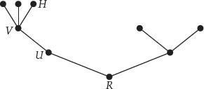

图 2.4 一棵树形九头蛇的例子。

**Figure 2.4.** Example of a tree hydra.

安东尼奥·波拉尤奥洛描绘赫拉克勒斯斩杀九头蛇的画作，见图 2.3，也许戏剧性多于准确性：他怎样砍下蛇头？伊俄拉俄斯又在哪里？不过必须承认，赫拉克勒斯穿着涅墨亚狮皮，确实是一副准备大开杀戒的装束。

The painting of Hercules slaying the hydra by Antonio Pollaiuolo (Figure 2.3) tells the story with perhaps more drama than accuracy—how does he cut off its head? where is Iolaus?—though we must admit that Hercules is dressed to kill in his Nemean lion-skin suit.

英国数学家劳里·柯比和杰夫·帕里斯于 1982 年提出了九头蛇故事的新变体。在他们的版本中，九头蛇形如一棵树，例如图 2.4。树有一个根顶点 R，以及有限多个通过称为边的线段与它相连的顶点。从根到任意其他顶点的边序列，或称分支，都是唯一的。每个末端顶点都是九头蛇的一个头。因此，图 2.4 是一条有五个头的九头蛇。在这个例子中，H 是一个头，经由顶点 V、U 的分支与 R 相连。

A new variation on the hydra story was proposed by the English mathematicians Laurie Kirby and Jeff Paris in 1982. In their version, the hydra is shaped like a *tree*, such as the one in Figure 2.4. The tree has *root vertex R* and finitely many vertices connected to it by lines called *edges.* The sequence of edges, or *branch*, connecting the root vertex to any other vertex is unique. Each end vertex is a *head* of the hydra. Thus Figure 2.4 is a hydra with five heads. In this example, *H* is a head, and *H* is connected to *R* by the branch through the vertices *V* and *U.*

砍掉头 H，就是删去 H 以及连接 H 与相邻顶点 V 的边。与原故事一样，九头蛇立刻长出新头，但遵循以下规则：

A head *H* is cut off by removing it, together with the edge connecting *H* to the neighboring vertex *V.* As in the original story, the hydra immediately grows new heads, but according to the following rules:

1. 新头只从顶点 U 长出；沿着向根 R 下降的路径，U 位于 V 下方一条边处。

   New heads grow only from the vertex *U* one edge below *V* on the path from *U* down to *R.*
2. 若 H 是第 n 个被砍掉的头，就从 U 长出 n 份副本，每份都是砍头后仍留在 U 上方的那一部分九头蛇。

   If *H* is the *n*th head removed, *n* new copies of the decapitated portion of the hydra that remains above *U* grow from *U.*

图 2.5 表示第一次砍头的效果，其中被砍掉的头 H，就是图 2.4 中标出的那个。

Figure 2.5 shows the effect of the first decapitation, in the case where the head *H* removed is the one shown in Figure 2.4.

这个例子说明，砍头之后的新生长很容易增加头的总数。尽管如此，无论赫拉克勒斯怎样砍头，最终都不会剩下任何头。

As this example shows, decapitation followed by new growth can easily increase the total number of heads. Nevertheless, *no matter how Hercules proceeds to cut off heads, eventually no heads remain.*

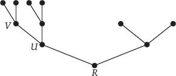

图 2.5 砍掉头 H 后的树形九头蛇。

**Figure 2.5.** Tree hydra after head *H* is removed.

为证明这一点，我们为每棵树指定一个序数 α<ε₀，并证明每次砍头都会得到序数更小的树。成功的关键仍是康托尔标准形。

To prove this, we assign an ordinal *α <* ε<sub>0</sub> to each tree, and show that each decapitation leads to a tree with smaller ordinal. The key to success is again the Cantor normal form.

树的序数按如下方式得到：先给每个头指定 0，再把序数

The ordinal of a tree is obtained by assigning 0 to each head, then assigning the ordinal

$ωα1+ωα2+⋯+ωαk$

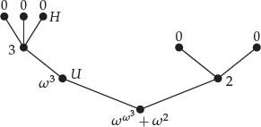

图 2.6 已为各顶点指定序数的树形九头蛇。

**Figure 2.6.** Tree hydra with ordinals assigned.

图 2.7 显示了砍掉头 H 后的序数，假定 H 是第一个被砍掉的头。

Figure 2.7 shows the ordinals after removal of the head *H*, assuming that *H* is the first head removed.

如果 H 是第二个被砍掉的头，那么顶点 U 会长出两棵新子树，而不是一棵，U 所获的序数就是 ω²·3。但即使 U 所获的序数是 ω²·k，也就是说，H 是第 k−1 个被砍掉的头，树的序数仍小于砍掉 H 之前。这是因为对任意有限序数 k，都有 ω²·k<ω³。

If *H* were the second head removed, two new subtrees would grow from the vertex *U* instead of one, and the ordinal assigned to *U* would be *ω*<sup>2</sup> · 3. But even if the ordinal assigned to *U* were *ω*<sup>2</sup> · *k* (that is, if *H* were the *(k* − 1)st head removed), the ordinal of the tree would be less than it was before removal of *H*.This is because *ω*<sup>2</sup> · *k < ω*<sup>3</sup> for any finite ordinal *k.*

读者大概能看出，类似论证使我们能够断定：每砍掉一个头，树的序数总会减小，这里不再详述。关键仍然是，任意下降序数序列都是有限的。因此，有限次砍头之后，就不再剩下任何头。赫拉克勒斯总能消灭九头蛇，无须烧灼伤口！

The reader can probably see that a similar argument allows us to conclude that the ordinal of the tree is *always* decreased when a head is removed, but we will not go into more detail. The point is, as usual, that any decreasing sequence of ordinals is finite. Therefore, after finitely many decapitations, no heads remain. Hercules can always destroy the hydra, with no cauterization necessary!

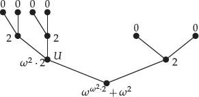

图 2.7 砍掉头 H 后的序数。

**Figure 2.7.** Ordinals after head *H* is removed.

## 2.9 历史背景

## 2.9 Historical Background

### “奇怪的”集合与函数

### “Strange”Sets and Functions

……从逻辑的观点看，恰恰是这些奇怪的函数才是最一般的；那些不经寻找便遇到的函数，如今不过是特殊情形，留给它们的角落已经很小了。

… from the point of view of logic, it is these strange functions that are most general; those that are met without being looked for no longer appear as more than a special case, and they have quite a little corner left them.

——昂利·庞加莱

—Henri Poincaré

《科学与方法》第 II 章，第 5 节。

*Science and Method*, Chapter II, Section 5.

直到 19 世纪，大多数数学家对无限集和无限过程都感到不安，这一点在当时最有影响力的数学家卡尔·弗里德里希·高斯于 1831 年 7 月 12 日致天文学家海因里希·舒马赫的一封信中，表达得很清楚：

Cantor introduced ordinal numbers in 1872 in a study of *Fourier series*, the representation of functions as infinite sums of waves. This idea originated in the mid-18th century, when it was realized that the motion of a vibrating string is a sum of so-called “simple modes,” each in the shape of the sine or cosine wave. Since the string can be set vibrating from a virtually arbitrary shape, it seems to follow that a virtually arbitrary function can be expressed as an infinite sum of sine or cosine functions. In 1808, Joseph Fourier developed an extensive theory of such sums— hence the name “Fourier series”—and gave specific examples, even for *discontinuous* functions.

至于你的证明，我必须首先提出抗议：你把一个无限量当作某种已经完成的东西来使用；这在数学中从来不被允许。无限只是一种说话方式。

One of Fourier’s examples is the “square wave” shown in Figure 2.8, which takes the constant value *π*/4 over the interval *—π*/2 < *x <* π/2, and alternates this value with *— π/*4 over successive intervals of length *π*.

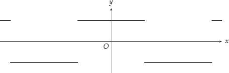

**Figure 2.8.** Square wave function.

在这种观念氛围下，康托尔的工作起初不受欢迎，并不奇怪。令人惊讶的倒是他竟然能完成这项工作。康托尔是在 19 世纪 70 年代研究无穷级数时，对无限产生兴趣的。具体说，他想知道，哪些函数可以表示为如下形式的三角级数，即傅里叶级数：

Fourier showed that this function is the sum of the infinite series<sup>3</sup>

$f(x)=cosx−13cos3x+15cos5x−17cos7x+⋯,$

傅里叶级数以 19 世纪初的法国数学家约瑟夫·傅里叶命名。傅里叶用它们解决热传导问题，但没有给出严格的理论。事实上，严格的傅里叶级数理论，必须等到人们对实数有严格理解之后才可能建立；而这一理解在很大程度上正是由康托尔提供的。

and hence it is the limit (as *n* → ∞) of the continuous functions

$fn(x)=cosx−13cos3x+15cos5x−⋯+(−1)n12n+1cos(2n+1)x.$

当 n→∞ 时，这个函数趋于

Figure 2.9 shows how well *f<sub>n</sub>* approximates the square wave when *n* = 20.

Fourier’s example shows that a function with points of discontinuity may nevertheless have a Fourier series. Cantor wanted to know “how badly” discontinuous a function could be, and still have a Fourier series. First, he needed to know how bad a set of potential points of discontinuity could be.

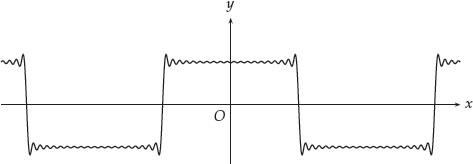

图 2.9 对方波的逼近。

**Figure 2.9.** Approximation to the square wave.

比傅里叶的例子“更糟”的情形，是不连续点本身有极限点。例如，不连续点位于 x=1/2、3/4、7/8、15/16、……时就会如此，这些点的极限是 x=1。更糟的是，还可能出现“极限点的极限点”，因为我们可以在序列 1/2、3/4、7/8、15/16、……的每一项之前插入一个无限序列。例如，插入

显然，这种插入过程，即使集合中的任意一点成为新集合的极限点，可以重复一次、两次、……、任意有限多次。因此，若反过来进行，删去所有不是极限点的点，那么在集合变空之前，这个删除过程可能发生任意有限多次。再把插入过程重复一次、两次、……所得的结果串接起来，就能构造一个只有无限次重复删除过程后才会变空的集合。

Clearly, this insertion process—making any point of a set a limit point of a new set—may be repeated once, twice, …, any finite number of times. So, if we take the *reverse* process of *removing all points that are not limit points*, the removal process may occur any finite number of times before the set is emptied. Then, by stringing together the results of one, two, …repetitions of the insertion process, we can create a set that is emptied only by *infinitely many* repetitions of the removal process.

而这仍不是最糟的情形。无限次重复删除过程之后，还可能剩下 1/2、3/4、7/8、15/16；此时还需再删除一次非极限点，集合才会变空。康托尔就是这样认识到，必须能够“越过无限继续计数”。这就是他发明超限序数的背景。

And this is still not the worst that can happen. After infinitely many repetitions of the removal process we may be left with 1/2, 3/4, 7/8, 15/16, in which case we need one more removal of non-limit points to empty the set. This is how Cantor came to realize that it is necessary to be able to “count past infinity.” It was the setting for his invention of transfinite ordinal numbers.

沿着这一思路，康托尔瞥见了集合与函数的广阔新世界；此时，傅里叶级数问题似乎不那么重要了。既然绝大多数函数都不连续，如何以自然方式分类函数，反而成为一个有趣的问题。这个问题同样通向超限序数。

Once Cantor glimpsed the vast new world of sets and functions brought to light by this train of thought, the question of Fourier series seemed less important. Instead, given that the overwhelming majority of functions are not continuous, it became an interesting question to *classify* functions in a natural way. This question, too, leads to transfinite ordinals.

1900 年前后，在法国数学家勒内-路易·贝尔、埃米尔·博雷尔和昂利·勒贝格的引领下，从分析学通往超限序数的道路变得人来人往。他们都在 19 世纪 90 年代成长为数学家。与本节开头引用的年长同胞昂利·庞加莱不同，他们欢迎极限过程产生的“奇怪”函数。

The road from analysis to transfinite ordinals became well-traveled around 1900, following the lead of the French mathematicians René-Louis Baire, Émile Borel, and Henri Lebesgue, all of whom came of age in the 1890s. Unlike their older compatriot Henri Poincaré, quoted at the beginning of this section, they welcomed the “strange” functions generated by the limit process.

他们认为，既然分析学建立在极限与连续函数之上，就应该研究从连续函数出发、通过取极限所能得到的一切函数。贝尔于 1898 年提出这种理解函数概念的方式。从他的观点看，许多此前被视为“奇怪”的函数，都显得相当简单自然。例如所谓狄利克雷函数，贝尔本人就考虑过它：

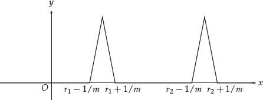

图 2.10 当 m→∞ 时以 d₂ 为极限的“双尖峰”函数 d₂ₘ。

**Figure 2.10.** “Double-spike” function *d*<sub>2</sub>*<sub>m</sub>* that has limit *d*<sub>2</sub> as *m* → *∞*.

狄利克雷函数在每一点 x 都不连续。然而，d 是一列仅有“轻微”不连续性的函数的极限。若把有理数枚举为 r₁、r₂、r₃，那么 d(x) 就是下列函数在 n→∞ 时的极限：

其中每个函数都只在有限多个点 r₁、r₂、……、rₙ 处不连续。而每个 dₙ 又都是一列连续函数的极限。图 2.10 说明了 n=2 时的情形。

each of which is discontinuous only at the finitely many points *r*<sub>1</sub>, *r*<sub>2</sub>, …,*r<sub>n</sub>*.And each *d<sub>n</sub>*, in turn, is the limit of a sequence of *continuous* functions. Figure 2.10 shows why, in the case *n* = 2.

函数 d₂(x) 在 x=r₁、r₂ 时取值 1，其余各处取值 0；它是 m→∞ 时具有以下性质的“双尖峰”函数 d₂ₘ(x) 的极限：

The function *d*<sub>2</sub>(*x*), which has value 1 for *x = r*<sub>1</sub>, *r*<sub>2</sub> and 0 otherwise, is the limit as *m* → *∞* of “double-spike” functions *d*<sub>2</sub>*<sub>m</sub>*(*x*),with the properties

- d₂ₘ(x) 在 x=r₁、r₂ 时等于 1。

当 m→∞ 时，“尖峰”的宽度缩小到零，只留下 x=r₁、r₂ 处 d₂(x)=1，其余各处的值均为 0。类似地，dₙ 是连续的“n 重尖峰”函数的极限。

The “spikes” shrink to zero width as *m* → ∞,leaving the values *d*<sub>2</sub>(*x*) *=* 1 for *x = r*<sub>1</sub>, *r*<sub>2</sub>, and value 0 everywhere else. Similarly, *d**<sub>n</sub>* is the limit of continuous “*n*-tuple-spike” functions.

因此，在一个可能具有无限多个层级的函数层级结构中，狄利克雷函数距离连续函数只有两层。事实上，勒贝格于 1905 年证明，贝尔函数层级对每个可数序数 α 都有一个 α 层。第零层由连续函数组成，α+1 层由 α 层函数的极限组成。一个对角线论证表明，α+1 层包含不在 α 层中的函数。若 λ 为极限序数，则 λ 层的函数是所有低于 λ 层的函数。

Thus the Dirichlet function is only two levels away from the continuous functions, in a hierarchy of functions that probably has infinitely many levels. In fact, Lebesgue showed in 1905 that the Baire hierarchy of functions has a level *α* for each countable ordinal α.Level zero consists of the continuous functions, and level *α +* 1 consists of the limits of functions at level *α*. A diagonal argument shows that level *α +* 1 includes functions *not* at level *α.* If *λ* is a limit ordinal, then the functions at level *λ* are all those at levels less than *λ*.

与此同时，从 1898 年的《函数论讲义》开始，博雷尔一直在研究如何度量实数集的问题。最简单的实数集是开区间

这些区间，以及相应的闭区间 [a,b]={x:a≤x≤b}，其测度为 b−a，也称为长度。端点相同的开区间和闭区间长度相同，因为一个点的长度为零。现在可以用下面的规则，为许多其他实数集定义长度：

These, and the corresponding *closed intervals* [*a, b*] *=* {*x* : *a ≤ x ≤ b*}, have measure *b* − *a* (also called their *length*). Open and closed intervals with the same endpoints have the same length because a point has length zero. Length can now be defined for many other sets of reals by the following rules:

- 可数可加性：若 S₁、S₂、S₃、……是两两不交的集合，长度分别为 l₁、l₂、l₃、……，则 S₁∪S₂∪S₃∪⋯ 的长度为 l₁+l₂+l₃+⋯。

  *Countable additivity:* If *S*<sub>1</sub>, *S*<sub>2</sub>, *S*<sub>3</sub>,… are disjoint sets of length *l*<sub>1</sub>, *l*<sub>2</sub>, *l*<sub>3</sub>,… respectively, then the length of *S*<sub>1</sub> ⋃ *S*<sub>2</sub> ⋃ *S*<sub>3</sub> ⋃ ⋯ is *l*<sub>1</sub> *+ l*<sub>2</sub> *+ l*<sub>3</sub> + ⋯.
- *Difference:* If sets *S*<sub>1</sub> and *S*<sub>2</sub> have lengths *l*<sub>1</sub> and *l*<sub>2</sub> respectively, and *S*<sub>2</sub> is a subset of *S*<sub>1</sub>, then the length of the *set difference*

  $S1−S2={ x:x is in S1 but not in S2 }$

  为 l₁−l₂，前提是 l₁ 不等于 ∞。

  is *l*<sub>1</sub> − *l*<sub>2</sub> (provided *l*<sub>1</sub> is not ∞).

可数可加性蕴含，任意可数点集的长度为 0+0+0+⋯=0；这与第 1.5 节中用来说明实数不止可数多个的论证一致。

Countable additivity implies that the length of any countable set of points is 0 + 0 + 0 + ⋯ = 0, which agrees with the argument we used in Section 1.5 to show that there are more than countably many reals.

这两条规则确定了一个极大的集合族的测度，这些集合如今称为实数的博雷尔集。事实上，博雷尔集就是从开区间通过可数并与集合差所能得到的所有集合。可数并不必互不相交，因为博雷尔集的任意可数并，都等于一些仍为博雷尔集的集合的不交可数并。同样，差集总可以相对于全体实数集 ℝ 来取，因为 ℝ 是开区间的可数并。

The two rules determine measure for a very large collection of sets, now known as the *Borel sets* (of reals). The Borel sets in fact are all sets obtainable from open intervals by countable unions and set difference. The countable unions need not be disjoint, because any countable union of Borel sets equals a disjoint countable union of sets that are also Borel. Likewise, difference can always be taken relative to the set R of all real numbers, because R is a countable union of open intervals.

正如贝尔函数的低层级中会出现某些“奇怪的函数”，博雷尔集的低层级中也会出现某些“奇怪的集合”。例如，有理数集是点的可数并，而一个点可以写成 ℝ 减去开区间的某个可数并。在勒贝格 1905 年证明贝尔函数形成层级的论文中，他也证明了博雷尔集形成类似层级，每个可数序数层级上都有成员。勒贝格还证明，博雷尔集恰好就是那些特征函数

Just as some “strange functions” turn up at low levels among the Baire functions, some “strange sets” turn up at low levels in the Borel sets. The set of rational numbers, for example, is a countable union of points, and a point is ℝ minus a countable union of open intervals. In Lebesgue’s 1905 paper in which the Baire functions are shown to form a hierarchy, the Borel sets are shown to form a similar hierarchy with members at all countable ordinal levels. Lebesgue also showed that the Borel sets are precisely the sets *S* of reals for which the *characteristic function* of *S*,

$charS(x)={ 1 if x is in S,0 if x is not in S,$

为贝尔函数的实数集 S。我们已经见过博雷尔集与贝尔函数之间这种对应的例子：狄利克雷函数就是有理数集的特征函数。

is a Baire function. We have already seen an example of this correspondence between Borel sets and Baire functions: the Dirichlet function is the characteristic function of the set of rational numbers.

### 选择公理

### The Axiom of Choice

我将在以后的一篇文章中讨论这样一条思维法则：任何定义明确的集合，总能被整理为良序集的形式。在我看来，这条法则是根本性的、意义重大的，而且其普遍有效性十分惊人。

In a later article I shall discuss the law of thought that says that it is always possible to bring any *well-defined* set into the form of a *well-ordered* set—a law which seems to me fundamental and momentous and quite astonishing by reason of its general validity.

— Georg Cantor (1883),

in Ewald (1996), volume II, p. 886.

The axiom of choice concerns the ability to make infinitely many choices, which was often assumed to be possible in the early days of set theory. For example, Cantor in 1895 offered the following argument in support of the claim that *every infinite set has a countable subset.*

看起来，任何涉及无限的论证都不能幸免于 AC。甚至序列的极限也不例外，尽管它在 19 世纪已被澄清。1872 年，德国数学家爱德华·海涅指出，函数 f(x) 的连续性，可以通过收敛到 x 的序列 x₁、x₂、x₃、……来定义：f 在 x 处连续，当且仅当对任意这样的序列，函数值序列 f(x₁)、f(x₂)、f(x₃)、……都收敛到 f(x)。然而，要证明这个定义与通常的连续性定义等价，竟然需要 AC。

Suppose that *X* is an infinite set. Choose a member *x*<sub>1</sub> of *X*.Then *X* − {*x*<sub>1</sub>} is also infinite, so we can choose one of its members, *x*<sub>2</sub>. Likewise, *X* − {*x*<sub>1</sub>, *x*<sub>2</sub>} is infinite, so we can choose one of its members, *x*<sub>3</sub>,.. .and so on. Thus *X* has a countable subset {*x*<sub>1</sub>, *x*<sub>2</sub>, *x*<sub>3</sub>,…}.

证明中需要 AC 的地方如下。假设 f(x) 按通常定义在 x=a 处不连续。这意味着存在 ε>0，使得任意接近 a 的某些 x，都有 f(x) 与 f(a) 相差至少 ε。也就是说，对每个正整数 n，都有某个 xₙ 满足 |xₙ−a|<1/n，且 |f(xₙ)−f(a)|≥ε。因此，xₙ 收敛到 a，但 f(xₙ) 不收敛到 f(a)，这就证明 f 按序列定义也不连续。但请注意：要得到这样一个序列，必须为每个 n 选取一个 xₙ。

Few people doubt that “and so on” makes sense here, even though no rule for choosing has been given. However, the idea of making infinitely many choices is harder to accept when uncountably many choices are required—as when Hardy assumed the possibility of choosing an increasing sequence *β*<sub>1</sub> *< β*<sub>2</sub> *< β*<sub>3</sub> *<* with limit *α* for each countable limit ordinal *α* (Section 2.3). And it becomes a real article of faith that there is afunction *F* that chooses a real number *F*(*X*) from each nonempty set *X* of real numbers.<sup>4</sup>

这样的例子使恩斯特·策梅洛于 1904 年认识到，需要一条选择公理。集合论学家和逻辑学家尝试过各种等价表述，最后确定为第 2.3 节给出的表述：对任意由集合 S 组成的集合 X，存在一个函数 F，使每个非空 S 的 F(S) 都属于 S。策梅洛（1904）证明选择公理蕴含每个集合都可以良序化，引起轰动。康托尔于 1883 年就提出任意集合都存在良序，但只把它视为一条希望日后再讨论的“思维法则”。他并未做到。策梅洛的证明却把良序化归结为一条更“显然”，或至少更简单的公理，彻底改变了集合论的面貌。

Examples like these brought Ernst Zermelo to the realization, in 1904, that an axiom of choice was needed. Set theorists and logicians experimented with various equivalent statements of the axiom, before settling on the statement given in Section 2.3: *for any set X of sets S, there is a function F such that F*(*S*) *belongs to S for each nonempty S.* Zermelo (1904) created a sensation by showing that *the axiom of choice implies that every set can be well ordered.* The existence of a well-ordering for any set had been proposed by Cantor in 1883, but only as a “law of thought” that he hoped to return to later. This did not happen. Instead, Zermelo’s proof completely changed the complexion of set theory by reducing well-ordering to a more “obvious,” or at least more simple, axiom.

借助第 1.8 节描述的策梅洛–弗兰克尔公理，良序定理本身的证明几乎可以变得显然。事实上，策梅洛提出公理，不仅为了避免悖论，也为了澄清良序定理的证明。假设要把集合 X 良序化。这相当于依次把序数 0、1、2、……分配给 X 的元素，直到耗尽 X。事实上，这基本上就是证明！再说一遍：把序数分配给 X 的元素，直到耗尽 X。稍详细地说，我们用归纳定义的函数 f，把序数 0、1、2、……、α、……“分配”给 X 的元素：

With the help of the Zermelo-Fraenkel axioms described in Section 1.8, the proof of the well-ordering theorem itself can be made almost obvious. (Indeed, Zermelo’s axioms were intended not only to avoid paradoxes, but also to clarify the proof of well-ordering.) Suppose we want to wellorder a set X. This amounts to assigning ordinals 0,1,2,… to members of *X*, until *X* is exhausted. In fact, that is basically the proof! I repeat: *assign ordinals to members of X until X is exhausted.* In a little more detail, we “assign” ordinals 0,1,2,…, α,… to members of *X* by a function *f* defined inductively by

$f(0)=choose(X)f(β)= choose (X−{ values f(α) for α<β})$

其中 choose(S) 是 X 的子集 S 的一个选择函数。这样 X 就会被“耗尽”，因为若 β 是所有使 f(α) 有定义的序数 α 的最小上界，那么 X−{f(α) 的值：α<β} 必定为空。

where choose(*S*) is a choice function for the subsets *S* of X.Then *X* is “exhausted” because, if *β* is the least upper bound of the ordinals *α* for which *f* (*α*) is defined, then *X* − {values *f* (*α*) for *α < β*} is necessarily empty.

因此，选择公理确实给数学带来了秩序：它保证集合可以良序化，也保证序列连续的函数是连续的。然而，在某些特殊地方，选择公理反而带来了无序。测度论就是一例。

Today, most mathematicians have embraced the axiom of choice because of the order and simplicity it brings to mathematics in general. For example, the theorems that every vector space has a basis and every field has an algebraic closure hold only by virtue of the axiom of choice. Likewise, for the theorem that every sequentially continuous function is continuous. However, there are special places where the axiom of choice actually brings *dis*order. One is the theory of measure.

如上一小节所述，博雷尔（1898）把长度概念从直线上的区间推广到庞大的博雷尔集族。1902 年，勒贝格把这个概念推广到了尽可能广的范围，即所谓勒贝格可测集。从某种意义上说，这一推广很小，因为每个勒贝格可测集都只与某个博雷尔集相差一个零测集。另一方面，博雷尔集的数量只与实数一样多，而勒贝格可测集的数量却与实数的子集一样多。取决于愿意在 ZF 之外接受哪些假设，勒贝格测度事实上可能推广到所有实数集。但若选择公理成立，就存在非勒贝格可测的实数集。

As mentioned in the previous subsection, Borel (1898) extended the concept of length from intervals of the line to the vast collection of Borel sets. In 1902, Lebesgue extended the concept as far as it can go, to what are called the *Lebesgue measurable* sets. In one sense, the extension is small, because every Lebesgue measurable set differs from a Borel set by a set of measure zero. On the other hand, the Borel sets are only as numerous as the real numbers, whereas the Lebesgue measurable sets are as numerous as the *sets* of real numbers. Depending on what one is willing to assume beyond ZF, Lebesgue measure may in fact extend to all sets of real numbers. But if the axiom of choice holds there are sets of reals that are *not* Lebesgue measurable.

意大利数学家朱塞佩·维塔利于 1905 年发现了这一点，令博雷尔、贝尔、勒贝格以及过去一些其他杰出分析学家开始怀疑选择公理。关于选择公理引发的分析学危机，详见 Moore（1982）。

This was discovered by the Italian mathematician Giuseppe Vitali in 1905, and it led to doubts about the axiom of choice on the part of Borel, Baire, Lebesgue, and some other distinguished analysts of the past. (For more on the crisis in analysis precipitated by the axiom of choice, see Moore (1982).)

维塔利不可测集

Vitali’s nonmeasurable set

最好把这个集合看作圆周的一个子集 X，它具有以下两个性质：

This set is best viewed as a subset *X* of the circle with the following two properties:

- 把 X 旋转角度 2πr，其中 r 为有理数，所得集合 Xᵣ 与 X 不相交，或者等于 X。

  When *X* is rotated by an angle 2*πr*,where *r* is rational, the resulting set *X<sub>r</sub>* is disjoint from *X* or equal to *X*.
- 这些无限多个集合 Xᵣ 填满整个圆周。

  The (infinitely many) sets *X<sub>r</sub>* fill the circle.

由这些性质可知，X 不可能有测度 m>0。否则，每个旋转后的集合 Xᵣ 都有相同测度 m，由可数可加性，圆周的测度将是 m+m+m+⋯=∞。但 X 同样不可能有零测度，否则圆周的测度就是 0+0+0+⋯=0。因此，具有这两个性质的集合不可测。借助选择公理可以找到这样的集合。最简单的方法，是把圆周看作 0 到 2π 的角度集，并把它分成形如下式的集合：

It follows from these properties that *X* cannot have measure *m >* 0. If it did, each rotated set *X<sub>r</sub>* would then have the same measure m,and the measure of the circle would be *m + m + m +* ⋯ *= ∞* by countable additivity. But *X* likewise cannot have measure zero, otherwise the measure of the circle would be 0 *+* 0 *+* 0 *+* ⋯*=* 0. Thus a set with these two properties is not measurable. We find such a set with the help of the axiom of choice. The simplest way is to view the circle as the set of angles from 0 to 2*π* and to partition it into sets of the form

$Sθ={ angles θ+2πr, where r is rational }.$

然后从每个不同的 Sθ 中选取一个元素，就得到合适的 X。注意，不能简单地从 Sθ 中选 θ！无限多个不同的 θ 值会给出同一个 Sθ，而其中只能选一个值放入 X。

Then a suitable *X* is obtained by choosing one member from each distinct *S<sub>θ</sub>*. (Beware of simply choosing *θ* from *S<sub>θ</sub>* !The sets *S<sub>θ</sub>* are the *same* for infinitely many values of *θ*, and just one of these values must be chosen to go in *X.*)

维塔利的结果，是一系列利用选择公理得到的、越来越违反测度直觉的结果中的第一个；这一系列最终达到巴拿赫和塔尔斯基（1924）所谓的“悖论”。后者把单位球分解成有限多个集合，移动这些集合的位置后，就能填满两个实心球。分解所得的集合，只有凭借选择公理才存在。即使采用有限可加测度，也无法“度量”它们，否则就会推出 1=2。Wagon（1993）对巴拿赫–塔尔斯基悖论有精彩的现代介绍。

Vitali’s result was the first in a series of increasingly counterintuitive results on measure obtained by use of the axiom of choice, culminating in the so-called “paradox” of Banach and Tarski (1924). The latter result is a decomposition of the unit ball into finitely many sets which, when moved to different positions, fill *two* solid balls. The sets into which the ball is decomposed exist only by virtue of the axiom of choice. They cannot be “measured” even by a *finitely* additive measure, as this would imply 1 = 2. There is an excellent modern account of the Banach-Tarski paradox in Wagon (1993).

因此，使用选择公理也有代价。如果愿意放弃它，那么事实上可以相容地假设所有实数集都是勒贝格可测的，前提是假设 ZF 加上一个“不可达基数”相容，参见第 7 章。美国数学家罗伯特·索洛维于 20 世纪 60 年代证明了这个惊人结果。它属于集合论新一波浪潮的一部分，揭示了实数究竟有多么深奥神秘。

Thus, there is a downside to using the axiom of choice. If one is willing to abandon the axiom, then in fact it is consistent to assume that all sets of real numbers are Lebesgue measurable (assuming the consistency of ZF plus an “inaccessible cardinal”—see Chapter 7). This astonishing result was proved by the American mathematician Robert Solovay in the 1960s. It was part of a new wave of set theory that revealed just how deeply mysterious the real numbers are.

### 连续统假设

### The Continuum Hypothesis

由这个定理将立刻推出，连续统的基数是可数集基数之后的下一个基数；因此，这个定理的证明将在可数集与连续统之间架起一座新的桥梁。

From this theorem it would follow at once that the continuum has the next cardinal number beyond that of the countable set; the proof of this theorem would, therefore, form a new bridge between the countable set and the continuum.

——大卫·希尔伯特，1900 年《数学问题》演讲，见 Ewald（1996），第 II 卷，第 1103 页。

—David Hilbert, Address on *Mathematical Problems*, 1900, in Ewald (1996), volume II, p. 1103.

连续统假设的后一个版本，即 CH，要强得多，因为它蕴含 ℝ 可以良序化。正如所见，康托尔于 1883 年相信任意集合都可以良序化，但尚未意识到需要选择公理。

The latter version of the continuum hypothesis (CH) is much stronger, because it implies that ℝ can be well-ordered. As we have seen, Cantor in 1883 believed that any set can be well-ordered, but he was not yet aware of the need for the axiom of choice.

直到 1891 年发现一般的对角线论证，康托尔才意识到存在比 ℝ 更大的集合。因此，他把 CH 视为集合论的终极问题，是可以理解的。即使发现了更高的无限，CH 仍居首位。1900 年，德国数学家大卫·希尔伯特为 20 世纪数学家提出 23 个问题时，CH 排在第一。策梅洛于 1904 年证明良序定理，在一定程度上缓解了人们对 ℝ 能否良序化的担忧，但似乎无助于解决连续统问题。贝尔、博雷尔和勒贝格发起的对实数集的细致研究与分类，也没有解决它。最后，希尔伯特本人在 1926 年题为《论无限》的论文中提出了一个想法。

Until he discovered the general diagonal argument, in 1891, Cantor did not realize that there were sets larger than R. So he understandably viewed CH as the ultimate question in set theory. It remained on top even after Cantor’s discovery of higher infinities. In 1900, when the German mathematician David Hilbert proposed 23 problems for the mathematicians of the 20th century, CH was number one on his list. Zermelo’s proof of the well-ordering theorem, in 1904, eased the concern about well-ordering R to some extent, but it did not seem to help settle the continuum problem. Nor did the detailed investigation and classification of sets of real numbers initiated by Baire, Borel, and Lebesgue. Finally, Hilbert himself put forward an idea in a 1926 paper entitled *Über das Unendliche* (“On the Infinite”).

希尔伯特（1926）的想法，是把可数序数与正整数函数联系起来。正如第 1.7 节所见，这些函数与实数一一对应。但他并未把序数与函数本身对应，而是与某种语言中描述函数的公式对应。那种语言本身没有解释清楚；函数通过序数定义，而序数又通过函数定义，似乎陷入循环。因此，希尔伯特的“证明”不能令人信服。不过，其中包含一个好得多的思想的萌芽，库尔特·哥德尔于 1938 年成功运用了它，详见 Gödel（1939）或 Cohen（1966），第 87–99 页。

The idea of Hilbert (1926) was to correlate countable ordinals with positive integer functions (which, as we saw in Section 1.7, are in one-to-one correspondence with the real numbers). However, he did not correlate ordinals with functions but rather with *formulas describing functions* in a certain language. The language itself is not clearly explained; functions are defined in terms of ordinals which are defined in terms of functions, in seemingly circular fashion. So Hilbert’s “proof” is unconvincing. Nevertheless, it contains the germ of a much better idea, used successfully by Kurt Gödel in 1938 (see Gödel (1939) or Cohen (1966), p. 87–99, for details).

哥德尔的思想，是构造一个集合论模型，由包含所有序数、并满足第 1.8 节列出的策梅洛–弗兰克尔集合公理的最小集合总体 L 组成。因此，L 包含空集；只要 X、Y 属于 L，无序对 {X,Y} 也属于 L；依此类推。不过，稍微呼应希尔伯特的思想，若集合 X 属于 L，那么 L 中 X 的子集，只限于那些能用某种语言定义的子集。哥德尔与希尔伯特的关键区别，是他不试图给序数命名，从而避免循环。他把序数视为给定，在以序数编号的各阶段，从空集开始，用先前已定义的集合定义新集合。L 称为可构造集的类。

Gödel’s idea is to build a *model of set theory* consisting of the smallest collection *L* of sets that includes all the ordinals and satisfies the Zermelo-Fraenkel axioms for sets enumerated in Section 1.8. Thus, *L* includes the empty set; along with any two members *X* and *Y, L* includes the unordered pair {*X*, *Y*}; and so on. However, in a faint echo of Hilbert, the only *subsets* in *L* of a set *X* in *L* are those *definable* in a certain language. The key difference between Hilbert and Gödel is that Gödel avoids circularity by *not* attempting to name the ordinals. Instead, he takes the ordinals as given and defines sets in terms of previously-defined sets (starting with the empty set) in ordinal-numbered stages. *L* is called the class of *constructible* sets.

L 是对所有序数 α 的集合 Lα 取并所得：L₀ 为空集；Lα₊₁ 由 Lα 的所有可定义子集组成，定义使用 ZF 语言，并允许用名称指称 Lα 的元素；对极限序数 β，Lβ 是所有 α<β 的 Lα 的并。这一构造得到如下结果。

- *L* satisfies all the Zermelo-Fraenkel axioms (ZF). Also, *L* is well-ordered, via a well-ordering of definitions.

  这一点是可信的，因为 ZF 语言中的公式只有可数多个，参见第 2.2 节关于列举字母串的说明，因此 ZF 公式可以良序化。诚然，可以把序数以及 Lβ 中的其他集合代入 ZF 公式，以定义 Lα 中的集合，但 Lα 的归纳构造保证所得定义也能良序化。因此，L 中每个集合都由公式的良序得到良序。更微妙的是，这个良序本身也是 L 中的集合。正因为如此，L 满足良序定理，从而满足选择公理。

L 的这些性质并不证明 CH 对一般的集合为真。但它们表明 CH 不能被反驳，因为 L 同时满足 ZF 与 CH。更精确地说，如果一般的集合满足 ZF，那么 L 中这些特定集合就满足 ZF 加 CH。换句话说，如果 ZF 相容，那么 ZF 加 CH 也相容。这就是哥德尔如何得到第 2.4 节提到的证明：CH 不能被通常的集合论公理反驳。

These properties of *L* do *not* prove that CH is true for sets in general. But they show that *CH cannot be disproved,because L* satisfies both ZF and CH. More precisely, if sets in general satisfy ZF, then the particular sets in *L* satisfy ZF plus CH. Or again, *if ZF is consistent, then so is ZF plus CH.* This is how Gödel came up with his proof, mentioned in Section 2.4, that CH cannot be disproved by the usual axioms of set theory.

第 2.4 节也提到，科恩证明 CH 不可证，使用的是一个 CH 为假的 ZF 模型。他借助称为力迫法的卓越创新构造这种模型，力迫法允许构造极其多样的 ZF 模型。为构造 CH 为假的模型，他先把哥德尔的 L 缩减为一个可数模型 M；L 包含所有序数，因此高度不可数。这之所以能做到，实质上是因为 ZF 语言只有可数多个公式。由于 M 只包含可数多个整数集，就有空间把许多新的整数集 S₁、S₂、……重新加入 M。若极其巧妙地操作，就能得到一个满足 ZF，也满足 AC，却不满足 CH 的模型 M(S₁,S₂,……)。因此，即使加入 AC，连续统假设也不能从 ZF 公理证明，除非 ZF 本身不相容。

Cohen’s proof that CH cannot be proved, also mentioned in Section 2.4, involves a model of ZF in which CH is false. Cohen built such a model with the help of his brilliant innovation called *forcing*, that allows the construction of extremely varied models of ZF. To build a model in which CH is false he first cut down Gödel’s *L*, which includes all the ordinals and hence is highly uncountable, to a *countable* model *M*. This can be done, essentially, because there are only countably many formulas in the language of ZF. Since *M* includes only countably many sets of integers, there is room for many new sets of integers *S*<sub>1</sub>, *S*<sub>2</sub>,… to be put back into *M.* When this is done very cleverly, one can obtain a model *M*(*S*<sub>1</sub>, *S*<sub>2</sub>,…) of ZF (and also AC) that does *not* satisfy CH. Thus *the continuum hypothesis cannot be proved* from the ZF axioms, even when AC is added (unless ZF itself is inconsistent).

### 力迫法

### Forcing

力迫法过于专门，无法在这里描述，但不能忽视它的重要性。20 世纪 60 年代集合论的大多数新发现都由它促成，例如索洛维关于“所有实数集都可测”这一假设的相容性定理。力迫法彻底改变了集合论的面貌：它表明，ZF 中大多数有趣的未证语句，若不增加新公理，就既不能证明，也不能反驳。

The technique of forcing is too technical to describe here, but we cannot ignore how important it has been. It led to most of the 1960s revelations in set theory, such as Solovay’s theorem on the consistency of assuming that all sets of real numbers are measurable. Forcing completely changed the face of set theory by showing that *most of the interesting unproved sentences of ZF can be neither proved nor disproved without new axioms.*

索洛维的结果是许多结果之一，它们表明，假设 ZF 相容，就可以相容地假设 AC 为假。因此，虽然由哥德尔关于 L 的结果可知，AC 不能从 ZF 公理反驳，但它同样不能被证明。ZF 的不可判定语句，不仅包括完整的选择公理，也包括本章前面涉及的许多特殊情形。特别是，力迫法可以得到具有以下性质的 ZF 模型，因此这些性质在 ZF 中不可反驳：

Solovay’s result is one of many showing that it is consistent to assume that AC is false, assuming that ZF is consistent. Thus, while AC cannot be disproved from the ZF axioms (by Gödel’s result about *L*), it cannot be proved either. The undecidable sentences of ZF include not only the full axiom of choice, but also many special cases of it that we touched on earlier in this chapter. In particular, forcing can be used to obtain models of ZF with the following properties, which are therefore not disprovable in ZF:

- 存在一个没有可数子集的无限集。

  There is an infinite set with no countable subset.
- 存在一个序列连续却不连续的函数。

  There is a sequentially continuous function that is not continuous.
- ℝ 是可数多个可数集的并。

  R is a countable union of countable sets.

这些性质都与 AC 矛盾，因此它们在 ZF 中也不可证。

These properties all contradict AC, so they are not provable in ZF either.

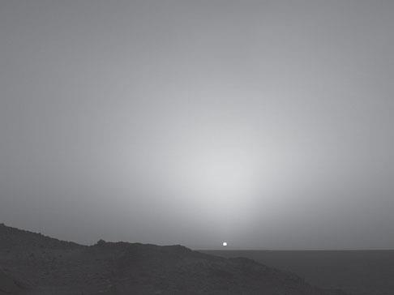

图 2.11 日落还是日出？

**Figure 2.11.** Sunset or sunrise?

2007 年 9 月 29 日，斯坦福大学举行纪念保罗·科恩的会议。休·伍丁这样描述科恩的发现：这确实是集合论的终结，或者确实是它的开端，而我们还不知道究竟是哪一个。随后，伍丁展示了一张异星景观照片，即 NASA 拍摄的火星照片，见图 2.11；其中太阳似乎正在落下，也可能正在升起，无法分辨。

At a conference in memory of Paul Cohen at Stanford on September 29, 2007, Hugh Woodin described Cohen’s discovery by saying: *It is really the end of set theory, or else really the beginning—and we do not yet know which.* Woodin then displayed a photo of an alien landscape (a NASA photo of Mars, Figure 2.11) in which the sun appears to set, or rise—and one cannot tell which.

我们也许永远无法理解连续统；也许能够理解，但必须借助新公理，伍丁持乐观态度。无论如何，康托尔的两大思想，即对角线论证与序数，即使在正整数层面，也为数学带来了新的光明。在那里，通常的公理同样不足以解决所有问题。本书余下各章将转向这些发展。

It may be that we can never understand the continuum; it may also be that we *can* understand the continuum, but only by new axioms (Woodin takes the optimistic view). Be that as it may, the two great ideas of Cantor—the diagonal argument and the ordinals—have thrown new light on mathematics even at the level of positive integers. There too, the usual axioms are not sufficient to settle all questions. We turn to these developments in the remaining chapters of the book.

1 由于 ℵ₁ 是良序集，这个等式蕴含实数可以良序化。正如所见，单是这一点就是一个微妙的问题。康托尔于 1878 年首次表述连续统问题时，避免了必须判定实数能否良序化的问题。他只是问：每个无限实数集，是否都能与 ℵ₀ 或连续统建立一一对应。

2 此外，402653211=3·2²⁷+27。这是我从 2007 年 Mathcamp 的两位学生 David Field 和 Jeremiah Siochi 那里得知的，他们计算了古德斯坦过程的这一情形。

Also, 402653211 = 3 · 2<sup>27</sup> + 27. I learned this from two students at Mathcamp 2007, David Field and Jeremiah Siochi, who worked out this case of the Goodstein process.

4 尽管难以想象这样的函数，分析学在集合论出现之前就已经使用了等价假设。例如，1872 年康托尔曾证明，若函数 f 是序列连续的，它就是连续的。所谓 f 在 x=a 处序列连续，是指对任意趋于 a 的序列 a₁、a₂、……，f(aₙ) 都趋于 f(a)。这个证明又一次无意识地使用了选择公理。

Notwithstanding the difficulty in imagining such a function, equivalent assumptions were made in analysis before the emergence of set theory. For example, in 1872, Cantor offered a proof that a function *f* is continuous if it is *sequentially continuous.* One says that *f* is sequentially continuous at *x = a* if *f* (*a<sub>n</sub>*) tends to *f* (*a*) for any sequence *a*<sub>1</sub>, *a*<sub>2</sub>,… that tends to *a.* The proof involves another unconscious use of the axiom of choice.

# 第 3 章 可计算性与证明

# - Chapter 3 - Computability and Proof

## 概览

## Preview

数学中的可计算性概念源于证明概念。1900 年前后，数学基础中的困难促使人们要求建立形式化的证明概念：按照完全明确的推理规则，从公理推导定理。这些规则应当直接作用于符号串，无须有意识的干预，因此，形式系统就是通过计算来证明定理的一种过程。

The concept of computability emerged in mathematics from the concept of *proof.* Around 1900, difficulties in the foundations of mathematics led to the demand for a *formal* concept of proof, in which theorems are derived from axioms by completely explicit rules of inference. The rules are supposed to operate on strings of symbols without the need for conscious intervention, so a *formal system* is a process for proving theorems by computation.

这意味着形式系统本身也是数学结构，我们可以证明关于它们的定理。这类定理中最著名的是哥德尔第一不完备性定理：任何一致的算术形式系统，都有某些真语句无法证明。一个非凡而令人震惊的推论是哥德尔第二不完备性定理：一个“足够强”的算术形式系统能够表达自身的一致性，却不能证明这种一致性，除非该系统本身不一致。

This means that formal systems are themselves mathematical structures, about which theorems can be proved. The most famous theorem of this type is *Gödel’s first incompleteness theorem*, stating that any consistent formal system for arithmetic fails to prove some true sentences. A remarkable (and shocking) consequence is Gödel’s *second incompleteness theorem*, according to which a “sufficiently strong” formal system for arithmetic can express its own consistency, but cannot prove it (unless the system is inconsistent).

哥德尔于 1930 年证明了这些定理，当时他并不知道，埃米尔·波斯特早已发现形式系统的一般定义及相应的一般不完备性定理。直到 20 世纪 30 年代丘奇和图灵重新发现可计算性之后，它在逻辑中的作用才变得清楚并得到普遍接受。

Gödel proved his theorems in 1930, unaware that a general definition of formal system, and a corresponding general incompleteness theorem, had already been discovered by Emil Post. The role of computability in logic did not become clear, or generally accepted, until it was rediscovered by Church and Turing in the 1930s.

可计算性的一般定义还使我们能够讨论任意算法，并证明某些问题不存在求解算法。这些不可解问题包括：判定哪些计算机程序最终会停机，以及判定哪些算术或逻辑语句为真。所有这些结果的基础出奇简单，就是第 1 章对角线构造的一种可计算变式。

The general definition of computability also makes it possible to speak of arbitrary *algorithms*, and to prove that no algorithm exists for solving certain problems. Among these *unsolvable* problems are the problem of deciding which computer programs ultimately halt, and of deciding which sentences of arithmetic or logic are true. The basis of all these results is surprisingly simple—a computable variant of the diagonal construction from Chapter 1.

## 3.1 形式系统

## 3.1 Formal Systems

> ……魏尔斯特拉斯及同一学派其他人的研究表明，即使在数学思维的普通论题中，所需的细节也远比前几代数学家预料的更多。

> … the investigations of Weierstrass and others of the same school have shown that, even in the common topics of mathematical thought, much more detail is necessary than previous generations of mathematicians had anticipated.

> ——怀特海与罗素（1910），第 3 页。

> —Whitehead and Russell (1910), p. 3.

19 世纪末，代数、几何与分析的基础问题催生了几个新的数学分支。新的代数系统和非欧几何的兴起，以及随之而来的为分析建立新基础的需要，要求数学的研究对象和方法都更加清晰。这导致了：

In the late 19th century several new branches of mathematics emerged from problems in the foundations of algebra, geometry, and analysis. The rise of new algebraic systems, non-Euclidean geometry, and with them the need for new foundations of analysis, created the demand for greater clarity in both the subject matter and methods of mathematics. This led to:

1. 符号逻辑：用符号表达逻辑概念，把演绎化归为应用推理规则的过程；

   symbolic logic, in which concepts of logic were expressed by symbols and deduction was reduced to the process of applying *rules of inference*,
2. 集合论：用集合以及隶属关系和相等关系定义一切数学概念；

   set theory, in which all mathematical concepts were defined in terms of sets and the relations of membership and equality,
3. 公理化方法：用某些公理定义每个数学分支，公理的逻辑后果就是该分支的定理。

   axiomatics, in which each branch of mathematics is defined by certain *axioms*, the logical consequences of which are its *theorems.*

1900 年前后，这些思想汇合成形式系统的概念：一种能够表达一切数学概念的符号语言，加上一组命题，即公理，可以按照特定推理规则从中推导定理。20 世纪初最具代表性的形式系统，是怀特海与罗素的《数学原理》（1910—1913）。

Around 1900 these ideas were merged in the concept of a *formal system*, a symbolic language capable of expressing all mathematical concepts, together with a set of propositions (axioms) from which theorems could be derived by specific rules of inference. The definitive formal system of the early 20th century was the *Principia Mathematica* of Whitehead and Russell (1910–1913).

《数学原理》的主要目标是严格性和完备性。符号语言与对所有推理规则的明确陈述相结合，保证只有公理的逻辑后果才能被推导为定理。未经察觉的假设不可能凭借看似“显然”而混入其中。事实上，由于推理规则纯粹是符号操作，原则上，即使不知道符号的含义，也能完成《数学原理》系统中的全部演绎。这种演绎可以由机器执行，不过这并非该书的初衷，因为写作时尚不存在合适的机器。其初衷是通过排除未经察觉的假设来确保严格性；就此而言，《数学原理》完全成功了。

The main aims of *Principia Mathematica* were *rigor* and *completeness.* The symbolic language, together with an explicit statement of all rules of inference, allows theorems to be derived only if they are logical consequences of the axioms. It is impossible for unconscious assumptions to sneak in by seeming “obvious”. In fact, all deductions in the *Principia* system can in principle be carried out *without knowing the meaning of the symbols*, since the rules of inference are pure symbol manipulations. Such deductions can be carried out by a machine, although this was not the intention of *Principia*, since suitable machines did not exist when it was written. The intention was to ensure rigor by keeping out unconscious assumptions, and in these terms *Principia* was a complete success.

至于完备性，《数学原理》厚重的三卷本以一种“威慑式证明”表明，当时已有的一切数学都能从其公理推导出来，但也仅此而已。人们实际上甚至不知道它是否在逻辑上完备，也就是能否推导所有有效的逻辑原理。1929 年，哥德尔证明了它的逻辑完备性，但不久之后又证明了它的数学不完备性。我们有些超前了，不过这里可以先说明哥德尔不完备性定理的根本原因：《数学原理》及一切类似系统的弱点，恰恰是其客观性。由于它能够被完全精确地描述，它本身就是一个可以推理研究的数学结构。一个简单而巧妙的论证随即表明，它无法证明关于自身的全部事实，因此在数学上是不完备的。

As for completeness, the three massive volumes of *Principia* were a “proof by intimidation” that all the mathematics then in existence was deducible from the *Principia* axioms, but no more than that. It was not actually known whether *Principia* was even *logically* complete, that is, capable of deriving all valid principles of logic. In 1929 Gödel proved its logical completeness, but soon after that he proved its *mathematical* incompleteness. We are now getting ahead of our story, but the underlying reason for Gödel’s incompleteness theorem can be stated here: the weakness of *Principia* (and all similar systems) is its very objectivity. Since *Principia* can be described with complete precision, *it is itself a mathematical structure*, which can be reasoned about. A simple but ingenious argument then shows that *Principia* cannot prove all facts about itself, and hence it is mathematically incomplete.

### 从《数学原理》到波斯特的正规系统

### From Principia Mathematica to Post’s Normal Systems

> 可以说，符号逻辑就是产生了自我意识的数学。

> Symbolic Logic may be said to be Mathematics become self-conscious.

> ——波斯特（1941），载于 Davis（2004），第 345 页。

> —Post (1941), in Davis (2004), p. 345.

1920 年，23 岁的美国数学家埃米尔·L. 波斯特通过证明命题逻辑的完备性与一致性，进入了数理逻辑领域。顾名思义，命题逻辑研究以变量 P、Q、R、……表示的命题及其间的逻辑关系。它不分析命题的内部结构，只考察用“且”“或”“非”等词连接命题的效果。这些词称为联结词，如今“且”“或”“非”分别用符号 ∧、∨、¬ 表示。因此 P∨Q 表示“P 或 Q”，而 (¬P)∨Q 表示“（非 P）或 Q”。后者通常简写为 P⇒Q，因为它等价于“P 蕴涵 Q”。

In 1920 the 23-year-old American mathematician Emil L. Post entered the field of mathematical logic by proving the *completeness and consistency of propositional logic.* As its name suggests, propositional logic concerns *propositions*, which are denoted by variables P, Q, R,… , and the logical relations between them. The internal structure of propositions is not analyzed, only the effect of *connecting* them by words such as “and,” “or,” and “not.” Such words are called *connectives*, and today the connectives “and,” “or,” and “not” are denoted by symbols ∧, ∨,and *—* respectively. Thus *P* ∨ *Q* denotes “P or Q,” and (⌝*P*) ∨ *Q* denotes “(not P)or *Q*.” The latter is commonly abbreviated *P* ⇒ *Q* because it is equivalent to”*P* implies *Q.”*

《数学原理》给出了命题逻辑的某些公理，例如 (P∨P)=P，以及某些推理规则，例如经典的分离规则：由 P 和 P⇒Q 推出 Q。波斯特证明，命题逻辑的一切有效公式都可以借助这些规则从公理推出，因此就命题逻辑而言，《数学原理》是完备的。

*Principia Mathematica* gave certain axioms for propositional logic, such as (*P* ∨ *P*) *= P*, and certain rules of inference such as the classical rule of *modus ponens:from P* and *P* ⇒ *Q*,infer *Q*. Post proved that all valid formulas of propositional logic follow from the axioms by means of these rules, so *Principia* is *complete* as far as propositional logic is concerned.

波斯特还通过引入如今已很熟悉的真值表方法，证明了命题逻辑的一致性。真值表赋予每条公理“真”值，每条推理规则又保持“真”值，因此所有定理都具有“真”值，从而在直观意义上为真。命题逻辑的这一性质，即所有定理都为真，称为可靠性。同一思想还说明命题逻辑具有一种可能更弱的性质，即一致性。也就是说，它不会同时证明命题 P 及其否定 ¬P，因为两者之一取“真”值时，另一个就取“假”值。

Post also showed that propositional logic is consistent, by introducing the now familiar device of *truth tables.* Truth tables assign to each axiom the value “true,” and each rule of inference preserves the value “true,” so all theorems have the value “true” and hence are true in the intuitive sense. This property of propositional logic—that all its theorems are true—is called *soundness.* The same idea also shows that propositional logic has the (possibly weaker) property of *consistency*. That is, it does not prove any proposition *P* together with its negation ⌝ *P*, since if one of these has the value “true” the other has the value “false.”

完备性与一致性共同解决了命题逻辑的可推导性问题：给出一种算法，判定任意给定命题是否为定理。

Completeness and consistency together solve the *deducibility problem* for propositional logic: to give an algorithm that determines, for any given proposition, whether it is a theorem.

我们现在知道，命题逻辑远比完整的《数学原理》简单。事实上，德国逻辑学家保罗·贝尔奈斯早在 1918 年就得到了波斯特的结果，只是没有发表。然而有趣的是，波斯特继续向前，试图分析任意推理规则，从而描述任意形式系统。在这个过程中，他发现了可计算性概念，因为事实证明，波斯特的形式系统能生成一切可以用计算方式列举的集合。波斯特把一条“推理规则”理解为由有限多个前提组成：

We now know that propositional logic is far easier than the full *Principia.* Indeed Post’s results had already been obtained, though not published, by the German logician Paul Bernays in 1918. However, what is interesting is that Post went straight ahead, attempting to analyze *arbitrary* rules of inference, and hence to describe arbitrary formal systems. In doing so, he hit upon the concept of *computability, because* it turns out that Post’s formal system generate *all* sets that can be computably listed. Post took a “rule of inference” to consist of a finite set of *premises:*

$$g11Pi11g12Pi12…g1m1Pi1m1g1(m1+1)g21Pi21g22Pi22⋯g2m2Pi2m2g2(m2+1)                         ⋯gk1Pik1gk2Pik2…gkmkPikmgk(mk+1)$$

这些前提共同产生一个结论：

which together produce a *conclusion*

$$g1Pi1g2Pi2…gmPimgm+1.$$

其中 $gij$ 是某些特定的符号或符号串，例如分离规则中的 ⇒ 符号；$Pij$ 则是任意符号串，例如分离规则中的 P 和 Q。结论中的每个 $Pi$ 都至少出现在一个前提中。这类“规则”包括《数学原理》的全部规则；波斯特认为，它也包括任何以确定方式从前提得出结论的其他规则。

因此，任意形式系统 F 都是由有限条公理和上述形式的规则组成的集合。F 中的一个证明是一个有限的符号串序列，称为证明的各行；每一行都由前面的行按照 F 的某条规则得到。F 的一个定理就是某个证明的最后一行。

Thus *any formal system F is a finite set of axioms and rules of the above form.* A *proof* in *F* is a finite sequence of strings, called the *lines* of the proof, each of which follows from preceding lines by one of the rules of *F*. A *theorem* of *F* is the last line of a proof.

解决一般规则系统的可推导性问题，等于理解全部数学，这似乎是毫无希望的任务。但波斯特最初取得了惊人的进展。到 1921 年年中，他已证明：任何形式系统的定理，都能由他所谓的正规系统产生。这种系统只含一条公理，以及如下简单形式的规则：

Solving the deducibility problem for general systems of rules amounts to understanding all of mathematics, a seemingly hopeless task. But Post made surprising progress in the beginning. By mid-1921 he had proved that the theorems of any formal system can be produced by what he called a *normal system*, consisting of a single axiom and rules of the simple form

$$gP 产生 Pg′ .$$

$$gP produces Pg′.$$

换句话说，任何以符号串 g 开头的串，都可以替换为这样一个串：删去开头的 g，并在另一端附加 g′。¹

In other words, any string beginning with the string *g* may be replaced by the string in which *g* is removed and *g* is attached at the other end.<sup>1</sup>

起初，这似乎是重大进展。理解全部数学，看来只需理解正规系统即可。但在未能分析某些非常简单的正规系统之后（见下文），波斯特意识到，实际情况与最初的想法恰好相反：他并没有简化《数学原理》，而只是把它的复杂性浓缩到了更小的系统中。

At first this looked like a great step forward. Apparently, *understanding all mathematics reduces to understanding normal systems.* But after failing to analyze some very simple normal systems (see below), Post realized that the situation was the opposite of what he had first thought: instead of simplifying *Principia*, he had merely distilled its complexity into a smaller system.

一个标签系统

A tag system

正规系统包含一类更简单的系统，波斯特称之为“标签”系统。在其中，每个 g′ 只取决于 g 的首字母，且所有 g 的长度都相同。有一个这样的系统只使用字母 0 和 1，每个 g 的长度为 3。若 g 以 0 开头，则 g′=00；若以 1 开头，则 g′=1101。因此，符号串的左端每步前进三格，试图“追上”每步前进两格或四格的右端。例如，初始串为 1010 时，变化如下：

Normal systems include an even simpler class of systems that Post called “tag” systems, in which each *g* depends only on the initial letter of *g* and all *g* have the same length. One such system uses only the letters 0 and 1, and each *g* has length 3. If *g* begins with 0, then *g*′ *=* 00, and if *g* begins with 1 then *g*′ *=* 1101. The left-hand end of the string therefore advances by three places at each step, trying to “tag” the right-hand end which advances by two or four places. For example, here is what happens when the initial string is 1010:

$$1010 01101 0100 000 00 0$$

随后符号串变为空串。在波斯特试过的所有情形中，结果不是终止（如本例），就是出现周期性，但至今仍不知道是否总是如此。

and then the string becomes empty. In all cases that Post tried, the result was either termination (as here) or periodicity, but it is still not known whether this is always the case.

定理确实可以由简单规则产生，但这只是因为任何计算都能化归为简单步骤。预测简单规则的结果，并不比判定任意数学语句是否为定理更容易。² 这一认识使波斯特的研究纲领发生了逆转。

Theorems can indeed be produced by simple rules, but only because *any* computation can be reduced to simple steps. Predicting the outcome of simple rules is no easier than deciding whether arbitrary sentences of mathematics are theorems.<sup>2</sup> This realization led to a reversal of Post’s program.

逆转后的纲领，比他最初给自己设定的任务更容易。最初的任务实质上是：

The reverse program was easier than the one he had set himself initially, which was essentially the following:

1. 描述所有可能的形式系统。

   Describe all possible formal systems.
2. 简化它们。

   Simplify them.
3. 由此解决所有这些系统的可推导性问题。

   Hence solve the deducibility problem for all of them.

在把复杂规则化归为简单规则的过程中，波斯特确信：对于任何生成符号串的系统，都有一个正规系统生成完全相同的符号串。但所有正规系统都可以列举，因为每个系统都由有限字母表上的有限多个符号串组成。因此，所有生成定理的系统也都可以列举。这自然引出下文将介绍的对角线论证。结果是：某些形式系统的可推导性问题不可解。

In reducing complicated rules to simple ones, Post became convinced that, for *any* system generating strings of symbols, there is a normal system that generates the same strings. But *it is possible to list all normal systems*, since each consists of finitely many strings of symbols on a finite alphabet. Hence it is possible to list all systems for generating theorems. This invites an application of the diagonal argument, described below. The outcome is that *for certain formal systems the deducibility problem is unsolvable.*

经历这次戏剧性的转向后，波斯特认为正确道路应当是：

After this dramatic change of direction Post saw the true path as follows:

1. 描述所有可能的形式系统。

   Describe all possible formal systems.
2. 对它们施行对角线构造。

   Diagonalize against them.
3. 证明其中某些系统的可推导性问题不可解。

   Show that some of them have unsolvable deducibility problem.

   他还进一步看到了不完备性定理，因为：

   And he also saw one step further—the incompleteness theorem—because:
4. 任何可靠的形式系统，都无法得到一个不可解问题的全部答案。

   No sound formal system obtains all answers to an unsolvable problem.

## 3.2 波斯特通向不完备性的途径

## 3.2 Post’s Approach to Incompleteness

> ……我最多只能说：假如我是哥德尔，我就会在 1921 年证明哥德尔定理。

> … the best I can say is that I would have *proved* Gödel’s theorem in 1921—had I been Gödel.

> ——埃米尔·波斯特，

> —Emil Post,

> 1938 年 10 月 29 日致哥德尔的明信片，载于 Gödel（2003），第 169 页。

> postcard to Gödel, 29 October 1938 in Gödel (2003), p. 169.

我们先讨论波斯特纲领的最后一步，以消除“不完备性是一个困难概念”的误解。把一个算法问题，简称问题，定义为一个可计算的问题列表：P=〈$Q1$,$Q2$,$Q3$,…〉。例如，识别素数的问题就是以下列表：

We deal with the last step of Post’s program first, to dispel the myth that incompleteness is a difficult concept. Let us define an algorithmic problem, or simply *problem*, to be a computable list of questions: *P* = 〈*Q*<sub>1</sub>, *Q*<sub>2</sub>, *Q*<sub>3</sub>,…〉. For example, the problem of recognizing primes is the list

$$〈 "是否 1 是素数？", "是否 2 是素数？", "是否 3 是素数？", ... ) .$$

$$〈"Is 1 prime?", "Is 2 prime?", "Is 3 prime?", ...).$$

如果答案列表不可计算，就称这个问题不可解。识别素数的问题当然是可解的。

A problem is said to be *unsolvable* if the list of answers is not computable. The problem of recognizing primes is of course *solvable.*

现在假设存在一个不可解问题 P=〈$Q1$,$Q2$,$Q3$,…〉。那么，任何可靠的形式系统 F 都不可能证明以下形式的所有真语句：

Now suppose that an unsolvable *P* = 〈*Q*<sub>1</sub>, *Q*<sub>2</sub>, *Q*<sub>3</sub>,… 〉 exists. Then no sound formal system *F* proves all true sentences of the form

$$"以下问题的答案： Qi 是 Ai. ",$$

$$"The answer to Qi is Ai. ",$$

因为通过系统地列举 F 的全部定理，我们就能计算出问题 P 的答案列表。一种概念上简单、尽管效率极低的定理列举方法如下：

since by systematically listing all the theorems of *F* we could compute a list of answers to problem *P.* A conceptually simple, though highly inefficient, way to list theorems is the following:

1. 列出 F 的语言中的所有符号串，包括用来分隔行的符号，不论该符号是什么。例如，先列单字母串，再列双字母串，依此类推，同一长度内按字母顺序排列。

   List all strings of symbols in the language of *F* (including the line separation symbol, whatever it is), say in alphabetical order, with the one-letter strings first, then the two-letter strings, and so on.
2. 把每个符号串中相邻两次行分隔符之间的片段逐一写出，从而把该串分成若干行。

   Separate each string into lines by writing down the segments of it that fall between successive occurrences of the line-separating symbols.
3. 将每一行与此前各行比较，以此判定每个符号串是否构成一个证明。

   By comparing each line with the preceding lines, decide, for each string, whether it is a proof.
4. 在第二个列表上，写下每个证明的最后一行，条件是它具有“$Qi$ 的答案是 $Ai$”的形式。

   On a second list, write down each last line of each proof, provided it has the form “The answer to *Q<sub>i</sub>* is *A<sub>i</sub>.”*

因此，任何可靠的形式系统 F，对于“$Qi$ 的答案是 $Ai$”这一形式的语句都是不完备的：存在这种形式的真语句，F 无法证明。

Thus any sound formal system *F* is *incomplete* with respect to sentences of the form “The answer to *Q<sub>i</sub>* is *A<sub>i</sub>”:* there are some true sentences of this form that *F* does not prove.

诚然，这一论证还引出了若干问题。可靠性或一致性有什么意义？能否找出具体的不可证明语句？主流数学中是否存在不可证明语句？这些问题都值得进一步研究。但对波斯特来说，最重要的信息是：不完备性是不可解性的直接后果。他还看到，不可解性又是对角线论证的一个简单后果，见下文“可计算的对角线构造”小节。

It is true that there are several matters arising from this argument. What is the significance of soundness, or consistency? Can we find specific unprovable sentences? Are there unprovable sentences in mainstream mathematics? All of these questions repay further attention. But for Post the most important message was that incompleteness is an immediate consequence of unsolvability. He also saw that unsolvability is a simple consequence of the diagonal argument (see the subsection below on computable diagonalization).

### 形式系统都是正规系统

### Furmal Systems Are Normal Systems

在波斯特看来，真正重大的问题，是说明一切计算都能在正规系统中得到体现。如果没有计算的精确定义，不可解问题的概念就没有意义，也不会有形式系统的一般概念。波斯特意识到，在定义计算之前，他关于不完备性的论证还不能算真正的数学。同时，他预见到，可计算性的定义将成为一种科学假说，需要不断接受检验和确认。因此，他没有发表这些结果，而被库尔特·哥德尔抢先。哥德尔于 1931 年发表了一个一般性较弱、但证明严格的不完备性定理。从此，这一结果就被称为哥德尔不完备性定理。

The really *big* problem, in Post’s view, was to show that all computation is reflected in normal systems. Without a precise definition of computation, the concept of unsolvable problem is meaningless, and there is no general concept of formal system. Post realized that his argument for incompleteness was not really mathematics until computation was defined. At the same time he foresaw that the definition of computability would become a kind of scientific hypothesis, requiring eternal testing and confirmation. For this reason, he did not publish his results, and was scooped by Kurt Gödel, who published a less general, but rigorously proved, incompleteness theorem in 1931. Ever since, the result has been known as *Gödel’s incompleteness theorem.*

可以说，在通向一般不完备性定理的道路上，波斯特比哥德尔走得更远；但正因为走得如此之远，他陷入了僵局。在 20 世纪 20 年代，逻辑学家尚未准备好接受形式系统的一般定义。

It could be said that Post travelled further than Gödel along the road to a general incompleteness theorem, but, in traveling so far, he reached an impasse. In the 1920s, logicians were not ready for a general definition of formal system.

哥德尔的证明，是把对角线论证专门应用于《数学原理》系统。他相信，对“相关系统”也能证明不完备性，但避免尝试给形式系统下一个一般定义。此外，他没有把不完备性视为不可解性的后果。他认为，不完备性的“真正原因”，是能够构造比自然数更高类型的对象，例如自然数集。正如第 7 章将看到的，更高类型的思想，或者按今天的说法，更高秩的思想，确实是构造不完备性证明的有力工具。然而，如今看来，哥德尔 1931 年的证明，与其说是高阶类型的应用，不如说是丘奇于 1935 年、图灵于 1936 年首次发表的不可解性证明的先驱，见第 3.5—3.7 节。

Gödel’s proof was a specialization of the diagonal argument to the *Principia Mathematica* system. He believed that incompleteness would be provable for “related systems,” but he avoided trying to define formal systems in general. Also, he did not see incompleteness as a consequence of unsolvability. He thought that the “true reason” for incompleteness was the ability to form objects of *higher type* than the natural numbers, such as the set of natural numbers. The idea of higher types (or higher *ranks* as we now call them) turns out to be a powerful ingredient for cooking up incompleteness proofs, as we will see in Chapter 7. However, Gödel’s 1931 incompleteness proof now looks less like an application of higher types and more like a precursor of the first published unsolvability proofs, by Church in 1935 and Turing in 1936 (see Sections 3.5 to 3.7).

1931 年，阅读哥德尔证明的人看不到不可解性概念，因为可计算性概念尚不为人普遍了解，直到 1936 年仍是如此。哥德尔本人也不相信可计算性，因而也不相信不可解性，能够被精确定义；直到读了 1936 年那篇定义图灵机概念的论文，他才改变看法，见第 3.5 节。但过了一段时间，人们逐渐认识到，包括波斯特正规系统在内的许多计算途径，定义的恰好是同一个概念，也就是今天电子计算机所实现的概念。³

In 1931, the concept of unsolvability was invisible to readers of Gödel’s proof, because the concept of computability was generally unknown, and it remained so until 1936. Gödel did not himself *believe* that computability (and hence unsolvability) could be precisely defined until he read the 1936 paper in which the Turing machine concept was defined (see Section 3.5). But after some time it became clear that many approaches to computation, including Post normal systems, define exactly the same concept—which is the concept realized by the electronic computers of today.<sup>3</sup>

### 可计算的对角线构造

### Computable Diagonalization

波斯特定义了一个正整数集 D，它的隶属问题不可解：

Post defined a set *D* of positive integers with unsolvable *membership problem*,

$$〈"Is1 属于 D ?", "是否 2 属于 D ?", "是否 3 属于 D?",…〉 ,$$

$$〈"Is1 in D ?", "Is 2 in D ?", "Is 3 in D?",…〉,$$

他使用的是康托尔对角线论证的一种变式。他注意到，若正整数集 S 的隶属问题可解，就能计算出 S 的元素列表，因此 S 是我们如今所谓的可计算可枚举集，简称 c.e. 集。假定一切计算都能由正规系统实现，就可以列出所有 c.e. 集 $S1$、$S2$、$S3$、……。具体地，可以把 $Sn$与第 n 个正规系统对应起来：当且仅当由 m 个 1 组成的符号串是第 n 个正规系统的一个“定理”时，令 m 属于 $Sn$。例如，可先按大小、再按字母顺序列举正规系统。

by a variation of Cantor’s diagonal argument. He observed that if *S* is a set of positive integers with solvable membership problem then one can *compute a list* of the members of *S*, so *S* is what we now call *computably enumerable* (c.e.). Assuming that all computation can be realized by normal systems, we can list all c.e. sets *S*<sub>1</sub>, *S*<sub>2</sub>, *S*<sub>3</sub>, To be specific, *S<sub>n</sub>* can be associated with the *n*th normal system by letting *m* be in *S<sub>n</sub>* if the string of *m* 1s is a “theorem” of the nth normal system (in the listing by size and alphabetical order, say).

对角线论证告诉我们，集合

The diagonal argument tells us that the set

$$D={ n:n 不属于 Sn }$$

$$D={ n:n is not in Sn }$$

不同于每个 $Sn$，因此它不是 c.e. 集，从而其隶属问题不可解。由本节开头的论证可知，任何可靠的形式系统都不可能证明“n 属于 D”这一形式的全部真语句。

differs from each set *S<sub>n</sub>*, hence it is *not* c.e., and hence its membership problem is unsolvable. It follows, as we saw at the beginning of this section, that no sound formal system can prove all true sentences of the form *“n* is in *D.”*

这是不完备性定理的一个简单版本，波斯特在 1921 年就已预见到，但首先由哥德尔于 1930—1931 年严格证明。如前所述，哥德尔并未试图定义所有可计算可枚举集；尽管如此，他的论证在技术上非常相似，研究的是《数学原理》中可证明的隶属语句。

This is an easy version of the incompleteness theorem, foreseen by Post in 1921, but first proved rigorously by Gödel in 1930–1931. (As mentioned above, Gödel did not attempt to define all computably enumerable sets; nevertheless his argument is technically rather similar, concerning membership statements provable in *Principia Mathematica.*)

波斯特还给出了一个更强的版本：对任何可靠的形式系统 F，都能找到一个具体的真语句“n(F) 不属于 $Sn(F)$”，而 F 无法证明它。考虑集合

Post also gave a stronger version: *for any sound formal system F, we can find a specific true sentence “n(*F) *is not in S<sub>n</sub>*<sub>(</sub>*<sub>F</sub>*<sub>)</sub>” *not proved by* F.Consider the set

$$D(F)={ n:F 证明 " n 不属于 Sn" },$$

$$D(F)={ n:F proves " n is not in Sn" },$$

这是一个 c.e. 集。我们可以写出一个具体的正规系统，从形式系统 F 产生的“n 不属于 $Sn$”形式的定理中提取数 n，从而找到该集合的一个指标 n(F)。因此，

*This is a c.e.* set,an index *n*(*F*) of which we can find by writing down a specific normal system that harvests the numbers *n* from the theorems of the form *“n* is not in *S<sub>n</sub>”* produced by the formal system *F*.Thus

$$Sn(F)={ n:F 证明 " n 不属于 Sn′′ }.$$

$$Sn(F)={ n:F proves " n is not in Sn′′ }.$$

为什么 n(F) 不属于 $Sn(F)$ 是真的呢？如果作相反假设，就会得到如下矛盾：

Why is it true that *n*(*F*) is not in *S<sub>n</sub>*<sub>(</sub>*<sub>F</sub>*<sub>)</sub>? Well, if we assume the contrary we get a contradiction as follows:

$$n(F) 属于 Sn(F)⇒F 不能证明 " n(F) 不属于 Sn(F) " 因为 F 是可靠的 ⇒n(F) 不属于 Sn(F) 根据其定义： Sn(F) .$$

$$n(F) in Sn(F)⇒F does not prove " n(F) is not in Sn(F) " because F is sound ⇒n(F) is not in Sn(F) by definition of Sn(F).$$

因此，n(F) 确实不属于 $Sn(F)$。但由 $Sn(F)$ 的定义可知，n(F) 不是那些使 F 能证明“n 不属于 $Sn$”的数 n 之一。也就是说，F 不能证明 n(F) 不属于 $Sn(F)$。

Thus *it is true that n*(*F*) *is not in S<sub>n</sub>*<sub>(</sub>*<sub>F</sub>*<sub>)</sub>*.* But then it follows, by definition of *S<sub>n</sub>*<sub>(</sub>*<sub>F</sub>*<sub>)</sub>,that *n*(*F*) is not one of the numbers *n* for which *F* proves *n* is not in *S<sub>n</sub>*<sub>(</sub>*<sub>F</sub>*<sub>)</sub>.That is, *F does not prove that n*(*F*) *is not in S<sub>n</sub>*<sub>(</sub>*<sub>F</sub>*<sub>)</sub>*.*

哥德尔也以这种更明确的形式证明了不完备性：他找到了一个《数学原理》系统无法证明的具体真语句。而且，哥德尔的方法还在一个经典数学领域中给出了不可证明语句。

Gödel also proved incompleteness in this more explicit form, by finding a specific true sentence that the *Principia Mathematica* system does not prove. Moreover, Gödel’s approach gives an unprovable sentence in a classical area of mathematics.

## 3.3 哥德尔第一不完备性定理

## 3.3 GÖdel’s First Incompleteness Theorem

> 我认为，我的结果的关键不在于人们能够以某种方式超出任何形式系统，这一点从对角线方法就已经可以推出；关键在于，对于每个数学形式系统，都存在一些可以在该系统内部表达、却无法由其公理判定的陈述，而且这些陈述甚至属于一种相对简单的类型，即正整数理论。

> I see the essential point of my result not in that one can somehow go outside any formal system (that follows already according to the diagonal procedure), but that for every formal system of mathematics there are statements which are *expressible* within the system but which may *not be decided* from the axioms of that system, and that those statements are even of a relatively simple kind, namely, belonging to the theory of the positive whole numbers.

> ——库尔特·哥德尔，

> —Kurt Gödel,

> 1931 年 10 月 12 日致策梅洛的信，载于 Gödel（2003），第 429 页。

> Letter to Zermelo, 12 October 1931 in Gödel (2003), p. 429.

波斯特关于不可解性与不完备性的例子属于形式系统理论。这个领域即使不能证明几乎所有数学陈述，也能表达它们，只是所用语言并非我们通常见到的语言。哥德尔在 1930—1931 年的伟大贡献，是通过证明不完备性存在于算术，即正整数在加法和乘法下的理论中，使它变得切实具体。他的方法是将形式系统理论，尤其是《数学原理》，加以“算术化”。

Post’s examples of unsolvability and incompleteness are in the theory of formal systems, a field that can express (if not prove) virtually all mathematical statements, though not in the language in which we usually see them. The great contribution of Gödel in 1930–1931 was to bring incompleteness down to earth by showing its existence in *arithmetic*—the theory of positive integers under addition and multiplication. He did this by “arithmetizing” the theory of formal systems, *Principia Mathematica* in particular.

算术化的细节基本上并不复杂，但十分繁琐，因此这里只作概述。⁴ 无论如何，在深入细节之前，最好先了解算术化的整体图景。

The details of arithmetization are basically straightforward but tedious, so I will only sketch them here.<sup>4</sup> In any case, it is better to see the big picture of arithmetization before zooming in on the details.

首先，显然，形式系统 F 中的一个符号串可以解释为一个正整数。这是因为，如果按实际方式计算符号，F 只有有限多个符号。例如，考虑在计算机键盘上输入所需的按键，“符号”$x147$ 实际上就是由几个符号组成的串。如果 F 有 k 个符号，就可以把它们解释为 k+1 进位制中的非零数字。于是，F 的每个符号串都是一个 k+1 进制数码，表示唯一的正整数。此时不使用数字 0，不仅是为了避免开头出现零，从而避免不同数码表示同一个数，也是为了把 0 留作以后讨论符号串序列，例如证明时使用的分隔符。

First, it is clear that a string of symbols in a formal system *F* may be interpreted as a positive integer. This is because *F* has only finitely many symbols, when symbols are realistically counted. For example, a “symbol” such as *x*<sub>147</sub> is really a string of several symbols when one takes into account the keystrokes needed to produce it with a computer keyboard. If *F* has *k* symbols we can interpret them as the nonzero digits in base *k* + 1 notation. Then each string of symbols of *F* is a base *k* + 1 numeral that represents a unique positive integer. (We avoid using the digit 0 at this stage, not only to ensure that there are no initial zeros—which would give rise to different numerals representing the same number—but also to save 0 as a *separator* when we come to consider sequences of strings, such as proofs.)

其次，考虑形式系统的规则，它们涉及识别、移动和改变符号串的某些部分。既然每个符号串都能解释为一个数，符号串上的操作想必也能解释为数上的运算。但如何用数的通常运算，例如求和或求积，描述数码上的典型操作，例如删除或附加数字，并不显然。这一点需要强调，因为我们通常在两种意义上解释数码，有时视为符号串，有时视为符号串所表示的数，却没有意识到这是两件不同的事。例如，说“121 是一个三位数”时，我们把 121 解释为符号串；说“121 是一个平方数”时，则把它解释为数。

Next, consider the rules of a formal system, which involve recognizing, moving, and changing parts of a string of symbols. Now that we can interpret each string as a number, operations on strings can presumably be interpreted as operations on numbers. But it is not obvious how to describe the typical operations on a *numeral* (such as removing or attaching digits) in terms of the usual operations on the *number* it denotes (such as sum or product). This point needs to be emphasized, because we normally interpret numerals in two ways—sometimes as strings of symbols, sometimes as the numbers these strings denote—without noticing that we are doing two different things. For example, when we say “121 is a three-digit number” we interpret 121 as a string; when we say “121 is a square” we interpret 121 as a number.

我们接下来要做的，就是重新区分数码世界与数的世界，并在两者之间建立精确的对应。特别是，我们将找出数上的运算，使之对应于形式系统中数码上的操作，或者用我们有时采用的说法，“诱导”这些操作。

What we are about to do is *restore the distinction between the world of numerals and the world of numbers, and establish a precise correspondence* *between the two.* In particular, we will find operations on numbers that correspond to (or “induce,” as we will sometimes say) the operations on numerals that occur in formal systems.

真正严格地处理数码时，应当为数码 n 所表示的数使用单独的记号，例如带横线的 n，这样，数码 121 有三位，而它表示的数是平方数。不过，我们相信读者有区分数码与数的经验，并希望上下文能清楚表明所用的是哪种解释。为便于理解，我们假定数码都采用十进制。不过，b 进制完全相同，只需把 10 换成 b。

A really strict treatment of numerals would use a separate notation, say *n*, for the number denoted by numeral *n*, (so 121 has three digits, while 121 is a square). But we will trust the reader’s experience in distinguishing between numeral and number, and hope that it is clear from context which interpretation is intended. For the sake of familiarity we assume that numerals are in base 10. (However, base *b* is exactly the same, except that 10 is replaced by *b*.)

### 数函数与数码函数

### Number Functions and Numeral Functions

在数的世界中，我们将使用以下基本函数和关系。

In the world of numbers, the basic functions and relations we will use are the following.

- 函数：求和、求积、指数、最小数算子；

  functions: sum, product, exponential, least number operator,
- 关系：小于、等于。

  relations: less than, equals.

数的和函数与积函数 m+n 和 mn，不容易描述为 m 与 n 的数码上的函数。正如小学时的经历所示，学习如何由 m 与 n 的数码计算 m+n 与 mn 的数码，需要好几年。令人惊讶的是，反方向反而更容易！

The sum and product functions *m + n* and *mn* of numbers are *not* easily described as functions of the numerals for *m* and *n.* As you will remember from elementary school, it takes some years to learn how to compute the numerals for *m + n* and *mn* from the numerals for *m* and n. Surprisingly, it is easier to go in the opposite direction!

找出诱导数码上自然操作的数函数，其实相当简单。最简单的例子是函数 length(n)，它计算 n 的数码中的数字位数。在所有数码都采用十进制的假定下，有

It is quite simple to find number functions that induce natural operations on numerals. The simplest example is the function length(*n*),which counts the number of digits in the numeral for *n.* Under our assumption that all numerals are written in base 10, we have

$$length (n)= 最小的 m 使得 10m>n .$$

$$length (n)= least m such that 10m>n.$$

另一个重要例子是 m 与 n 的连接函数 m⌢n，它把 n 的数字附加到 m 的数字右边。这个关于 m 与 n 的函数为

Another important example is the *concatenation function m* ⌒ *n* of *m* and *n*, which attaches the digits of *n* to the right of those of *m*. This function of *m* and *n* is

$$m⌢n=m⋅10length (n)+n.$$

$$m⌢n=m⋅10length (n)+n.$$

例如，27⌢431=27·$103$+431=27431。连接函数 ⌢ 使我们能够通过数上的算术运算，诱导出许多数码上的操作。

For example, 27 ⌒ 431 = 27 – 10<sup>3</sup> + 431 = 27431. The concatenation function ⌒ enables us to induce many operations on numerals by arithmetic operations on numbers.

### 形式系统的算术化

### Arithmetization of Formal Systems

我们需要的操作，是把数码视为波斯特正规系统中的符号串时的操作；其产生规则形如

The kind of operations we need are those where the numerals are strings in a Post normal system, where production rules are of the type

$$gP 产生 Pg′ .$$

$$gP produces Pg′.$$

这是一种数码操作，因为它假定 gP 与 Pg′ 是符号串。对每条产生规则“gP 产生 Pg′”，都有一个数运算来诱导它。这就是由下式定义的“m 产生 n”运算：

This is a *numeral* operation, because it assumes that *gP* and *Pg*′ are strings of symbols. For each production rule “gP produces *Pg* “we have a *number* operation that induces it. This is the operation “m produces n”defined by

$$m=g⌢P 且 n=P⌢g′ 对某个 P .$$

$$m=g⌢P and n=P⌢g′ for some P.$$

一般而言，波斯特正规系统有有限条产生规则，记作 $produces1$、$produces2$、……、$producesk$。若 m 按某条产生规则产生 n，就称数码 n 是数码 m 的直接后果。这个数码关系由以下数关系诱导：

In general, a Post normal system will have finitely many production rules, call them produces<sub>1</sub>, produces<sub>2</sub>,…, produces*<sub>k</sub>*. A numeral *n* is an *immediate consequence* of numeral *m* if *m* produces *n* by one of the production rules. This numeral relation is induced by the number relation

$$m 产生 1n 或 m 产生 2n 或 ⋯ 或 m 产生 kn ,$$

$$m produces 1n or m produces 2n or ⋯ or m produces kn,$$

我们也把这个数关系称为直接后果关系。

which we also call immediate consequence (for numbers).

这就引出了证明的概念。在波斯特正规系统中，证明是一个有限符号串序列 $s1$、$s2$、……、$sl$。第一个串 $s1$ 是公理，其他每个串 $si$₊₁ 都是 $si$ 的直接后果。所有符号串都是不含零的数码，因此可以从下面这个单一数码恢复整个序列：

This brings us to the concept of proof. In a Post normal system, a proof is a finite sequence of strings, *s*<sub>1</sub>, *s*<sub>2</sub>, …,*s<sub>l</sub>*. The first string *s*<sub>1</sub> is the axiom, and every other string *s<sub>i+</sub>*<sub>1</sub> is an immediate consequence of *s<sub>i</sub>*.All our strings are zero-free numerals, so we can recover the sequence from the single numeral

$$s10s20…0sl.$$

那么，相应的数

Now, what arithmetic properties of the corresponding number

$$s1⌢0⌢s2⌢0⌢…⌢0⌢sl$$

具有什么算术性质，才能把它识别为一个证明呢？为描述这些性质，我们定义数 m 的一个性质，表示 m 的数码中不含零。这个性质 NoZerosIn(m) 定义为

identify it as a proof? To describe these properties we define a property of number *m* which says that the numeral for *m* contains no zeros. This property, NoZerosIn(*m*),is defined by

$$m≠p⌢0⌢q 且 m≠p⌢0 对任意 p 且 q.$$

$$m≠p⌢0⌢q and m≠p⌢0 for any p and q.$$

性质 NoZerosIn(m) 使我们能够从任意正整数 n 的数码中，提取第一个零之前的片段 $s1$，以及相邻零之间的片段 $si$ 和 $si$₊₁。具体而言，第一个零之前的片段定义为

The property NoZerosIn(*m*) allows us to extract the segment *s*<sub>1</sub> before the first zero in the numeral for any positive integer n,and also the segments *s<sub>i</sub>* and *s<sub>i</sub>*<sub>+1</sub> between successive zeros. Namely, the segment before the first zero is defined by

$$s1= (最小的 p 使得 n=p⌢0⌢q 对某个 q ),$$

$$s1= (least p such that n=p⌢0⌢q for some q ),$$

而 $si$ 与 $si$₊₁ 是零之间相邻的两个片段，当且仅当

and *s<sub>i</sub>* and *s<sub>i</sub>*<sub>+1</sub> are successive segments between zeros if and only if

$$n=p⌢0⌢si⌢0⌢si+1⌢0⌢q 对某个 p 且 q 且 NoZerosIn (si) 且 NoZerosIn (si+1) .$$

$$n=p⌢0⌢si⌢0⌢si+1⌢0⌢q for some p and q and   NoZerosIn (si) and NoZerosIn (si+1).$$

因此，如果 n 的初始片段 $s1$ 等于形式系统 F 的公理 A，而且对 n 的任意两个相邻片段 $si$ 与 $si$₊₁，后者都是前者在 F 中的直接后果，那么 n 的数码就是 F 中的一个证明。

Thus the numeral for *n* is a proof in the formal system *F* if the initial segment *s*1 of *n* equals the axiom *A* of *F* and, for any two successive segments *s<sub>i</sub>* and *s<sub>i</sub>*<sub>+1</sub> of *n*, *s<sub>i</sub>*<sub>+1</sub> is an immediate consequence of *s<sub>i</sub>* in *F.*

根据上面建立的结果，n 的这一性质可以用算术定义。

This property of *n* is arithmetically definable by what we have established above.

最后，q 的数码是 F 的定理，当且仅当它是某个证明的最后一行，也就是某个构成证明的数码的最后一个片段。数 n 的最后一个片段 q 当然定义为

Finally, the numeral for *q* is a *theorem* of *F* if and only if the numeral for *q* is the last line of a proof, that is, the last segment of a numeral that is a proof. The last segment *q* of a number *n* is of course defined by

$$最小的 q 使得 n=p⌢0⌢q ,$$

$$least q such that n=p⌢0⌢q,$$

因此，q 的数码是 F 的定理，当且仅当存在一个正整数 n，使 n 的数码是 F 中的一个证明，且 q 是 n 的最后一个片段。

so the numeral for *q* is a theorem of *F* if and only if there is a positive integer *n* such that the numeral for *n* is a proof in *F* and *q* is the last segment of *n.*

### 重新审视波斯特的论证

### Post’s Argument Revisited

上述结果表明，在一个包含少量算术和逻辑的形式系统 G 中，可以为任意形式系统 F 建立一个“可运作的模型”。为纪念哥德尔，我们将这样的系统记作 G；稍后会选定一个更具体的系统。特别是，G 能用算术语言表达“m 属于 $Sn$”形式的每个语句，而且当语句为真时还能证明它。由第 3.2 节使用的对角线论证可知：若 G 可靠，就存在一个 G 无法证明的真算术语句，即“n(G) 不属于 $Sn(G)$”的算术等价式。这是哥德尔第一不完备性定理的一种形式。

The results above show that, in a formal system *G* with a small amount of arithmetic and logic, it is possible to build a “working model” of *any* formal system F. (We call such a system *G* in honor of Gödel; later we will settle on a more specific system.) In particular, *G* can express each sentence of the form “*m* is in *S”<sub>n</sub>* in the language of arithmetic (and prove the sentence if it is true). It follows, by the diagonal argument used in Section 3.2, that *if G is sound then there is a true arithmetical sentence that G does not prove*—namely, the arithmetical equivalent of *“ n*(*G*) is not in *S<sub>n</sub>*(*G*).” This is one form of Gödel’s first incompleteness theorem.

假定 G 可靠是自然的，但这个假定并不方便，因为我们不能用 G 自身的语言表达 G 的可靠性。假如能够这样做，就可以把 G 的语言中所有可定义的集合列为 $T1$、$T2$、$T3$、……，而集合

The assumption that *G* is sound is natural, but it turns out to be inconvenient because *we cannot express the soundness of G in the language of G itself.* If we could, we could enumerate all the sets definable in the language of *G* as *T*<sub>1</sub>, *T*<sub>2</sub>, *T*<sub>3</sub>,… and the set

$$E={ n:n 不属于 Tn }$$

$$E={ n:n is not in Tn }$$

也能在 G 中定义，譬如记作 $Tk$。这会导致以下矛盾：

would also be definable in *G*, as, say, *T<sub>k</sub>.* This leads to the contradictions

$$k 属于 Tk⇒k 不属于 Tk 且 k 不属于 Tk⇒k 属于 Tk .$$

$$k in Tk⇒k not in Tk and k not in Tk⇒k in Tk.$$

这称为真理的不可定义性，本身就是一个非凡的结果。它首先由波兰数学家、后来成为美国数学家的阿尔弗雷德·塔尔斯基于 1934 年发表，不过上面引用的哥德尔 1931 年致策梅洛的信中已经提到它。

This is called the *undefinability of truth*, a remarkable result in itself. It was first published by the Polish (later American) mathematician Alfred Tarski in 1934, though it is mentioned in the 1931 letter from Gödel to Zermelo quoted above.

回头来看，哥德尔第一定理的证明通过使用可定义的可证明性概念，恰好避开了矛盾。可证明性与真理之间的间隙，使我们能够证明这个间隙确实存在。

Looking back, we see that the proof of Gödel’s first theorem narrowly avoids contradiction by using the *definable* concept of provability. The gap between provability and truth enables us to *prove* that there is a gap.

哥德尔还注意到，可以从比 G 的可靠性更弱的假定，推出 G 中存在真而不可证明的语句；他把这一假定称为 G 的 ω-一致性。对于我们考虑的 G，只需假定普通的一致性即可，即不存在语句 σ，使 G 同时证明 σ 和 ¬σ。如第 3.1 节所述，¬ 表示“非”。

Gödel also noticed that the presence of true but unprovable sentences in *G* could be derived from a weaker assumption than the soundness of *G*—what he called the *ω-consistency* of G.For the *G* we have in mind it is enough to assume *simple consistency*, which means that there is no sentence *σ* such that *G* proves both *σ* and *—σ* (as mentioned in Section 3.1, — stands for “not”).

回顾第 3.2 节证明“n(G) 不属于 $Sn(G)$”不可证明的论证，可以看到，只假定 G 一致，论证就能成立。和以前一样，我们先假定 n(G) 属于 $Sn(G)$，其中

If we review the argument in Section 3.2 that shows “*n*(*G*) is not in *S<sub>n</sub>*<sub>(</sub>*<sub>G</sub>*<sub>)</sub>*”* is not provable, we see that it goes through assuming only that *G* is consistent. We start, as before, by assuming that *n*(*G*) is in *S<sub>n</sub>*<sub>(</sub>*<sub>G</sub>*<sub>)</sub>, where

$$Sn(G)={ n:G 证明 " n 不属于 Sn′′ } .$$

$$Sn(G)={ n:G proves " n is not in Sn′′ }.$$

根据 $Sn(G)$ 的定义，这个假定意味着 G 证明了假语句“n(G) 不属于 $Sn(G)$”。另一方面，由于 n(G) 属于 c.e. 集 $Sn(G)$，而 G 能证明关于 c.e. 集的所有真隶属语句，因此 G 也证明“n(G) 属于 $Sn(G)$”。这与 G 的一致性矛盾，所以实际上 n(G) 不属于 $Sn(G)$。再次根据 $Sn(G)$ 的定义，G 不能证明语句“n(G) 不属于 $Sn(G)$”。

This assumption means, by the definition of *S<sub>n</sub>*<sub>(</sub>*<sub>G</sub>*<sub>)</sub>,that *G* proves the false sentence “*n*(*G*) is not in *S<sub>n</sub>*<sub>(</sub>*<sub>G</sub>*<sub>)</sub>”. On the other hand, since *n*(*G*) is in the c.e. set *S<sub>n</sub>*<sub>(</sub>*<sub>G</sub>*<sub>)</sub>, *G* also proves the sentence “*n*(*G*) is in *S<sub>n</sub>*<sub>(</sub>*<sub>G</sub>*<sub>)</sub>”, thanks to its ability to prove all true membership sentences for c.e. sets. This contradicts the consistency of *G*,so in fact *n*(*G*) is *not* in *S<sub>n</sub>*<sub>(</sub>*<sub>G</sub>*<sub>)</sub>. It follows, by the definition of *S<sub>n</sub>*<sub>(</sub>*<sub>G</sub>*<sub>)</sub> again, that *G* does not prove the sentence *“n*(*G*) is not in *S<sub>n</sub>*<sub>(</sub>*<sub>G</sub>*<sub>)</sub>”.

因此，对于任何包含一定量算术与逻辑的形式系统 G，G 的一致性蕴涵语句“n(G) 不属于 $Sn(G)$”为真但不可证明。我们不具体说明“一定量”的算术和逻辑究竟是什么，只指出其中必须同时包含加法和乘法。

Thus, *for any formal system G containing a certain amount of arithmetic and logic, the consistency of G implies that the sentence “n*(*G*) *is not in S<sub>n</sub>*<sub>(</sub>*<sub>G</sub>*<sub>)</sub>*” is true but not provable.* We will not specify what the “certain amount” of arithmetic and logic is, except to say that both addition and multiplication must be present.

## 3.4 哥德尔第二不完备性定理

## 3.4 Gödel’s Second Incompleteness Theorem

> 最近我再次研究逻辑，运用您如此成功地使用过的方法来展示不可判定命题。在此过程中，我得到了一个在我看来值得注意的结果：我能够证明，数学的一致性是不可证明的。

> I have recently concerned myself again with logic, using the methods you have employed so successfully in order to exhibit undecidable propositions. In doing so I have achieved a result that seems to me remarkable. Namely, I was able to show that the consistency of mathematics is unprovable.

> ——约翰·冯·诺伊曼，

> —John von Neumann,

> 1930 年 11 月 20 日致哥德尔的信，载于 Gödel（2003），第 337 页。

> Letter to Gödel, 20 November 1930, in Gödel (2003), p. 337.

1930 年 8 月 26 日，哥德尔在柯尼斯堡的一次会议上宣布了他的第一不完备性定理。当时该地属于德国，如今是俄罗斯一块飞地上的加里宁格勒市。最早认识到其重要性的人，很可能是约翰·冯·诺伊曼。他于 1930 年 11 月 20 日写信给哥德尔，指出该证明的一个非凡后果：G 的一致性不能在 G 中证明。碰巧哥德尔自己已经注意到这个后果，因此它如今称为哥德尔第二不完备性定理。

Gödel announced his first incompleteness theorem on August 26 1930, at a conference in Königsberg (then in Germany, now the city of Kaliningrad in an isolated part of Russia). Probably the first person to realize its importance was John von Neumann, who wrote to Gödel on November 20,1930, to point out an extraordinary consequence of Gödel’s proof: *the consistency of G is not provable in G.* As it happens, Gödel had already noticed this consequence himself, so it is now known as Gödel’s second incompleteness theorem.

冯·诺伊曼和哥德尔都想到了下面的论证，把第一不完备性证明中的“自我意识”又推进了一步。顺便说，正如波斯特对第一不完备性定理的证明一样，哥德尔对第二不完备性定理的证明，也只给出了关于符号操作的直观论证。

Both von Neumann and Gödel had come up with the following argument, which takes the “self-consciousness” of his first incompleteness proof a step further. (Incidentally, like Post’s proof of the first incompleteness theorem, Gödel’s proof of the second incompleteness theorem was given only as an intuitive argument about manipulations with symbols.)

- “G 是一致的”这一陈述，可以用 G 的语言中的语句 Con(G) 表达。这是因为，G 的可证明语句集 P 是 c.e. 集，G 能表达任意 c.e. 集的隶属关系，而语句 σ 与 ¬σ 的可证明性，可以用两个具有某种算术关系的数属于 P 来表达。

  The statement that *G* is consistent can be expressed as a sentence Con(*G*) in the language of *G.* This is because the set *P* of provable sentences of *G* is c.e., *G* can express membership of any c.e. set, and provability of sentences *σ* and ⌝*σ* can be expressed as membership in *P* by two numbers with a certain arithmetic relationship.
- 语句“G 不能证明语句‘n(G) 不属于 $Sn(G)$’”也能在 G 中表达，而且实际上等价于语句“n(G) 不属于 $Sn(G)$”。这是由以下定义得到的：

  The sentence “G does not prove the sentence ‘*n*(*G*) is not in *S<sub>n</sub>*<sub>(</sub>*<sub>G</sub>*<sub>)</sub>’“ can also be expressed in *G*, and it is in fact *equivalent* to the sentence *“n*(*G*) is not in *S<sub>n</sub>*<sub>(</sub>*<sub>G</sub>*<sub>)</sub>.” This follows from the definition

  $$Sn(G)={ n:G 证明 " n 不属于 Sn′′ } .$$

  $$Sn(G)={ n:G proves " n is not in Sn′′ }.$$

  通常说，语句“n(G) 不属于 $Sn(G)$”表达了它自身的不可证明性。

  (It is commonly said that the sentence *“n*(*G*) is not in *S<sub>n</sub>*<sub>(</sub>*<sub>G</sub>*<sub>)</sub>” *expresses its own unprovability.*)
- 因此，“Con(G) 蕴涵 G 不能证明‘n(G) 不属于 $Sn(G)$’”这一陈述等价于：

  Therefore, the statement that Con(*G*) implies that *G* does not prove *“n*(*G*) is not in *S<sub>n</sub>*<sub>(</sub>*<sub>G</sub>*<sub>)</sub> “is equivalent to

  $$Con(G)⇒"n(G) 不属于 Sn(G) "$$

  $$Con(G)⇒"n(G) is not in Sn(G) "$$

  这个蕴涵不仅能在 G 中表达，还能在 G 中证明，因为从 G 的一致性推出 G 中的不可证明性的论证，是关于形式系统中所发生之事的论证，而这一切都能在 G 中表达。

  This implication is not only expressible in *G* but *provable* in *G*,since the argument from consistency of *G* to unprovability in *G* is an argument about what happens in formal systems, all of which is expressible in *G.*
- 但这样一来，如果 Con(G) 能在 G 中证明，那么由分离规则，即从 P 与 P⇒Q 推出 Q，就能推出语句“n(G) 不属于 $Sn(G)$”。我们已经证明，这个语句不能在 G 中证明，因此 Con(G) 也不能在 G 中证明。

  But then, if Con(*G*) is provable in *G*, the sentence *“n*(*G*) is not in *S<sub>n</sub>*<sub>(</sub>*<sub>G</sub>*<sub>)</sub>” will follow, by the modus ponens rule that *Q* follows from *P* and *P* ⇒ *Q.* We have established that *“n*(*G*) is not in *S<sub>n</sub>*<sub>(</sub>*<sub>G</sub>*<sub>)</sub>”is *not* provable in *G*, so neither is Con(*G*)*.*

语句“n(G) 不属于 $Sn(G)$”之所以有趣，仅仅因为它不可证明；与之不同，Con(G) 本身就具有重大的数学与逻辑意义。早在哥德尔之前三十年，伟大的德国数学家戴维·希尔伯特就提出了证明数学形式系统、尤其是算术形式系统一致性的问题。他的担忧源于集合论中的悖论，例如“所有集合组成的集合”。希尔伯特建议，为数学建立一个形式系统，并用他所谓的“有穷”方法证明其一致性，从而排除进一步出现悖论的危险。

Unlike the sentence *“n*(*G*) is not in *S<sub>n</sub>*<sub>(</sub>*<sub>G</sub>*<sub>)</sub>*,”* which is interesting only because it is unprovable, Con(*G*) is of great mathematical and logical interest. Thirty years before Gödel, the great German mathematician David Hilbert had posed the problem of proving the consistency of formal systems for mathematics, and arithmetic in particular. His concern was prompted by the paradoxes in set theory, such as the “set of all sets.” Hilbert proposed to eliminate the danger of further paradoxes by establishing a formal system for mathematics and proving its consistency by methods he called “finitary.”

20 世纪 20 年代初，希尔伯特和他的学生，包括冯·诺伊曼，在这个目标上取得了一些进展，得到了算术某些部分的有穷一致性证明。他们没有意识到，完整算术的致命弱点，恰恰是它能够模拟一切形式系统；这注定使它不完备，也无法证明自身的一致性。哥德尔第二不完备性定理实际上终结了希尔伯特纲领，却没有终结人们对一致性证明的探索。相反，它使人们开始理解某些数学语句的相对强度或复杂性。

In the early 1920s, Hilbert and his students (von Neumann among them) made some progress towards this goal, obtaining finitary consistency proofs for some parts of arithmetic. They did not realize that the Achilles heel of full arithmetic was its ability to model *all* formal systems—dooming it to incompleteness and inability to prove its own consistency. Gödel’s second incompleteness theorem was virtually the end of Hilbert’s program, but it did not end the search for consistency proofs. Rather, it led to an understanding of the relative *strength* or *complexity* of certain sentences of mathematics.

如果 G 是一个标准算术系统，第 5 章将详细介绍，那么 Con(G) 就比 G 的任何定理都“更强”或“更复杂”。1936 年，希尔伯特的助手格哈德·根岑发现，度量 Con(G) 复杂性的，正是第 2 章研究过的序数 $ε0$。标准算术有一条归纳公理，实质上说的是直到序数 ω 的归纳有效；而且可以证明，这条“ω-归纳”公理蕴涵任意 α<$ε0$ 的“α-归纳”。根岑证明，Con(G) 可以用 $ε0$-归纳证明，由此说明 $ε0$-归纳不能在 G 中证明，因而 $ε0$ 是 G 的强度的精确度量。同时可知，任何蕴涵 $ε0$-归纳的语句，都不能在 G 中证明。

If *G* is a standard system for arithmetic (which we describe in detail in Chapter 5), then Con(*G*) is “stronger” or “more complex” than any theorem of *G*. In 1936 it was discovered by an assistant of Hilbert, Gerhard Gentzen, that the complexity of Con(*G*) is measured by none other than the ordinal ε<sub>0</sub> that we studied in Chapter 2. Standard arithmetic has an *induction axiom* saying essentially that induction up to the ordinal *ω* is valid, and it can be proved that this “ω-induction” axiom implies “α-induction” for any *α <* ε<sub>0</sub>. Gentzen proved that Con(G) can be proved by ε<sub>0</sub>-induction, thus showing that ε<sub>0</sub>-induction is *not* provable in *G*,and hence that ε<sub>0</sub> is a precise measure of the strength of *G*. It follows, also, that any sentence that implies ε<sub>0</sub>-induction is not provable in *G*.

第 2.7 节讨论的古德斯坦定理的一种推广，就是这样的语句。第 6 章将解释，为什么推广的古德斯坦定理蕴涵 $ε0$-归纳。第 2.7 节的方法还表明，$ε0$-归纳也蕴涵推广的古德斯坦定理，因此两者等价，并蕴涵 Con(G)。所以，推广的古德斯坦定理是一个真语句，却不能在 G 这样的标准算术系统中证明。事实上，普通古德斯坦定理也不能在标准算术中证明。这个定理早在 1944 年就已出现，当时人们已知道 $ε0$ 度量算术的复杂性。然而，直到 20 世纪 70 年代末，首次发现算术中不可证明语句的“自然”例子时，才知道古德斯坦定理不能在标准算术中证明。所有这些例子都是沿着经由序数的“第二条通向无穷之路”找到的，而不是通过对角线论证。

One such sentence is a generalization of the Goodstein theorem discussed in Section 2.7. We explain why the generalized Goodstein theorem implies ε<sub>0</sub>-induction in Chapter 6. The method of Section 2.7 shows that ε<sub>0</sub>-induction also implies the generalized Goodstein theorem, so this theorem is *equivalent* to ε<sub>0</sub>-induction, which implies Con(*G*).Thus, the generalized Goodstein theorem is a true sentence not provable in standard systems of arithmetic, such as *G.* In fact, the ordinary Goodstein theorem is also not provable in standard arithmetic. The latter theorem dates back to 1944, when ε<sub>0</sub> was known to measure the complexity of arithmetic. However, it was not known that Goodstein’s theorem is not provable in standard arithmetic until the late 1970s, when “natural” examples of sentences unprovable in arithmetic were first discovered. All of them were found by taking the “second road to infinity,” via ordinals, rather than by the diagonal argument.

## 3.5 可计算性的形式化

## 3.5 Formalization of Computability

> 因此，“可计算”概念在某种意义上是“绝对的”，而几乎所有其他已知的元数学概念，例如可证明、可定义等等，都本质上依赖于所采用的系统。

> Thus the notion ‘computable’ is in a certain sense ‘absolute,’ while almost all metamathematical notions otherwise known (for example, provable, definable, and so on) quite essentially depend upon the system adopted.

> ——哥德尔（1936），载于 Gödel（1986），第 399 页。

> —Gödel (1936) in Gödel (1986), p. 399.

到目前为止，本章一直使用正规系统作为计算模型，部分出于历史原因，部分因为它们以非常简单的方式展示了形式系统的基本特征：公理、规则、证明和定理。然而，当讨论计算的其他方面，例如计算实数或函数时，最容易理解的模型是图灵机。图灵机在历史上也极其重要，因此本节和下一节将作简要讨论。

So far in this chapter we have used normal systems as our model of computation, partly for historical reasons and partly because they exhibit the basic features of formal systems (axioms, rules, proofs, theorems) in a very simple way. However, when it comes to other aspects of *computation*—such as computing real numbers or functions—the easiest model to understand is the Turing machine concept. Turing machines are also of great historical importance, so we include a brief discussion of them in this section and the next.

哥德尔针对“《数学原理》及相关系统”证明了第一不完备性定理，因为当时尚无形式系统的一般定义。波斯特尚未发表正规系统，部分原因是他不确定它们是否完全把握了计算概念。而哥德尔在动摇了证明的绝对性观念之后，也怀疑计算是否可能有绝对的定义。美国逻辑学家阿隆佐·丘奇于 1933 年作出的首次尝试，并未使他信服。⁵

Gödel proved his first incompleteness theorem for *“Principia Mathematica* and related systems,” because a general definition of formal system was not yet available. Post had not published his normal systems, partly because he was unsure that they completely captured the notion of computation. And Gödel, having undermined the idea that *proof* was absolute, doubted that there could be an absolute definition of computation. The first attempt, by the American logician Alonzo Church in 1933, did not convince him.<sup>5</sup>

最终使他信服的，是英国数学家艾伦·图灵于 1936 年提出的非常直观的计算机器概念，如今称为图灵机。几乎同一时间，波斯特也独立提出了实质上相同的概念。波斯特之所以终于决定发表，很可能是因为他看到了丘奇对计算的定义，认识到需要一个他所谓具有更高“心理忠实度”的定义。遗憾的是，波斯特用三页篇幅提炼计算概念，过于简短，无法与图灵论文中充分展开的心理忠实度相匹敌。

He was finally convinced by the very intuitive concept of computing machine introduced by the English mathematician Alan Turing in 1936, and now called a Turing machine. Virtually the same concept was introduced independently by Post, at almost the same time. Post was probably moved to publish, at last, because he had seen Church’s definition of computation and realized that a definition of greater “psychological fidelity” (as he called it) was needed. Unfortunately, Post’s three-page distillation of the concept of computation was too brief to match the psychological fidelity developed at length in Turing’s paper.

### 图灵机

### Turing Machines

> 我们可以把正在计算一个实数的人，比作一台只能处于有限多个状态 $q1$、$q2$、……的机器。机器配有一条穿过其中的“纸带”，相当于纸张，纸带分成若干段，称为“方格”，每格都能承载一个“符号”。

> We may compare a man in the process of computing a real number to a machine which is only capable of a finite number of conditions *q*<sub>1</sub>, *q*<sub>2</sub>,… The machine is supplied with a “tape” (the analogue of paper) running through it, and divided into sections (called “squares”) each capable of bearing a “symbol.”

> ——艾伦·图灵（1936），第 261 页。

> —Alan Turing (1936), p. 261.

图灵和波斯特于 1936 年提出的计算机器概念，是从人类的计算方式中抽象出来的。确实值得记住，“computer”一词最初指的就是进行计算的人。图灵把人类计算过程剥离到最基本的要素：扫描并识别符号的眼睛、书写的手，以及指挥眼睛和手的动作的心理状态。假定足够相似的符号或心理状态不会被区分，图灵得出结论：计算只需要有限多个心理状态和一个有限符号表。此外，可以把符号放在独立方格中，每次扫描一个，因为任何有限组符号，都能由记录各符号及其相对位置的心理状态“记住”。类似地，扫描运动可以分解为从一格到相邻一格的步骤。最后，可以把方格排成一维，使眼睛只能左右移动，因为任何阵列中的方格都能赋予整数地址，就像它们排列在一条直线上一样。

The concept of computing machine introduced by Turing and Post in 1936 is abstracted from the way that human beings compute. (Indeed, it is worth remembering that the word “computer” originally meant a human being who computes.) Turing arrived at his concept by stripping the process of human computation down to its bare essentials: the eye that scans and recognizes symbols, the hand that writes, and the mental states that direct the actions of eye and hand. Assuming that sufficiently similar symbols or mental states will not be distinguished, Turing concludes that computation requires only a finite number of mental states and a finite alphabet of symbols. Further, the symbols can be placed in individual cells and scanned one at a time, because any finite group of symbols can be “remembered” by a mental state that records the individual symbols and their relative positions. Similarly, scanning movements can be broken down into steps from cell to adjacent cell. Finally, the cells can be arranged one-dimensionally—so that the only eye movements are to left and right—since the cells in any array can be given integer addresses, just as if they lay along a line.

今天，我们不仅能看到它与纸笔计算的类比，也能看到它与计算机器运行的类比。这样的机器，以下称为图灵机，由两部分组成：

Today, we can see an analogy not only with pencil-and-paper computation but with the operation of computing machines. A machine, henceforth called a *Turing machine*, consists of two parts:

1. 一条分成方格的无限纸带，每格都能承载有限字母表 {$S0$,$S1$,$S2$,…,$Sn$} 中的一个符号。符号 $S0$ 表示空白方格；计算开始时，除有限多个方格外，其余全部为空白。

   An infinite *tape* divided into squares, each of which can carry one symbol from a finite alphabet {*S*<sub>0</sub>, *S*<sub>1</sub>, *S*<sub>2</sub>,…,*S<sub>n</sub>*}.The symbol *S*<sub>0</sub> is the blank square, and at the beginning of a computation all but finitely many squares are blank.
2. 一个控制机构，或称读写头，处于有限多个内部状态 $q1$、$q2$、……、$qm$ 之一。读写头每次扫描纸带上的一个方格，并根据当前内部状态和扫描到的符号执行一个计算步骤。一个计算步骤包括：

   A control mechanism, or *head*, that is in one of finitely many *internal states q*<sub>1</sub>, *q*<sub>2</sub>,…, *q<sub>m</sub>*. The head scans one square of tape at a time and executes a *step of computation* that depends on the current internal state and the scanned symbol. A step of computation consists of
   - 把扫描到的符号替换为另一个符号；

     replacement of the scanned symbol by another symbol,
   - 移动到相邻方格，向左或向右；

     move to a neighboring square (left or right),
   - 转入一个新状态。

     change to a new state.

因此，可以用一个五元组列表描述图灵机，每个五元组形如

Thus we can describe a Turing machine by a list of *quintuples* of the form

$$qiSjSkDql '$$

其中

where

$$qi= 当前状态 Sj= 扫描到的符号 Sk= 替换符号 D= 移动方向 ( L 或 R )q1= 下一状态 .$$

$$qi= current state Sj= scanned symbol Sk= replacement symbol D= direction of movement (L or R)q1= next state.$$

不必为每对 ($qi$,$Sj$) 都设置一个五元组。如果机器 M 到达某个状态 $qi$，扫描到符号 $Sj$，而没有规定相应动作，那么 M 就停机。

It is not necessary to have a quintuple for each pair (*q<sub>i</sub>*, *S<sub>j</sub>*).If the machine *M* reaches a state *q<sub>i</sub>* and symbol *S<sub>j</sub>* for which no action is specified, then *M* halts.

纸带抽象了传统计算中用来书写的纸张。把它设为一维，是为了使机器概念尽可能简单；在二维上计算也许更容易，但并不会增加一般性。想一想，如果被迫只在一行上工作，你会怎样计算 1277+4123+5239。

The tape abstracts the paper on which computations were traditionally written. It is made one-dimensional so as to make the concept of machine as simple as possible—it may be easier to compute in two dimensions but there is no gain in generality. (Think how you would evaluate 1277 + 4123 + 5239 if forced to work on one line.)

内部状态抽象了计算者的心理状态。在波斯特的版本中，内部状态由指令编号代替，而五元组

The internal states abstract the mental states of the person doing the computation. In Post’s version, internal states are replaced by *instruction numbers* and the quintuple

$$qiSjSkDq1$$

则替换为以下指令：

is replaced by the *instruction*

$$i . 如果扫描到的符号是 Sj , 将其替换为 Sk , 沿以下方向移动一格： D , 然后转到指令 l .$$

$$i. If the scanned symbol is Sj, replace it by Sk,      move one square in direction D,      and go to instruction l.$$

因此，在波斯特的表述中，图灵机实质上是用一种完全依靠“转到”命令控制流程的语言编写的程序。这并非最易读的程序设计语言，却把计算化归为极其简单的要素。由此不难理解，为什么波斯特一度以为自己即将解决所有数学问题。

Thus in Post’s formulation, a Turing machine is essentially a *program* in a language that directs the flow entirely by “go to” commands. This is not the most readable programming language, but it reduces computation to remarkably simple ingredients. One can see why Post once thought he was on the brink of solving all mathematical problems.

我们如今知道，实际情况并非所有问题都能解决，而是描述简单的问题也可能不可解。特别是，一般无法预先知道一个给定程序运行后最终会发生什么。

As we now know, the reality is not that all problems can be solved, but that simply-described problems can be unsolvable. In particular, it is generally not possible to know in advance what ultimately happens when a given program is run.

## 3.6 停机问题

## 3.6 The Halting Problem

> 任何人过桥之前，都必须宣誓说明自己去哪里、去做什么。若所言属实，就准许通过；若说谎，就处以绞刑……有一次，他们让一个人宣誓，而那人发誓说，他正要到那里的绞刑架上去受死。

> Before anyone crosses this bridge, he must state on oath where he is going and for what purpose. If he swears truly, he may be allowed to pass; but if he tell a lie, he shall suffer death by hanging …Now it happened that they once put a man on oath, and he swore that he was going to die on the gallows there.

> ——米格尔·德·塞万提斯，

> —Miguel de Cervantes

> 《堂吉诃德》，第二部，第 51 章。J. M. Cohen 译。

> *Don Quixote*, Part 2, 51. Translated by J. M. Cohen.

由于每台图灵机 T 只有有限多个状态和符号，因此可以用一个有限符号串描述 T，即列出 T 的全部五元组。而且，可以用固定的有限字母表 {q,S,′,R,L} 写出描述：把 $qi$ 编码为 q 后接 i 个撇号，把 $Sj$ 编码为 S 后接 j 个撇号。把 T 的五元组的这种编码称为 T 的标准描述，记作 ⌈T⌉。类似地，输入纸带序列 I 也可以编码为字母表 {S,′} 上的一个词 ⌈I⌉。

Since each Turing machine *T* has finitely many states and symbols, *T* can be described by a finite string of symbols, consisting of a list of the quintuples of T. Moreover, the description can be written in a fixed *finite alphabet* {*q, S*, ′*, R, L*} by encoding each *q<sub>i</sub>* as *q* followed by *i* primes, and each *S<sub>j</sub>* as *S* followed by *j* primes. Let us call this encoding of the quintuples of *T* the *standard description* ⌈*T* ⌉ of T. We can similarly encode an input tape sequence *I* by a word ⌈*I* ⌉ on the alphabet {*S*, ′}.

有了固定有限字母表上的标准描述，就能构造一台通用图灵机 U，尽管过程繁琐。给 U 一条纸带，上面写着图灵机 T 的标准描述 ⌈T⌉ 和 T 的输入 I 的编码 ⌈I⌉，U 就开始“模拟”T 对 I 的计算。模拟自然相当缓慢，因为 U 必须在编码 T 的纸带部分与编码 I 的部分之间来回移动，前者用于寻找下一条指令，后者用于执行指令。图灵在 1936 年的论文中首次描述了通用机器。如今，大多数人的桌上都有一台，因为只要假定外部存储可以无限供应，我们熟悉的计算机就能模拟任何计算。

Given standard descriptions in a fixed finite alphabet, it is possible (but tedious) to build a *universal Turing machine U*. Given a tape carrying the standard description ⌈*T* ⌉ of a Turing machine *T*, and the encoding ⌈*I* ⌉ of the input *I* for *T, U* proceeds to “simulate” the computation of *T* on *I.* Naturally, the simulation is rather slow, because *U* has to shuttle back and forth between the part of the tape that encodes *T* (to find its next instruction) and the part that encodes *I* (to execute the instruction). In his 1936 paper, Turing gave the first description of a universal machine. Today, most people have one on their desk, because the computers we are familiar with can simulate any computation, assuming an indefinite supply of external storage.

乍看之下，通用机器 U 似乎能回答关于计算的一切问题。它当然能通过足够长时间地模拟 M，查明机器 M 在输入 I 上计算到第 t 步时会发生什么。但 U 能否判定 M 是否会在某个阶段停机，例如停在空白方格上？仅仅观看 U 模拟 M 对 I 的计算，未必能回答这个问题，因为我们不知道什么时候该停止观看。如果前十亿步计算都没有停在空白格上，并不意味着以后也不会。

At first glance, it seems as though a universal machine *U* can answer all questions about computation. It can certainly find out what happens at step *t* of the computation of machine *M* on input I, simply by simulating *M* long enough. But can *U* decide whether *M halts at some stage*,say, on a blank square? Simply watching *U* simulate the computation of *M* on input *I* may not answer this question because *we do not know when to give up watching.* If halting on a blank square does not occur in the first billion steps of computation, this does not mean it will not occur later.

事实上，不存在一台图灵机，能够在 M 与 I 任意变化时，正确回答以下所有问题：

In fact, there is no Turing machine that correctly answers all of the following questions (as *M* and *I* vary).

> 给定输入 I，图灵机 M 最终会停在一个空白方格上吗？

> Does Turing machine *M*, given input *I*, ultimately halt on a blank square?

为说明原因，先统一图灵机 T 回答一系列问题的方式。为简单起见，假定问题都只有“是”或“否”两种答案。我们约定：

To see why, let us standardize the way in which a Turing machine *T* may be expected to answer a series of questions. Suppose, for the sake of simplicity, that the questions have yes/no answers. We make the conventions:

1. 若问题涉及输入为 I 的机器 M，就给 T 一条写有 ⌈M⌉ 和 ⌈I⌉ 的纸带。

   If the question concerns machine *M* with input *I* then *T* is given a tape with ⌈*M* ⌉ and ⌈*I* ⌉ on it.
2. T 停在非空白方格上表示回答“是”，停在空白方格上表示回答“否”。

   *T* answers yes by halting on a non-blank square, and no by halting on a blank square.

我想大家会同意，这些约定是合理的。如果愿意，也可以尝试其他约定。注意，机器必须停机才能给出答案，因此需要一种停机方式表示“是”，另一种表示“否”。很快就会看到，任何合理的输入问题、输出答案的约定，都能被一个关于图灵机的简单问题击败。实质上，我们是用这些约定来反过来对付本应使用它们的机器。

I think it will be agreed that these are reasonable conventions. Try some other conventions if you prefer. (Note that the machine must halt in order to give an answer, so we need one kind of halting to signal yes,and another kind of halting to signal no.) It will soon become clear that *any* reasonable conventions for inputting questions and outputting answers can be defeated by a simple problem about Turing machines. In effect, *we turn the conventions against the machine that is supposed to use them.*

考虑由以下问题组成的问题集。这些问题可能让你想起第 1 章的对角线论证，以及《堂吉诃德》引文中描述的困境。

Consider the problem that consists of the following questions (which may remind you of the diagonal arguments in Chapter 1, and also of the predicament described in the quote from *Don Quixote*)*.*

$Qm$：图灵机 M 以自身的描述 ⌈M⌉ 为输入时，最终会停在空白方格上吗？

*Q<sub>M</sub>* : Does Turing machine M, given its own description ⌈*M* ⌉ as input, ultimately halt on a blank square?

这些问题中唯一的参数是 M，因此可以要求回答它们的机器 T，把输入 ⌈M⌉ 当作问题 $Qm$，并以停在非空白方格上回答“是”，以停在空白方格上回答“否”。但如果如此，T 怎样回答问题 $Qt$ 呢？

The only parameter in these questions is *M*, so a machine *T* that answers them can be expected to take input ⌈*M* ⌉ as the question *Q<sub>M</sub>* and give answer YES by halting on a non-blank square, No by halting on a blank square. But if so, how does *T* answer the question *Q<sub>T</sub>*?

如果 T 在输入 ⌈T⌉ 后，最终并不停在空白方格上，那么 $Qt$ 的答案就是“否”。但 T 本应通过停在空白方格上来说“否”！反过来，如果 T 最终停在空白方格上，那么 $Qt$ 的答案就是“是”，而 T 本应通过停在非空白方格上来说“是”。显然，T 陷入了困境，无法正确回答问题 $Qt$。

If *T*, given input ⌈*T* ⌉, does not ultimately halt on a blank square, then the answer to *Q<sub>T</sub>* is No. But then *T* is supposed to say No by halting on a blank square! And if *T* ultimately halts on a blank square then the answer to *Q<sub>T</sub>* is YES, and *T* is supposed to say YES by halting *not* on a blank square. Clearly, *T* is stymied. It *cannot* correctly answer the question *Q<sub>T</sub>.*

因此，不存在能正确回答全部问题 $Qm$ 的图灵机。我们说，由这些 $Qm$ 组成的问题，即所谓停机问题的一种版本，是不可解的。

Thus there is no Turing machine that correctly answers all of the questions *Q<sub>M</sub>.* We say that the problem consisting of the questions *Q<sub>M</sub>* (one version of the so-called *halting problem*) is *unsolvable.*

## 3.7 判定问题（Entscheidungsproblem）

## 3.7 The Entscheidungsproblem

> 我们必须知道，我们终将知道。

> *Wir müssen wissen*,  
> *wir werden wissen*  
> (We must know, we shall know).

> ——戴维·希尔伯特，

> —David Hilbert,

> 1930 年 11 月 28 日的广播演说。

> Radio address, November 28, 1930.

从第 3.2 节我们知道，波斯特在 1921 年就预见到不可解问题的存在，以及数学形式系统不完备性等后果。但他也认识到，这些结果必须等待人们就可计算性的定义达成共识；而这种共识直到图灵 1936 年的论文发表后才稳固下来。等价性证明也提供了支持：凡图灵机可计算的，在其他计算形式化中，例如波斯特和丘奇的形式化中，也都可计算，反之亦然。人们发现图灵机有许多等价形式，却始终未能发现更强的概念，于是确信：

As we know from Section 3.2, Post foresaw the existence of unsolvable problems in 1921, along with certain consequences such as the incompleteness of formal systems for mathematics. But Post also recognized that these results had to wait for agreement on the definition of computability—and agreement did not solidify until the publication of Turing’s 1936 paper. Reinforcements also arrived in the form of *equivalence proofs*, showing that anything computable by a Turing machine was computable in other formalizations of computation (such as those of Post and Church) and vice versa. The discovery that the Turing machine had many equivalents—and the failure to discover any stronger notion—led to the conviction that

$$可计算性 = 图灵机可计算性 .$$

$$computability = Turing machine computability.$$

由于最先由丘奇提出，这一论题被称为丘奇论题。

This became known as *Church’s thesis*, since it was first proposed by Church.

每当人们声称某个由无限多个问题组成的问题不可解时，都默认采用丘奇论题。因为实际证明的，总是该问题不能由图灵机或其某种等价形式求解。

Church’s thesis is assumed whenever one claims that a certain problem (of the type consisting of an infinite set of questions) is unsolvable. This is because one always *proves* that the problem is unsolvable by Turing machine (or one of its equivalents).

最早的不可解性证明，基于可计算性某种形式化中的“对角线”或“自指”论证。停机问题的论证就是很好的例子。紧接着，算术或逻辑中的不可解问题几乎立即出现，因为人们已经知道，如何把关于符号操作的问题翻译为算术或逻辑问题。例如，第 3.3 节概述的算术化技术，可以把停机问题归约为判定某些算术语句是否为真的问题。由停机问题的不可解性可知，判定算术真理的问题也不可解。丘奇于 1936 年首次发表了这个结果。

The first unsolvability proofs were based on “diagonal” or “self-referential” arguments in some formalization of computability. The argument for the halting problem is a good example. They were followed almost immediately by unsolvable problems in arithmetic or logic, since it was already known how to translate problems about symbol manipulation into arithmetic or logic. The technique of arithmetization sketched in Section 3.3, for example, can be used to reduce the halting problem to the problem of deciding whether certain sentences of arithmetic are true. It follows, by the unsolvability of the halting problem, that the problem of deciding truth in arithmetic is also unsolvable. This result was first published by Church in 1936.

另一个已具备不可解性证明条件的问题，是希尔伯特于 1928 年提出的 Entscheidungsproblem，德语意为“判定问题”。它要求在一种称为谓词逻辑的符号语言中判定有效性。谓词逻辑既是表达逻辑与数学的语言，也是证明定理的系统。下一章将讨论其运作方式，这里先列出基本组成：

Another problem ripe for an unsolvability proof was the so-called *Entscheidungsproblem* (German for “decision problem”), proposed by Hilbert in 1928. The problem is to decide *validity* in a symbolic language called *predicate logic.* Predicate logic is both a language for expressing logic and mathematics, and a system for proving theorems. We discuss how it works in the next chapter, but its bare bones are the following:

- 变量 x、y、z、……和常量 a、b、c、……的符号；

  symbols for variables *x*, *y*, *z*,… and constants *a*, *b*, *c*,…,
- 任意多个变量的关系，即“谓词”的符号；

  symbols for relations (“predicates”) in any number of variables,
- 任意多个变量的函数的符号；

  symbols for functions of any number of variables.
- 表示“且”“或”“非”“蕴涵”“对所有 x”和“存在一个 x”的符号。

  symbols for “and,” “or,” “not,” “implies,” “for all *x,”* and “there is an *x.”*

所有标准数学理论的公理，都能用谓词逻辑表达；而定理 T 从公理 $A1$、$A2$、……、$Ak$ 推出，当且仅当语句

All the standard mathematical theories have axioms that can be expressed in predicate logic, and a theorem $T$ *follows* from axioms $A1,A2,…,Ak$ just in case the sentence

$$(A1 且 A2 且 … 且 Ak) 蕴涵 T$$

$$(A1 and A2 and … and Ak) implies T$$

在谓词逻辑中有效。

is valid in predicate logic.

因此，判定问题可谓一切数学问题之母：若能解决它，就能判定任意有限公理系统中任意语句的可证明性，其中包括 ZF 集合论这样涵盖其他一切标准数学理论的系统。希尔伯特认识到，这个问题的重要性就在于其包罗万象；他也相信，一切数学问题都是可解的。他曾在 1930 年一次至今仍可在互联网上听到的广播演说中说：“我们必须知道，我们终将知道。”⁶

Thus the Entscheidungsproblem is the mother of all mathematical problems, in the sense that a solution of the Entscheidungsproblem would decide the provability of any sentence in any finite axiom system (which includes systems like ZF set theory that encompass all other standard mathematical theories). Hilbert realized the Entscheidungsproblem was important because of its all-embracing nature—and he also believed that all mathematical problems are solvable. He once said, in a 1930 radio address that can still be heard on the Internet,<sup>6</sup>”We must know, we shall know.”

当然，不可解问题一经发现，希尔伯特的希望就受到了打击。事实上，丘奇和图灵都把各自的不可解问题归约为谓词逻辑，从而明确证明了判定问题不可解。不过，这并不意味着某个特定语句的真伪永远无法知道。不可解性意味着，不能以机械方式判定无限多个语句的真伪。迟早需要新的思想。只有在这种更含糊的意义上，“我们终将知道”才有可能。

Of course, Hilbert’s hopes were dented as soon as unsolvable problems were discovered. In fact, both Church and Turing reduced their unsolvable problems to predicate logic, thus explicitly proving the unsolvability of the Entscheidungsproblem. However, this does not imply that the truth of any *particular* sentence can never be known. Unsolvability means, rather, that the truth of infinitely many sentences cannot be decided in a *mechanical* manner. Sooner or later, new ideas will be needed. Only in this vaguer sense is it possible that “we shall know.”

## 3.8 历史背景

## 3.8 Historical Background

### 符号逻辑

### Symbolic Logic

> 显然，如果我们能找到合适的字符或符号，像算术表达数、几何表达线那样清楚而精确地表达我们的一切思想，那么，对于一切可以推理的事情，我们就能做到在算术和几何中所能做到的一切。

> It is obvious that if we could find characters or signs suited for expressing all our thoughts as clearly and as exactly as arithmetic expresses numbers or geometry expresses lines, we could do in all matters, insofar as they are subject to reasoning, all that we can do in arithmetic and geometry.

> ——戈特弗里德·威廉·莱布尼茨，

> —Gottfried Wilhelm Leibniz

> 《普遍科学》序言，1677 年。

> *Preface to the General Science*, 1677.

莱布尼茨在 17 世纪就预见了符号逻辑，但始终没有时间完成细节。他只留下了一些开创性的组合学研究，以及最早的计算机之一，一台能够进行加、减、乘、除的机器。直到 19 世纪，随着布尔与弗雷格的工作，这门学科才蓬勃发展。

Symbolic logic was foreseen by Leibniz in the 17th century, though he never found time to work out the details. He left only some pioneering investigations in combinatorics, and one of the first computers—a machine that could add, subtract, multiply and divide. The subject did not flourish until the 19th century, with the works of Boole and Frege.

乔治·布尔是一位爱尔兰数学家，他继承了莱布尼茨的思想：用类似代数的符号语言表达“思想”，并通过计算判定这些“思想”的真假。他在 1847 年的《逻辑的数学分析》中发展了这些观念，又在 1854 年的《思维规律》中作了更从容的阐述。他的工作涉及如今所谓的命题逻辑或布尔代数，即逻辑中最接近普通代数的部分。它有取值为“真”和“假”的“变量”，以及布尔称为“逻辑和”“逻辑积”的运算，与普通加法和乘法十分相似。在这部分逻辑中，确实可以用代数计算命题的真值。

George Boole was an Irish mathematician who took up Leibniz’s idea of expressing “thoughts” in a symbolic language, like algebra, and determining the truth of these “thoughts” by computation. He developed his ideas in *The Mathematical Analysis of Logic* in 1847 and, in more leisurely fashion, in his *Laws of Thought* of 1854. His work concerns what we now call *propositional logic, or Boolean algebra:* the part of logic that most closely resembles ordinary algebra. It has “variables” (which take the values “true” and “false”), and operations Boole called “logical sum” and “logical product” quite similar to ordinary sum and product. In this part of logic, it is indeed possible to compute the value (true or false) of a proposition by algebra.

戈特洛布·弗雷格是一位德国哲学家，关注数学的逻辑与概念。布尔寻求的是尽可能接近已知数学的“逻辑的数学”；弗雷格则不同，他寻求的是足以涵盖一切数学推理的“数学的逻辑”。弗雷格的逻辑如今称为谓词逻辑，因为其中既有表示谓词，即性质或关系的符号，也有表示个别数学对象的符号，还包含远超布尔“和”“积”的一系列逻辑运算。判定布尔代数中的一个命题是否恒真，是有限问题，因为可以代入变量的一切可能取值，逐一计算命题真值。但判定谓词逻辑中公式的真值，可能是无限问题，因为谓词可能有无限多个实例。例如，“n 是素数”对无限多个 n 为真，也对无限多个 n 为假。

Gottlob Frege was a German philosopher interested in the logic and concepts of mathematics. Unlike Boole, who sought a “mathematics of logic,” as close as possible to known mathematics, Frege sought a “logic of mathematics” broad enough to capture all mathematical reasoning. Frege’s logic is now called *predicate logic* because it contains symbols for *predicates* (properties or relations) as well as symbols for individual mathematical objects, along with an array of logical operations that go far beyond Boole’s “sum” and “product.” Deciding whether a proposition in Boolean algebra is always true is a finite problem, because one can substitute all possible values of the variables, and compute the truth value of the proposition for each. But deciding the truth value of a formula in predicate logic is potentially an infinite problem, because a predicate may have infinitely many instances. (For example, the predicate “n is prime” is true for infinitely many *n* and false for infinitely many *n*.)

由于范围广泛，谓词逻辑并不像代数。事实上，它最像的就是数学本身。谓词逻辑的真理作为定理，由逻辑公理按照推理规则推导出来。弗雷格在 1879 年的《概念文字》中建立了这一切，尽管采用了一套从未流行起来的古怪符号。他以某些显然的一般命题为公理，以某些显然的从旧命题推出新命题的方式为推理规则。弗雷格的逻辑与通常实践中的数学的区别，在于它完全形式化。其规则纯粹是操作符号的规则，即使不知道符号含义也能应用。从这个意义上说，弗雷格的逻辑也达到了莱布尼茨的目标，即“做到我们在算术中所能做到的一切”，在算术中，连机器都能进行加法和乘法。

Because of its wide scope, predicate logic does not resemble algebra. In fact, it resembles nothing so much as mathematics itself. One finds truths of predicate logic as *theorems*, derived from *axioms of logic* by *rules of inference.* Frege established all this (albeit with an eccentric symbolism that never caught on) in his 1879 book *Begriffsschrifft* (Concept Writing). He took as axioms certain obvious general propositions, and as rules of inference certain obvious ways of deriving new propositions from old. Where Frege’s logic differs from mathematics (as normally practised) is in being completely formal. His rules are purely *rules for the manipulation of symbols*, and they can be applied without knowing what the symbols mean. In this sense, Frege’s logic also meets Leibniz’s goal of “doing all that we can do in arithmetic,” where even a machine can add and multiply.

弗雷格及怀特海、罗素等后继者，希望使一切数学推理都像初等算术一样精确可靠。他们为数学引入符号语言和明确的推理规则，以消除证明中的缺口与未经察觉的假设。如第 3.1 节所述，怀特海与罗素的《数学原理》旨在表达并严格证明数学的一切定理。我们如今知道，它失败了。不过，值得指出的是，弗雷格的系统达到了一个几乎同样宏大的目标：证明所有逻辑有效公式，即在谓词符号的一切解释下都为真的公式。哥德尔于 1929 年证明了这一事实，也就是谓词逻辑的完备性；第 4.6 节将解释其原因。

Frege, and his successors such as Whitehead and Russell, wished to make all mathematical reasoning as precise and reliable as elementary arithmetic. They introduced symbolic languages for mathematics and explicit rules of inference to eliminate gaps and unconscious assumptions in proofs. As mentioned in Section 3.1, the *Principia Mathematica* of Whitehead and Russell was a system that aimed to express and rigorously prove all the theorems of mathematics. As we now know, it failed. However, it should be mentioned that Frege’s system achieves a goal almost as grandiose. It proves all *logically valid* formulas, that is, the formulas that are true under all interpretations of the predicate symbols. This fact—the *completeness* of predicate logic—was shown by Gödel in 1929, and in Section 4.6 we explain how it comes about.

### 希尔伯特纲领

### Hilbert’s Program

> 为了达到我们的目标，即证明一致性，我们必须把证明本身作为研究对象；因此，我们不得不建立一种证明论，研究对证明本身所作的操作。

> To reach our goal [of proving consistency], we must make the proofs as such the object of our investigation; we are thus compelled to a sort of *proof theory* which studies operations with the proofs themselves.

> ——戴维·希尔伯特（1922），引自 Ewald（1996）的译文，第二卷，第 1127 页。

> —David Hilbert (1922) in the translation of Ewald (1996), vol. II, p. 1127

希尔伯特于 1900 年提出的 23 个数学问题中，第二个是“算术公理的相容性”问题；他指的是实数公理。希尔伯特并不怀疑自然数公理的一致性，但担忧数学中使用无限对象，例如实数集 ℝ。如第 1.8 节所述，集合论已经表明，某些无限对象，例如“所有集合组成的集合”，确实会导致矛盾，因此一切无限对象都受到怀疑。然而，随着符号逻辑的发展，希尔伯特看到了一条用有限手段为无限对象的使用辩护的道路。他希望，通过分析符号操作，能够说明使用这些对象不会导致矛盾。⁷

Second on the list of Hilbert’s 23 mathematical problems, posed in 1900, was the problem of the “compatibility of the arithmetical axioms,” by which he meant axioms for *real* numbers. Hilbert did not doubt that the axioms for *natural* numbers were consistent, but he was concerned about the use of infinite objects in mathematics, such as the set R of real numbers. As we know from Section 1.8, set theory had shown that certain infinite objects, such as the “set of all sets,” are definitely contradictory, so all infinite objects were suspect. With the development of symbolic logic, however, Hilbert saw a way to justify the use of infinite objects by finite means. He hoped that their use could be shown to be free of contradiction by analysis of symbol manipulation.<sup>7</sup>

这条思路引出了所谓希尔伯特纲领，旨在证明数学理论的一致性。它大致设想了以下通向成功的道路：

This train of thought led to the so-called *Hilbert program* for proving the consistency of mathematical theories. It envisioned roughly the following path to glory:

1. 在精确定义的形式语言中，把关于无限对象的陈述表达为有限符号串。

   Express statements about infinite objects as finite strings of symbols in a precisely-defined formal language.
2. 把推理规则表达为符号串上精确定义的操作。

   Express rules of inference as precisely-defined operations on symbol strings.
3. 有限次应用推理规则，从公理符号串推导定理。

   Derive theorems from the axiom strings by finitely many applications of rules of inference.
4. 通过关于符号串的纯粹有限推理，证明推理规则不会产生矛盾语句。

   Prove that the rules of inference produce no contradictory sentence, by purely *finite* reasoning about strings of symbols.

当然，第 1 至第 3 步已经由弗雷格、罗素等逻辑学家完成。第 4 步看起来像是自然数理论的任务，因为符号串类似于数码，而自然数的简单函数就能实现基本操作。希尔伯特忽略的是，即使数码上的简单操作，其结果也可能难以预见。在对有限推理作合理解释的情况下，哥德尔定理注定了希尔伯特纲领无法成功。

Of course, steps 1 to 3 were carried out by logicians such as Frege and Russell. Step 4 looked like a job for the theory of natural numbers, since strings of symbols are like numerals and simple functions of natural numbers realize basic operations. What Hilbert overlooked was that the outcome of even simple operations on numerals can be hard to foresee. Hilbert’s program, under a reasonable interpretation of finite reasoning, is doomed by Gödel’s theorems.

不过，这并不意味着形式化是在浪费时间，也不意味着一致性证明毫无内容。希尔伯特纲领至少有两个积极成果。

This does not mean, however, that formalization is a waste of time or that consistency proofs are vacuous. The Hilbert program has at least two positive outcomes.

- 形式证明与数值计算一样，可以由机器检查。因此，如果某些定理的非形式证明难以理解，而我们能生成它们的形式证明，就能保证这些定理正确。最近，人们已对一些著名难定理做到这一点，例如 Jeremy Avigad 对素数定理的工作，以及 Georges Gonthier 对四色定理的工作。未来，我们也许能得到某些定理的机器可检查证明，而其证明实际上几乎不可能由任何一个人全部掌握，例如有限单群分类定理。

  Formal proofs, like numerical calculations, can be checked by machine. Therefore, if we can generate formal proofs of theorems whose *in*formal proofs are hard to follow, we can guarantee that these theorems are correct. This has recently been done for some famous hard theorems, such as the prime number theorem (by Jeremy Avigad) and the four-color theorem (by Georges Gonthier). In the future, we may obtain machine-checkable proofs of theorems whose proofs are virtually impossible for any one person to grasp, such as the classification theorem for finite simple groups.
- 一致性证明即使涉及无限推理，也可能揭示关于无穷的有趣陈述。根岑对皮亚诺算术，即 PA 的一致性证明就是如此，见第 5 章；它揭示了 $ε0$-归纳原理。由于 $ε0$-归纳蕴涵 Con(PA)，根据哥德尔第二定理，它不是 PA 的定理。仅这一点就使 $ε0$-归纳成为有趣的陈述。它还因为能够推出其他陈述，例如第 2.7 节的古德斯坦定理，而同样引人关注。

  Consistency proofs, even though they involve infinite reasoning, may bring to light *interesting* statements about infinity. This is the case with Gentzen’s consistency proof for Peano arithmetic, or PA (see Chapter 5), which brings to light the principle of ε<sub>0</sub>-induction. Since ε<sub>0</sub>-induction implies Con(PA), it is not a theorem of PA, by Gödel’s second theorem. This in itself makes ε<sub>0</sub>-induction an interesting statement. It is also interesting because of other statements it implies, such as the Goodstein theorem of Section 2.7.

### 哥德尔的先驱与后继者

### Precursors and Successors of Gödel

波斯特是哥德尔和图灵最重要的先驱，因为他清楚把握了不完备性与不可解性的核心思想，以及两者之间的联系。诚然，对此我们只有波斯特本人的说法，但他后来的论文证实了其洞察力与独创性。我们知道，他于 1936 年独立于图灵发表了图灵机概念。他还于 1944 年发表了一篇关于可计算可枚举集的里程碑式论文，并于 1947 年发现了代数中第一个不可解问题，即半群的字问题，A. A. 马尔可夫也独立发现了它。波斯特为何能独立发现哥德尔不完备性，一个合理解释是：对角线论证已流传数十年，迟早会被应用于形式系统。波斯特关于不完备性和不可解性的著作，收录于马丁·戴维斯编辑的文集中，见 Post（1994）。

Post is the most important precursor of Gödel (and Turing) because he clearly grasped the essential ideas of incompleteness and unsolvability, and the connection between them. It is true that we only have Post’s word for this, but his later publications confirm his insight and originality. As we know, he published the Turing machine concept independently of Turing in 1936. He also published a watershed paper on computably enumerable sets in 1944, and in 1947 discovered the first example of an unsolvable problem in algebra (the word problem for semigroups, also discovered independently by A.A. Markov). A plausible explanation for Post’s independent discovery of Gödel incompleteness is that the diagonal argument had been in the air for decades, and it was bound to be applied in the setting of formal systems sooner or later. Post’s works on incompleteness and unsolvability are collected in the volume edited by Martin Davis (Post (1994)).

有证据表明，伟大的拓扑学家、也是特立独行的逻辑学家 L. E. J. 布劳威尔，早在 1907 年就预见了形式系统的不完备性。布劳威尔把对角线论证视为实数集永远“未完成”的证明，而不是不可数性的证明。他进一步在笔记中写道：“数学定理的全体，除其他性质外，也是一个可数但永远不会完成的集合。”然而，他从中得出的结论是：直觉才是数学唯一恰当的基础，任何东西都不能完全形式化，包括计算概念。关于布劳威尔早期与不完备性的接触，以及它甚至可能对哥德尔产生的影响，参见 van Atten 与 Kennedy（2009），第 498—499 页。如前所述，哥德尔本人起初也不愿相信计算能够形式化，但后来改变了立场。

There is evidence that the great topologist (and maverick logician) L. E. J. Brouwer anticipated the incompleteness of formal systems as early as 1907. Brouwer saw the diagonal argument as proof, not of uncountability, but rather of the eternally “unfinished” nature of the set of the real numbers. Carrying this idea further, he wrote in one of his notebooks that “The totality of mathematical theorems is, among other things, also a set which is denumerable but never finished.” However, the lesson Brouwer drew from this is that intuition is the only proper basis for mathematics, and *nothing* can be completely formalized, including the concept of computation. (For more on Brouwer’s early brush with incompleteness, which may even have influenced Gödel, see van Atten and Kennedy (2009), pp. 498-499.) As we have seen, Gödel himself was at first reluctant to believe that computation could be formalized, but later he reversed his position.

保罗·芬斯勒于 1926 年提出并发表了另一个有缺陷的哥德尔不完备性先声。芬斯勒关心的不是相对于特定形式系统的不完备性，而是绝对不可证明的结果。然而，哥德尔不完备性给我们的教训，恰恰是不存在绝对的证明概念，因此很难赋予芬斯勒的主张明确意义。为公平起见，应当指出，伟大的逻辑学家格哈德·根岑曾引用芬斯勒的论文，第 5 章将讨论根岑的工作。根岑似乎把芬斯勒视为不完备性的发现者。

Another flawed anticipation of Gödel incompleteness was made, and published, by Paul Finsler in 1926. Finsler was not interested in incompleteness relative to particular formal systems, but in *absolutely* unprovable results. However, the lesson of Gödel incompleteness is that there is no absolute notion of proof, so it is difficult to make sense of Finsler’s claims. (In fairness to Finsler, it should be mentioned that his paper was cited by the great logician Gerhard Gentzen, whose work we will discuss in Chapter 5. Gentzen seems to have viewed Finsler as the discoverer of incompleteness.)

哥德尔与图灵之后，不完备性研究一度停滞，但不可解性研究却蓬勃发展。波斯特 1944 年和 1947 年的论文，激发了大量关于不可解问题精细结构的研究，并推动人们在数学各领域寻找这类问题。继 1947 年半群理论的突破之后，由 A. A. 马尔可夫、P. S. 诺维科夫和 S. I. 阿江组成的俄罗斯学派，证明了群论与拓扑学中某些基本问题的不可解性，例如识别两个群是否同构，或两个流形是否同胚。这个故事的高潮，也许是尤里·马季亚谢维奇于 1970 年发现希尔伯特第十问题不可解。希尔伯特 1900 年问题表中的第十问题，要求找出一种算法，对任意整系数多项式 p($x1$,$x2$,…,$xn$)，判定方程 p($x1$,$x2$,…,$xn$)=0 是否有整数解。马季亚谢维奇证明，不存在这样的算法；根据波斯特的论证，任何一致的数学形式系统，都有某个以下形式的定理无法证明：

After Gödel and Turing, research on incompleteness stagnated for some time, but research on unsolvability flourished. The papers of Post in 1944 and 1947 launched a thousand investigations into the fine structure of unsolvable problems and a search for them in all parts of mathematics. Following the 1947 breakthrough into semigroup theory, the Russian school of A.A. Markov, P.S. Novikov, and S.I. Adian showed the unsolvability of some fundamental problems in group theory and topology (such as recognizing whether two groups are isomorphic, or whether two manifolds are homeomorphic). Perhaps the climax of this story was the discovery by Yuri Matiyasevich in 1970 that *Hilbert’s tenth problem is unsolvable.* The tenth problem on Hilbert’s list in 1900 was to find an algorithm which decides, for any polynomial *p*(*x*<sub>1</sub>, *x*<sub>2</sub>, *x<sub>n</sub>*) with integer coefficients, whether the equation *p*(*x*<sub>1</sub>, *x*<sub>2</sub>,…, *x<sub>n</sub>* ) = 0 has an integer solution. Matiyasevich showed that there is no such algorithm, and it follows, by Post’s argument, that any consistent formal system for mathematics fails to prove some theorem of the form

$$" p(x1,x2,…,xn)=0 没有解 ."$$

$$" p(x1,x2,…,xn)=0 has no solution."$$

20 世纪 60 至 70 年代，随着算术中新的不可证明语句类型被发现，哥德尔不完备性重新受到关注。⁸ 第 6 章将讨论 70 年代及以后的例子。这里仅介绍一个 60 年代的例子。

In the 1960s and 1970s, Gödel incompleteness made a comeback, with the discovery of new types of unprovable sentences in arithmetic.<sup>8</sup> The examples from the 1970s (and later) will be discussed in Chapter 6. Here we mention only an example from the 1960s.

20 世纪 60 年代，几位数学家独立发现，计算与有限符号串的“随机性”或“不可压缩性”之间存在有趣联系。如今，许多人熟悉“压缩”的概念，因为计算机文件常被“压缩”以便存储。人们也熟悉，文件越“随机”，就越难压缩。例如，人群的数码照片所产生的文件，会比一面空白墙壁的照片更大。人们预期，真正随机的文件完全无法压缩。举一个简单例子，由连续 1,000,000 个零组成的串显然可以压缩，因为我们刚刚用大约 20 个英文符号描述了它，而生成它的图灵机程序也不会长得多，也许只需几百个符号。但随机序列，例如连续抛硬币 1,000,000 次的结果，将无法用比自身更短的序列描述。

In the 1960s, several mathematicians independently discovered that there is an interesting connection between computation and the “randomness” or “incompressibility” of finite strings of symbols. Today, the idea of “compression” is familiar to many people, since computer files are often “compressed” for easier storage. It is also familiar that the more “random” the file, the less it can be compressed—a digital photo of a crowd of people, for example, will yield a larger file than a photo of a blank wall. One expects that a truly random file will not be compressible at all. To take a simple example, a string of 1,000,000 consecutive zeros is surely compressible, because we have just described it (in English) in about 20 symbols, and a Turing machine program that generates it will not be vastly longer (maybe a few hundred symbols). But a random sequence—say, 1,000,000 consecutive coin tosses—will not be describable by any sequence shorter than itself.

这一基本思想可以如下形式化。考虑所有由 0 和 1 组成的有限符号串，以及某种通用程序设计语言中的所有程序，例如图灵机程序。若一个长为 n 的符号串 S，不是任何长度小于 n 的程序的输出，就称 S 不可压缩。为公平比较程序及其输出串，假定程序本身也编码为 0、1 串。于是，仅由以下事实就能推出不可压缩串存在：

The general idea may be formalized as follows. Consider all finite strings of 0s and 1s, and all programs in some universal programming language, such as Turing machine programs. We call a string *S* of *n* symbols *incompressible* if it is not the output of a program of length less than *n.* To make a fair comparison between programs and their output strings, let us assume that the programs themselves are encoded as strings of 0s and 1s. Then it follows that *incompressible strings exist*, simply because

- 长度为 n 的符号串有 $2n$ 个；

  there are 2*<sup>n</sup>* strings of length *n*,and
- 长度小于 n 的程序至多有 $2n-1$+$2n-2$+…+2+1=$2n$−1 个。

  there are at most 2*<sup>n</sup>*−<sup>1</sup> + 2*<sup>n</sup>*−<sup>2</sup> + + 2 + 1 = 2*<sup>n</sup>* − 1 programs of length *< n.*

因此，不可压缩串有无限多个，每个长度 n 至少有一个。尽管如此，任何可靠的形式系统都只能证明有限多个“符号串 S 不可压缩”形式的定理。这种令人震惊的不完备性形式由格雷戈里·蔡廷于 1970 年发现；此前，他于 1965 年在纽约求学时发现了不可压缩串。其证明出奇简单，见前页。

Thus there are infinitely many incompressible strings—at least one of each length *n.* Despite this, *no sound formal system can prove more than finitely many theorems of the form “string S is incompressible.”* This startling form of incompleteness was discovered by Gregory Chaitin in 1970, following his discovery of incompressible strings in 1965 as a student in New York. The proof is surprisingly easy (see previous page).

蔡廷不完备性定理

Chaitin’s incompleteness theorem

任何可靠的形式系统，都只能证明有限多个“符号串 S 不可压缩”形式的定理。

*Any sound formal system proves only finitely many theorems of the form “string S is incompressible.*”

Suppose, on the contrary, that *M* is a sound formal system that produces infinitely many theorems of the form “string *S* is incompressible.” We may take *M* to be a Turing machine program, whose encoded form has length, say, 10<sup>6</sup> symbols. Since *M* finds infinitely many incompressible strings, we can modify it to a machine *M*′ that searches through the strings proved incompressible by *M* until it finds one, *S*′, of length at least 10<sup>9</sup>. Clearly, the encoded form of *M*′ is not much longer than that of M. But then the string *S*′ is generated by the program *M*′ shorter than *S*′,contrary to the incompressibility of *S*′.

蔡廷不完备性与哥德尔或波斯特的不完备性不同：不能从形式系统 M 出发，以统一方式计算出一个“符号串 S 不可压缩”形式的不可证明语句。假如能够，就可以反复进行这一计算，生成无限多个这样的语句，从而像蔡廷定理本身的证明那样，与不可压缩性矛盾。

Chaitin’s incompleteness differs from that of Gödel (or Post) in that we cannot uniformly compute an unprovable sentence of the form “string *S* is incompressible” from the formal system *M*. If we could, then we could iterate the computation to generate infinitely many such sentences—contradicting incompressibility as in the proof of Chaitin’s theorem itself.

蔡廷的论证还给出了一个奇特的不可解问题：判定哪些 0、1 串能被图灵机程序压缩。这个问题有一个非凡特征：我们能机械地找出所有答案为“是”的实例，方法是运行所有图灵机程序，收集那些比程序自身更长的 0、1 输出串；但对于答案为“否”的实例，只能找到有限多个。波斯特在 1944 年的论文中设计过这类问题，但蔡廷的例子是第一个其待判定性质本身就具有独立意义的例子。

Chaitin’s argument also yields a curious unsolvable problem: *deciding which strings of 0s and* 1*s are compressible by Turing machine programs.This* problem has the remarkable feature that we can mechanically find all of the “yes” instances (by running all Turing machine programs and harvesting the outputs that are 0−1 strings longer than the programs themselves), but only finitely many of the “no” instances. Post devised such problems in his 1944 paper, but Chaitin’s was the first example for which the property to be decided has independent interest.

Davis（2004）是查阅哥德尔、丘奇、波斯特和图灵大多数基础论文的便利来源，其中包括未发表的 Post（1941），该文描述了波斯特如何先于哥德尔和图灵预见相关结果。van Heijenoort（1967）则收录了颇为不同的一组论文，包括芬斯勒那篇有缺陷的论文。

A convenient source for most of the basic papers of Gödel, Church, Post and Turing, including the unpublished paper Post (1941) that describes his anticipation of Gödel and Turing, is Davis (2004). A rather different selection, including the flawed paper of Finsler, is in van Heijenoort (1967).

## 注释

## Notes

1 波斯特的大部分工作当时没有发表，原因见 Urquhart（2009）。他向正规形式的归约首次见于 Post（1943）。把一个典型符号逻辑系统归约为正规系统的例子，可参见 Rosenbloom（1950）的附录。

Most of Post’s work was not published at the time, for reasons that are explained in Urquhart (2009). His reduction to normal form first appeared in Post (1943). A reduction of a typical system of symbolic logic to a normal system may be seen in the appendix of Rosenbloom (1950).

2 De Mol（2008）最近给出了简单系统难以处理的一个漂亮例子：她证明，著名的“3n+1 问题”等价于一个使用三个字母、且符号串 g 长度为 2 的标签系统。

A nice example of the intractability of simple systems was given recently by De Mol (2008), when she showed that the notorious “3*n* + 1 problem” is equivalent to a tag system on three letters in which the strings *g* have length 2.

3 回顾起来，可以说波斯特版本的《数学原理》是第一台通用计算机，尽管当时无人知道这一点。事实上，那还是“计算机”一词指进行计算的人的年代。

In retrospect, we can say that Post’s version of *Principia Mathematica* was the first universal computer, though no one knew it at the time. In fact, those were the days in which “computers” were *people* who did computations.

4 似乎不存在完全自然的算术化方法。我所知道最简单的方法是 Smullyan（1961），它只使用数码及其连接的思想。这里的算术化概述采用了类似思想。第 7.1 节将讨论一种实质上与算术相同的有限集合论。集合论提供了更容易的形式系统“算术化”方式，尽管它可能只在集合论研究者看来才容易。

There seems to be no completely natural way to carry out arithmetization. The simplest I know of, which uses only the ideas of numerals and their concatenation, is Smullyan (1961). My sketch of arithmetization uses similar ideas. In Section 7.1 we will discuss a *finite set theory* that is essentially the same as arithmetic. Set theory offers an easier way to “arithmetize” formal systems, though it probably seems easy only to set theorists.

5 丘奇的可计算性概念称为 λ 演算，同样源于对证明概念的分析；具体而言，丘奇试图以函数概念为基础，构造一个用于逻辑与数学的形式系统。如今，计算机科学界已认识到 λ 演算是理论计算机科学中的有力概念。不过，对初学者而言，它仍然不太友好。

Church’s computability concept, called *lambda calculus*, also arose from an analysis of the concept of proof—in Church’s case from an attempt to construct a formal system for logic and mathematics based on the concept of function. Lambda calculus has been recognized by the computer science community today as a powerful concept in theoretical computer science. However, it remains a rather unfriendly concept for beginners.

6 在许多网站上都可以阅读或收听希尔伯特的演说。不过，由于网站有时会失效，寻找它的最佳方式是在搜索引擎中输入“hilbert”“radio”和“address”。

Hilbert’s address can be read or heard at various web sites. But since web sites sometimes expire, the best way to find it is to enter the words “hilbert,” “radio,” and “address” in a search engine.

7 人们通常认为，希尔伯特是一个“形式主义者”，希望从数学中清除直觉，代之以纯粹的符号操作。实际上，希尔伯特十分相信直觉，但他认识到，符号操作是每个人都具有相同直觉的领域，至少所有能阅读的人都是如此，而数学的读者想必都在此列！因此，如果希望所有人都接受我们的结论，就应当把一切证明化归为符号操作。在上引 Hilbert（1922）论文的第 1122 页，希尔伯特用一句口号表达了这一观点：太初有符号。

It is commonly thought that Hilbert was a “formalist” who wished to purge intuition from mathematics in favor of pure symbol manipulation. Actually, Hilbert was a great believer in intuition, but he recognized that symbol manipulation is the area where *everyone has the same intuition.* (Or, at least, everyone who can read—which presumably covers the audience for mathematics!) All proofs should, therefore, be reduced to symbol manipulations if we want everyone to accept our conclusions. In the Hilbert (1922) paper quoted above, p. 1122, Hilbert expressed this view by the slogan: *In the beginning was the sign.*

8 在另一条发展线上，人们在集合论中发现了不完备性。第 2 章已经提到选择公理和连续统假设的例子。我们称这些语句“不可判定”，而不是“不可证明”，因为尚不确定究竟是这些语句还是它们的否定为真。第 7 章将讨论其他一些集合论语句，其不可证明性相当容易展示。

In a separate development, incompleteness was discovered in set theory. We have mentioned the examples of the axiom of choice and the continuum hypothesis in Chapter 2. We call these sentences “undecidable,” rather than “unprovable,” because we are unsure what is true—the sentences or their negations. Other sentences of set theory, whose unprovability is quite easy to show, will be discussed in Chapter 7.

# 第 4 章 逻辑

# - Chapter 4 - Logic

## 概览

## Preview

哥德尔第二不完备性定理似乎告诉我们，试图证明算术的一致性是徒劳的。但为什么不试试看呢？也许会发生有趣的事情，而事实确实如此。为说明这一点，我们需要精确描述形式逻辑及其向形式算术的扩展。本章将形式化表达逻辑与算术所需的语言，以及在相应语言中生成证明所需的规则，然后重新考察完备性与一致性问题。

Gödel’s second incompleteness theorem seems to tell us that it is futile to try to prove the consistency of arithmetic. But why not try anyway? Something interesting may happen, and it does. To explain what, we need to give a precise description of formal logic and its extension to formal arithmetic. In this chapter we formalize the languages needed to express logic and arithmetic, and the rules needed to generate proofs in the relevant languages, then reconsider the questions of completeness and consistency.

从历史上看，最重要的逻辑规则是分离规则，即古老的规则：若 A 成立，且 A 蕴涵 B，就可以推出 B。分离规则的现代版本称为切割，因为前提中的语句 A 被从结论中切除了。尽管历史悠久，切割规则实际上却是进行逻辑推演的“错误”方式，因为不用它，纯逻辑反而可以处理得更简单。第 4.3 和 4.4 节将说明如何做到这一点。

Historically, the most important rule of logic is *modus ponens, the* ancient rule that if *A* holds, and *A* implies B,then we may infer B.The modern version of modus ponens is called *cut*, because the sentence *A* in the premises is cut out of the conclusion. Despite its pedigree, the cut rule is actually the “wrong” way to do logic, because pure logic can be done more simply without it. We explain how in Sections 4.3 and 4.4.

我们把逻辑分为命题逻辑，即“且”“或”“非”的逻辑，以及谓词逻辑，即个体 x、y、z、……之间的关系以及量词“对所有 x”和“存在一个 x”的逻辑。命题逻辑在某种意义上是谓词逻辑的“有限部分”，因此自然应先研究它。随后，谓词逻辑的关键性质，即完备性，就可以看作命题逻辑完备性的自然推广。

We separate logic into *propositional logic* (the logic of “and,” “or,” and “not”), and *predieate logic* (the logic of relations between individuals *x*, *y, z*,… and the *quantifiers* “for all *x”* and “there exists an *x*”). Propositional logic is in some sense the “finite part” of predicate logic, so it is natural to study it first. Then the key property of predicate logic— its completeness—can be seen as a natural extension of completeness for propositional logic.

逻辑是完备的，意思是存在一个一致的形式系统，能够证明所有有效语句，也就是在一切解释下都为真的语句。逻辑的一致性相对容易证明，但完备性却相当非凡，当然也与算术的情形形成鲜明对照。

Logic is complete in the sense that we have a consistent formal system that proves all sentences that are valid, that is, true under all interpretations. Consistency of logic is relatively trivial, but completeness is quite remarkable (and of course in sharp contrast to the case of arithmetic).

## 4.1 命题逻辑

## 4.1 Propositional Logic

最简单的逻辑是关于命题的逻辑，即命题逻辑。命题，也称语句，是具有确定真值，即真或假的陈述。因此，“$1+1=3$”是命题，但问题“$1+1=3$ 吗？”不是，命令“令 $1+1=3$”也不是。在命题逻辑中，不分析命题的内部结构，而用 P、Q、R、……这样的变量表示命题，其唯一特征是可以取“真”与“假”两个值。这种二值变量称为布尔变量，以纪念布尔；他在 1847 年的《逻辑的数学分析》中引入了这种研究命题逻辑的方法。

The simplest kind of logic is the logic of propositions, or propositional logic. Propositions (also known as sentences) are utterances that have a definite *truth value,true* or false. Thus “1 + 1 = 3” is a proposition, but the question “Is 1 + 1 = 3?” is not, and neither is the command “Let 1 + 1 = 3.” In propositional logic, the internal structure of propositions is not analyzed, so they are denoted by variables such as *P*, *Q, R*,… whose only characteristic is that they can take the values “true” and “false.” Such two-valued variables are known as *Boolean variables,after* Boole, who introduced this approach to propositional logic in his book *The Mathematical Analysis of Logic* in 1847.

由于每个变量只能取两个值，布尔变量的布尔值函数 f 可以用一张有限表来指定：对变量的有限多种取值组合，逐一给出 f 的值。下面是几个重要布尔函数的表：用 $¬P$ 表示的一元函数，以及用 $P∨Q$ 和 $P∧Q$ 表示的二元函数。我们分别用 T 和 F 表示“真”与“假”。

Since each variable can take only two values, a Boolean-valued function *f* of Boolean variables can be specified by a finite table, giving the value of *f* for each of the finitely many combinations of values of its variables. Here are the tables for some important Boolean functions: a function of one variable denoted by ¬*P*, and functions of two variables denoted by *P* ∨ *Q* and *P* ∧ Q. We denote the values “true” and “false” by T and F respectively.

| *P* | $¬P$ |
| --- | --- |
| F | T |
| T | F |

| *P* | *Q* | *P*∨*Q* |
| --- | --- | --- |
| F | F | F |
| F | T | T |
| T | F | T |
| T | T | T |

| *P* | *Q* | $P∧Q$ |
| --- | --- | --- |
| F | F | F |
| F | T | F |
| T | F | F |
| T | T | T |

函数 $¬P$ 当然就是第 3.1 节介绍的否定函数“非 P”。函数 $P∨Q$ 表示“P 或 Q”，其中“或”采用数学中通常使用的相容意义：“P 或 Q，或两者都成立。”$P∨Q$ 也称为 P 与 Q 的析取。函数 $P∧Q$ 表示“P 且 Q”，也称为 P 与 Q 的合取。这些表称为真值表。函数 $∧$、$∨$ 和 $¬$ 赋予命题逻辑日常语言中的解释；利用这种解释，可以说明任何布尔函数都能用“且”“或”“非”表达。

The function ¬*P* is of course the negation function “not *P*”that we introduced in Section 3.1. The function *P* ∨ *Q* is the function “*P* or *Q*,” where “or” is understood in the inclusive sense that is usual in mathematics: *“ P* or *Q* or both.” *P* ∨ *Q* is also called the *disjunction* of *P* and *Q.* The function *P* ∧ *Q* is the function *“P* and *Q,”* also called the *conjunction* of *P* and *Q*. The tables are called *truth tables.* The functions ∧, ∨, and ¬ nterpret propositional logic in ordinary speech, and we can take advantage of this interpretation to show that *any Boolean function* can be expressed in terms of “and,” “or,” and “not.”

举一个例子就足以说明原因。考虑由下列真值表给出的函数 f(P,Q)。

One example should suffice to explain why this is so. Consider the function *f* (*P*, *Q*) given by the following truth table.

| *P* | *Q* | *f*(*P,Q*) |
| --- | --- | --- |
| F | F | F |
| F | T | T |
| T | F | F |
| T | T | T |

这张表说明，f(P,Q) 为真，当且仅当

This table says that *f* (*P*, *Q*) is true if and only if

（P 不为真且 Q 为真）或（P 为真且 Q 为真）。

(*P* is not true and *Q* is true) or (P is true and *Q* is true).

因此，f(P,Q) 与函数 $((¬P)∧Q)∨(P∧Q)$ 相同。显然，任何真值表都能类似地用 $∧$、$∨$ 和 $¬$ 表达：对每一条取值为 T 的行，写出相应变量与否定变量的合取，再把这些合取作析取即可。

Thus *f* (*P*, *Q*) is the same as the function ((¬*P*) ∧ *Q*) ∨ (*P* ∧ *Q*)*.* Clearly, any truth table can be similarly expressed in terms of A, V,and ¬:just write down the conjunction of variables and negated variables for each line that gives the value T, then take the disjunction of these conjunctions.

对数学特别重要的一个布尔函数是 $P⇒Q$，在日常语言中表达为“若 P 则 Q”或“P 蕴涵 Q”。其真值表如下。

A particularly important Boolean function for mathematics is the function *P* ⇒ *Q*, expressed by “If *P* then *Q*”or “*P* implies *Q*”in ordinary speech. Its truth table is

| *P* | *Q* | *P* ⇒ *Q* |
| --- | --- | --- |
| F | F | T |
| F | T | T |
| T | F | F |
| T | T | T |

它恰好与 $(¬P)∨Q$ 的真值表相同。事实上，每个布尔函数都能用 $¬$ 和 $∨$ 表达。我们已经知道，每个布尔函数都能用 $∧$、$∨$ 和 $¬$ 表达。此外，$∧$ 也能用 $¬$ 和 $∨$ 表达，因为“P 且 Q”成立，当且仅当“P 为假或 Q 为假”这一陈述为假，即：

which happens to be the same as the truth table for (¬*P*) ∨ *Q*.In fact, *every Boolean function can be expressed in terms of* ¬ *and* ∨*.* We already know that every Boolean function can be expressed in terms of ∧, ∨,and ¬.Also, ∧ can be expressed in terms of ¬ and ∨ because “*P* and *Q*” holds if and only if “it is false that *P* is false or *Q* is false,” that is:

$$P∧Q=¬((¬P)∨(¬Q)).$$

因此，所有布尔函数都能仅用 $¬$ 和 $∨$ 表达。实际上，也可以用单个二元函数表达所有布尔函数，例如“或非”函数 $(¬P)∧(¬Q)$，但这样做的好处并不多。函数对 ${¬,∨}$ 能为命题逻辑给出一个特别漂亮的形式系统，下一节就会看到。

Thus all Boolean functions can be expressed in terms of ¬ and ∨ alone. It is in fact possible to express all Boolean functions in terms of a single function of two variables (for example the “nor” function (¬*P*) ∧ ¬ (*Q*)), but there are not many benefits in doing so. The pair of functions {¬, ∨} gives a particularly nice formal system for propositional logic, as we will see in the next section.

命题逻辑的主要问题是什么？一个显然的候选是：判定用变量 $P1$、$P2$、……、$Pn$ 以及函数 $∧$、$∨$ 和 $¬$ 写成的给定语句是否有效，即在变量的一切解释下是否都为真。由于 n 个变量 $P1$、$P2$、……、$Pn$ 共有 $2×2×⋯×2=2n$ 种赋予 T 或 F 的方式，只需对每种赋值利用 $∧$、$∨$ 和 $¬$ 的真值表计算语句的值，就能解决有效性问题。例如，下面的计算表明，无论变量 P 取何值，$P∨(¬P)$ 的值都是 T，因此 $P∨(¬P)$ 有效。

What is the main problem of propositional logic? An obvious candidate is the problem of deciding whether a given sentence, written in terms of variables *P*<sub>1</sub>, *P*<sub>2</sub>,…, *P<sub>n</sub>* and the functions ∧, ∨,and ¬ is valid, that is, true under all interpretations of the variables. Since the *n* variables *P*<sub>1</sub>, *P*<sub>2</sub>,…, *P<sub>n</sub>* can be assigned values T or F in 2 × 2 ×⋯2 *=* 2*<sup>n</sup>* different ways, the validity problem can be solved by computing the value of the sentence (using the truth tables for ∧, ∨,and—) for each assignment of values. For example, here is a computation showing that *P* ∨ ¬ (*P*) has value T for each value of the variable *P*,so *P* ∨ (¬*P*) is valid.

| *P* | $¬P$ | $P∨(¬P)$ |
| --- | --- | --- |
| F | T | T |
| T | F | T |

这种方法也解决了可满足性问题，即判定是否存在一种变量赋值，使语句的值为 T。能以有限过程解决这两个问题当然很好，但这并不是一般逻辑或数学中的典型情形，因为其中的求值过程通常是无限的。

This method also solves the *satisfiability problem*, which is to decide whether a sentence has the value T for *some* assignment of value to the variables. It is certainly nice to have a finite solution to both of these problems, though it is not typical of logic or mathematics in general, where the process of evaluation is usually infinite.

为了理解一般逻辑，更好的做法是为命题逻辑找出一个形式系统，以有效语句为其定理。下面两节将考察这样的形式系统。

For an understanding of logic in general it is better to find a formal system for propositional logic, which produces the valid sentences as theorems. We look at such formal systems in the next two sections.

## 4.2 一个经典系统

## 4.2 A Classical System

> 读者……也许会指出，所提出的这个定理不仅显然，而且比任何一条公理都更显然。

> The reader …may be led to remark that this proposed theorem is not only obvious but more obvious than any of the axioms.

> ——阿隆佐$·$丘奇（1956），第 81 页。

> —Alonzo Church (1956), p. 81.

如上所述，经典的命题逻辑形式系统高度依赖分离规则，也就是切割规则，

As mentioned above, classical formal systems for propositional logic rely heavily on the modus ponens or cut rule,

$由 P⇒Q 和 P 推出 Q,$

$$from P⇒Q and P infer Q,$$

来证明定理。这类系统起源于 19 世纪 80 年代弗雷格的工作，后来因怀特海与罗素的巨著《数学原理》而广为流传，该书第一卷出版于 1910 年。

to prove theorems. Such systems originated in the 1880s with Frege, and they were popularized in the monumental *Principia Mathematica* of Whitehead and Russell, the first volume of which appeared in 1910.

丘奇的《数理逻辑导论》（1956）给出了这类系统的一个典型例子。它有以下三条公理：

A typical system of this type appears in the *Introduction to Mathematical Logic* of Church (1956). It has the following three axioms:

$$P⇒(Q⇒P) (后件肯定) ((S⇒(P⇒Q))⇒((S⇒P)⇒(S⇒Q))) (蕴涵的自分配律)¬¬P⇒P (double negation)$$

$$P⇒(Q⇒P)  (affirmation of the consequent) ((S⇒(P⇒Q))⇒((S⇒P)⇒(S⇒Q)))        (self-distribution of implication)¬¬P⇒P         (double negation)$$

正如丘奇在上面的引文中所暗示的，这些公理并非完全显然。不过，可以用真值表检验其有效性。于是显然，通过切割规则以及一条代入规则推出的结果也有效；代入规则允许把 P、Q 或 S 的所有出现位置，都替换为任意由变量以及 $¬$、$⇒$ 符号构成的语句。

As Church suggests in the quotation above, these axioms are not entirely obvious. However, it is possible to check their validity by truth tables. It is then clear that we have validity of their *consequences* by the cut rule and a rule of substitution that allows *P, Q*,or *S* to be replaced (everywhere it occurs) by any sentence built from variables and the ¬ and ⇒ symbols.

到这里都很好。但不妨试着证明一个命题，例如“显然”的语句 $P⇒P$。其证明不仅难找，即使别人替你找到了，也很难读懂：

So far, so good. But try proving something, say, the “obvious” sentence *P* ⇒ P. A proof is not just hard to find—it is hard to read, even if someone finds it for you:

$$(P⇒(Q⇒P))⇒((P⇒Q)⇒(P⇒P))P⇒(Q⇒P)         (P⇒Q)⇒(P⇒P)              (P⇒(Q⇒P))⇒(P⇒P)       P⇒P$$

下面作些说明，省略的一些代入步骤留给读者。

Here is an explanation (minus some substitutions we leave to the reader).

- 第 1 行是第二条公理的一个代入实例。

  Line 1 is a substitution instance of the second axiom.
- 第 2 行是第一条公理。

  Line 2 is the first axiom.
- 第 3 行由第 2 行和第 1 行通过切割得到。

  Line 3 comes from lines 2 and 1 by cut.
- 第 4 行是第 3 行的一个代入实例。

  Line 4 is a substitution instance of line 3.
- 第 5 行由第 2 行和第 4 行通过切割得到。

  Line 5 comes from lines 2 and 4 by cut.

熟悉数学的读者，也许不会惊讶于为了证明一个短语句而绕道经过一系列长语句。毕竟，在数学中，短语句具有长证明相当常见，例如“对正整数 x、y、z 和 $n>2$，有 $xn+yn≠zn$”。这也许就是逻辑学家长期容忍这种形式系统，而且至今仍在使用它的原因。但既然有直路，为什么还要绕道呢？我们已经知道判定有效性的直接方法，即真值表；事实上，也有直接证明有效语句的方法。

Mathematical readers may not be surprised at making a detour through a series of long sentences in order to prove a short one. After all, it is quite common in mathematics for a short sentence to have a long proof. (For example, the sentence “*x<sup>n</sup>* + *y<sup>n</sup> = z<sup>n</sup>* for positive integers *x*, *y*, *z* and *n >* 2.”) This may be why logicians tolerated this formal system for so long (and still do). But *why take a detour when there is a direct route?* We already know a direct method for deciding validity (truth tables), and in fact there is also a direct method for proving valid sentences.

使证明更直接的关键，是不用切割规则。从上面的证明可以看到，允许切割时，定理 S 的证明可能涉及很长的中间语句，而这些语句与 S 的关系并不显然。理想情况下，S 的证明应当经过比 S 简单的语句，逐步走向 S。特别是，公理应当是尽可能简单的有效语句，即形如 $P⇒P$ 的语句。

The key to making proofs more direct is to do without the cut rule. As we can see from the proof above, when cuts are allowed the proof of a theorem *S* may involve long intermediate sentences not obviously related to *S*. Ideally, the proof of *S* should move towards *S* through sentences simpler than *S* .In particular, *the axioms should be the simplest possible valid sentences*, namely, sentences of the form *P* ⇒ *P*.

事实上，命题逻辑确实有一个无切割形式系统，以 $P⇒P$ 为公理；用 $¬$ 和 $∨$ 写，就是 $P∨¬P$，或 $¬P∨P$，因为顺序无关紧要。我们选择用 $¬$ 和 $∨$ 表达所有布尔函数，并非因为非如此不可，而是因为这样能得到一个特别简单的系统，下一节将看到这一点。认识到证明的自然形状不是线性的，而是树形的，这种简单性就会显现出来。

There is in fact a cut-free formal system for propositional logic based on the axioms *P* ⇒ *P*,which we write in terms of ¬ and ∨ as *P* ∨ *P* (or ¬ *P* ∨*P*, since the order does not matter). We choose ¬ and ∨ to express all Boolean functions not because it is essential, but because it gives a particularly simple system, as we will see in the next section. The simplicity emerges when one realizes that proofs are *not* naturally linear, but, rather, *tree-shaped.*

参见图 4.1，这是卡斯帕$·$大卫$·$弗里德里希的《乌鸦树》。在逻辑中，树形结构来自尝试一切可能方式来证伪语句 S；事实证明，这比直接尝试证明 S 更好。

(See Figure 4.1, which is Caspar David Friedrich’s *Tree of Crows.*) In logic, the tree shape arises from trying all possible ways to *falsify* the sentence *S*, which turns out to be a better idea than trying to prove *S* directly.

[figure not shown]

图 4.1 证明的自然形状。

**Figure 4.1.** The natural shape of a proof.

## 4.3 命题逻辑的一个无切割系统

## 4.3 A Cut-Free System for Propositional Logic

> 也许我们可以这样表达正规证明的本质特征：它不绕弯路。

> Perhaps we may express the essential properties of a normal proof by saying: it is not roundabout.

> ——格哈德$·$根岑（1935）

> —Gerhard Gentzen (1935)

> M. E. Szabo 英译，载于 Gentzen（1969），第 69 页。

> Translation by M.E. Szabo in Gentzen (1969), p. 69.

第 4.1 节中我们看到，可以从命题逻辑的任意有效语句出发，经过一个过程，最终得到一组非常简单的东西，即该语句在每种变量赋值下的值 T，从而识别其有效性。反过来，如何从某些简单的东西，例如公理出发，最终得到任意有效语句，正如形式系统应当做到的那样，就不那么容易看清。倒过来从语句走向公理，似乎更容易，因此我们就这样做。

In Section 4.1 we saw that any valid sentence of propositional logic can be recognized by a process that begins with the sentence and ends with a collection of very simple things—the values T of the sentence under each assignment of values to its variables. It is harder to see how one might begin with some simple things (such as axioms) and end up with an arbitrary valid sentence, as is supposed to happen in a formal system. It appears easier to *work backwards*, from sentence to axioms, so that is what we will do.

给定一个由 $¬$、$∨$ 和变量 $P1$、$P2$、……构成的语言中的语句 S，我们尝试证伪 S，寻找 S 中的某些部分，使这些部分在某种变量赋值下为假时，S 也为假。如果最终到达显然无法证伪的公式，也就是公理，从而尝试失败，就能断定 S 有效。然后，把这次证伪尝试反过来，就得到 S 的一个证明。

Given a sentence *S* in the language with ¬, ∨ and variables *P*<sub>1</sub>, *P*<sub>2</sub>,…, we try to *falsify S* by finding parts of *S* whose falseness (for some values to the variables) would make *S* false. If we fail, by reaching formulas that obviously cannot be falsified—namely, axioms—then we can conclude that *S* is valid. Then, by reversing the attempted falsification, we obtain a proof of *S.*

由于所有语句都是由 $¬$ 和 $∨$ 构成的布尔函数，任意语句 S 要么是一个变量，要么形如 $A∨ℬ$，要么形如 $¬C$。

Given that all sentences are Boolean functions built from ¬ and ∨ any sentence *S* is either a variable, of the form $A∨ℬ$, *or* of the form $¬C$.

只有同时证伪 A 和 ℬ，才能证伪 $A∨ℬ$；此时我们把这两部分放在一起，考察其内部。同样，为判定 $¬C$ 是否可证伪，要考察 C 的内部，并根据 C 是 $¬A$ 还是 $A1∨A2$，分别采取以下步骤。

$A∨ℬ$ can be falsified onlybyfalsifying both $A$ *and* $ℬ$, in which case we keep these two parts together and look inside them. Likewise, to decide whether $¬C$ can be falsified, we look inside $C$ and act as follows, according as $C$ is $¬A$ or $A1∨A2$.

1. 通过证伪 A，可以证伪形如 $¬¬A$ 的语句。

   A sentence of the form $¬¬A$ is falsified by falsifying $A$.

   因为若 $A=F$，则 $¬¬A=¬¬F=F$。

   (Because if $A=F$ then $¬¬A=¬¬F=F$.)
2. 通过证伪 $¬A1$ 或 $¬A2$，可以证伪形如 $¬(A1∨A2)$ 的语句。

   A sentence of the form $¬(A1∨A2)$ is falsified by falsifying $¬A1$ or $¬A2$.

   因为例如若 $¬A1=F$，则 $¬(A1∨A2)=¬(T∨A2)=¬T=F$。

   (Because if, say, $¬A1=F$ then $¬(A1∨A2)=¬(T∨A2)=¬T=F$.)

更一般地，可以把与任意语句 ℬ 的析取一并带上，并把可证伪性表述为双向关系，即：

More generally, we can carry along the disjunction with any sentence ℬ, and state falsifiability in both directions, namely:

$¬¬-$证伪。一种赋值使 $¬¬A∨ℬ$ 为假，当且仅当它使 $A∨ℬ$ 为假。

¬¬-**falsification.** An assignment makes $¬¬A∨ℬ$ false if and only if it makes $A∨ℬ$ false.

$¬∨-$证伪。一种赋值使 $¬(A1∨A2)∨ℬ$ 为假，当且仅当它使 $¬A1∨ℬ$ 或 $¬A2∨ℬ$ 中至少一个为假。

¬∨**-falsification.** An assignment makes $¬(A1∨A2)∨ℬ$ false if and only if it makes at least one of $¬A1∨ℬ$ or $¬A2∨ℬ$ false.

例。$S=(P⇒Q)⇒(¬Q⇒¬P)$。

Example. $S=(P⇒Q)⇒(¬Q⇒¬P)$

把每个 $A⇒B$ 改写为 $(¬A)∨B$，并尽可能省略括号，得到

Rewriting each $A⇒B$ as $(¬A)∨B$, and omitting parentheses where possible, we obtain

$$S=¬(¬P∨Q)∨(¬¬Q∨¬P)=¬(¬P∨Q)∨¬¬Q∨¬P$$

随后，对后一个语句应用 $¬¬-$证伪和 $¬∨-$证伪，得到图 4.3 的树，其根为 $S=¬(¬P∨Q)∨¬¬Q∨¬P$。分支末端的语句是 $P∨Q∨¬P$ 和 $¬Q∨Q∨¬P$。两者都不能被证伪，因为各自都包含某个变量的两种形式，即带否定号与不带否定号。因此，原语句 S 有效。

Then, applying ¬¬and¬ ∨-falsification to the latter sentence, we obtain the tree shown in Figure 4.3, with root *S* =¬ (¬*P* ∨ *Q*) ∨¬¬*Q* ∨¬*P*. The sentences at the ends of the branches are *P* ∨ *Q* ∨¬*P* and ¬*Q* ∨ *Q* ∨¬*P.* Neither of these can be falsified, because each contains a variable in both forms—with and without a negation sign. Thus the original sentence *S* is valid.

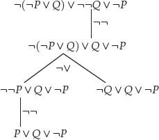

图 4.3 证伪树的一个例子。

**Figure 4.3.** Example of a falsification tree.

显然，变量和否定变量的析取，只有在每个变量都仅以一种形式出现时，才可能被证伪。例如，赋值 $P=F$、$Q=T$ 可以证伪 $P∨¬Q∨P$。因此，语句 S 有效，当且仅当通过 $¬¬-$证伪和 $¬∨-$证伪产生的每个分支，都终止于一个包含某个变量的带否定号与不带否定号两种形式的语句。

Clearly, a disjunction of variables and negated variables can be falsified *only* if each variable occurs in only one form. For example, *P* ∨¬*Q* ∨ *P* can be falsified by assigning the values *P* = F, *Q* = T.Thus *a sentence S is valid if and only if each branch produced by*¬¬*-and* ¬∨*-falsification ends in a sentence in which some variable appears both with and without a negation sign.*

现在考虑把这个过程反过来。我们取：

Now consider the reverse of this process. We take as:

公理。变量与否定变量的一切析取，其中某个变量同时以带否定号和不带否定号的形式出现。

Axioms. All disjunctions of variables and negated variables in which some variable appears both with and without a negation sign.

规则。$¬¬-$证伪和 $¬∨-$证伪的定向版本，即：

Rules. Directed versions of ¬¬and ¬∨-falsification, namely:

$$¬¬ −规则.由 A∨ℬ 推出 ¬¬A∨ℬ . ¬∨ −规则.由 ¬A1∨ℬ 和 ¬A2∨ℬ 推出 ¬(A1∨A2)∨ℬ .$$

$$¬¬ −rule.From A∨ℬ infer ¬¬A∨ℬ . ¬∨ −rule.From ¬A1∨ℬ and ¬A2∨ℬ infer ¬(A1∨A2)∨ℬ .$$

若对有效语句 S 应用 $¬¬-$证伪和 $¬∨-$证伪，消去所有 $¬¬A$ 与 $¬(A1∨A2)$，结果就是一棵各分支终止于公理的树。因此，从下往上阅读证伪树，就得到一个使用 $¬¬$ 规则和 $¬∨$ 规则的 S 的证明。所以，我们的公理和规则对命题逻辑是完备的：它们能证明由函数 $¬$ 和 $∨$ 构成的所有有效语句；而我们已经看到，这两个函数足以表达一切布尔函数。

If we apply ¬¬and ¬∨-falsification to a valid sentence *S* so as to remove all occurrences of $¬¬A$ and $¬(A1∨A2)$, the result is a tree whose branches end in axioms. Therefore, if we read the falsification tree from bottom to top, the result is a *proof* of *S* by the ¬¬and ¬∨-rules. Our axioms and rules are therefore *complete* for propositional logic: they prove all valid sentences built from the functions ¬ and ¬∨, which, as we have seen, suffice to express all Boolean functions.

必须承认，这套公理与规则并未完全明确。我们悄悄假定，可以忽略析取中的括号和各项的顺序。这些假定可以用额外规则形式化：

It must be admitted that this system of axioms and rules is not completely explicit. We have quietly assumed that it is permissible to ignore parentheses and the order of terms in a disjunction. These assumptions can be formalized by extra rules:

重新分组。由 $A∨(ℬ∨C)$ 推出 $(A∨ℬ)∨C$，反之亦然。

Regrouping. From $A∨(ℬ∨C)$ infer $(A∨ℬ)∨C$,and vice versa.

交换。由 $A∨ℬ$ 推出 $ℬ∨A$。

Exchange. From $A∨ℬ$ infer $ℬ∨A$*.*

此外，若加入所谓的弱化规则，就能把公理简化为形如 $Pi∨¬Pi$ 的一切语句：

Also, we can simplify the axioms to be all sentences of the form *P<sub>i</sub>* ∨¬*P<sub>i</sub>* if we include the so-called *dilution* rule:

弱化。由 A 推出 $A∨ℬ$。

Dilution. From $A$ infer $A∨ℬ$*.*

最后，借助收缩规则，可以忽略重复：

Finally, we can ignore repetitions by the *consolidation* rule:

收缩。由 $A∨A∨ℬ$ 推出 $A∨ℬ$。

Consolidation. From $A∨A∨ℬ$ infer $A∨ℬ$*.*

这些推理规则有一个理想性质：前提在某种意义上“包含于”结论中。与使用切割规则的证明不同，这里不会绕道经过比待证语句更复杂的语句。

These rules of inference have the desirable property that the premises are in some sense “contained in” the conclusion. Unlike proofs using the cut rule, there are no “detours” through sentences more complicated than the sentence we are trying to prove.

## 4.4 圆满的结尾

## 4.4 Happy Endings

只需把证伪过程反向运行，就能生成证明，这使我们在一定程度上可以为定理量身安排证明。特别是，可以保证证明的最后一步是一个“圆满的结尾”，以最自然的方式得到目标定理。具体而言，

Generating proofs simply by running the falsification procedure backwards enables us to tailor proofs to theorems to some extent. In particular, we can guarantee that the last step of a proof is a “happy ending” that yields the target theorem in the most natural way. Namely,

1. 若目标定理形如 $¬¬A∨ℬ$，则最后一步是

   If the target theorem is of the form $¬¬A∨ℬ$, then the last step is

   $由 A∨ℬ 推出 ¬¬A∨ℬ.$

   $$from A∨ℬ infer ¬¬A∨ℬ.$$
2. 若目标定理形如 $¬(A1∨A2)∨ℬ$，则最后一步是

   If the target theorem is of the form $¬(A1∨A2)∨ℬ$, then the last step is

   $由 ¬A1∨ℬ 和 ¬A2∨ℬ 推出 ¬(A1∨A2)∨ℬ.$

   $$from ¬A1∨ℬ and ¬A2∨ℬ infer ¬(A1∨A2)∨ℬ.$$

只需把希望采用的最后一步反过来，作为证伪定理 S 的第一次尝试，就能保证 S 的证明以这一步结束。由于 S 是定理，任何证伪尝试都会得到一棵各分支终止于不可证伪公式的树。反向阅读这棵树，就得到一个具有所需结尾的 S 的证明。

We can guarantee the last step in the proof of a theorem *S* by choosing its reverse as the *first* step in an attempt to falsify *S* .Since *S* is a theorem, *any* attempt to falsify it yields a tree whose branches end in unfalsifiable formulas. Reading this tree backwards gives a proof of *S* with the desired ending.

对于含有额外成分，例如切割规则的系统，这一性质很重要。下一章将研究树中切割规则的首次出现，并为此前的无切割证明安排“圆满的结尾”，从而找出可以消去切割的情形。

This property becomes important in systems with extra ingredients, such as the cut rule. In the next chapter we will find circumstances in which cuts may be eliminated by studying the first occurrence of the cut rule and arranging “happy endings” for the cut-free proofs down to that point in the tree.

### 命题逻辑的一致性

### Consistency of Propositional Logic

以 $Pi∨¬Pi$ 为公理、以上述规则构成的形式系统，并未完全取代真值表求值方法。形式系统把所有有效语句都给出为定理，但现在还需要知道所有定理都有效，也就是系统的可靠性。求值恰好能用来证明，命题逻辑的这个公理系统是可靠的，因而也是一致的。

The method of evaluation by truth tables is not entirely superseded by the formal system described by the axioms *P<sub>i</sub>*¬∨*P<sub>i</sub>* and the rules above. The formal system gives us all the valid sentences as theorems, but now we need to know that all theorems are valid; that is, the soundness of the system. Evaluation is just what we need to prove that *the axiom system for propositional logic is sound (and hence consistent).*

证明：首先，显然每条公理都恒取值 T。这正是前面给出的求值例子。其次，可以检验：若一条规则的前提都恒取值 T，其结论也恒取值 T。因此，每个定理都恒取值 T，所以系统可靠，即它只能证明有效语句。□

*Proof:* First, it is clear that each axiom has the constant value T.This was our example of evaluation in the previous section. Second, it can be checked that, if the premises of a rule have the constant value T,then so has the conclusion. Thus each theorem has the constant value T,and hence the system is sound—it proves only valid sentences. □

命题逻辑的表达能力大概不足以使哥德尔第二不完备性定理的证明适用于它。尽管如此，刚才的一致性证明，确实依赖于一个超出命题逻辑自身所含内容的数学原理，即有限序数的归纳原理。

Propositional logic is presumably not expressive enough for the proof of Gödel’s second incompleteness theorem to apply to it. Nevertheless, the consistency proof just described *does* depend on a mathematical principle beyond those present in propositional logic itself; namely, induction for finite ordinals.

为证明给定定理 S 有效，我们实质上假定所有更短的定理都有效；在这种情况下，S 也有效，因为它必定由更短的前提推出。对于重新分组和交换规则，需要退回到应用这些规则之前使用的那条规则。因此，一致性证明依赖于以下原理：有限序数的任何下降序列都是有限的，也就是有限序数的归纳原理。

To prove that a given theorem *S* is valid we essentially assume that all shorter theorems are valid, in which case *S* is valid because it is necessarily inferred from shorter premises. (In the case of the regrouping and exchange rules we have to step back to the rule used *before* regrouping or exchange was applied.) Thus the consistency proof depends on the principle that any descending sequence of finite ordinals is finite, that is, induction for finite ordinals.

这种情形与稍后将看到的算术情形大致类似。算术形式系统包含有限序数的归纳原理，而要证明它的一致性，就需要更强的归纳原理，即小于 $ε0$ 的序数的归纳原理。

This situation is roughly analogous to what we will later see for arithmetic. The formal system for arithmetic includes induction for finite ordinals, and to prove its consistency we need a stronger induction principle—induction for ordinals less than ε<sub>0</sub>.

## 4.5 谓词逻辑

## 4.5 Predicate Logic

要像算术或集合论那样讨论个别对象、性质与函数，就需要包含这些内容的语言与逻辑。足以用于数学的最简单逻辑称为谓词逻辑。$¹$ 它有通常的命题函数，也有个体的名称，包括常量和变量，以及任意有限元的关系和函数。此外，对任意变量 x，都有量词 $∀x$“对所有 x”和 $∃x$“存在一个 x”，也可简称“有一个 x”。谓词逻辑也称一阶逻辑，因为它只允许对个体量化，而不允许对关系或函数量化，后者会得到二阶逻辑。这听起来像是严重限制，但一阶逻辑足以满足大多数数学目的，而且比二阶逻辑具有更好的性质。

To discuss individual objects, properties, and functions, as we do in arithmetic or set theory, we need a language and logic that includes these things. The simplest logic that suffices for mathematics is called *predicate logic*.<sup>1</sup> It has the usual propositional functions, but it also has names for individuals (both *constants* and *variables*), relations (between any finite number of variables), and functions (also of any finite number of variables). Also, for any variable *x* we have the quantifiers ∀*x* “for all *x*”and ∃*x* “there exists an *x*” or simply “there is an *x*.” Predicate logic is also called *first order logic* because it permits only quantification over individuals, not over relations or functions (which would give *second order logic*). This sounds like a severe restriction, but first order logic is adequate for most mathematical purposes, and it has better properties than second order logic.

### 例：一种算术语言

### Example: A Language for Arithmetic

若所考虑的个体是正整数，通常有：

If the intended individuals are the positive integers we usually have:

常量：1、2、3、4、……

Constants: 1, 2, 3, 4,…

变量：i、j、k、l、m、n、……

Variables: *i*, *j, k, l, m, n*,…

函数：S(n)，后继，是变量 n 的一元函数；$m+n$，和，是变量 m、n 的二元函数；$m·n$，积，也是变量 m、n 的二元函数。

Functions: *S*(*n*) (successor, a function of one variable *n*), *m + n* (sum, a function of two variables *m* and *n*), *m · n* (product, a function of two variables *m* and *n*).

关系：$m=n$，是变量 m、n 的二元关系；$m<n$，也是变量 m、n 的二元关系。

Relations: *m = n* (a relation of two variables *m* and *n*), *m < n* (a relation of two variables *m* and *n*).

用这种语言，可以表达数论中通常考虑的正整数的一切性质。例如，“n 是素数”就是性质

In this language we can express all the properties of positive integers usually considered in number theory. For example, *“n* is prime” is the property

$$(n>1)∧¬(∃l)(∃m)(l>1∧m>1∧n=m⋅l).$$

不能把这个表达“n 是素数”的式子称为语句，因为它既不真也不假。我们称它为具有自由变量 n 的公式。具有自由变量 m、n、……的公式，在变量被量词约束后，就成为语句。例如，公式

We cannot call this expression for *“n* is prime” a sentence, because it is neither true nor false. We call it a *formula* with *free variable n*. A formula with free variables *m, n, …* becomes a sentence when the variables are *bound* by quantifiers. For example, the formula

$n<m∧ " m 是素数"$

$$n<m∧ " m is prime"$$

是一个具有自由变量 m 和 n 的公式。当我们如下约束这些变量时，

is a formula with free variables *m* and *n*. When we bind the variables like so—

$(∀n)(∃m)(n<m∧ " m 是素数" )$

$$(∀n)(∃m)(n<m∧ " m is prime" )$$

就得到一个等价于“有无限多个素数”的语句。

—we have a sentence equivalent to “There are infinitely many primes.”

若确实想把具有自由变量的公式解释为语句，就把它看作对自由变量的一切取值所作的断言。这在数学中很常见。例如，写下 $m+n=n+m$ 时，默认其意思是“对所有 m，对所有 n”。

If we really want to interpret a formula with free variables as a sentence, then we do so by taking the formula as an assertion for *all* values of its free variables. This is commonly done in mathematics. For example, when we write *m + n = n + m* itis understood to mean “for all *m*, for all *n.”*

### 谓词逻辑的一个形式系统

### A Formal System for Predicate Logic

为适应一切可能情况，谓词逻辑的语言应包含无限多个常量，即表示尚未确定的特定对象的符号；无限多个变量，即可以说“对所有 x”或“存在一个 x”的符号 x；无限多个函数符号；无限多个关系符号；以及等号。不过，把等号和函数也纳入关系之中，就可以使用更少的成分，本节余下部分将这样处理。

To be prepared for all eventualities, the language for predicate logic should contain infinitely many constants (symbols to denote specific objects, as yet undetermined), infinitely many variables (symbols *x* for which we can say “for all *x*”or “there is an *x*”), infinitely many function symbols, infinitely many relation symbols, and the equality sign. However, we can manage with less than this, by including equality and functions among the relations, and we will do so for the rest of this section.

一个令人惊讶的事实是，谓词逻辑是完备的；哥德尔在发现算术不完备性之前不久发现了它。也就是说，存在一个形式系统，其定理恰好是谓词逻辑的有效语句。与命题逻辑一样，“有效”意为“在一切解释下都为真”。谓词逻辑中的某些语句，出于命题逻辑的原因而有效，例如 $P(a)∨¬P(a)$；另一些则本质上涉及变量和量词，例如 $(∀x)P(x)∨(∃x)¬P(x)$。后一个语句有效，因为无论变量 x 遍历哪个论域，无论性质 P 在该论域上如何解释，它都为真。

A surprising fact, discovered by Gödel shortly before he discovered the incompleteness of arithmetic, is that predicate logic is *complete*.That is, there is a formal system whose theorems are precisely the valid sentences of predicate logic. As in propositional logic, “valid” means “true under all interpretations.” There are some sentences of predicate logic that are valid for propositional reasons—for example *P*(*a*) ∨¬*P*(*a*)—but others involve variables and quantifiers in an essential way, for example (∀*x*)*P*(*x*) ∨ (∃*x*) ¬*P*(*x*)*.* The latter sentence is valid because it is true for all domains the variable *x* may range over, and for all interpretations of the property *P* on that domain.

我们采用与命题逻辑相同的策略，为谓词逻辑寻找完备形式系统：通过证伪更简单的语句来尝试证伪给定语句，然后把证伪规则反过来写成推理规则。与前面一样，假定所有布尔函数都已用 $¬$ 和 $∨$ 写出，因此，反向使用 $¬¬$ 规则和 $¬∨$ 规则，再加上通常默认的重新分组与交换，就足以简化语句的布尔部分。还可以假定所有量词 $∃x$ 都已用 $∀x$ 改写，因为

We find a complete formal system for predicate logic by the same strategy as for propositional logic: seeking to falsify sentences by falsifying simpler sentences, then writing the falsification rules backward as rules of inference. As before, we suppose that all Boolean functions have been written in terms of ¬ and ∨, so the reverse -and¬∨-rules (together with regrouping and exchange, which we usually take for granted) suffice to simplify the Boolean part of a sentence. We can also assume that all quantifiers ∃*x* have been rewritten in terms of ∀*x*,because

$(∃x)A(x) 等价于 ¬(∀x)¬A(x).$

$$(∃x)A(x)  is equivalent to  ¬(∀x)¬A(x).$$

接下来只需寻找涉及 $∀x$ 的证伪规则，图 4.4 所示的两条规则就足够了。与第 4.3 节一样，把证伪规则对应于树中向下的有向边，目标是通过证伪下方语句来证伪上方语句。

It then remains to find falsification rules involving ∀*x*, and the two shown in Figure 4.4 suffice. As in Section 4.3, we associate falsification rules with downward directed edges of a tree. The aim is to falsify the upper sentence by falsifying the lower one.

可以检验，一个解释证伪上方语句，当且仅当它证伪下方语句。左边规则要求a 不在 ℬ 中自由出现，是为了避免得到不可证伪的语句 $A(a)∨¬A(a)$；当 $ℬ=¬A(a)$ 时就会出现这种情况。右边规则并没有真正简化语句，因为公式 $¬(∀x)A(x)$ 仍然保留，因此某些分支可能不会终止。

It can be checked that an interpretation falsifies the upper sentence if and only if it falsifies the lower sentence. The reason for the restriction to *a* not free in ℬ in the rule on the left is to avoid getting the unfalsifiable sentence $A(a)∨¬A(a)$, which happens if $ℬ=¬A(a)$.The rule on the right does not really simplify the sentence, since the formula $¬(∀x)A(x)$ persists, and hence some branches may not end.

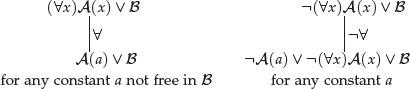

图 4.4 量词的证伪规则。

**Figure 4.4.** Quantifier falsification rules.

不过，如果在构造树时，保证每个分支上的常量 $a1$、$a2$、$a3$、……按顺序引入，并应用所有适用规则，那么任意无限分支都会具有下面的性质。为简洁表述这些性质，把树中每个语句分解为尽可能多的语句 $A1$、$A2$、……、$Ak$ 的析取 $A1∨A2∨⋯∨Ak$，这些语句称为其析取项。

However, if the construction of the tree is managed so that the constants *a*<sub>1</sub>, *a*<sub>2</sub>, *a*<sub>3</sub>,… are introduced in order on each branch, and all applicable rules are applied, *any infinite branch will have the properties below. To* state these properties concisely we decompose each sentence in the tree as a disjunction, $A1∨A2∨⋯∨Ak$, of the maximal number of sentences $A1,A2,…,Ak$ (called its *disjuncts*)*.*

- 若 $¬¬A$ 作为析取项出现在分支上，则 A 也会出现。

  If $¬¬A$ occurs as a disjunct on the branch, so does $A$**.**
- 若 $¬(A1∨A2)$ 作为析取项出现在分支上，则 $¬A1$ 或 $¬A2$ 也会出现。

  If $¬(A1∨A2)$ occurs as a disjunct on the branch, so does $¬A1$ or $¬A2$.
- 若 $(∀x)A(x)$ 作为析取项出现在分支上，则对某个常量 $ai$，$A(ai)$ 也会出现。

  If $(∀x)A(x)$ occurs as a disjunct on the branch, so does $A(ai)$ for some constant *a<sub>i</sub>.*
- 若 $¬(∀x)A(x)$ 作为析取项出现在分支上，则对每个常量 $ai$，$¬A(ai)$ 都会出现。

  If $¬(∀x)A(x)$ occurs as a disjunct on the branch, so does $¬A(ai)$ for *every* constant *a<sub>i</sub>.*

由此可知，在无限分支上，每个语句最终都会分解为原子，即形如 $R(ai,aj,…)$ 或 $¬R(ai,aj,…)$ 的项，其中 R 是关系符号。$²$ 每个原子只以一种形式出现，要么带否定号，要么不带，因为若两种形式都出现，包含它们的析取就无法证伪，分支便会终止。因此，可以自由地给每个这样的原子赋值 F，结果分支上的每个语句都取值 F，包括树根处的语句 S。

It follows that, on an infinite branch, every sentence is ultimately broken down to *atoms:* terms of the form *R*(*a<sub>i</sub>,a<sub>j</sub>*,…) or ¬*R*(*a<sub>i</sub>,a<sub>j</sub>*,…) where *R* is a relation symbol.<sup>2</sup> Each atom occurs in only one form, either with the negation sign or without, because if both forms occur the disjunction containing them cannot be falsified and the branch will end. Thus we are free to assign each atom the value F,and *every sentence in the branch gets the value F as a result, including the sentence S at the root of the tree.*

反过来，若谓词逻辑的语句 S 有效，则树的每个分支都终止，而且必定终止于一个包含同一原子的带否定号与不带否定号两种形式的析取。

Conversely, *if a sentence S of predicate logic is valid, every branch in the tree terminates, necessarily in a disjunction of terms that includes the same atom, both with and without a negation sign.*

因此，取形如 $R(ai,aj,…)∨¬R(ai,aj,…)$ 的语句为公理，并把证伪规则反过来作为推理规则，就得到谓词逻辑的一个完备形式系统。

Therefore, *by taking the sentences of the form R*(*a<sub>i</sub>, a<sub>j</sub>*,…) ∨¬*R*(*a<sub>i</sub>, a<sub>j</sub>*,…) *as axioms, and the reverses of the falsification rules as rules of inference, we get a complete formal system for predicate logic.*

谓词逻辑新增的两条规则如下。

The two new rules in predicate logic are the following.

$∀$ 规则。由 $A(x)∨ℬ$，其中 x 是自由变量，推出 $(∀x)A(x)∨ℬ$。

∀**-rule.** From $A(x)∨ℬ$ for a free variable *x* infer $(∀x)A(x)∨ℬ$*.*

$¬∀$ 规则。由 $¬A(a)∨ℬ$ 推出 $¬(∀x)A(x)∨ℬ$。

¬∀**-rule.** From $¬A(a)∨ℬ$ infer $¬(∀x)A(x)∨ℬ$*.*

这个形式系统没有把第二条证伪规则的逆向形式作为原始规则，即

This formal system does not contain a primitive rule that is the reverse of the second falsification rule, namely,

$由 ¬A(a)∨¬(∀x)A(x)∨ℬ 推出 ¬(∀x)A(x)∨ℬ.$

$$from ¬A(a)∨¬(∀x)A(x)∨ℬ infer ¬(∀x)A(x)∨ℬ.$$

不过，可以把后一条规则推导为 $¬∀$ 规则与收缩规则的组合：

However, we can *derive* the latter rule as a combination of the ¬∀ rule and consolidation,

$$由 ¬A(a)∨¬(∀x)A(x)∨ℬ 推出 ¬(∀x)A(x)∨¬(∀x)A(x)∨ℬ (根据 ¬∀-规则), 由 ¬(∀x)A(x)∨¬(∀x)A(x)∨ℬ 推出 ¬(∀x)A(x)∨ℬ (根据 收缩规则).$$

$$from ¬A(a)∨¬(∀x)A(x)∨ℬ infer ¬(∀x)A(x)∨¬(∀x)A(x)∨ℬ (by ¬∀-rule), from ¬(∀x)A(x)∨¬(∀x)A(x)∨ℬ infer ¬(∀x)A(x)∨ℬ (by consolidation).$$

由此可知，若语句 S 无法被证伪，则在命题逻辑规则加上 $∀$ 规则和 $¬∀$ 规则构成的系统中，S 有一个证明。这就是谓词逻辑完备性定理的一个版本。

It follows that if a sentence *S* cannot be falsified, then it has a proof in the system with the rules of propositional logic, plus the ∀-and ¬∀-rules. This is (one version of) the *completeness theorem for predicate logic.*

哥德尔的版本采用的谓词逻辑公理系统，实质上源于弗雷格 1879 年的工作，并把切割规则作为推理规则之一。1934 年，根岑证明切割可以消去，从而说明无切割系统的完备性。不过，直到 20 世纪 50 年代，才出现沿上述思路进行的完备性证明。通过反转自然的证伪过程来寻找所需推理规则的想法，似乎在 1955 年前后由几位逻辑学家分别想到，包括 Beth、Hintikka、Lis、Smullyan 和 van Heijenoort，参见 Annellis（1990）。

Gödel’s version used an axiom system for predicate logic essentially due to Frege in 1879, with the cut rule as one of the rules of inference. In 1934 Gentzen showed that cut could be eliminated, thus showing the completeness of cut-free systems. However, it was only in the 1950s that completeness proofs were given along the above lines. The idea of finding the necessary rules of inference by reversing a natural falsification procedure seems to have occurred to several logicians around 1955 (Beth, Hintikka, Lis, Smullyan, and van Heijenoort—see Annellis (1990)).

## 4.6 完备性、一致性与圆满的结尾

## 4.6 Completeness, Consistency, Happy Endings

> 如果赋予一个概念相互矛盾的属性，我就说，这个概念在数学上不存在。……但如果能够证明，通过有限次逻辑推理，赋予该概念的属性永远不会导致矛盾，我就说，该概念的数学存在性……由此得到了证明。

> If contradictory attributes be assigned to a concept, I say that mathematically the concept does not exist. … But if it can be proved that the attributes assigned to the concept can never lead to a contradiction by the application of a finite number of logical inferences, I say that the mathematical existence of the concept … is thereby proved.

> ——戴维$·$希尔伯特

> —David Hilbert

> 1900 年《关于数学问题的演讲》，载于 Ewald（1996），第二卷，第 1105 页。

> Address on *Mathematical Problems*, 1900, in Ewald (1996), volume II, p. 1105.

谓词逻辑的完备性证明，为希尔伯特关于数学存在性的观念提供了非凡的支持。在希尔伯特之前，数学中已经出现许多“虚构”或“理想”对象，除了看起来一致且有用之外，并没有显然的理由认为它们存在。

The completeness proof for predicate logic is a remarkable vindication of Hilbert’s concept of mathematical existence. Before Hilbert’s time, mathematics had seen many examples of “imaginary” or “ideal” objects with no obvious reason to exist, other than their apparent consistency and usefulness.

完备性定理的证明，以一般得多的方式，通过符号赋予数学概念意义。简言之，其思想如下。

The proof of the completeness theorem gives meaning to mathematical concepts via symbols in a much more general way. Briefly, the idea is this.

设 S 是一个不会导致矛盾的语句。那么 $¬S$ 可以被证伪，因为若 $¬S$ 不能被证伪，由完备性定理就能证明 $¬S$，而这显然与 S 矛盾。证伪过程给出一个具体解释，使 $¬S$ 为假，从而使 S 为真。这个解释对某些常量，为 S 中的关系符号赋予 T 或 F。因此，S 中隐含的“概念”，在某个符号世界中获得了意义；在这个世界中，“个体”a、b、c、……是常量符号，而关系 R(x,y) 则由以常量替换变量时所赋予的真值决定。

Suppose *S* is a sentence that does not lead to a contradiction. Then ¬*S* can be falsified, because if ¬*S* cannot be falsified we can *prove*¬*S*, by the completeness theorem, and this certainly contradicts *S* .The falsification procedure gives a specific interpretation that falsifies¬ S,and hence makes *S* true. The interpretation in question assigns the values T or F to the relation symbols in *S* for certain constants. Thus the “concepts” implicit in *S* have meaning in a certain symbolic world, where the “individuals” *a*, *b*, *c*,… are constant symbols and relations *R*(*x,y*) are determined by the truth values assigned to them when constants are substituted for their variables.

因此，希尔伯特关于一致概念具有存在性的梦想，至少对可用谓词逻辑语言表达的概念而言，由完备性定理实现了。可以说，哥德尔实现了希尔伯特的一个梦想，尽管他又以算术的不完备性定理，粉碎了另一个梦想，即为数学给出有穷一致性证明。

Hilbert’s dream of existence for consistent concepts is therefore realized (at least for concepts expressible in the language of predicate logic) by the completeness theorem. We can say that Gödel made one of Hilbert’s dreams come true, even though he crushed the other dream (of a finitary consistency proof for mathematics) with his incompleteness theorems for arithmetic.

事实上，不完备性定理还为希尔伯特的数学存在性观念增添了有趣的转折。某个特定公理系统 𝒜 不完备，意味着存在语句 S，使 S 与 $¬S$ 都分别与 𝒜 相容。于是，上述论证导出两个符号世界：一个世界中 𝒜 与 S 为真，另一个世界中 𝒜 与 $¬S$ 为真。其实，早在哥德尔之前，人们就在平面几何的平行公理上知道了这种情况。19 世纪的几何学家构造了各种几何世界，其中一些满足平行公理，另一些不满足。

Indeed, the incompleteness theorems add an interesting twist to Hilbert’s concept of mathematical existence. Incompleteness of a particular axiom system $𝒜$ means that there is a sentence *S* such that *both S* and ¬*S* are consistent with $𝒜$. The argument above then leads to *two* symbolic worlds: one in which $𝒜$ and *S* are true, and one in which $𝒜$ and *¬S* are true. Actually, this situation was already known long before Gödel, in the case of the *parallel axiom* in plane geometry. In the 19th century, geometers constructed various geometric worlds, some in which the parallel axiom is true, and some in which it is false.

### 证明与圆满的结尾

### Proofs and Happy Endings

从失败的证伪尝试中得到谓词逻辑证明，带有命题逻辑中没有的不确定性。具体说，证伪过程可能是无限的，因此，即使给定语句 S 确实有效，一般也无法预先知道证明它需要多久。这是不可避免的。如果总能预先知道要搜索多久才能找到证明，就有了判定有效性的算法，这与判定问题不可解相矛盾，见第 3.7 节。因此，不能总是预见证伪过程会持续多久，或它是否会无限进行。

Obtaining proofs in predicate logic from failed falsification attempts has an element of uncertainty not present in propositional logic. Namely, the falsification procedure is potentially infinite, so we cannot in general tell how long it will take to prove a given sentence *S*, if *S* is in fact valid. This is unavoidable. If we always knew in advance how long to search for a proof, then we would have an algorithm for deciding validity, contrary to the unsolvability of the Entscheidungsproblem (Section 3.7). Thus we cannot always foresee how long falsification will take, or whether the process will be infinite.

另一方面，由于每个有效语句都有有限证明，可以采用与命题逻辑中基本相同的求值论证，说明形式系统可靠。实质上，先忽略量词，像命题逻辑那样把所有语句求值为 T 或 F，并说明 T 值从公理传递到定理。因此，不可能证明假语句。

On the other hand, since each valid sentence has a finite proof, it is possible to show that the formal system is sound by much the same evaluation argument that we used for propositional logic. Essentially one ignores quantifiers, evaluating all sentences T or F as in propositional logic, and showing that the value T propagates from axioms to theorems. Thus no false sentence is provable.

还可以说明，谓词逻辑的每个定理都有一个在以下意义上具有“圆满结尾”的证明：

We can also show that each theorem of predicate logic has a “happy ending” proof in the following sense:

1. 若目标定理形如 $¬¬A∨ℬ$，则最后一步是

   If the target theorem is of the form $¬¬A∨ℬ$, then the last step is

   $由 A∨ℬ 推出 ¬¬A∨ℬ.$

   $$from A∨ℬ infer ¬¬A∨ℬ.$$
2. 若目标定理形如 $¬(A1∨A2)∨ℬ$，则最后一步是

   If the target theorem is of the form $¬(A1∨A2)∨ℬ$, then the last step is

   $由 ¬A1∨ℬ 和 ¬A2∨ℬ 推出 ¬(A1∨A2)∨ℬ.$

   $$from ¬A1∨ℬ and ¬A2∨ℬ infer ¬(A1∨A2)∨ℬ.$$
3. 若目标定理形如 $(∀x)A(x)∨ℬ$，则最后一步是

   If the target theorem is of the form $(∀x)A(x)∨ℬ$, then the last step is

   $由 A(x)∨ℬ 推出 (∀x)A(x)∨ℬ.$

   $$from A(x)∨ℬ infer (∀x)A(x)∨ℬ.$$
4. 若目标定理形如 $¬(∀x)A(x)∨ℬ$，则最后一步是

   If the target theorem is of the form $¬(∀x)A(x)∨ℬ$, then the last step is

   $由 ¬A(a)∨ℬ 推出 ¬(∀x)A(x)∨ℬ.$

   $$from ¬A(a)∨ℬ infer ¬(∀x)A(x)∨ℬ.$$

情形 1 和 2 的论证与第 4.3 节命题逻辑中的相同。情形 3 和 4 也类似，只需使用谓词逻辑的证伪过程。

Cases 1 and 2 follow as they did for propositional logic in Section 4.3. Cases 3 and 4 are similar, using the falsification procedure for predicate logic.

例如，给定形如 $(∀x)A(x)∨ℬ$ 的定理，必定有一个实例 $A(x)∨ℬ$，其中 x 是自由变量，且 $A(x)∨ℬ$ 有效。因此，任何证伪 $A(x)∨ℬ$ 的尝试都会失败；把这种尝试反向运行，就得到 $A(x)∨ℬ$ 的一个证明，再由 $∀$ 规则立即推出 $(∀x)A(x)∨ℬ$。

For example, given a theorem of the form $(∀x)A(x)∨ℬ$, there must be an instance $A(x)∨ℬ$ for a free variable $x$ for which $A(x)∨ℬ$ is valid. Therefore, any attempt to falsify $A(x)∨ℬ$ will fail, and running this attempt backwards yields a proof of $A(x)∨ℬ$, from which $(∀x)A(x)∨ℬ$ follows immediately by the ∀-rule.

## 4.7 历史背景

## 4.7 Historical Background

### 命题逻辑与计算

### Propositional Logic and Computation

> ……数学家针对是非问题所做的脑力工作，可以完全由机器取代。

> … the mental work of a mathematician concerning Yes-or-No questions could be completely replaced by a machine.

> ——库尔特$·$哥德尔

> —Kurt Gödel

> 1956 年 3 月 20 日致约翰$·$冯$·$诺伊曼的信，载于 Gödel（2003），第 375 页。

> Letter to John von Neumann, 20 March 1956, in Gödel (2003), p. 375.

波斯特于 1921 年发表真值表方法时，命题逻辑的所有基本问题似乎都已解决。真值表能够判定以下问题。

When Post published the truth table method in 1921, it appeared that all the basic questions about propositional logic had been settled. Truth tables decide the following.

- 有效性：公式有效，当且仅当无论变量取何值，公式的值都为“真”；而公式的值可通过真值表计算。

  *Validity:* a formula is valid if and only if it has value “true” for all values of its variables (and the value of the formula is computable by truth tables).
- 一致性：通常的命题逻辑形式系统是一致的，因为其公理的值为“真”，而推理规则保持真值。

  *Consistency:* the usual formal systems for propositional logic are consistent because their axioms have value “true,” and the rules of inference preserve truth.
- 可满足性：公式可满足，当且仅当存在一种变量真值赋值，使公式的值为“真”。

  *Satisfiability:* a formula is satisfiable if and only if it has value “true” for some assignment of truth values to its variables.

特别是，有效性和可满足性都能在预先有界的有限时间内检验。由于 n 个变量共有 $2n$ 种真值赋值方式，检验一个含 n 个变量的公式所需时间，大约是 $2n$ 步。在 20 世纪初，这已经满足了人们对有限性的全部要求。但到了 20 世纪 50 年代，首批检验逻辑有效性的计算机程序开发出来后，逻辑学家开始认识到，$2n$ 步其实是很长的时间。

In particular, validity and satisfiability are testable in a finite time that can be bounded in advance. Since there are 2*<sup>n</sup>* ways to assign truth values to *n* variables, the time required to test a formula with *n* variables is of the order of 2*<sup>n</sup>* steps. In the early 20th century, this was as finite as anyone wanted. But in the 1950s, when the first computer programs for testing logical validity were developed, logicians began to realize that 2*<sup>n</sup>* steps is a long time.

同一时期，哥德尔以其典型的先见之明，在上引致约翰$·$冯$·$诺伊曼的信中写道：

In the same period, Gödel, with typical prescience, wrote the following to John von Neumann: in the letter quoted above.

> 请容许我写信向您请教一个数学问题，我非常希望知道您的看法：显然，可以很容易地构造一台图灵机，对于一阶谓词逻辑的每个公式 F 和每个自然数 n，判定 F 是否存在长度为 n 的证明，其中长度指符号数。设 ψ(F,n) 为机器完成这一任务所需的步数，令 $φ(n)=maxFψ(F,n)$。问题是，对最优机器而言，φ(n) 的增长速度有多快。可以证明 $φ(n)≥k·n$。如果真的存在一台机器，使 $φ(n)～k·n$，甚至$～k·n2$，那将产生极其重要的后果。具体说，这显然意味着，尽管判定问题不可判定，数学家针对是非问题所做的脑力工作，仍可以完全由机器取代。毕竟，只需把自然数 n 取得足够大，使得机器若没有给出结果，就不值得再继续思考该问题。

哥德尔提出的问题表面上更一般，涉及谓词逻辑中的有效性判定，但实际上与命题逻辑中的可满足性判定很相似。两种情况下，都必须在大约包含 $2n$ 个候选对象的空间中，寻找一个具有易于识别性质的对象；这些候选对象分别是谓词逻辑符号序列，以及 n 个命题变量的真值赋值：

Gödel is asking an apparently more general question—about deciding validity in predicate logic—but actually the issue is much the same as deciding satisfiability in propositional logic. In both cases one has to search through a space of size roughly 2*<sup>n</sup>* candidates (sequences of predicate logic symbols, assignments of truth values to *n* propositional variables) for an object with an *easily recognizable* property:

- 把给定的 n 个符号组成的序列分成公式，并检验每个公式是否由前面的公式按照给定推理规则之一得到，就能容易地判断它是否为谓词逻辑的一个证明。

  We can easily tell whether a given sequence of *n* symbols is a proof in predicate logic by breaking it into formulas and checking whether each follows from preceding formulas by one of the given rules of inference.
- 对于 n 个变量的命题公式，给定变量的值后，利用真值表计算公式的值，就能容易地判断它是否得到满足。

  We can easily tell whether a propositional formula in *n* variables is satisfied, for given values of the variables, by computing its value by truth tables.

这两项任务之所以“容易”，是因为大约 $n2$ 步就能完成；相比之下，枚举候选空间中的所有对象，需要大约 $2n$ 步。因此，“困难”的部分，也就是我们似乎需要数学家的部分，在于从指数规模的空间中找到一个验证对象。

These two tasks are “easy” in the sense that they can be done in around *n*<sup>2</sup> steps, in contrast to the approximately 2*<sup>n</sup>* steps it takes to enumerate all objects in the space of candidates. Thus the “hard” part—the part for which we seem to need mathematicians—is finding a validating object in an exponentially large space.

这样比较这两个问题时，命题逻辑的可满足性问题，仿佛就是整个数学的缩影。在某种意义上确实如此。哥德尔的问题，即对给定 n，判定给定语句是否有长度至多为 n 的证明，可以归约为判定一个大约含 n 个变量的命题公式是否可满足。这里“大约”意为“由 n 的某个多项式函数所界定”。这来自斯蒂芬$·$库克（1971）关于非确定性图灵机的一个更一般结果。

When the two problems are compared in this way, it looks as though *the satisfiability problem of propositional logic is all mathematics, in microcosm.* In a sense, this is correct. Gödel’s problem of deciding, for given *n*, whether a given sentence has a proof of length at most *n* reduces to deciding satisfiability of a propositional formula with roughly *n* variables. “Roughly” means “bounded by some polynomial function of *n.”* This follows from a more general result of Stephen Cook (1971) about *nondeterministic Turing machines.*

非确定性图灵机与第 3.5 节描述的普通图灵机相同，区别只在于，给定的“状态、符号”对 $(qi,Sj)$ 可以出现在不止一个五元组中。因此，对给定输入纸带，可能存在不止一种计算。这当然不是我们希望真实机器具有的行为，但对于假想机器却非常有用，因为它允许机器先猜测，再检验。例如，设机器中包含以下五元组

A nondeterministic Turing machine is the same as an ordinary Turing machine (described in Section 3.5), except that a given (state, symbol) pair (*q<sub>i</sub>*, *S<sub>j</sub>*) may occur in *more* than one quintuple. Thus, more than one computation is possible on a given input tape. This of course is not how we want real machines to behave, but it is great for a hypothetical machine, because it allows the machine to *make a guess and then test it*. For example, suppose we include the quintuples

$$q1B0Rq1, q1B1Rq1, q1BBRq2$$

其中 B 表示纸带上的空白方格。那么，从空白纸带上的状态 $q1$ 开始，机器就能写出一个随机的 0、1 序列，再跳转到状态 $q2$。进入 $q2$ 后，机器可以把这个 0、1 序列，视为输入的命题公式 F 的一种真值赋值；例如，F 可写在起始方格的左边。通过实现真值表方法，机器就能针对随机生成的变量取值序列，计算 F 的真值。

in the machine, where *B* denotes the blank square of tape. Then, when started in state *q*<sub>1</sub> on a blank tape, the machine can write a random sequence of 0s and 1s and jump into state *q*<sub>2</sub>. Once in state *q*<sub>2</sub>,the machine can treat the sequence of 0s and 1s as an assignment of truth values to a propositional formula *F* given as input (say, to the left of the starting square). By implementing the truth table method, the machine can compute the truth value of *F* for the sequence of values of the variables that it has randomly generated.

显然，若长度为 n 的命题公式 F 可满足，就有一个大约 n 步的非确定性图灵机计算展示这一事实。类似地，若谓词逻辑的一个语句有长度至多为 n 的证明，也有一个大约 n 步的非确定性图灵机计算展示这一事实。库克通过用“且”“或”“非”描述图灵机的动作，证明了以下结果，列昂尼德$·$列文也独立发现了它：

Clearly, if the propositional formula *F* of length *n* is satisfiable, then this fact is shown by a nondeterministic Turing machine computation of roughly *n* steps. By a similar argument, if a sentence of predicate logic has a proof of length at most *n*, this fact is also shown by a nondeterministic Turing machine computation of roughly *n* steps. Cook proved the following (it was also discovered independently by Leonid Levin) by describing the actions of a Turing machine in terms of “and,” “or,” and “not”:

库克定理。对每台非确定性图灵机 M、输入 I 和时间 T，都存在一个命题公式 $ℱM,I,T$，其长度大约为 M、I、T 的规模，使得：

Cook’s theorem. *For each nondeterministic Turing machine M, input I, and time T, there is a propositional formula* ℱ*<sub>m,i,t,</sub> of length roughly the size of M, I, T, such that:*

M 对输入 I 在至多 T 步内停机，当且仅当 $ℱM,I,T$ 可满足。

*M halts, for input I, in at most T steps if and only if* ℱ*m,i,t is satisfiable.*

如前所述，“大约为……的规模”意为“由……的多项式函数所界定”。因此，这个定理涉及所谓 NP 类，即“可在多项式时间内非确定性求解”的问题类。若存在非确定性图灵机 M 和多项式 p，使 M 对问题 𝒫 中每个长度为 n 的问题，都能通过某个至多 p(n) 步的计算给出答案，则 𝒫 属于 NP。库克定理说明，相对于可满足性问题，NP 中的任何问题都是“容易”的。如果奇迹般地存在可满足性问题的确定性多项式时间解法，那么 NP 中每个问题都有确定性多项式时间解法。

As I said, “roughly the size of” means “bounded by a polynomial function of.” So the theorem is about the so-called class NP of problems “solvable nondeterministically in polynomial time.” A problem *Ƥ* is in NP if there is a nondeterministic Turing machine *M* and a polynomial *p* such that *M* answers each question in *Ƥ* of length *n* by *some* computation of at most *p*(*n*) steps. Cook’s theorem says that any problem in NP is “easy,” relative to the satisfiability problem. If (by some miracle) there is a *deterministic* polynomial-time solution of the satisfiability problem, then there is a deterministic polynomial-time solution of every problem in NP.

能够在多项式时间内确定性求解的问题，构成称为 P 的类。哥德尔在致冯$·$诺伊曼的信中，询问的是 kn 或 $kn2$ 步的确定性解法。但若把步数上界放宽为任意多项式 p(n)，他就是在问：P 类是否包含以下问题，即判定谓词逻辑公式是否存在长度为 n 的证明。后一个问题包含可满足性问题，因此哥德尔实际上隐含地在问，NP 是否等于 P。这已成为当今逻辑与计算机科学中最重要的未解决问题。正如他所说，这关系到数学家能否被机器取代。

The problems solvable deterministically in polynomial time make up a class called P. In his letter to von Neumann, Gödel asked about deterministic solution in *kn* or *kn*<sup>2</sup> steps. But if we relax his step bound to an arbitrary polynomial *p*(*n*), then he is asking whether class P includes the problem of deciding the existence of proofs of length *n* for formulas of predicate logic. The latter problem includes the satisfiability problem, so Gödel is implicitly asking whether NP equals P. This has become the most important open question in logic (and computer science) today. As he says, it is the question of whether mathematicians can be replaced by machines.

### 命题逻辑与谓词逻辑之间

### Between Propositional Logic and Predicate Logic

> 我仍然完全确信，不愿使用非有穷概念……是其他人在我的工作之前未能给出完备性定理的首要原因。

> I am still *perfectly convinced* that reluctance to use non-finitary concepts …was the primary reason why the completeness theorem was not given by… anyone else before my work

> ——库尔特$·$哥德尔

> —Kurt Gödel

> 1968 年 3 月 7 日致王浩的信，载于 Gödel（2003），第 403 页。

> Letter to Hao Wang, 7 March 1968, in Gödel (2003), p. 403.

第 4.5 节谓词逻辑的完备性证明，使用了一个关于无穷的温和假定：若证明树不是有限的，它就有一条无限分支。这一假定是以下结果的特殊情形。匈牙利数学家德奈什$·$柯尼希于 1926 年发表了这个结果，后来通过其著作 König（1936/1990）使之更广为人知：

In the completeness proof for predicate logic in Section 4.5 there is a mild assumption about infinity. We assumed that the proof tree, if it is not finite, has an infinite branch. This assumption is a special case of the following result, which was published by the Hungarian mathematician Dénes König in 1926 and made more widely known by his book König (1936/1990):

柯尼希无穷引理

The König infinity lemma

若 T 是一棵无限树，且每个顶点只与有限多条边相接，则 T 包含一条无限分支。

*If T is an infinite tree in which each vertex meets only finitely many edges, then T contains an infinite branch.*

从 T 中任意一个顶点出发，考察从它引出的有限多条边。其中至少有一条边 e 通向一棵同样无限的子树 T′。于是，沿 e 移动到另一端的顶点，重复这一论证。无限继续这个过程，就得到一条无限分支。

Start at any vertex in T, and consider its finitely many outgoing edges. At least one of these edges, e, leads into a subtree *T’* which is also infinite. So, move to the vertex at the other end of *e* and repeat the argument. Continuing the process indefinitely, we obtain an infinite branch.

柯尼希无穷引理含有某些无限性内容，因此不符合希尔伯特纲领对有穷证明的要求。例如，可以定义一棵无限的可计算树，却没有任何可计算的无限分支。事实上，哥德尔相信，自己之所以能在他人失败之处成功证明谓词逻辑的完备性，是因为愿意走出希尔伯特纲领。请记住，哥德尔对谓词逻辑的完备性证明，比其不完备性定理实质上终结希尔伯特纲领早一年。

The König infinity lemma has some infinite content which disqualifies it from the Hilbert program of finitary proofs. For example, it is possible to define an infinite computable tree with no computable infinite branch. In fact, Gödel believed that he succeeded in proving the completeness of predicate logic, where others had failed, because of his willingness to step outside the Hilbert program. (Bear in mind that Gödel’s completeness proof for predicate logic came a year before his incompleteness theorems effectively ended the Hilbert program.)

命题逻辑中的一个无限定理

We now know that the König infinity lemma is needed for any proof that predicate logic is complete. A whole subject, called *reverse mathematics*, has sprung up to study the assumptions on which key theorems depend. The König infinity lemma also underlies some classical theorems of analysis, such as the Heine-Borel theorem stating that any covering of [0,1] by open intervals includes a finite subcover. For more on this, see Simpson (1999).

紧致性定理

König (1936/1990) said that his lemma “furnishes a useful method of carrying over certain results from the finite to the infinite,” and illustrated the method by the Heine-Borel theorem and some theorems of combinatorics. Today, the property of [0,1] expressed by the Heine-Borel theorem is called *compactness*, and other properties derived from the König infinity lemma are also called “compactness.” An important example is:

若 S 是命题逻辑的一个公式集，且其任意有限子集都可满足，则整个集合 S 可满足。

Compactness theorem for propositional logic. *If S is an infinite set of formulas of propositional logic, any finite subset of which is satisfiable, then the whole set S is satisfiable.*

证明：首先，令 $P1$、$P2$、$P3$、……为 S 中公式出现的所有命题变量，并考虑对 $P1$、$P2$、$P3$、……的一切真值赋值所构成的树。必要时重新命名变量，可以保证变量有无限多个，因此这是一棵无限树。最初几层如图 4.5 所示。第 n 层的 $2n$ 个顶点，每个都代表对 $P1$、$P2$、……、$Pn$ 的一种赋值。例如，沿“左、右、左”分支到达的顶点 A，代表赋值

*Proof:* To launch the proof of this theorem, we let *P*<sub>1</sub>, *P*<sub>2</sub>, *P*<sub>3</sub>,… be all the propositional variables occurring in formulas in *S*, and consider the *tree of all assignments of truth values to P*<sub>1</sub>, *P*<sub>2</sub>, *P*<sub>3</sub>, . . . . By renaming variables, if necessary, we can ensure that there are infinitely many of them, so this is an infinite tree. The first few levels are shown in Figure 4.5. Each of the 2*<sup>n</sup>* vertices at level *n* represents an assignment of values to *P*<sub>1</sub>, *P*<sub>2</sub>,…*,P<sub>n</sub>.* For example, the vertex *A* at the end of the branch that goes left, right, left represents the assignment

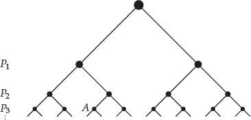

图 4.5 真值赋值树。

**Figure 4.5.** The tree of truth-value assignments.

$P1= false , P2= true , P3= false$

$$P1= false , P2= true , P3= false$$

现在对这棵树剪枝：若某个顶点对应的赋值，使 S 中某个公式为假，就删去该顶点。剩下的仍是一棵无限树 T。否则，所有分支都会在某一层 n 之前终止。此时，对 $P1$、$P2$、……、$Pn$ 的每种真值赋值 A，都使 S 中某个公式 $FA$ 为假。但这样一来，由这些公式 $FA$ 组成的有限集合就不可满足，与假设矛盾。

Now we *prune* this tree by deleting each vertex for which the corresponding assignment falsifies some formula in *S*. What remains is still an infinite tree, *T.* If not, then all branches terminate by some level n.In that case, each assignment *A* of truth values to *P*<sub>1</sub>, *P*<sub>2</sub>,…, *P<sub>n</sub>* falsifies some formula *F<sub>A</sub>* in *S*. But then the finite set of formulas *F<sub>A</sub>* is unsatisfiable, contrary to assumption.

因此，由柯尼希无穷引理，T 有一条无限分支。沿此分支赋予 $P1$、$P2$、$P3$、……的值，必定满足 S 中所有公式，否则这条分支就不可能在剪枝过程中保留下来。□

Thus, by the König infinity lemma, *T* has an infinite branch. The values assigned to *P*<sub>1</sub>, *P*<sub>2</sub>, *P*<sub>3</sub>, … along this branch necessarily satisfy all formulas in *S,* otherwise the branch would not have survived the pruning process. □

命题逻辑的紧致性定理，带有某种谓词逻辑的意味，而且不只是证明风格如此。借助一个把每个谓词逻辑公式替换为一组通常为无限的命题逻辑公式的技巧，它确实蕴涵谓词逻辑中相应的紧致性定理。

The compactness theorem for propositional logic has a certain smell of predicate logic about it, and not only in the style of proof. It really *implies* the corresponding compactness theorem for predicate logic, thanks to a trick that replaces each formula of predicate logic by a (usually infinite) set of formulas of propositional logic.

实际上，谓词逻辑的紧致性定理发现得更早。它是哥德尔 1929 年完备性定理证明中的一个步骤。正如经常发生的那样，其本质，即命题逻辑中的形式，最终归结为柯尼希无穷引理，是后来才提炼出来的。

The compactness theorem for predicate logic was actually discovered first. It was one of the steps in Gödel’s proof of the completeness theorem in 1929. As is often the case, its essence—in propositional logic and ultimately in the König infinity lemma—was distilled out only later.

## 注释

## Notes

1 “谓词”就是如今所说的性质，它是关系的特殊情形，即一元关系。使用“关系逻辑”这个名称也许更好，但除了 19 世纪有一段时期逻辑学家曾谈论“关系项的逻辑”之外，这个名称始终没有流行起来。

“Predicates” are what we nowadays call *properties*, which are a special case of *relations* (the one-variable case). It would be better to use the term “relation logic,” but this has never caught on, outside a period in the 19th century when logicians spoke of the “logic of relatives.”

2 必须承认，形如 $¬(∀x)A(x)∨ℬ$ 的语句会沿分支一直保留下去，但它们会产生形如 $¬A(a)$ 的析取项，而这些析取项可以继续分解。

2 Admittedly, sentences of the form $¬(∀x)A(x)∨ℬ$ are carried all the way down the branch, but they spawn disjuncts of the form $¬A(a)$, which can be broken down.

# 第 5 章 算术

# - Chapter 5 - Arithmetic

概览

Preview

上一章说明，逻辑是“简单的”：其有效语句可以用直接的方式证明。证明遵循自然的规则，由较简单的语句构造目标语句，实质上是把一种穷尽式证伪尝试反过来；这种尝试通过把目标语句分解为较简单的部分来进行。

In the previous chapter we showed that logic is “simple” in the sense that its valid sentences can be proved in a straightforward way. Proofs proceed by natural rules that build up the target sentence from simpler sentences, essentially by reversing an exhaustive attempt to falsify the target sentence by breaking it down to simpler parts.

无切割逻辑的简单性，使我们能够用形式算术中已有的初等方法证明其一致性。根据哥德尔第二定理，算术本身的一致性不能用这些方法证明，但对它们作一种自然扩展就足够了。

The simplicity of logic without cuts allows its consistency to be proved by elementary means, available in formal arithmetic. The consistency of arithmetic itself *cannot* be proved by these means—by Gödel’s second theorem—but a natural extension of them suffices.

形式算术的关键成分，是对正整数，也就是小于 $ω$ 的序数的归纳。有限序数上的归纳足以证明逻辑的一致性，根本原因在于，逻辑有效语句可以通过有限过程识别。由于算术包含有限序数上的归纳，算术真理涉及对无限过程的考察。归纳还迫使我们使用切割规则。因此，算术的逻辑相当复杂，其一致性只能通过超限归纳证明。适当的归纳一直达到序数 $ε0$。

The essential ingredient of formal arithmetic is induction over the positive integers, that is, ordinals less than ω. Induction over finite ordinals suffices to prove the consistency of logic, basically because logically valid sentences can be recognized by finite processes. Truth in arithmetic involves consideration of infinite processes, since arithmetic contains induction over finite ordinals. Induction also forces us to use the cut rule. As a result, the logic of arithmetic is quite complex, and its consistency can only be proved only by *transfinite* induction. The appropriate induction goes up to the ordinal *ε*<sub>0</sub>.

我们将描述标准公理系统 PA（“皮亚诺算术”）中的证明，以及把它们翻译到在某些方面更简单的系统 $PAω$ 的方法，从而概述算术的一致性证明。问题在于，$PAω$ 中的证明可能是无限的，必须消去其中的切割，才能使它们简单到足以保证 PA 的一致性。这需要为 $PAω$ 中的证明赋予小于 $ε0$ 的序数，并用 $ε0$-归纳消去切割。

We outline a consistency proof for arithmetic by describing proofs in a standard axiom system PA (“Peano arithmetic”) and their translations into a system PA*<sub>ω</sub>*, which is in some ways simpler. The catch is that proofs in PA*<sub>ω</sub>* may be infinite, and it is necessary to eliminate cuts from them before they become simple enough to ensure the consistency of PA. This involves assigning ordinals *< ε*<sub>0</sub> to proofs in PA*<sub>ω</sub>*, and using *ε*<sub>0</sub>-induction to eliminate cuts.

## 5.1 我们可以怎样证明一致性？

## 5.1 How Might We Prove Consistency?

下面几节将给出“算术”或“初等数论”的一个形式系统，并概述其一致性的证明。由哥德尔第二不完备性定理可知，这样的证明必须使用一条超出算术本身的公理。如第 3.4 节所暗示的，一个自然选择是 $ε0$-归纳，其中 $ε0$ 是第 2.1 节介绍的可数序数。不过，在解释为什么 $ε0$ 恰好能描述算术的复杂性之前，先听听发现序数与一致性之间联系的格哈德$⋅$根岑的说法。下面这段文字出自他在一致性证明发表后不久，于 1936 年面向普通读者撰写的《数学中的无穷概念》，参见 Gentzen（1969），第 231–232 页。

In the sections below we will give a formal system for “arithmetic” or “elementary number theory,” and outline a proof that it is consistent. As we know from Gödel’s second incompleteness theorem, such a proof must involve an axiom that goes beyond arithmetic itself. And as we have intimated in Section 3.4, a natural axiom to choose is ε<sub>0</sub>-induction, where ε<sub>0</sub> is the countable ordinal introduced in Section 2.1. But before we explain why ε<sub>0</sub> is the right ordinal to describe the complexity of arithmetic, let us hear from Gerhard Gentzen, who discovered the connection between ordinals and consistency. The following passage is from a piece he wrote for a general audience in 1936, *Der Unendlichkeitsbegriff in der Mathematik* (The concept of infinity in mathematics), shortly after the publication of his consistency proof. (See Gentzen (1969), pp. 231-232.)

> 现在我要解释，超限序数概念和超限归纳规则如何进入一致性证明。这种联系十分自然，也很简单。在证明初等数论的一致性时，必须考察一切可以设想的数论证明，并说明每个证明在某种将予以形式定义的意义上都给出“正确”的结果，尤其不会给出矛盾。一个证明的“正确性”，取决于包含在其中、作为特殊情形或组成部分的某些较简单证明的正确性。因此，我们把证明排成线性次序，使一个证明所依赖的那些证明，在序列中位于它之前。具体做法是为每个证明对应一个超限序数：排在给定证明之前的，恰好是序数小于该证明序数的那些证明……需要超限序数的原因如下：一个证明的正确性，可能取决于无限多个较简单证明的正确性。例如，假设在证明中，通过完全归纳证明了一个命题对所有自然数成立。那么，这个证明的正确性，显然取决于对每个特定自然数作特化所得到的无限多个个别证明的正确性。此时，自然数不足以充当这个证明的序数，因为在自然次序中，每个自然数之前只有有限多个其他数。因此，为了按照复杂性表示证明的自然次序，我们需要超限序数。

> I shall explain now how the concepts of the transfinite ordinal numbers and the rule of transfinite induction enter into the consistency proof. The connection is quite natural and simple. In carrying out a consistency proof for elementary number theory we must consider all conceivable number-theoretical proofs and must show that in a certain sense, to be formally defined, each individual proof yields a ‘correct’ result, in particular, no contradiction. The ‘correctness’ of the proof depends on the correctness of certain other simpler proofs contained in it as special cases or constituent parts. This fact has motivated the arrangement of proofs in linear *order* in such a way that those proofs on whose correctness the correctness of another depends precede the latter proof in the sequence. This arrangement of proofs is brought about by correlating with each proof a certain transfinite ordinal number; the proofs preceding a given proof are precisely those proofs whose ordinal numbers precede the ordinal number of the given proof … we need the transfinite ordinal numbers for the following reason: It may happen that the correctness of a proof depends on the correctness of infinitely many simpler proofs. An example: Suppose that in the proof a proposition is proved for *all* natural numbers by complete induction. In that case the correctness of the proof obviously depends on the correctness of every single one of the infinitely many individual proofs obtained by specializing to a particular natural number. Here a natural number is insufficient as an ordinal number for the proof, since each natural number is preceded by only finitely many other numbers in the natural ordering. We therefore need the transfinite ordinal numbers in order to represent the natural ordering of the proofs according to their complexity.

根岑忠实地描述了其证明的主要思想，但其中两个说法，可能令有数论证明经验的读者感到困惑。

Gentzen faithfully describes the main ideas of his proof, but there are two claims that may seem puzzling to anyone with some experience of proofs in number theory.

1. 其一是说，任何证明都可以建立在“包含于其中的较简单证明”之上。数学中常常从复杂前提得出简单结论。这通常是由于分离规则，或按根岑的说法，切割规则：由 $P⇒Q$ 和 $P$ 推出 $Q$。结论 $Q$ 不再含有可能更复杂的命题 $P$ 的任何痕迹，却似乎依赖于它。根岑在较早的工作中证明，标准逻辑中的任何证明都能重新组织，消去所有切割，从而解决这个问题；我们在第 4 章也做到了这一点。
2. The claim that any proof may be based on “simpler proofs contained in it.” It often happens in mathematics that a simple conclusion is drawn from complicated premises. This is typically due to the modus ponens, or cut rule (as Gentzen called it): from *P* ⇒ *Q* and *P*, infer *Q*. The conclusion *Q* contains no trace of the (possibly more complicated) proposition *P*, yet it seems to depend on it. Gentzen got around this problem in an earlier work (and we did in Chapter 4) by showing that any proof in standard logic may be reorganized to *eliminate all cuts.*
3. 其二是说，归纳证明依赖于“对特定自然数作特化所得到的无限多个证明”。证明关于正整数 $n$ 的语句 S(n) 时，并不真的证明无限多个命题 S(1)、S(2)、S(3)、……，而是先证明特殊命题 S(1)，再证明一般命题“对所有 $k$，有 $S(k)⇒S(k+1)$”。尽管如此，一般命题“对所有 $n$，S(n) 成立”的序数层级，自然应当放在所有特殊命题 S(1)、S(2)、S(3)、……的层级之上。
4. The claim that a proof by induction depends on the “infinitely many proofs obtained by specializing to particular natural numbers.” In proving a sentence *S* (*n*) about a positive integer *n* one does not literally prove the infinitely many propositions *S*(1), *S*(2), *S*(3),…. Instead, one proves the special proposition *S*(1) and then the *general* proposition “*S*(*k*) ⇒*S*(*k* + 1) for all *k.”* Nevertheless, the ordinal level of the general proposition *“S*(*n*) holds for all *n*”is naturally placed above the levels of all the special propositions *S*(1), *S*(2)*, S*(3),….

这两个说法指出了初等数论一致性证明中的两个不同问题：一个是纯逻辑中就已出现的切割消去问题，另一个是数论特有的归纳问题。第 4.3 和 4.5 节已经给出逻辑的无切割处理，因此现在只需讨论归纳。

These two claims point to two separate issues in the consistency proof for elementary number theory: the issue of cut elimination, which already arises in pure logic, and the issue of induction, which is specific to number theory. Since we have given a cut-free approach to logic in Sections 4.3 and 4.5, it remains to discuss induction.

## 5.2 形式算术

## 5.2 Formal Arithmetic

算术的语言采用第 4 章介绍的语言，但去掉关系 $m<n$，因为它可以定义为

$$(∃l)(l+m=n).$$

这里假定变量遍历正整数，因此第 2.5 节中加法与乘法的定义也要相应调整。这种语言适用的逻辑是谓词逻辑。如果可以直接使用谓词逻辑的推理规则，并把 $1+1=2$ 这样的显然数事实作为算术公理，那就很好了。然而，这个想法并不完全可行，因为归纳至关重要。要证明语句 $(∀n)Ƥ(n)$，其中 $Ƥ$ 表示用形式语言写出的某个性质，通常必须证明语句 $Ƥ(1)$ 和 $(∀n)(Ƥ(n)⇒Ƥ(n+1))$。

(This assumes that our variables range over *positive* integers, so the definitions of plus and times from Section 2.5 will be adjusted accordingly.) The appropriate logic for this language is predicate logic. It would be nice if we could use the rules of inference for predicate logic, and take the axioms of arithmetic to be obvious facts about numbers, such as 1+1=2. This idea does not quite work, however, because induction is crucial. To prove a sentence (∀*n*)*Ƥ*(*n*), where *Ƥ* denotes some property written in our formal language, we generally have to prove the sentences *Ƥ*(1) and (∀*n*)(*Ƥ* (*n*) *= Ƥ*(*n* + 1)).

这相当于使用无限多条如下形式的归纳公理：

This amounts to using infinitely many induction axioms of the form

$[Ƥ(1)∧(∀n)(Ƥ(n)⇒Ƥ(n+1))]⇒(∀n)Ƥ(n)$ (n→n+1)

对于算术语言中每个可表达的性质 $Ƥ$，都有一条这样的公理。几乎任何关于正整数的一般语句都依赖于归纳，因此，为证明 $(∀n)(1+n=n+1)$ 这样简单的语句，可能需要复杂的公理。典型情形是，复杂前提 $A$ 通过切割规则给出简单结论：

one for each property *Ƥ* expressible in the language of arithmetic. Almost any general sentence about positive integers depends on induction, so one may need a complicated axiom to prove a simple sentence like (∀*n*)(1 + *n = n* + 1). Typically, a complicated premise *A* yields a simple conclusion by the cut rule,

由 $A⇒B$ 和 $A$ 推出 $B$。

$$from A⇒B and A infer B.$$

事实上，根岑的算术一致性证明，就是以从含切割规则的形式系统中消去切割为基础的；两年前，他已在谓词逻辑中引入这一思想。不过，我们现在知道，谓词逻辑的一切有效语句，都能像第 4 章那样，在完全不考虑切割规则的情况下证明，因此很自然地想对算术也这样做。

避免切割和复杂归纳公理的一种办法，是使用德国数学家库尔特$⋅$许特于 1951 年引入的思想：把普通算术“嵌入”一个具有所谓 $ω$-规则的系统：

One way to avoid cuts and the complicated induction axioms is to use an idea introduced by the German mathematician Kurt Schütte in 1951. We “embed” ordinary arithmetic in a system with the so-called *ω-rule*,

由 $Ƥ(1)$、$Ƥ(2)$、$Ƥ(3)$、……推出 $(∀n)Ƥ(n)$。（$ω$）

from $Ƥ(1)$、$Ƥ(2)$、$Ƥ(3)$、…… infer $(∀n)Ƥ(n)$ ($ω$)

这条规则有无限多个前提，看起来也许像是在作弊，因为人或计算机实际上无法执行它。然而，$ω$-规则的逻辑后果构成一个数学上定义良好的集合，我们能够证明其中只包含真的算术语句。因此，若能证明归纳规则 $(n→n+1)$ 的所有后果都可以由 $ω$-规则得到，就能推出形式算术也是一致的。

This rule, with its infinitely many premises, may seem like cheating— because a human being (or a computer) cannot actually execute it. However, the logical consequences of the *ω*-rule are a mathematically welldefined set, which we can prove *contains only true sentences of arithmetic.* Therefore, if we prove that all consequences of the induction rules (*n* → *n* + 1) can be obtained by the *ω*-rule, it will follow that formal arithmetic is also consistent.

问题在于，乍看之下，要把归纳证明搬过来，似乎只能同时使用切割规则和 $ω$-规则。随后必须证明所有切割都能消去，从而回到一致的无切割系统。

The catch is that, at first sight, the only way to carry over induction proofs is to include the cut rule along with the *ω*-rule. We then have to show that all cuts can be eliminated, thus getting back to the consistent cut-free system.

第 5.4 节将概述，普通归纳公理 $(n→n+1)$ 的任何后果如何用 $ω$-规则推出。最后，第 5.5 节将通过超限归纳，从具有 $ω$-规则的系统中消去切割。事实表明，使用直到序数 $ε0$ 的归纳既必要又充分。

In Section 5.4 we sketch how any consequence of the ordinary induction axioms (*n* → *n* + 1) can be derived using the *ω*-rule. Finally, in Section 5.5 we eliminate cuts from the *ω*-rule system by transfinite induction. It turns out to be necessary and sufficient to use induction up to the ordinal *ε*<sub>0</sub>.

## 5.3 系统 PA 与 $PAω$

## 5.3 The Systems PA and PA*<sub>ω</sub>*

为解释普通算术的形式系统如何嵌入一个具有 $ω$-规则的系统，需要更精确地描述这两个系统。普通算术通常称为皮亚诺算术，记作 PA。

To explain how the formal system of ordinary arithmetic can be embedded in a system with the *ω*-rule, we need to describe both systems more precisely. Ordinary arithmetic is a system commonly known as *Peano arithmetic*, and denoted by PA.

其公理以意大利数学家朱塞佩$⋅$皮亚诺命名，他于 1889 年陈述了这些公理。戴德金此前已经研究过实质相同的公理，而皮亚诺也承认戴德金和格拉斯曼对自己工作的影响。这三位数学家都认识到归纳的关键作用；如今，归纳通常以前一节给出的 $(n→n+1)$ 形式表达。$1$ 因此，下面就是今天通常所说的“皮亚诺算术”。

Its axioms get their name from the Italian mathematician Giuseppe Peano, who stated them in 1889. Essentially the same axioms had already been studied by Dedekind, and Peano acknowledged the influence of both Dedekind and Grassmann on his work. All three mathematicians recognized the crucial role of induction, which is usually expressed today in the form (*n* → *n* + 1) given in the previous section.<sup>1</sup> Thus, the following is what we usually mean by “Peano Arithmetic” today.

### PA 的公理

### Axioms of PA

PA 的公理陈述正整数的一些显然性质。与普通数学一样，把不等关系 $¬(m=n)$ 简写为 $m≠n$，并把含自由变量 $m$、$n$、……的陈述，解释为对所有 $m$、所有 $n$、……都为真。

The axioms of PA state some obvious properties of the positive integers. As in ordinary mathematics, we abbreviate the inequation (*m = n*) by *m = n*, and interpret statements with free variables *m*, *n*,… as true for all *m*,all *n*,…

   $$m+1=S(m), m+S(n)=S(m+n).$$
6. 乘法的归纳定义：

   Inductive definition of product:

   $$m⋅1=m, m⋅S(n)=m⋅n+m.$$
7. 归纳：对语言中可表达的所有性质 Ƥ，

   Induction: for all properties *Ƥ* expressible in the language,

   $[Ƥ(1)∧(∀n)(Ƥ(n)⇒Ƥ(n+1))]⇒(∀n)Ƥ(n)$ (n→n+1)

   由于 $Ƥ$ 有无限多个实例，更准确地说，这叫作公理模式。

   (Since there are infinitely many instances of *Ƥ*, thisismore properly called an *axiom schema.*)

### PA 的推理规则

### Rules of inference of PA

推理规则采用第 4 章给出的谓词逻辑规则，并加上切割规则：

切割。由 $ℬ∨A$ 和 $¬A∨C$ 推出 $ℬ∨C$。

Cut.From $ℬ∨A$ and $¬A∨C$ infer $ℬ∨C$**.**

把 $¬A∨C$ 翻译为 $A⇒C$，就能看出切割规则实质上是分离规则的对称形式。分离规则说，由 $A$ 和 $A⇒C$ 可以推出 $C$。因此，由 $ℬ∨A$ 和 $A⇒C$ 可以推出 $ℬ∨C$。

The cut rule is essentially a symmetric form of modus ponens, as one sees by translating $¬A∨C$ into $A⇒C$. Modus ponens says that from $A$ and $A⇒C$ we can infer $C$. Therefore, from $ℬ∨A$ and $A⇒C$ we can infer $ℬ∨C$.

具有 $ω$-规则的算术，其公理非常简单，推理规则类似谓词逻辑，只是用 $ω$-规则代替通常的 $∀$ 规则。我们把这个系统称为 $PAω$，因为它能证明 PA 的所有定理。如前一节所述，$PAω$ 中包含切割规则，只是为了便于从 PA 转移证明。事实上，去掉切割规则后的 $PAω$ 是一个完备系统，其定理恰好是 PA 语言中的真语句。

### $PAω$ 的公理

### Axioms of PA<sub>ω</sub>

$PAω$ 的公理，基本上就是小学里所谓的“算术”，即关于数的和与积的一切真事实。准确地说，把只涉及常量的一切真等式，例如 $1+1=2$，以及只涉及常量的一切假等式的否定，例如 $¬(2⋅2=3)$，都取为公理。

The axioms of PA*<sub>ω</sub>*, are basically what we called “arithmetic” in elementary school, namely, all true facts about sums and products of numbers. To be precise, we take as axioms all true equations involving only constants (such as 1 + 1 = 2), and the negations of all false equations involving only constants (such as 2 · 2 = 3).

### $PAω$ 的推理规则

### Rules of inference of PA<sub>ω</sub>

$PAω$ 的推理规则包括切割规则、第 4.3 节的命题逻辑规则、第 4.5 节谓词逻辑的 $¬∀$ 规则，以及用来代替 $∀$ 规则的第 5.2 节的 $ω$-规则。

## 5.4 把 PA 嵌入 $PAω$

## 5.4 Embedding PA in PA<sub>ω</sub>

$PAω$ 包含命题逻辑的全部推理规则，但其公理并不包含逻辑公理 $A∨¬A$。因此，$PAω$ 是否能证明 PA 语言中在命题逻辑上有效的所有语句，并不立即显然。

PA*<sub>ω</sub>* includes all the rules of inference of propositional logic, but its axioms do not include the logic axioms $A∨¬A$*.* So it is not immediately clear that PA*<sub>ω</sub>* proves all sentences of PA valid in propositional logic.

为说明形如 $A∨¬A$ 的任何语句都是 $PAω$ 的定理，对 $A$ 中逻辑符号的个数，即 $A$ 的度，作归纳。

To show that any sentence of the form $A∨¬A$ is a theorem of PA*<sub>ω</sub>* we use induction on the number of logical symbols in $A$ (called the *degree* of $A$)*.*

基础步骤。若 $A$ 不含逻辑符号，则 $A$ 或 $¬A$ 是 $PAω$ 的公理，因此由弱化规则可得 $A∨¬A$。

Base step. If $A$ has no logic symbols then either $A$ or $¬A$ is an axiom of PA*<sub>ω</sub>*, and hence $A∨¬A$ follows by the dilution rule.

归纳步骤。若 $A$ 含有逻辑符号，则它形如 $¬A1$、$A1∨A2$ 或 $(∀x)A(x)$，其中 $A1$、$A2$ 和 A(x) 的度都较低。因此，根据归纳假设，可以假定 $A1∨¬A1$ 等语句是 $PAω$ 的定理，再用 $PAω$ 的规则证明 $A∨¬A$。

Induction step.If $A$ has logic symbols then it has the form $¬A1,A1∨A2$, or $(∀x)A(x)$,where $A1,A2$,and $A(x)$ have lower degree. We can therefore assume, by induction, that $A1∨¬A1$ and the like are theorems of PA*<sub>ω</sub>*. We can then use rules of PA*<sub>ω</sub>* to prove $A∨¬A$*.*

> 例如，假定对于任意自由变量 $x$，$A(x)∨¬A(x)$ 是定理，那么只需在证明中把 $x$ 分别替换为 1、2、……，就能证明

> For example, if we assume that $A(x)∨¬A(x)$ is a theorem for any free variable *x*,thenwecanprove

> $$A(1)∨¬A(1), A(2)∨¬A(2), …$$

> 接着，由 $¬∀$ 规则可以证明

> by replacing *x* in the proof by 1, 2, … . Next we can prove

> $$A(1)∨¬(∀x)A(x), A(2)∨¬(∀x)A(x), …$$

> 最后，由 $ω$-规则推出 $(∀x)A(x)∨¬(∀x)A(x)$。

> by the∀-rule, and finally $(∀x)A(x)∨¬(∀x)A(x)$ follows by the *ω*-rule.

因此，$PAω$ 能证明 PA 语言中在命题逻辑上有效的所有语句。

Thus PA*<sub>ω</sub>* proves all sentences of PA valid in propositional logic.

由此可知，$PAω$ 也能证明 PA 语言中在谓词逻辑上有效的所有语句。$PAω$ 包含谓词逻辑的 $¬∀$ 规则；而 $∀$ 规则的应用，可以通过其在 $PAω$ 中的替代规则，即 $ω$-规则实现。具体说，若能对自由变量 $x$ 证明 A(x)，只需在证明中把字母 $x$ 分别替换为 1、2、……，就能证明 A(1)、A(2)、……。随后，由 $ω$-规则推出 $(∀x)A(x)$，这正是通过 $∀$ 规则从 A(x) 得到的结论。

如何在 $PAω$ 中证明 PA 的公理？

How do we prove the axioms of PA in PA*<sub>ω</sub>*?

借助 $ω$-规则，PA 的前四条公理很容易在 $PAω$ 中证明。例如，为证明第一条公理 $(∀n)[1≠S(n)]$，只需把 $ω$-规则应用于以下无限多个语句：

The first four axioms of PA are easily proved in PA*<sub>ω</sub>* thanks to the *ω*-rule. For example, to prove the first axiom, (∀*n*)[1 ≠ *S*(*n*)],it suffices to apply the *ω*-rule to the infinitely many sentences

$$1≠S(1), 1≠S(2), 1≠S(3), …$$

它们全都是 $PAω$ 的公理。

all of which are axioms of PA*<sub>ω</sub>*.

最困难的情形是归纳公理

The most difficult case is the induction axiom

$[Ƥ(1)∧(∀n)(Ƥ(n)⇒Ƥ(n+1))]⇒(∀n)Ƥ(n)$ (n→n+1)

它在逻辑上等价于

which is logically equivalent to

$$Ƥ(1)⇒[(∀n)(Ƥ(n)⇒Ƥ(n+1))⇒(∀n)Ƥ(n)]$$

因而可以用 $¬$、$∨$、$∀$ 写成

and hence can be written in terms of , ∨, ∀ as

$$¬Ƥ(1)∨¬(∀n)(¬Ƥ(n)∨Ƥ(n+1))∨(∀n)Ƥ(n)$$

为在 $PAω$ 中证明这个归纳陈述，首先注意，以下语句在命题逻辑上有效，因此在 $PAω$ 中可证。

To prove this statement of induction in PA*<sub>ω</sub>*, first notice that the following sentences are valid in propositional logic (and hence provable in PA*<sub>ω</sub>*).

$$¬Ƥ(1)∨Ƥ(1)¬Ƥ(1)∨¬[¬Ƥ(1)∨Ƥ(2)]∨Ƥ(2)⋮¬Ƥ(1)∨¬[¬Ƥ(1)∨Ƥ(2)]∨⋯∨¬[¬Ƥ(k)∨Ƥ(k+1)]∨Ƥ(k+1)$$

第一个显然成立；其余各个都容易由前一个推出，特别是把 $¬[¬Ƥ(i)∨Ƥ(i+1)]$ 翻译为 $Ƥ(i)∧¬Ƥ(i+1)$ 时。

(The first is obvious, and each of the rest follows easily from its predecessor, particularly if one translates [*Ƥ*(*i*) ∧*Ƥ*(*i* + 1)] into *Ƥ*(*i*)∧ *Ƥ* (*i* + 1).)

每个方括号中的项都形如

Each bracketed term has the form

$$¬[¬Ƥ(i)∨Ƥ(i+1)]$$

由它们通过 $¬∀$ 规则，得到相同的结论

from which we get thesameconsequence

$$¬(∀n)[¬Ƥ(n)∨Ƥ(n+1)]$$

把这些相同的项收缩后，得到定理

by the ∀-rule. Consolidating the latter identical terms, we get the theorem

$$¬Ƥ(1)∨¬(∀n)[¬Ƥ(n)∨Ƥ(n+1)]∨Ƥ(k+1)$$

对 $k+1=2$、3、……都能证明这个定理；事实上，利用定理 $¬Ƥ(1)∨Ƥ(1)$ 和弱化规则，对 $k+1=1$ 也能证明。因此，可以对 $Ƥ(k+1)=Ƥ(1)$、$Ƥ(2)$、……应用 $ω$-规则，得到

We can prove this theorem for *k* + 1 = 2,3,…, and in fact also for *k* + 1 = 1(usingthe theorem (1) ∨(1) and dilution), so we can apply the ω-rule to *Ƥ*(*k* + 1) = *Ƥ*(1), *Ƥ*(2),… and get

$$¬Ƥ(1)∨¬(∀n)[¬Ƥ(n)∨Ƥ(n+1)]∨(∀n)Ƥ(n)$$

这就是归纳公理。

which is the induction axiom.

因此，PA 的所有公理都是 $PAω$ 的定理。

Thus *all the axioms of PA are theorems of PA<sub>ω</sub>*.

PA 的任意定理 $S$，都是有限多条公理，比如 $A1$、$A2$、……、$A$ₖ 的逻辑后果，因此

Any *theorem S* of PA is a logical consequence of finitely many axioms, say $A1,A2,…,Ak$, in which case

$$A1∧A2∧⋯∧Ak⇒S, 即 (¬A1)∨(¬A2)∨⋯∨(¬Ak)∨S$$

$$A1∧A2∧⋯∧Ak⇒S, that is,  (¬A1)∨(¬A2)∨⋯∨(¬Ak)∨S$$

在逻辑上有效。由谓词逻辑的完备性可知，语句 $A1∧A2∧$⋯$∧A$ₖ$⇒S$ 可以通过谓词逻辑规则证明，因此根据上面的说明，也能在 $PAω$ 中证明。

is logically valid. It follows, by the completeness of predicate logic, that the sentence $A1∧A2∧⋯∧Ak⇒S$ can be proved by the rules for predicate logic, and hence it can be proved in *PA<sub>ω</sub>*, by the remarks above.

最后，既然 $A1$、$A2$、……、$A$ₖ 是 PA 的公理，因而是 $PAω$ 的定理，而 $A1∧A2∧$⋯$∧A$ₖ$⇒S$ 也是定理，就能由切割规则得到 $S$ 是 $PAω$ 的定理。因此，PA 的每个定理都是 $PAω$ 的定理。

Finally, given that $A1,A2,…,Ak$ are axioms of PA, hence theorems of PA**<sub>0</sub>**,and $A1∧A2∧⋯∧Ak⇒S$ is also a theorem, we get *S* as a theorem of *PA<sub>ω</sub>* by the cut rule. Thus *every theorem of PA is a theorem of PA<sub>ω</sub>.*

事实上，$PAω$ 中的所有定理都可以不用切割规则证明，这容易给出 $PAω$ 的一致性证明，从而也证明 PA 的一致性。不过，在上面把 PA 嵌入 $PAω$ 的过程中，若不用切割，就很难看出为什么 PA 的定理也是 $PAω$ 的定理。因此，一开始把切割列为 $PAω$ 的规则，随后才说明所有定理都可以不用它来证明。下一节将概述这个过程，即 $PAω$ 的切割消去。超限归纳和序数 $ε0$ 正是在切割消去时登场的。

In *PA<sub>ω</sub>* it is in fact possible to prove all theorems *without* using the cut rule, which gives an easy proof that *PA<sub>ω</sub>* is consistent. However, as one can guess from the embedding of PA in *PA<sub>ω</sub>* carried outabove, itishard to see why the theorems of PA are theorems of *PA<sub>ω</sub>* without using cut. This is why we include cut among the rules of *PA<sub>ω</sub>* in the beginning, and only later show that all theorems of PA*<sub>ω</sub>* can be proved without it. This process—*cut elimination* for PA*<sub>ω</sub>*—will be sketched in the next section. Cut elimination is where transfinite induction and the ordinal εö come into the story.

## 5.5 $PAω$ 中的切割消去

## 5.5 Cut Elimination in PA<sub>ω</sub>

PA 中的证明，与第 4.3 和 4.5 节的形式证明一样，可以看作有限树。各分支从公理开始，通向树根处的定理。第 5.4 节说明 PA 的定理也是 $PAω$ 的定理时，实质上做了“树外科手术”，把 PA 中的证明树变为 $PAω$ 中的证明树。在手术过程中，由于构造归纳公理的实例时使用 $ω$-规则，树可能变成无限的。然而，$PAω$ 中证明树的每条分支都是有限的，$2$ 这使我们能如下为树的每个顶点赋予一个可数序数。

Proofs in PA, like the formal proofs described in Sections 4.3 and 4.5, can be viewed as finite trees. The branches begin with axioms and lead towards the theorem at the root. In showing that theorems of PA are theorems of PA*<sub>ω</sub>* in Section 5.4 we essentially performed “tree surgery,” converting proof-trees in PA to proof-trees in PA*<sub>ω</sub>* .In the surgery, the tree may become infinite, due to use of the ω-rule in building instances of the induction axioms. However, the proof-tree in PA*<sub>ω</sub>* has only *finite branches*,<sup>2</sup> and *this allows us to assign a countable ordinal to each vertex in the tree as follows.*

设想把树放成分支末端在上、树根在下的样子。于是推理“向下”进行，推理规则的结论所在顶点，位于前提所在顶点的“下方”。给每个分支末端的公理赋予序数 1，给每个结论赋予严格大于所有前提序数的最小序数。事实上，这个过程为任何分支均有限的可数树的各顶点，唯一地赋予可数序数。图 5.1 给出一个例子。所有分支都有限，但由于长度无上界，它们的共同顶点得到序数 $ω$。

Imagine the tree positioned so that the ends of branches lie at the top and the root lies at the bottom. Thus inference proceeds “downwards,” with the conclusion of a rule of inference at the vertex “below” the vertices of the premises. We assign the ordinal 1 to each axiom at the end of a branch, and to each conclusion we assign the least ordinal greater than the ordinals of the premises. This procedure in fact assigns countable ordinals uniquely to the vertices of *any* countable tree with finite branches. Figure 5.1 shows an example. All the branches are finite but, because they are unbounded in length, their common vertex gets the ordinal *ω.*

任意一棵只有有限分支的可数树，其标记可以包含任意可数序数。$PAω$ 的证明树受到某些约束，使其序数保持在 $ε0$ 以下，不过现在还不尝试给这些序数定界。首要目标是如下证明：$PAω$ 的每个定理都有一个无切割证明。

Arbitrary countable trees with only finite branches may contain arbitrary countable ordinals as labels. Proof-trees in PA*<sub>ω</sub>* are subject to certain constraints that keep their ordinals below *ε*<sub>0</sub>, but we will not try to bound their ordinals yet. Our first goal is to show that every theorem of PA*<sub>ω</sub>* has a cut-free proof, which we do as follows.

对 $PAω$ 的每个定理 $S$，定义 $S$ 的序数为所有 $PAω$ 证明树中标记 $S$ 的最小序数。若存在没有无切割证明的 $PAω$ 定理，就在其中取序数最小的定理 $T$。假设在 $T$ 的某个序数最小的证明中，$T$ 由语句 $U1$、$U2$、……推出。那么 $U1$、$U2$、……的序数都小于 $T$ 的序数，因此它们都有无切割证明。

For each theorem *S* of PA*<sub>ω</sub>*,let the *ordinal of S* be the least ordinal labeling *S* in all proof-trees of PA*<sub>ω</sub>* . If there are any theorems of PA*<sub>ω</sub>* with no cut-free proof, let $T$ be a theorem among them with least ordinal. Suppose that, in some proof of $T$ with minimal ordinal, $T$ is inferred from the sentences $U1,U2,…$ Then $U1,U2,…$ have ordinals smaller than the ordinal of T, and hence they have cut-free proofs.

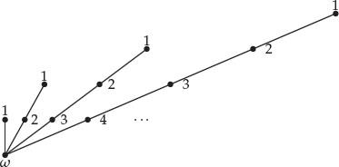

图 5.1 为一棵分支均有限的树标记序数。

**Figure 5.1.** Ordinals labelling a tree with only finite branches.

把 $U1$、$U2$、……的无切割证明拼接起来，就得到 $T$ 的一个证明，其中从 $U1$、$U2$、……推出 $T$ 的步骤必定是唯一的切割。因此，实际上 $T$ 是在 $U1$ 与 $U2$ 的无切割证明之后，通过切割规则从 $U1$ 与 $U2$ 推出的。若能消去这最后一次切割，就得到 $T$ 的无切割证明，产生矛盾，因此可以断定 $PAω$ 的所有定理都有无切割证明。

By putting cut-free proofs of $U1,U2,…$ together, we obtain a proof of $T$ in which the inference of $T$ from $U1,U2,…$ is necessarily the *only* cut. Thus in fact $T$ is inferred from $U1$ and $U2$ by the cut rule, following cutfree proofs of $U1$ and $U2$. Therefore, if this last cut can be eliminated we have a cut-free proof of $T$a contradiction—so we can conclude that all theorems of PA*<sub>ω</sub>* have cut-free proofs.

### 如何消去一次切割

### How to Eliminate a Cut

这涉及另一次归纳，这回是对所谓切割的度作归纳：

This involves another induction, this time on the so-called *degree* of the cut,

由 $ℬ∨A$ 和 $¬A∨C$ 推出 $ℬ∨C$，

$$from ℬ∨A and ¬A∨C infer ℬ∨C,$$

其度定义为语句 $¬A$ 的度，即 $¬A$ 中逻辑符号的个数。

which is defined to be the degree of the sentence $¬A$,that is, the number of logic symbols in $¬A$*.*

假设有一个定理 $T$ 的证明，其中只有最后一步出现切割。下面说明，如何用度较低的切割替换它，从而最终完全消去它；这些切割又可以替换为度更低的切割，如此继续，直到所有切割消失。根据 $A$ 形如 $¬A1$、$A1∨A2$ 或 $(∀x)A(x)$，分为三种情形。

Suppose that we have a proof of a theorem $T$ in which a cut occurs only at the very last step. We now show how to eliminate this cut altogether by replacing it by cuts of lower degree (which can then be replaced by cuts of still lower degree, and so on, until all cuts vanish). There are three cases, according as *A* has the form $¬A1,A1∨A2, or (∀x)A(x)$.

1. 当 A=¬A₁ 时，切割为：

   When $A=¬A1$ the cut is

   由 $ℬ∨¬A1$ 和 $¬¬A1∨C$ 推出 $ℬ∨C$，

   $$from ℬ∨¬A1 and ¬¬A1∨C infer ℬ∨C,$$

   这是某个证明的最后一步，该证明包含 $ℬ∨¬A1$ 和 $¬¬A1∨C$ 的无切割子证明。由第 4.3 节关于“圆满结尾”的讨论可知，可以安排 $¬¬A1∨C$ 的无切割证明，使其最后一步为

   and this is the last step in a proof that contains cut-free subproofs of $ℬ∨¬A1$ and $¬¬A1∨C$*.* We know from the “happy ending” remarks of Section 4.3 that the cut-free proof of $¬¬A1∨C$ can be arranged so that *its* last step is

   由 $A1∨C$ 推出 $¬¬A1∨C$。

   $$from A1∨C infer ¬¬A1∨C.$$

   这样，就能通过以下度较低的切割，推出定理 $T=ℬ∨C$：

   But then we can infer our theorem $T=ℬ∨C$ by the lower-degree cut

   由 $ℬ∨¬A1$ 和 $A1∨C$ 推出 $ℬ∨C$，

   $$from ℬ∨¬A1 and A1∨C infer ℬ∨C,$$

   其中 $A1∨C$ 是 $¬¬A1∨C$ 的证明中倒数第二个语句。

   where $A1∨C$ is the penultimate sentence in the proof of $¬¬A1∨C$.
2. 当 A=A₁∨A₂ 时，切割为：

   When $A=A1∨A2$ the cut is

   由 $ℬ∨(A1∨A2)$ 和 $¬(A1∨A2)∨C$ 推出 $ℬ∨C$，

   $$from ℬ∨(A1∨A2) and ¬(A1∨A2)∨C infer ℬ∨C,$$

   这是某个证明的最后一步，该证明包含 $ℬ∨(A1∨A2)$ 和 $¬(A1∨A2)∨C$ 的无切割子证明。同样，由第 4.3 节关于“圆满结尾”的讨论可知，可以安排 $¬(A1∨A2)∨C$ 的无切割证明，使其最后一步为

   and this is the last step in a proof that contains cut-free subproofs of $ℬ∨(A1∨A2)$ and $¬(A1∨A2)∨C$. Again we know, from the “happy ending” remarks of Section 4.3, that the cut-free proof of $¬(A1∨A2)∨C$ can be arranged so that *its* last step is

   由 $¬A1∨C$ 和 $¬A2∨C$ 推出 $¬(A1∨A2)∨C$。

   $$from ¬A1∨C and ¬A2∨C infer ¬(A1∨A2)∨C.$$

   这样，就能通过两次度较低的切割，推出定理 $T=ℬ∨C$：

   But then we can infer our theorem $T=ℬ∨C$ from two lower-degree cuts:

   由 $ℬ∨A1∨A2$ 和 $¬A1∨C$ 推出 $ℬ∨A2∨C$；再由 $ℬ∨A2∨C$ 和 $¬A2∨C$ 推出 $ℬ∨C$。

   $$from ℬ∨A1∨A2 and ¬A1∨C infer ℬ∨A2∨C, from ℬ∨A2∨C and ¬A2∨C infer ℬ∨C.$$
3. 当 A=(∀x)A(x) 时，切割为：

   When $A=(∀x)A(x)$ the cut is

   由 $ℬ∨(∀x)A(x)$ 和 $¬(∀x)A(x)∨C$ 推出 $ℬ∨C$，

   $$from ℬ∨(∀x)A(x) and ¬(∀x)A(x)∨C infer ℬ∨C,$$

   这是某个证明的最后一步，该证明包含 $ℬ∨(∀x)A(x)$ 和 $¬(∀x)A(x)∨C$ 的无切割子证明。这一次，由第 4.6 节关于“圆满结尾”的讨论可知，可以安排 $¬(∀x)A(x)∨C$ 的无切割证明，使其最后一步为

   and this is the last step in a proof that contains cut-free subproofs of $ℬ∨(∀x)A(x)$ and $¬(∀x)A(x)∨C$*.* Yet again we know, this time from the “happy ending” remarks of Section 4.6, that the cut-free proof of $¬(∀x)A(x)∨C$ can be arranged so that its last step is

   由 $¬A(a)∨C$ 推出 $¬(∀x)A(x)∨C$，

   $$from ¬A(a)∨C infer ¬(∀x)A(x)∨C,$$

   其中 $a$ 是某个正整数。另一方面，由类似的“圆满结尾”论证，也有 $ℬ∨(∀x)A(x)$ 的无切割证明，其最后一步从把 $(∀x)A(x)$ 分别替换为 A(1)、A(2)、A(3)、……所得到的全部语句推出结论。这些语句包含 $ℬ∨A(a)$，因此可以通过以下度较低的切割，得到定理 $T=ℬ∨C$：

   for some positive integer *a.* But we also have, by a similar “happy ending” argument, a cut-free proof of $ℬ∨(∀x)A(x)$ in which the last step derives it from all the sentences in which $(∀x)A(x)$ is replaced by $A(1),A(2),A(3),…$. These include $ℬ∨A(a)$, so we can obtain our theorem $T=ℬ∨C$ from the lower-degree cut

   由 $ℬ∨A(a)$ 和 $¬A(a)∨C$ 推出 $ℬ∨C$。

   $$from ℬ∨A(a) and ¬A(a)∨C infer ℬ∨C.$$

因此，在所有情形中，都能把 $T$ 的证明中唯一的切割替换为一到两次度较低的切割。读者也许会短暂担心，随着度降低，切割的个数会无限增长；但只要总是替换树中最先出现的切割，就不会如此。因此，$T$ 有一个无切割证明，从而 $PAω$ 的所有定理也都有无切割证明。

So in all cases we can replace the single cut in the proof of $T$ by one or two cuts of lower degree. The reader may feel momentary anxiety that the number of cuts may grow beyond all bounds as the degree is reduced, but this is not the case if one always replaces the first cut in the tree. Thus $T$ has a cut-free proof, and hence so do all theorems of PA*<sub>ω</sub>*.

### $PAω$ 与 PA 的一致性

### Consistency of PA<sub>ω</sub> and PA

逻辑的一条基本原理是，矛盾蕴涵任意命题；这在命题逻辑中可以证明。因此，若 $PAω$ 能证明任何矛盾，它也能证明假命题 $1=2$。但如刚才所示，若 $1=2$ 在 $PAω$ 中有证明，就有一个无切割证明。而由 $PAω$ 的非切割规则可清楚看出，$1=2$ 只有在某条公理中出现时，才可能出现在无切割证明的结论中；实际上并没有这样的公理。

One of the basic principles of logic, provable in propositional logic, is that a contradiction implies any proposition. Thus, if PA*<sub>ω</sub>* proves any contradiction, it also proves the false proposition 1 = 2. But if 1 = 2 has a proof in PA*<sub>ω</sub>* it has a cut-free proof, as we have just shown. And it is clear from the non-cut rules of PA*<sub>ω</sub>* that 1 = 2 can appear in the conclusion of a cut-free proof only if it appears in an axiom, which is not the case.

因此 $PAω$ 一致；又因为 PA 的所有定理都是 $PAω$ 的定理，PA 也一致。

Thus PA*<sub>ω</sub>* is consistent and hence so is PA, since all theorems of PA are theorems of PA*<sub>ω</sub>*.

## 5.6 这番宏伟论证的高度

## 5.6 The Height of This Great Argument

> 愿我攀上这番宏伟

> That to the highth of this great

> 论证的高处，

> Argument

> 以申明永恒的天意，并向世人阐明上帝行事之正当。

> I may assert Eternal Providence, And justifie the wayes of God to men.

> ——弥尔顿

> —Milton

> 《失乐园》，第 24–26 行。

> *Paradise Lost*, lines 24-26.

PA 的一致性证明最终依赖于超限归纳，因为消去切割时，假定了最小序数的存在。PA 的关键成分是有限序数上的归纳，因此确实可以说，我们在用超限归纳为普通归纳辩护。通常，这种“辩护”会被一笑置之，但在这里可以如下为它辩护。

The consistency proof for PA depends ultimately on transfinite induction, since we assume the existence of least ordinals in order to eliminate cuts. The key ingredient in PA is induction over finite ordinals, so it may truly be said that we are using transfinite induction to justify ordinary induction. Ordinarily, this kind of “justification” would be laughed out of court, but we can defend it in this case as follows.

- 由哥德尔第二不完备性定理可知，有限序数上的归纳，即“$ω$-归纳”，不能证明自身的一致性。因此，若 $ω$-归纳的强度可以度量，也只能用某个大于 $ω$ 的序数来度量。
- We know, from Gödel’s second incompleteness theorem, that induction over finite ordinals (“*ω*-induction”) cannot prove its own consistency. Thus the strength of *ω*-induction can be measured, if at all, only by some ordinal *greater* than *ω.*
- 根岑（1943）证明，对于任意小于 $ε0$ 的序数，直到该序数的归纳都可以在 PA 中证明。
- It was shown by Gentzen (1943) that induction up to any ordinal less than ε<sub>0</sub> canbe proved in PA.
- 因此，若 PA 的一致性可以通过直到 $ε0$ 的归纳证明，$ε0$ 就是 $ω$-归纳强度的精确度量。这样，一致性证明的“高度”就度量了 PA 的强度。
- Therefore, if the consistency of PA can be proved by induction up to ε<sub>0</sub>,then ε<sub>0</sub> is a precise measure of the strength of *ω*-induction. Thus the “height” of the consistency proof measures the strength of PA.

要了解这一辩护的细节，需要查阅证明论教材，例如 Troelstra 与 Schwichtenberg（1996）。不过，我们可以概述其中的思想。

To see the details of this defence, one needs to consult a textbook on proof theory, such as Troelstra and Schwichtenberg (1996). However, we can sketch the ideas involved.

### 在算术中编码超限归纳

### Encoding Transfinite Induction in Arithmetic

$ω$-归纳怎么可能蕴涵某些大于 $ω$ 的序数 $α$ 上的归纳？首先，需要用算术语言中的语句表达超限归纳；然后，需要用 $ω$-归纳证明这个语句。$ω2$-归纳的情形可以说明这两项任务。

How can it be that *ω*-induction implies induction up to (some) ordinals *α* greater than *ω*? First we need to *express* transfinite induction by a sentence in the language of arithmetic; then we need to *prove* the sentence by *ω*-induction. Both tasks may be illustrated by the case of *ω*<sup>2</sup>-induction.

首先，为正整数建立一个与序数 $ω2$ 具有相同序型的次序。这意味着，要把正整数按照小于 $ω2$ 的序数的模式排列：

We begin by setting up an ordering of the positive integers with the same order type as the ordinal *ω*<sup>2</sup>. This means finding an arrangement of positive integers in the pattern of the ordinals less than *ω*<sup>2</sup>:

$$1,2,3,…ω,ω+1,ω+2,…ω⋅2,ω⋅2+1,ω⋅2+2,…ω⋅3,ω⋅3+1     ω⋅3+2,…  .$$

也许最简单的排列如下：

Perhaps the simplest such arrangement is

$$1,3,5,…2,6,10,…4,12,20,…8,24,40,….$$

这个排列通过把每个正整数分解为 2 的幂与一个奇数的乘积 $2m(2n+1)$ 得到。若两个整数所含的 2 的幂不同，则幂较小者排在左边；若两个不同整数所含的 2 的幂相同，则奇因子较小者排在左边。

We obtain this arrangement by factorizing each positive integer into a power of 2 times an odd number: 2*<sup>m</sup>*(2*n* + 1). When two integers contain different powers of 2, the one with the smaller power of 2 is further to the left. And when two different integers contain the same power of 2, the one with the smaller odd factor is further to the left.

稍微形式化地说，用公式 $a<ω2b$ 表示“$a$ 在 $b$ 的左边”，对于正整数 $a$、$b$，它定义为

Putting this a little more formally, we denote “a is to the left of *b*”by the formula *a* *<**ω*<sup>2</sup> *b*, defined for positive integers *a* and *b* by

$$a<ω2b⇔(∃m)(∃n)(∃p)(∃q) [ a=2m(2n+1)∧b=2p(2q+1) ∧(m<p∨(m=p∧n<q))].$$

借助第 2.5 节给出的指数运算的归纳定义，可以用皮亚诺算术的语言表达这个次序。于是，$ω2$-归纳等价于以下陈述：对任意在某个正整数上成立的性质 $Ƥ$，都存在一个具有性质 $Ƥ$ 的“最小”正整数，这里的最小是按次序 $a<ω2b$ 而言。与 $ω$-归纳一样，只需对 PA 语言中可定义的性质 $Ƥ$ 作出这个陈述。因此，给定 $Ƥ$ 的公式，以及刚得到的 $a<ω2b$ 的公式，就能如下表达 $ω2$-归纳：

With the help of the inductive definition of exponentiation (given in Section 2.5) we can express this ordering in the language of Peano arithmetic. Then *ω*<sup>2</sup>-induction is equivalent to the statement that, *for any property Ƥ that holds for some positive integer, there is a “least” positive integer* (*in the sense of the ordering a* *<**ω*<sup>2</sup> *b with property Ƥ*. As with *ω*-induction, we need to make this statement only for properties *Ƥ* definable in the language of PA. Thus, given a formula for *Ƥ*, and the formula for *a* *<**ω*<sup>2</sup> *b* just obtained, we can express *ω*<sup>2</sup>-induction as follows:

$$(∃x)Ƥ(x)⇒(∃y)[Ƥ(y)∧(∀z)(z<ω2y⇒¬Ƥ(z))]$$

对于每个 $Ƥ$，都能借助 $ω$-归纳证明这个 $ω2$-归纳陈述。为找到具有性质 $Ƥ$ 的“最小” $y$，把每个具有性质 $Ƥ$ 的 $x$ 写成 $2m(2n+1)$。在这些 $x$ 中，先考虑 $m$ 最小的那些数，其存在性由 $ω$-归纳保证；再在其中取 $n$ 最小的那个数，其存在性同样由 $ω$-归纳保证。这样，就找到了按次序 $a<ω2b$ 而言具有性质 $Ƥ$ 的“最小” $x$，从而通过两次应用 $ω$-归纳证明了 $ω2$-归纳。显然，这个论证可以在 PA 中形式化。

For each *Ƥ*, we can prove this statement of *ω*-induction with the help of *ω*-induction. To find the “least” *y* with property *Ƥ*,write each *x* with property *Ƥ* in the form 2*<sup>m</sup>*(2*n* + 1).Among these numbers *x*, consider those with the least value of *m* (which exists by *ω*-induction). Among the latter, consider the one with the least value of *n* (which likewise exists by *ω*-induction). In this way we find the “least” *x* with property *Ƥ* (in the sense of the ordering *a* *<**ω*<sup>2</sup> *b*), thereby proving *ω*<sup>2</sup>-induction by two applications of *ω*-induction. It is clear that the argument can be formalized in PA.

推广这个论证，可以在 PA 中表达并证明许多可数序数 $α$ 上的 $α$-归纳，但并非所有。能够这样表达的 $α$ 显然有某个上界，因为可数序数有 $ℵ1$ 个，而 PA 的公式只有 $ℵ0$ 个。更有趣的是，我们证明 $α$-归纳的能力，弱于表达它的能力。

By elaborating on this argument we can express and prove a-induction in PA for many countable ordinals a, but not all. There is clearly some upper bound to the *α* for which such expressions exist, since there are ℵ<sub>1</sub> countable ordinals but only formulas of PA. More interestingly, our ability to prove a-induction falls short of our ability to express it.

如上所述，根岑证明了，对序数 $α<ε0$，$α$-归纳可以在 PA 中证明。他此前已用 $ε0$-归纳证明 PA 的一致性，也知道 $ε0$-归纳可以在 PA 中表达，因此可以断定：$ε0$-归纳在 PA 中可表达却不可证明，否则 PA 就能证明自身的一致性。

As mentioned above, Gentzen showed that a-induction can be proved in PA for the ordinals *α <* ε<sub>0</sub>. He had already proved the consistency of PA by ε<sub>0</sub>-induction, and he knew that ε<sub>0</sub>-induction can be expressed in PA, so he could conclude that ε<sub>0</sub>-induction is expressible but *not* provable in PA—otherwise PA would be able to prove its own consistency.

因此，根岑伟大一致性证明的“高度” $ε0$，精确确定了 PA 的一致性相对于 PA 各定理的位置。如果用那些使 $α$-归纳可证的序数 $α$ 来度量定理的“高度”，那么一致性的高度就是各定理高度的最小上界。根岑的证明还提示了一种用算术语句表达 PA 一致性的漂亮方法，即用一个表达 $ε0$-归纳的语句。如何定义所需的正整数次序也许还不清楚，但事实上，第 2 章讨论古德斯坦定理时，已经涉及一种适当方法。下一章将回到这个思想；不过，先要再谈一点 $ε0$。

Thus ε<sub>0</sub>—the “height” of Gentzen’s great consistency proof—pinpoints the *exact* position of the consistency of PA relative to the theorems of PA. If we measure the “heights” of theorems by the ordinals *α* for which *α-*induction is provable, then the height of consistency is the least upper bound of the heights of theorems. Gentzen’s proof also suggests a nice way to express the consistency of PA by an arithmetic sentence; namely, by a sentence that expresses *ε*<sub>0</sub>-induction. It may not be clear how to define the requisite ordering of positive integers, but in fact we already touched on a suitable method in the section on Goodstein’s theorem in Chapter 2. We return to this idea in the next chapter. But first we should say a little more about ε<sub>0</sub>.

### 为什么高度是 $ε0$

### Why the Height Is ε<sub>0</sub>

由第 2.1 节可知，$ε0$ 是以下序列的最小上界：

We know from Section 2.1 that ε<sub>0</sub> is the least upper bound of the sequence

$$ω, ωω, ωωω, ωωωω,….$$

因此，$ε0$ 是具有以下性质的最小序数 $β$：若 $α<β$，则 $ωα<β$。稍微宽松地说，$ε0$ 是“大于 $ω$ 且对指数运算封闭的最小序数”。

It follows that ε<sub>0</sub> *is the least ordinal β with the property that, if α < β,then ω<sup>α</sup> < β.* Speaking a little more loosely, ε<sub>0</sub> is the “least ordinal greater than *ω* that is closed under exponentiation.”

第 5.5 节的切割消去过程涉及指数运算。从 PA 中的一个证明出发，把它翻译为 $PAω$ 中的证明，得到一棵分支均有限、但顶点可能无限多的树。仔细分析 PA 中的证明，可以检验，相应 $PAω$ 证明树的序数 $α<ε0$。随后，分析切割消去过程可知，存在一个序数小于 $2α$ 的无切割证明 参见例如 Mendelson（1964）的附录。由于 $ε0$ 对指数运算封闭，这个无切割证明的序数也小于 $ε0$。因此，为证明消去过程中每一步都存在一个“最小”切割，所需的超限归纳就是直到 $ε0$ 的归纳。

这就是 $ε0$-归纳蕴涵 PA 一致性的原因。

This is why ε<sub>0</sub>-induction implies the consistency of PA.

## 5.7 通向无穷之路

## 5.7 Rüads to Infinity

> 因此，即使只是直到 $ε0$ 的超限归纳，也已不能从其余数论推理形式中推出；这个事实从一个新角度揭示了数论形式体系的不完备性，而哥德尔此前已从另一角度揭示了它。

> The fact that transfinite induction even up to the number *ε*<sub>0</sub> is no longer derivable from the remaining number-theoretical forms of inference therefore reveals from a new angle the *incompleteness* of the number-theoretical formalism, which has already been exposed by Gödel from a different point of view.

> ——格哈德$⋅$根岑（1943），载于 Gentzen（1969），第 307–308 页。

> —Gerhard Gentzen (1943), in Gentzen (1969), pp. 307-308.

集合论中的不可数性证明，与算术中的不可证明性证明之间，有一个非凡的平行关系。第 1 章介绍了第一种不可数性证明，通过对角线构造说明 $2ℵ0$ 不可数，特别是正整数集的子集有不可数多个。第 2 章介绍了第二种证明，说明可数序数有不可数多个。第二种证明给出了最小的不可数基数 $ℵ1$，而我们至今无法判定是否 $2ℵ0=ℵ1$。对角线论证只说明 $2ℵ0$ 不可数，却没有确定它“超出可数多远”。这当然就是连续统问题。

There is a remarkable parallel between the uncountability proofs in set theory and the unprovability proofs for arithmetic. In Chapter 1 we saw the first style of uncountability proof, showing that $2ℵ0$ is uncountable by diagonalization (in particular, there are uncountably many sets of positive integers). In Chapter 2 we saw a second style, showing that there are uncountably many countable ordinals. The second style of proof gives us the *smallest* uncountable cardinal ℵ<sub>1</sub>, and we are as yet unable to decide whether $2ℵ0=ℵ1$ The diagonal argument merely shows that $2ℵ0$ is uncountable; it does not determine “how far beyond countable” $2ℵ0$ is. This of course is the continuum problem.

第 3 章再次使用对角线论证，证明任何可靠的算术形式理论都不完备：有些真语句能表达却不能证明。而且，分析不完备性证明可知，表达皮亚诺算术一致性的语句 $Con(PA)$，就是这样一个真而不可证明的语句。然而，对角线论证仍然是相当粗糙的工具：它只说明 $Con(PA)$ 在 PA 中不可证，却不给出其“不可证明性的层级”。

In Chapter 3 we again used the diagonal argument to prove that any sound formal theory for arithmetic is incomplete. There are true sentences that it can express but cannot prove. Moreover, an analysis of the incompleteness proof shows that Con(PA), a sentence expressing the consistency of Peano arithmetic, is one such true but unprovable sentence. However, the diagonal argument is again a rather blunt instrument. It merely shows that Con(PA) is unprovable in PA; it does not give its “level of unprovability.”

下面说明如何找到 $Con(PA)$ 的“层级”。如第 5.5 和 5.6 节所见，$ε0$-归纳蕴涵 $Con(PA)$，而对每个 $α<ε0$，$α$-归纳在 PA 中可证。因此，$ε0$ 是使 $α$-归纳在 PA 中不可证的最小序数 $α$。从这个意义上说，$ε0$ 代表 PA 的不可证明语句的最低层级，而 $ε0$-归纳与 $Con(PA)$ 都出现在这个层级。

Here is how we can find the “level” of Con(PA). As we saw in Sections 5.5 and 5.6, Con(PA) is implied by εo-induction, and α-induction is provable in PA for each *α <* ε<sub>0.</sub> Thus ε<sub>0</sub> *is the least ordinal α for which α-induction is not provable in* PALn this sense, *ε*<sub>0</sub> represents the lowest level of unprovable sentences of PA, and this is the level where *ε*<sub>0</sub>-induction and Con(PA) occur.

对 $α<ε0$，$α$-归纳的可证明性由根岑（1943）给出。在同一篇论文中，他还直接证明 $ε0$-归纳在 PA 中不可证，也就是不假定 $Con(PA)$ 的不可证明性，不过必然仍须假定 PA 的一致性。

The provability of α-induction for *α < ε*<sub>0</sub> was shown by Gentzei (1943). In the same paper he also showed *directly*—that is, without as suming the unprovability of Con(PA), though necessarily assuming th consistency of PA—that *ε*<sub>0</sub>-induction is not provable in PA.

根岑直接证明 $ε0$-归纳在 PA 中不可证，漂亮地完成了集合论与 PA 之间的平行关系，因为它模拟了“$ℵ1$ 是最小不可数基数”的论证。请记住，$ℵ1$ 是所有可数序数的最小上界，因此若 $ℵ1$ 可数，它就小于自身。这也进一步支持了 $ε0$ 是 PA 高度的正确“度量”。

Gentzen’s direct proof that *ε*<sub>0</sub>-induction is unprovable in PA beautifully completes the parallel between settheoryandPA,bysimulating the argument that ℵ<sub>1</sub> is the smallest uncountable cardinal. (Remember: ℵ<sub>1</sub> is the least upper bound of the countable ordinals, so if K<sub>1</sub> is countable it is less than itself.) It also adds to the evidence that *ε*0 is the correct “measure” of the height of PA.

根岑不完备性定理

Gentzen’s incompleteness theorem

假定 PA 一致，则 $ε0$-归纳在 PA 中不可证明。

*Assuming PA is consistent, ε<sub>0</sub>-induction is not provable in* PA*.*

一方面，他说明，按其证明排序，PA 中一个 $α$-归纳证明的序数至少为 $α$。另一方面，其一致性证明的方法表明，PA 中任何证明的序数都小于 $ε0$。因此，若 $ε0$-归纳在 PA 中可证，$ε0$ 就小于自身！这个矛盾说明 $ε0$-归纳在 PA 中不可证。

On the one hand, he shows that a proof of α-induction in PA has ordinal at least *α* in his ordering of proofs. On the other hand, the methods of his consistency proof show that any proof in PA has ordinal less than ε<sub>0</sub>. So, if ε<sub>0</sub>-induction is provable in PA, then ε<sub>0</sub> is less than itself! This contradiction shows that ε<sub>0</sub>-induction is not provable in PA.

回顾一下：假定 PA 一致，现在已有两个 PA 中的不可证明语句，分别来自集合论论证的“微型化”。

To recapitulate: assuming consistency of PA, we now have two unprovable sentences of PA, arising from “miniaturization” of arguments from set theory.

- 哥德尔关于 $Con(PA)$ 在 PA 中不可证的证明，是集合论中“$2ℵ0$ 不可数”论证的微型化。
- Gödel’s proof that Con(PA) is unprovable in PA is a miniaturization of the argument in set theory that $2ℵ0$ is uncountable.
- 根岑关于 $ε0$-归纳在 PA 中不可证的证明，是“$ℵ1$ 是最小不可数基数”论证的微型化。
- Gentzen’s proof that ε<sub>0</sub>-induction is unprovable in PA is a miniaturization of the argument that ℵ<sub>1</sub> is the least uncountable cardinal.

在根岑所揭示的 PA 与集合论的平行关系中，$ε0$ 扮演 $ℵ1$ 的角色，因为 $ε0$ 是不能成为 PA 中某个证明高度的最小序数。

In Gentzen’s parallel between PA and set theory, *ε*<sub>0</sub> plays the role of ℵ<sub>1</sub>,because ε<sub>0</sub> is the least ordinal that is not the height of a proof in PA.

与集合论不平行的是，根岑定理说明 $ε0$-归纳蕴涵 $Con(PA)$。如已看到的，这意味着 $Con(PA)$ 与 $ε0$-归纳都出现在 $ε0$ 层级。因此，通过对角线构造得到不可证明语句，与通过序数构造得到不可证明语句，到达相同的不可证明性层级。在集合论中，我们仍不知道通向 $2ℵ0$ 的道路与通向 $ℵ1$ 的道路之间，层级差异若存在究竟是什么，这就是连续统问题。但在 PA 中，条条道路都通向 $ε0$！

What is *not* parallel to set theory is Gentzen’s theorem that ε<sub>0</sub>-induction implies Con(PA). This implies, as we have seen, that the sentences Con(PA) and *ε*<sub>0</sub>-induction both occur at level *ε*<sub>0</sub>. Thus, the diagonal construction of an unprovable sentence leads to the same level of unprovability as the ordinal construction. In set theory we still do not know the difference in level (if any) between the road to $2ℵ0$ and the road to ℵ<sub>1</sub>—thisisthe continuum problem. But in PA all roads lead to ε<sub>0</sub>!

## 5.8 历史背景

## 5.8 Historical Background

### 皮亚诺算术

### Peano Arithmetic

> 我大量借鉴了德国人 $H$. 格拉斯曼的工作，即 Grassmann（1861）。戴德金最近的著作（1888）也给了我极大帮助；其中敏锐地考察了关于数的基础问题。

> For proofs in arithmetic, I used Grassmann (1861). The recent work of Dedekind (1888) was also most useful to me; in it, questions pertaining to the foundations of numbers are acutely examined.

> ——朱塞佩$⋅$皮亚诺

> —Giuseppe Peano

> 《算术原理》（1889）序言，van Heijenoort（1967）英译。

> Preface to *Principles of Arithmetic* (1889), translated by van Heijenoort (1967).

“皮亚诺算术”的最初几步，是由极富独创性的德国数学家赫尔曼$⋅$格拉斯曼迈出的，他当时是一名中学教师。1861 年，他出版了供学校使用的《算术教科书》。书中用归纳定义加法和乘法，并证明其基本性质。特别是，格拉斯曼证明了这两种运算满足交换律、结合律与分配律：

The first steps in “Peano arithmetic” were taken by Hermann Grassmann, a highly original German mathematician who worked as a high school teacher. In 1861 he published a *Lehrbuch der Arithmetik* (Textbook of Arithmetic), intended for use in schools. In it, the operations of addition and multiplication are defined, and their basic properties proved, by induction. In particular, Grassmann proves that these two operations satisfy the commutative, associative, and distributive laws:

$$a+b=b+a, ab=ba,a+(b+c)=(a+b)+c, a(bc)=(ab)c, a(b+c)=ab+ac$$

谁说“新数学”只是 20 世纪 60 年代的一场愚行？！格拉斯曼也许不理解学生的需要，但毫无疑问，他比同时代的数学家更理解算术基础。即使最伟大的同行，若肯为 $ab=ba$ 这样的性质作辩护，给出的也只是天真解释。例如，狄利克雷 1867 年最前沿的《数论讲义》，要求读者考察一个长为 $a$、宽为 $b$ 的矩形，以确信 $ab=ba$。相比之下，格拉斯曼清楚表明，归纳才是算术的关键思想，尽管他还没有把归纳称为公理。

Who says “new math” was a folly of the 1960s?! Grassmann may not have understood his pupils’ needs, but there is no doubt that he understood the foundations of arithmetic better than his mathematical contemporaries. Even the greatest of them offered only naive justifications of properties such as *ab = ba*, if they bothered to justify them at all. For example, Dirichlet’s cutting-edge *Vorlesungen über Zahlentheorie* (Lectures on Number Theory) of 1867 asks the reader to consider a rectangle of length *a* and width *b* in order to be convinced that *ab = ba.* Grassmann, in contrast, makes it clear that induction is *the* crucial idea in arithmetic, though without going so far as to describe induction as an axiom.

理查德$⋅$戴德金以编辑狄利克雷著作开始其职业生涯，似乎没有读过格拉斯曼。他独立认识到归纳是关键思想，并进一步尝试用集合解释自然数的归纳性质。其中包括在 1888 年《数是什么，应该是什么？》中，对无穷存在性所作的如下大胆证明尝试，参见 Dedekind（1901），第 64 页。

Richard Dedekind, who began his career as Dirichlet’s editor, does not seem to have read Grassmann. He independently realized that induction is the crucial idea, and went further, attempting an *explanation* of the inductive property of natural numbers in terms of sets. This included the following bold attempt to *prove* that infinity exists, in his 1888 *Was sind und was sollen die Zahlen*—see Dedekind (1901), p. 64.

> 定理。存在无限系统。

> Theorem. There exist infinite systems.

> 证明。我的思想领域，即一切可以成为我思想对象的事物所组成的全体 $S$，是无限的。因为，若 $s$ 表示 $S$ 的一个元素，那么“$s$ 可以成为我的思想对象”这个思想 $s′$，本身也是 $S$ 的一个元素……因此 $S$ 无限，证毕。

> Proof. My own realm of thoughts, i.e., the totality *S* of all things which can be objects of my thought, is infinite. For if *s* signifies an element of S, then is the thought *s’*,that *s* canbe anobject of my thought, itself an element of *S* … Hence *S* is infinite, which was to be proved.

我略去了戴德金说明映射 $s$↦$s′$ 是 $S$ 与其某个真子集之间一一对应的部分。这部分在数学上没有问题，确实蕴涵 $S$ 无限。当然，问题在于，“可以成为我的思想对象的事物”这个概念完全不清楚，也不能免于悖论。因此，多数数学家认为戴德金的“证明”走得太远。不过无妨，我们可以退一步，把归纳取为公理；皮亚诺在 1889 年正是这样做的。

I have skipped the part where Dedekind shows that the map *s* ↦ *s*′ is a one-to-one correspondence between *S* and a proper subset of *S*.This part is mathematically sound and it *does* imply that *S* is infinite. The problem, of course, is that the concept of “things which can be objects of my thought” is not at all clear or safe from paradox. Because of this, most mathematicians regard Dedekind’s “proof” as a bridge too far. But no matter, we can take a step back and take induction as an *axiom*,which is what Peano did in 1889.

戴德金和皮亚诺都使用所谓二阶归纳公理，其中性质 $Ƥ$ 是自然数的任意性质，不一定能用算术形式语言定义。二阶公理很方便，因为它可以写成单个公式：

Both Dedekind and Peano used the so-called *second order* induction axiom, in which the property *Ƥ* is an arbitrary property of natural numbers, not necessarily one definable in the formal language of arithmetic. The second order axiom is convenient because it can be written as a single formula,

$$(∀Ƥ)[[Ƥ(1)∧(∀n)(Ƥ(n)⇒Ƥ(n+1))]⇒(∀n)Ƥ(n)]$$

二阶归纳的问题，最初并未被认识到：其基础二阶逻辑不像谓词逻辑那样性质良好。二阶逻辑允许 $∀$ 与 $∃$ 不仅作用于个体，也作用于性质，这排除了完备性定理和紧致性定理等结果。

The problem with second order induction, not realized at first, is that the underlying second order logic is not as well-behaved as predicate logic. Second order logic allows ∀ and ∃ to apply to properties as well as individuals, and this rules out completeness and compactness theorems, among other things.

在 20 世纪 20 年代谓词逻辑的影响下，出现了归纳的一阶版本：$Ƥ$ 必须能用公式表达，因此需要一个包含无限多条归纳公理的模式。谓词逻辑只允许量词 $∀$ 与 $∃$ 作用于个体，而不作用于性质，这带来许多优点。不过，直到哥德尔于 1929 年证明谓词逻辑的完备性与紧致性定理，这些优点才变得明显。

The idea (in Section 5.4) of cutting back to *first order* axioms, in which *Ƥ* is expressible by a formula and one needs a whole infinite schema of induction axioms, emerged under the influence of predicate logic in the 1920s. Predicate logic allows the quantifiers ∀ and ∃ to be applied only to individuals, not properties, and this brings many advantages. However, its advantages did not become apparent until Gödel proved the completeness and compactness theorems for predicate logic in 1929.

1930 年哥德尔的不完备性定理，蕴涵二阶逻辑的不完备性；再加上根岑对一阶算术的一致性证明（1936），进一步强化了这些优点。根岑实际上希望证明二阶算术的一致性，这也是希尔伯特最初想要的，但未能成功。若他成功了，也许我们仍会像皮亚诺那样定义“皮亚诺算术”！

The advantages were reinforced by his incompleteness theorems of 1930, which implies incompleteness of second order logic, and by Gentzen’s consistency proof for first order arithmetic, Gentzen (1936). Gentzen actually hoped to prove consistency of second order arithmetic (which was what Hilbert originally wanted), but did not succeed. If he had, perhaps we would still define “Peano arithmetic” as Peano did!

不过，这已不太可能发生。用根岑式方法，例如通过直到某个可数序数的归纳，证明二阶算术一致性的希望要小得多。无论如何，二阶算术远不止数论，它包含大量分析。能够谈论自然数的任意子集，就等价于能够谈论任意实数。许多经典分析定理，例如波尔查诺–魏尔斯特拉斯定理和海涅–博雷尔定理，在二阶算术相当小的片段中就能证明。关于二阶算术及其片段的全面研究，特别是分析方面，参见 Simpson（1999）。

However, this is no longer likely to happen. There is much less chance of a Gentzen-style consistency proof for second order arithmetic, say, using induction up to some countable ordinal. In any case, second order arithmetic is *much more* than number theory—it contains a great deal of analysis. Being able to talk about arbitrary sets of natural numbers is equivalent to being able to talk about arbitrary real numbers. Many classical theorems of analysis, such as the Bolzano-Weierstrass and Heine-Borel theorems, can be proved in quite small fragments of second order arithmetic. For a thorough study of second order arithmetic and its fragments, with special attention to analysis, see Simpson (1999).

### 序数与算术

### Ordinals and Arithmetic

> 现在也清楚了，为什么超限归纳规则是一致性证明所需的关键规则……编号为 1 的证明毕竟显然正确；而一旦确立了某个证明之前所有证明的正确性，该证明也就正确，因为选择证明次序时，恰恰使一个证明的正确性依赖于某些更早证明的正确性。

> Now it also becomes clear why it is the rule of transfinite induction that is needed as the crucial rule for the consistency proof … Proof number 1 is after all trivially correct; and once the correctness of all proofs preceding a particular proof has been established, the proof in question is also correct precisely because the ordering [of proofs] was chosen in such a way that the correctness of a proof depends on the correctness of certain earlier proofs.

> ——格哈德$⋅$根岑

> —Gerhard Gentzen

> 《数学中的无穷概念》，载于 Gentzen（1969），第 232 页。

> *The Concept of Infinity in Mathematics*, in Gentzen (1969), p. 232.

1900 年前后，博雷尔与哈代把序数同整数函数增长率联系起来的工作，最终被证明是极好的思想，但起初成果不多。如第 2.3 节所述，哈代错误地认为，所有可数序数都能以某种有效方式生成。策梅洛于 1904 年认识到选择公理在良序中的作用，也没有完全消除他的困惑。二十多年后，希尔伯特在《论无穷》中尝试证明连续统假设时，仍因对可数序数的混淆而受损。

The work of Borel and Hardy from around 1900, relating ordinals to the growth rate of integer functions, ultimately proved to be an excellent idea. But it did not yield much fruit at first. As mentioned in Section 2.3, Hardy erred in thinking that all countable ordinals can be generated in some effective way. His confusion was not completely dispelled by Zermelo’s recognition of the role of the axiom of choice in well-ordering in 1904. More than 20 years later, Hilbert’s attempt to prove the continuum hypothesis in his *On the Infinite* was marred by confusion about countable ordinals.

据我所知，根岑在 1936 年 PA 的一致性证明中引入序数，是全新的思想。他是在先尝试把 PA 归约到以布劳威尔“直觉主义”原则为基础的算术之后，才走上这条路的。实际上，他于 1933 年证明，若直觉主义算术一致，则 PA 也一致。这令人意外，因为直觉主义原则本应比经典数学更可靠；然而，它们竟与 PA 一样强，而 PA 的一致性不能在 PA 中证明。这意味着我们应该更信任 PA，还是更不信任直觉主义算术？

As far as I know, Gentzen’s introduction of ordinals in his 1936 consistency proof for PA was a completely new idea. He set off in this direction only after making an entirely different attempt to prove the consistency of PA by reducing it to an arithmetic based on the “intuitionist” principles of Brouwer. In effect, he proved in 1933 that if intuitionist arithmetic is consistent, then so is PA. This was a surprise, because intuitionist principles were supposed to be more reliable than classical mathematics. Yet, somehow they are just as strong as PA, whose consistency cannot be proved in PA. Does this mean we should have more faith in PA, or less faith in intuitionist arithmetic?

根岑的证明从未发表，因为哥德尔独立想到了同一思想，并于 1933 年发表。得知哥德尔的优先权后，根岑撤回了关于直觉主义算术的论文，作出了转向切割消去的重大决定。他于 1934 年成功从谓词逻辑中消去切割，并凭借对可数序数的杰出运用，于 1936 年证明 PA 的一致性。由于 PA 只需要直到 $ε0$ 的序数，他得以避免处理所有可数序数。作为证明的副产品，他发现了一类新的 PA 不可证明语句，即 $ε0$-归纳。

Gentzen’s proof was never published, because Gödel had the same idea independently, and published it in 1933. When Gentzen learned of Gödel’s priority, he withdrew his own paper on intuitionist arithmetic and made the fateful turn towards cut elimination. He succeeded in eliminating cuts from predicate logic in 1934, and proved consistency of PA in 1936, thanks to his brilliant use of countable ordinals. He was able to avoid working with *all* the countable ordinals because PA calls only for ordinals up to ε<sub>0</sub>. As a byproduct of his proof, he discovered a new type of unprovable sentence of PA, namely, *ε*<sub>0</sub>-induction.

$ε0$-归纳虽是有趣的 PA 不可证明语句，却与哥德尔的不可证明语句 $Con(PA)$ 面临同一种审美异议：这类语句并非自然产生于算术研究。古德斯坦（1944）的定理更接近“自然”不可证明语句的目标，因为它只涉及正整数上的加法、乘法与指数运算。如第 2.7 节所见，古德斯坦认识到，他的定理是 $ε0$-归纳的后果。下一章将给出古德斯坦定理的一种自然推广，它蕴涵 $ε0$-归纳，因此若 PA 一致，这个推广肯定不能在 PA 中证明。

While *ε*<sub>0</sub>-induction is an interesting unprovable sentence of PA, it is open to the same aesthetic objection as Gödel’s unprovable sentence Con(PA): such sentences do not arise naturally in the study of arithmetic. The theorem of Goodstein (1944) comes closer to the goal of a “natural” unprovable sentence, since it involves only the concepts of addition, multiplication, and exponentiation on positive integers. As we saw in Section 2.7, Goodstein realized that his theorem is a consequence of εo-induction. In the next chapter we give a natural generalization of Goodstein’s theorem that *implies ε*<sub>0</sub>-induction, hence the generalization is certainly not provable in PA (if PA is consistent).

原来的古德斯坦定理也不能在 PA 中证明，但这一事实更难确立。此后又经过三十年关于序数与 PA 关系的研究，人们才恰当理解古德斯坦定理。第一步由生于奥地利、在英国受教育的数学家格奥尔格$⋅$克赖泽尔于 1952 年迈出，他发现了可证可计算函数与序数递归函数之间的关系。

The original Goodstein theorem is not provable in PA either, but this fact is more difficult to establish. It took three further decades of research on the relation between ordinals and PA before Goodstein’s theorem was properly understood. The first step was taken by the Austrian-born (but English-educated) mathematician Georg Kreisel in 1952, who discovered a relationship between *provably computable* functions and *ordinal recursive* functions.

若 PA 证明，对每个自然数 $m$，f(m) 的计算都会停机，就称可计算函数 $f$ 是可证可计算的。把所有形如“对所有 $m$，f(m) 的计算停机”的定理列出来，再作对角线构造，就能拼出一个并非可证可计算的可计算函数。然而，对角线论证并未告诉我们，可证可计算函数究竟有什么特别之处。为此，需要根岑对 PA 中证明的分析。

Acomputable function *f* is said to be *provably* computable if PA proves that the computation of *f* (*m*) halts for each natural number *m*. It is possible to concoct a computable function that is not provably computable by listing all the theorems of the form “the computation of *f* (*m*) halts for all *m”* and making a diagonal construction. However, the diagonal argument does not tell us what, if anything, makes the provably computable functions special. For that we need Gentzen’s analysis of proofs in PA.

与 PA 的任何可证语句一样，“对所有 $m$，f(m) 的计算停机”必然具有某个序数 $α<ε0$。可以预期，$α$ 以某种方式限制 $f$ 的“复杂性”，但如何度量复杂性？一种方法是，对可数序数 $α$，通过 $α$-归纳定义可计算函数。正如对 $α<ε0$ 能在 PA 中表达 $α$-归纳，也能在 PA 中通过 $α$-归纳定义函数。假定定义中非归纳的部分在某种意义上简单，这样的函数 $f$ 就可计算，称为序数递归函数。克赖泽尔发现，可证可计算函数，恰好是序数 $α<ε0$ 对应的序数递归函数。

Like any provable sentence of PA, “the computation of *f* (*m*) halts for all m” necessarily has some ordinal *α <* ε<sub>0</sub>. It is to be expected that *α* somehow bounds how “complex” *f* can be, but how do we measure complexity? One way is to define computable functions by α-induction for countable ordinals α. Just as we can express α-induction in PA for *α <* ε<sub>0</sub>, we can define functions in PA by α-induction for *α <* ε<sub>0</sub>. Assuming that the non-inductive part of the definition is in some sense simple, such functions *f* are computable, in which case they are called *ordinal recursive.* Kreisel’s discovery was that the provably computable functions are precisely the ordinal recursive functions for ordinals *α < ε*<sub>0</sub>.

另一种度量可计算函数复杂性的方法是增长率。斯坦利$⋅$韦纳（1970）发现了这一点，漂亮地把可证明性与博雷尔、哈代早期的增长率思想联系起来。韦纳证明，可证可计算函数，恰好是那些增长率由所谓哈代层级中某个 $Hα$ 所界定的可计算函数，其中 $α<ε0$。关于哈代层级，详见第 6.5 节。因此，$ε0$ 再次充当皮亚诺算术中证明复杂性的最小上界。

Another way to measure complexity of computable functions is by rate of growth. This was discovered by Stanley Wainer (1970), elegantly connecting provability with the old growth-rate ideas of Borel and Hardy. Wainer showed that the provably computablefunctions areprecisely the computable functions whose growth rate is bounded by a function H in the so-called *Hardy hierarchy*,for some *α <* ε<sub>0</sub>.(For more on the Hardy hierarchy, see Section 6.5.) Thus *ε*<sub>0</sub> again plays the role of least upper bound to the complexity of proofs in Peano arithmetic.

由韦纳定理可知，若可计算函数 $f$ 比所有 $α<ε0$ 对应的 $Hα$ 都增长得更快，那么 $f$ 在 PA 中不是可证可计算的。这使我们能够找到许多新的 PA 不可证明语句，下一章就会看到。

It follows from Wainer’s theorem that, *if f is a computable function that grows faster than any Hu for α < ε*<sub>0</sub>*, then f is not provably computable in PA.* This allows us to find many new examples of sentences not provable in PA,as wewill see in the next chapter.

1 皮亚诺与戴德金针对正整数的任意性质 $Ƥ$ 陈述归纳 $(n→n+1)$。由第 1 章可知，这样的性质有不可数多个。这超过了我们的算术语言所能描述的范围，因为我们的语言，事实上任何人类可读的语言，都只包含可数多个符号串。这使完全一般的归纳陈述面临问题，因此通常只要求对能在一种表达能力适当丰富的语言中定义的性质使用归纳。毕竟，我们只想证明 PA 中可表达的语句，因此应当只需要 PA 中可表达的归纳实例。

Peano and Dedekind stated induction (*n* → *n* + 1) for *arbitrary* properties *Ƥ* of the positive integers. As we know from Chapter 1, there are uncountably many such properties. This is more than can be described in our language for arithmetic, because our language (and indeed, any language readable by humans) contains only countably many strings of symbols. This makes a completely general statement of induction problematic, and it is usual to require induction only for properties that can be defined in a reasonably expressive language. After all, we wish to prove only sentences expressible in PA, so we should need only instances of induction expressible in PA.

2 这不与第 4.7 节提到的柯尼希无穷引理矛盾，因为证明树中可能存在与无限多条边相接的顶点。

This does not contradict the König infinity lemma, mentioned in Section 4.7, because in a proof tree there may be vertices that meet an infinite number of edges.

# 第 6 章 自然的不可证明语句

# - Chapter 6 - Natural Unprovable Sentences

概览

Preview

本章回到古德斯坦定理，即第 2 章借助 $ε0$-归纳证明的结果。我们将找到它的一种自然推广，这个推广不仅是 $ε0$-归纳的后果，而且与之等价。因此，广义古德斯坦定理蕴涵 PA 的一致性，从而不能在 PA 中证明。这给出了第一个不能在 PA 中证明的自然定理的例子。

In this chapter we return to Goodstein’s theorem, the result proved in Chapter 2 with the help of *ε*<sub>0</sub>-induction. We find a natural generalization of Goodstein’s theorem that is not only a consequence of *ε*<sub>0</sub>-induction, but also *equivalent* to it. It follows that the generalized Goodstein theorem implies the consistency of PA, and hence it is not provable in PA. This gives us our first example of a natural theorem not provable in PA.

普通古德斯坦定理本身也不能在 PA 中证明，但要说明这一点，需要对序数与证明作更精细的分析，其中涉及与可数序数相关的快速增长函数。我们将概述对古德斯坦定理如何进行这种分析，并介绍其他一些定理，其在 PA 中的不可证明性同样与快速增长函数相联系。

The ordinary Goodstein theorem is itself not provable in PA, but showing this requires a more delicate analysis of ordinals and proofs, involving fast-growing functions associated with countable ordinals. We outline how this is done for Goodstein’s theorem, and describe some other theorems whose unprovability in PA is similarly tied to fast-growing functions.

这些其他不可证明定理，来自组合数学中广受关注的领域：拉姆齐理论与图论。在两个领域中，我们都将展示涉及快速增长函数的自然问题。拉姆齐理论例子的增长率与古德斯坦函数相似，因此相应的不可证明定理，即帕里斯–哈林顿定理，与古德斯坦定理处于相似层级。

These other unprovable theorems lie in popular areas of combinatorics—Ramsey theory and graph theory. In both areas we exhibit natural problems involving fast-growing functions. The Ramsey theory example has a growth rate similar to that of the Goodstein function, so the corresponding unprovable theorem—the *Paris-Harrington theorem*—lies at a level similar to that of Goodstein’s theorem.

图论中有两个非凡的定理，克鲁斯卡尔定理与图子式定理，它们处于更高层级。因此，只有从远强于 $ε0$-归纳的无穷假设出发，才能证明这些定理。

In graph theory there are two remarkable theorems, *Kruskal’s theorem* and the *graph minor theorem*, lying at an even higher level. Thus the latter theorems are provable only from assumptions about infinity much stronger than ε<sub>0</sub>-induction.

## 6.1 广义古德斯坦定理

## 6.1 A Generalized Goodstein Theorem

回顾第 2.7 节介绍的古德斯坦过程。它从一个写成以 2 为底的康托尔标准形的正整数 $m1$ 开始。例如，可以从下式开始：

Recall the *Goodstein process* introduced in Section 2.7. It starts with a positive integer *m1* written in base 2 Cantor normal form. For example, we might start with

$$m1=27=24+23+2+1=222+22+1+2+1.$$

接着，把每个 2 替换为 3，在这个例子中得到

Next, replace each 2 by a 3, obtaining (in this case)

$$n1=333+33+1+3+1,$$

然后减去 1。把所得的数写成以 3 为底的康托尔标准形，本例中为

and subtract 1. The resulting number is written in base 3 Cantor normal form, in this case

$$m2=333+33+1+3.$$

随后，对新底数 3 继续这一过程，把它替换为 4，再减去 1。简而言之，古德斯坦过程交替执行两种操作：把一个以 $k$ 为底的数中的每个 $k$ 替换为 $k+1$，再减去 1，从而产生一个分别以 2、3、4、5、……为底、写成康托尔标准形的数列。古德斯坦定理说，对任意初始数 $m1$，这个过程都会终止。

Then the process continues with the new base 3, replacing it by 4 and again subtracting 1. In a nutshell, the Goodstein process produces a sequence of numbers in Cantor normal form with respective bases 2, 3, 4, 5,…, by alternately replacing each *k* in a base *k* number by *k* + 1, and subtracting 1. *Goodstein’s theorem* states that the process terminates for any initial number *m*<sub>1</sub>.

如第 2.7 节所见，一旦发现古德斯坦过程背后潜藏的可数序数，证明就很容易了。对每个以 $k$ 为底、写成康托尔标准形的数 $mk−1$，把其表达式中的每个 $k$ 替换为 $ω$，就能对应一个康托尔标准形序数。例如，在当前例子中，

The proof, as we saw in Section 2.7, is easy once one spots the countable ordinals lurking in the shadows of the Goodstein process. We can associate each base *k* Cantor normal form number *m<sub>k</sub>*<sub>−1</sub> with a *Cantor normal form ordinal* by replacing each *k* in the base *k* expression for *m<sub>k</sub>*<sub>−1</sub> by *ω*. In the present case, for example,

$$m1=222+22+1+2+1,  so  α1=ωωω+ωω+1+ω+1.$$

因此，把 $k$ 替换为 $k+1$ 时，序数保持不变；减去 1 时，序数则减小。继续当前例子，得到

It follows that *the ordinal remains the same when we replace k by k* + 1, and *the ordinal decreases when we subtract* 1. Thus, continuing the present example, we have

$$m2=333+33+1+3, 并且 α2=ωωω+ωω+1+ω.$$

$$m2=333+33+1+3, and α2=ωωω+ωω+1+ω.$$

由于任何严格递减的序数序列都是有限的，古德斯坦定理随即成立。事实上，证明中使用的康托尔标准形序数都小于 $ε0$，因此只需对小于 $ε0$ 的序数假定这种递减序列性质。换言之，古德斯坦定理由所谓直到 $ε0$ 的超限归纳推出。

Goodstein’s theorem follows because *any decreasing sequence of ordinals is finite.* In fact, since the Cantor normal form ordinals used in the proof are all less than *ε*<sub>0</sub>, we need assume the decreasing sequence property only for the ordinals less than *ε*<sub>0</sub>. In other words, Goodstein’s theorem follows by what may be called *transfinite induction up to ε*<sub>0</sub>.

一旦看到它与递减序数序列的联系，就清楚了：古德斯坦过程的许多变体，都因完全相同的理由而终止。不必把 $k$ 替换为 $k+1$， 而可以把 $k$ 替换为任意整数 $k′>k$，序数仍不改变。因此，只要增大底数与减去 1 交替进行，过程仍必定终止。把以下过程称为一般古德斯坦过程：交替地，把整数以 $k$ 为底的康托尔标准形中的每个 $k$ 替换为任意 $k′≥k$，从而得到以 $k′$ 为底的标准形整数，再减去 1。于是有：

As soon as one sees the connection with decreasing sequences of ordinals, it becomes clear that many variations of the Goodstein process terminate for exactly the same reason. Instead of replacing *k* with *k* + 1 one can replace *k* by *any* integer *k*′ *> k* and the ordinal does not change, so the process still must terminate if these base increases alternate with subtractions of 1. Let us call a process that alternates between replacing each *k* in the base *k* Cantor normal form of an integer by any *k*′ ≥ *k* (thus obtaining an integer in base *k<sup>’</sup>* normal form) with subtraction of 1 a *general Goodstein* process.Then we have:

广义古德斯坦定理。对任意正整数施行一般古德斯坦过程，都会在有限步后终止。

Generalized Goodstein theorem. *A general Goodstein process, applied to any positive integer, terminates in a finite number of steps.*

证明：对直到 $ε0$ 的序数作超限归纳。□

*Proof* : By transfinite induction up to *ε*<sub>0</sub>. □

## 6.2 通过自然数理解可数序数

## 6.2 Countable Ordinals via Natural Numbers

上一节的要点是，$ε0$-归纳蕴涵广义古德斯坦定理。事实上，也能证明广义古德斯坦定理蕴涵 $ε0$-归纳，因此二者在某种意义上“等价”。“等价”的确切含义，取决于证明两个蕴涵时需要作出多少假设，这个问题暂且搁置。首先要说明，广义古德斯坦定理蕴涵 $ε0$-归纳。有了某种证明之后，再仔细检查假设。

The gist of the previous section is that ε<sub>0</sub>-induction implies the generalized Goodstein theorem. In fact, we can also prove that the generalized Goodstein theorem implies *ε*<sub>0</sub>-induction, so generalized Goodstein and *ε*<sub>0</sub>-induction are “equivalent” in some sense. The exact meaning of “equivalent” depends on how much we need to assume in proving the two implications—a question we defer for the moment. First, we need to see that generalized Goodstein implies *ε*o-induction. After we have some kind of proof, we can look more closely at our assumptions.

为找到从广义古德斯坦定理通向 $ε0$-归纳的路径，先考察一张列出所有正整数康托尔标准形的表。表 6.1 是其开头部分：最左列向上列出所有正整数，第二、第三、第四、……列，分别列出每个正整数以 2、3、4、……为底的康托尔标准形。

To find a route from the generalized Goodstein theorem to *ε*<sub>0</sub>-induction, we begin by looking at a table of Cantor normal forms of all the positive integers. Table 6.1 is the beginning of such a table, whose leftmost column lists (in the upward direction) all the positive integers, and whose second, third, fourth, … columns contain the Cantor normal forms of each positive integer in bases 2, 3, 4,… respectively.

第 $k$ 列的每个表项，都是以 $k$ 为底的康托尔标准形，也就是把某个经典康托尔标准形中的每个符号 $ω$ 替换为 $k$ 所得到的实例。例如，5 的以 2 为底的康托尔标准形 $22+1$，是经典标准形 $ωω+1$ 的实例；10 的以 3 为底的标准形 $32+1$，是经典标准形 $ω2+1$ 的实例。反过来，每个经典康托尔标准形 $φ$ 在表中都有实例；它们恰好出现在底数 $k$ 大于 $φ$ 中所有整数的各列。例如，康托尔标准形

Each entry in column *k* is a base *k* Cantor normal form, that is, an instance of a classical Cantor normal form, obtained by replacing each symbol *ω* by *k*. For example, the base 2 Cantor normal form 2<sup>2</sup> + 1 of 5 is an instance of the classical Cantor normal form *ω<sup>ω</sup>* + 1, and the base 3 Cantor normal form 3<sup>2</sup> + 1 of 10 is an instance of the classical Cantor normal form *ω*<sup>2</sup> + 1. Conversely, each classical Cantor normal form *φ* has instances in the table. They occur for precisely the bases *k* greater than all the integers occurring in the form *φ.* For example, there is an instance of the Cantor normal form

$$φ=ω2+1$$

在所有 $k>2$ 的列中都有实例，即数 $k2+1$。

in all columns *k >* 2, namely the number *k*<sup>2</sup> + 1.

表 6.2 给出与表 6.1 各表项对应的经典康托尔标准形。

Table 6.2 shows the classical Cantor normal forms associated with the entries in Table 6.1.

表 6.1 正整数以 2、3、4、……为底的康托尔标准形。 Table 6.1 Base 2, 3, 4, … Cantor normal forms of the positive integers.

| ⋮ | ⋮ | ⋮ | ⋮ | ⋮ | ⋮ |  |
| --- | --- | --- | --- | --- | --- | --- |
| 16 | $⋮222$ | 3<sup>2</sup> + 3 · 2 + 1 | 4<sup>2</sup> | 5 · 3 + 1 | 6 · 2 + 4 |  |
| 15 | 2<sup>2+1</sup> + 2<sup>2</sup> + 2 + l | 3<sup>2</sup> + 3 · 2 | 4 · 3 + 3 | 5 · 3 | 6 · 2 + 3 |  |
| 14 | 2<sup>2+1</sup> + 2<sup>2</sup> + 2 | 3<sup>2</sup> + 3 + 2 | 4 · 3 + 2 | 5 · 2 + 4 | 6 · 2 + 2 |  |
| 13 | 2<sup>2+1</sup> + 2<sup>2</sup> + l | 3<sup>2</sup> + 3 + 1 | 4 · 3 + 1 | 5 · 2 + 3 | 6 · 2 + 1 |  |
| 12 | 2<sup>2+l</sup> + 2<sup>2</sup> | 3<sup>2</sup> + 3 | 4 · 3 | 5 · 2 + 2 | 6 · 2 |  |
| 11 | 2<sup>2+1</sup> + 2 + 1 | 3<sup>2</sup> + 2 | 4 · 2 + 3 | 5 · 2 + 1 | 6 + 5 |  |
| 10 | 2<sup>2+1</sup> + 2 | 3<sup>2</sup> + 1 | 4 · 2 + 2 | 5 · 2 | 6 + 4 |  |
| 9 | 2<sup>2+l</sup> + 1 | 3<sup>2</sup> | 4 · 2 + 1 | 5 + 4 | 6 + 3 |  |
| 8 | 2<sup>2+l</sup> | 3 · 2 + 2 | 4 · 2 | 5 + 3 | 6 + 2 |  |
| 7 | 2<sup>2</sup> + 2 + 1 | 3 · 2 + 1 | 4 + 3 | 5 + 2 | 6 + 1 |  |
| 6 | 2<sup>2</sup> + 2 | 3 · 2 | 4 + 2 | 5 + 1 | 6 |  |
| 5 | 2<sup>2</sup> + 1 | 3 + 2 | 4 + 1 | 5 | 5 |  |
| 4 | 2<sup>2</sup> | 3 + 1 | 4 | 4 | 4 |  |
| 3 | 2 + 1 | 3 | 3 | 3 | 3 |  |
| 2 | 2 | 2 | 2 | 2 | 2 |  |
| 1 | 1 | 1 | 1 | 1 | 1 |  |
|  | base 2 | base 3 | base 4 | base 5 | base 6 | ⋯ |

现在暂且忘记经典康托尔标准形表示序数。来看看，要证明这些对象构成良序，需要什么。

Now forget for the moment that classical Cantor forms represent ordinals. Let us see what it takes to *prove* that these objects are well ordered.

首先定义康托尔标准形的次序。这可以对标准形的所谓高度作普通归纳来完成；高度就是指数的层数。高度为 0 的标准形就是正整数 1、2、3、4、……，按通常方式排序。然后，若

First we define the ordering of Cantor normal forms. This can be done by ordinary induction on what may be called the *height* of the form—the number of levels of exponents. The forms of height 0 are simply the positive integers 1, 2, 3, 4, …, and these are ordered in the usual way. Then if

$$φ=ωα1⋅m1+ωα2⋅m2+⋯+ωαi⋅mi$$

是高度为 $h+1$ 的标准形，就意味着 $α1$、$α2$、……、$αi$ 的最大高度为 $h$。因此，根据归纳假设，可以假定这些指数的次序已定义，并可设

is a form of height *h +* 1, this means that the maximum height of *α*<sub>1</sub>*, α*<sub>2</sub>*, …, a<sub>i</sub>* is *h*. We may therefore assume, by induction, that the order of these exponents is already defined, and we may take it that

$$α1≻α2≻⋯≻αi$$

$$ψ=ωβ1⋅n1+ωβ2⋅n2+⋯+ωβj⋅nj,$$

其中 $≻$ 表示经典康托尔标准形的次序。给定另一个高度为 $h+1$ 的标准形，同样可设 $β1≻β2≻$⋯$≻βj$，并且知道所有指数 $α$ 与 $β$ 的次序。于是，$φ≻ψ$ 当且仅当，在 $φ$ 与 $ψ$ 首次不同的指数处有 $α$ₖ$≻β$ₖ；或者，若指数相同，在首次不同的系数处有 $mj≻nj$。由于 $mj$ 与 $nj$ 是整数，后者就是 $mj>nj$。

where *≻* denotes the ordering of classical Cantor normal forms. Given another form of height *h* + 1, we may likewise assume that *β*<sub>1</sub> ≻ *β*<sub>2</sub> ≻ *·* ≻ *β<sub>j</sub>*, and that we know the order of all the exponents *α* and *β*.Then *φ* ≻ *ψ* if and only if *α<sub>k</sub>* ≻ *β<sub>k</sub>* at the firstexponentwhere *φ* and *ψ* differ, or (if all exponents are the same) that *m<sub>j</sub>* ≻ *n<sub>j</sub>* at the first coefficient where they differ (which is the same as *m<sub>j</sub> > n<sub>j</sub>*,since *m<sub>j</sub>* and *n<sub>j</sub>* are integers).

表 6.2 与表 6.1 各表项对应的经典康托尔标准形。 Table 6.2 Classical Cantor normal forms for the entries in Table 6.1.

| ⋮ | ⋮ | ⋮ | ⋮ | ⋮ | ⋮ |  |
| --- | --- | --- | --- | --- | --- | --- |
| 16 | $⋮ωωω$ | *ω*<sup>2</sup> + *ω* · 2 + 1 | *ω*<sup>2</sup> | *ω ·* 3 + 1 | *ω ·* 2 + 4 |  |
| 15 | *ω<sup>ω+</sup>*<sup>1</sup>*+ω<sup>ω</sup> + ω +* 1 | *ω*<sup>2</sup> + *ω* · 2 | *ω* · 3 + 3 | *ω ·* 3 | *ω ·* 2 + 3 |  |
| 14 | *ω<sup>ω+</sup>*<sup>1</sup> *+ ω<sup>ω</sup> + ω* | *ω*<sup>2</sup> + *ω +* 2 | *ω* · 3 + 2 | *ω* · 2 + 4 | *ω ·* 2 + 2 |  |
| 13 | *ω<sup>ω+</sup>*<sup>1</sup> *+ ω<sup>ω</sup> +* 1 | *ω*<sup>2</sup> + *ω +* 1 | *ω* · 3 + 1 | *ω ·* 2 + 3 | *ω ·* 2 + 1 |  |
| 12 | *ω<sup>ω+</sup>*<sup>1</sup> *+ ω<sup>ω</sup>* | *ω*<sup>2</sup> + *ω* | *ω* · 3 | *ω ·* 2 + 2 | *ω ·* 2 |  |
| 11 | *ω<sup>ω+</sup>*<sup>1</sup>*+ω +* 1 | *ω*<sup>2</sup> *+* 2 | *ω* · 2 + 3 | *ω ·* 2 + 1 | *ω* + 5 |  |
| 10 | *ω<sup>ω+</sup>*<sup>1</sup>*+ω* | *ω*<sup>2</sup> +1 | *ω* · 2 + 2 | *ω ·* 2 | *ω +* 4 |  |
| 9 | *ω<sup>ω+</sup>*<sup>1</sup> *+* 1 | *ω*<sup>2</sup> | *ω ·* 2 + 1 | *ω +* 4 | *ω +* 3 |  |
| 8 | *ω<sup>ω+</sup>*<sup>1</sup> | *ω ·* 2 + 2 | *ω ·* 2 | *ω* + 3 | *ω* + 2 |  |
| 7 | *ω<sup>ω</sup> + ω +* 1 | *ω ·* 2 + 1 | *ω +* 3 | *ω +* 2 | *ω +*1 |  |
| 6 | *ω<sup>ω</sup> + ω* | *ω ·* 2 | *ω* + 2 | *ω +*1 | *ω* |  |
| 5 | *ω<sup>ω</sup>* + 1 | *ω +* 2 | *ω +*1 | *ω* | 5 |  |
| 4 | *ω<sup>ω</sup>* | *ω +*1 | *ω* | 4 | 4 |  |
| 3 | *ω +*1 | *ω* | 3 | 3 | 3 |  |
| 2 | *ω* | 2 | 2 | 2 | 2 |  |
| 1 | 1 | 1 | 1 | 1 | 1 |  |
|  | base 2 | base 3 | base 4 | base 5 | base 6 | ⋯ |

由这个次序的定义可清楚看出，康托尔标准形构成线序，也称全序。也就是说，两个不同标准形 $φ$ 与 $ψ$，总有 $φ≻ψ$ 或 $ψ≻φ$。事实上，次序 $≻$ 的定义及其线序性质的证明，都可以在皮亚诺算术，即第 5.3 节的 PA 理论中完成。康托尔标准形可以用自然数编码，而线序性质可借助普通归纳，以及 PA 中可证的加法、乘法和指数运算性质来证明。

It is clear from the definition of this ordering that the Cantor normal forms are *linearly*, or*totally*, ordered. That is, if *φ* and *ψ* are two forms then either *φ* ≻ *ψ* or *ψ* ≻ *φ.* In fact, the definition of the ordering *y* and the proof that it is linear can be carried out in Peano Arithmetic (the theory PA described in Section 5.3). The Cantor normal forms can be encoded by natural numbers, and the linear order properties can be proved with the help of ordinary induction and properties of addition, multiplication, and exponentiation provable in PA.

证明康托尔标准形构成良序，则是另一回事。这恰好就是 $ε0$ 的良序性质，因此，由第 3 和第 5 章的理由可知，它不能在 PA 中证明。$ε0$ 的良序性蕴涵 PA 的一致性，见第 5 章；而由哥德尔第二不完备性定理，PA 的一致性不能在 PA 中证明，见第 3 章。

It is a different matter to prove that Cantor normal forms are *well* ordered. This is precisely the well-ordering property of *ε*<sub>0</sub>,so it is *not* provable in PA for the reasons we saw in Chapters 3 and 5. The well-ordering of *ε*<sub>0</sub> implies the consistency of PA(Chapter 5), which is not provable in PA by Gödel’s second incompleteness theorem (Chapter 3).

尽管如此，康托尔标准形的良序性，仍可从某些关于自然数的自然陈述推出。其中之一就是广义古德斯坦定理，下一节将说明这一点。

Nevertheless, it is possible to deduce the well-ordering of Cantor normal forms from certain natural statements about natural numbers. One of these is the generalized Goodstein theorem, as we will see in the next section.

## 6.3 从广义古德斯坦定理到良序性

## 6.3 From Generalized Goodstein to Well-Ordering

以 2、3、4、……为底的康托尔标准形，显然与经典康托尔标准形密切相关，因此，一般古德斯坦过程与经典康托尔标准形中的下降过程也相关。澄清这些关系之后，就能看出如何从广义古德斯坦定理推出 $ε0$ 的良序性。

The Cantor normal forms of base 2, 3, 4, … obviously have a close relationship with the classical Cantor normal forms, and a general Goodstein process is thereby related to a process of descent through classical Cantor normal forms. When these relationships are clarified, a deduction of *ε*<sub>0</sub> well-ordering from the generalized Goodstein theorem comes into view.

事实上，仔细看表 6.1 和 6.2，就能窥见这种关系。经典康托尔标准形可以视为以底数为自变量的“图像”，其点落在穿过表 6.2 的曲线上。例如，值 $ω$ 位于一条从“底数 2”列开始、斜率为 1 的直线上；值 $ω+1$ 位于另一条平行直线上，也从“底数 2”列开始；值 $ω⋅2$ 位于一条从“底数 3”列开始、斜率为 2 的直线上；值 $ω2$ 位于一条从“底数 3”列开始的抛物线上，依此类推。从两张表看，经典康托尔标准形的图像似乎按正确次序层层排列，而这个次序来自表 6.1 各列内部数的次序。图 6.1 显示部分标准形的图像及其排序。

In fact, one can catch a glimpse of the relationship by staring at Tables 6.1 and 6.2. The classical Cantor normal forms are “graphs” (functions of the base) visible as points on curves that can be drawn through Table 6.2. For example: the values *ω* lie on a line of slope 1 starting in the “base 2” column; the values *ω* + 1 lie on a parallel line, also starting in the”base 2” column; the values *ω ·* 2 lie along a line of slope 2 starting in the “base 3” column; the values *ω*<sup>2</sup> lie along a parabola starting in the “base 3” column; and so on. It appears, from Tables 6.1 and 6.2, that the graphs of the classical Cantor normal forms are stacked up in their correct order, and that this ordering arises from the ordering of numbers within the columns of Table 6.1. Figure 6.1 shows the graphs for some of the normal forms, and their ordering.

需要澄清的主要问题，是经典康托尔标准形的次序 $≻$ 与自然数次序 $>$ 之间的关系。为描述这种关系，用 $α$、$β$、……等希腊字母表示经典标准形，并用 $α(k)$ 表示把 $α$ 中的 $ω$ 替换为 $k$ 后得到的以 $k$ 为底的康托尔标准形。例如，若

The main point to be clarified is the relationship between the ordering ≻ of classical Cantor normal forms and the ordering > of natural numbers. To describe this relationship we denote classical normal forms by Greek letters such as *α*,*β*,…, and let *α*(*k*) denote the base *k* Cantor normal form that results from *α* by replacing *ω* by *k*. For example, if

$$α=ωω+ω2+3$$

则

then

$$α(4)=44+42+3, α(5)=55+52+3, 并且 因此 on.$$

$$α(4)=44+42+3, α(5)=55+52+3,  and so on.$$

为避免得到并非以 $k$ 为底的康托尔标准形的表达式，只在 $k$ 大于 $α$ 中出现的所有正整数时，才定义 $α(k)$。于是有：

To avoid getting expressions that are not base *k* Cantor normal forms, we define α(*k*) only for *k* greater than the positive integers occurring in *α*. Then we have:

$≻$ 与 $>$ 的相容性。若 $α$、$β$ 是任意经典康托尔标准形，且正整数 $k$ 大于 $α$、$β$ 中出现的所有整数，那么 $α≻β$ 当且仅当 $α(k)>β(k)$。

Compatibility of ≻ and >. *If α and ß are any classical Cantor normal forms and k is a positive integer greater than the integers occurring in α and β, then α* ≻ *β if and only if α*(*k*) *> β*(*k*)*.*

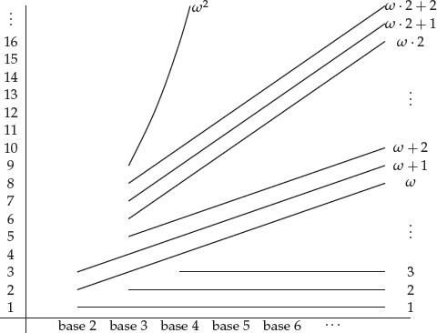

图 6.1 作为函数图像的康托尔标准形。

**Figure 6.1.** Cantor normal forms as graphs.

这可以通过对高度作普通归纳来证明，思路与上一节定义 $≻$ 时类似。由 $≻$ 与 $>$ 的相容性可知，若 $α≻β$，则表 6.1 中每个 $α(k)$，都位于对应 $β(k)$ 的上方，前提是后者存在。因此，若 $α(k)$ 是表 6.1 第 $k$ 列中表示 $α$ 的一个数，且 $α≻β$，就能如下从 $α(k)$ 到达一个表示 $β$ 的数 $β(l)$：

This is proved by an ordinary induction on height, along similar lines to the definition of *y* in the previous section. It follows from the compatibility of ≻ and *>* that, *if α* ≻ *β, each occurrence of α*(*k*) *in Table 6.1 lies above the corresponding occurrence of β*(*k*) (if it exists). Therefore, if *α*(*k*) is a number in column *k* of Table 6.1 representing a,and *α* ≻ *β*,then we can travel from *α*(*k*) to a number *β*(*l*) representing *β* as follows:

- 把以 $k$ 为底的标准形 $α(k)$ 中的每个 $k$ 替换为 $l$，其中 $l$ 大于 $k$，也大于康托尔标准形 $β$ 中的所有整数，以保证 $β(l)$ 存在。
- Replace each *k* in the base *k* form *α*(*k*) by *l*,where *l* is greater than *k* and all the integers in the Cantor normal form *β* (so that *β*(*l*) exists).
- 对所得标准形 $α(l)$，保持底数 $l$ 不变，连续减去 1 共 $α(l)−β(l)$ 次，从而得到 $β(l)$。
- Subtract 1 from the resulting form *α*(*l*) (keeping the base fixed at *l*) *α*(*l*) − *β*(*l*) times, thus obtaining *β*(*l*).

用图 6.1 的直观语言说，要从 $α$ 的图像下降到 $β<α$ 的图像，先沿 $α$ 的图像向右，从底数 $k$ 移到一个使 $β$ 的图像有定义的底数 $l$，然后沿底数 $l$ 那一列竖直下降。例如，若位于底数 2 处的 $ω$ 图像上，想下降到 3 的图像，必须先把底数增至 4，再减去 1，就能在底数 4 那一列从 $ω$ 的图像下降到 3 的图像。

In the more visual terms of Figure 6.1, we descend from the graph of *α* to the graph of *β < α* by first traveling to the right on the graph of *α*, from base *k* to a base *l* for which the graph of *β* is defined, then dropping vertically down the base *l* column. For example, if we are on the graph of *ω* at base 2 and want to descend to the graph of 3, we must first increase the base to 4. Then subtract 1 to drop from the graph of *ω* to the graph of 3 in the base 4 column.

连续进行这样的步骤，得到以下定理：

Making a series of such steps, we obtain the theorem:

广义古德斯坦定理蕴涵 $ε0$-归纳。任何经典康托尔标准形的严格下降序列，都确定一个一般古德斯坦过程。因此，任何这样的递减序列都是有限的。

Generalized Goodstein implies ε<sub>0</sub>-induction. *Any descending sequence of classical Cantor normal forms determines a generalized Goodstein process. (So any decreasing sequence of such forms is finite).*

证明：给定经典康托尔标准形的下降序列 $α≻β≻γ≻$⋯，找出正整数 $k<l<m<$⋯，使 $α(k)$、$β(l)$、$γ(m)$、……都有定义。具体地，取

*Proof:* Given a descending sequence *α* ≻ *β* ≻ *γ* ≻⋯ of classical Cantor normal forms, we find positive integers *k < l < m <* ⋯ so that *α*(*k*), *β*(*l*), γ(*m*),… are all defined. Namely, find

$$k> 标准形中的整数 α, l>k 并且 标准形中的整数 β, m>k,l 并且 标准形中的整数 γ, ⋮$$

$$k> the integers in the form α,  l>k and the integers in the form β, m>k,l and the integers in the form γ,     ⋮$$

于是得到以下一般古德斯坦过程：

Then we have the following generalized Goodstein process:

- 把 $α(k)$ 中的 $k$ 替换为 $l$，得到 $α(l)$。
- Replace *k* in *α*(*k*) by *l*, obtaining *α*(*l*).
- 保持底数 $l$ 不变，连续减去 1 共 $α(l)−β(l)$ 次，得到 $β(l)$。
- Subtract 1 (keeping the base *l* fixed) *α*(*l*) − *β*(*l*) times, obtaining *β*(*l*)*.*
- 把 $β(l)$ 中的 $l$ 替换为 $m$，得到 $β(m)$。
- Replace *l* in *β*(*l*) by *m*, obtaining *β*(*m*)*.*
- 保持底数 $m$ 不变，连续减去 1 共 $β(m)−γ(m)$ 次，得到 $γ(m)$。
- Subtract 1 (keeping the base *m* fixed) *β*(*m*) − γ(*m*) times, obtaining γ(*m*).
- 依此类推。
- And so on.

由广义古德斯坦定理，这个过程终止。因此，康托尔标准形序列 $α≻β≻γ≻$⋯ 必须有限。

By the generalized Goodstein theorem, this process terminates. Therefore, the sequence *α* ≻ *β* ≻ *γ y*≻ ⋯ of Cantor normal forms must be finite.

最后，由此可知，康托尔标准形的任意非空集合都有最小元素，因此 $ε0$ 构成良序。因为，在任何没有最小元素的无限标准形集合中，都能反复选择更小的元素，构造出一个无限下降序列。□

It follows, finally, that any set of Cantor normal forms has a least member, and hence ε<sub>0</sub> is well-ordered. Because, in any infinite set of forms without least member we can construct an infinite descending sequence, by repeatedly choosing smaller members. □

## 6.4 广义与普通古德斯坦定理

## 6.4 Generalized and Ordinary Goodstein

上一节讨论的广义古德斯坦定理，不能在 PA 中证明。理由是，它蕴涵 $ε0$-归纳；由根岑的一致性证明，后者蕴涵 PA 的一致性；而哥德尔第二不完备性定理说明，PA 的一致性不能在 PA 中证明。不过，广义古德斯坦定理甚至不能用 PA 的语言表达，因为它涉及对正整数的任意序列作量化，而 PA 的变量只表示单个整数，不表示整数序列。也许更好的说法是，广义古德斯坦定理比 PA 更强。

The generalized Goodstein theorem, discussed in the last section, is not provable in PA. This can be seen from the fact that it implies ε<sub>0</sub>-induction, which implies the consistency of PA by Gentzen’s consistency proof, and we know that consistency of PA is not provable in PA by Gödel’s second incompleteness theorem. However, the generalized Goodstein theorem is not even *expressible* in the language of PA, because it involves quantification over arbitrary sequences of positive integers, and PA has variables only for individual integers, not for sequences of them. Perhaps it would be better to say that the generalized Goodstein theorem is *stronger* than PA.

另一种做法，是把广义古德斯坦定理缩减为 PA 语言中可表达的形式：把其陈述中任意的底数序列 $k≤k′≤k$″$≤$⋯，替换为一个定义正整数非递减序列的任意 PA 公式。这样，表达广义古德斯坦定理的单个语句，就被一个古德斯坦公理模式取代；它包含该定理所有能在 PA 中表达的实例。

Alternatively, we can cut down the generalized Goodstein theorem to one expressible in the language of PA by replacing the arbitrary sequence of bases *k* ≤ *kk*′ ≤ *k*″ ≤ ⋯ in the statement of the generalized Goodstein theorem by an arbitrary *formula* of PA defining a nondecreasing sequence of positive integers. Thus the single sentence expressing the generalized Goodstein theorem is replaced by a *Goodstein axiom schema* that includes all instances of the generalized Goodstein theorem expressible in PA.

由上一节的论证可知，古德斯坦公理模式蕴涵 PA 中可表达的全部 $ε0$-归纳实例。根据第 5 章的论证，这些实例足以证明 PA 的一致性。而且，这些蕴涵本身也能在 PA 中证明。因此，在 PA 中可以证明，古德斯坦公理模式蕴涵 PA 的一致性。再次由哥德尔第二定理可知，古德斯坦公理模式不能在 PA 中证明。

It follows, by the argument in the previous section, that the Goodstein axiom schema implies all instances of *ε*<sub>0</sub>-induction expressible in PA. The latter instances suffice to prove consistency of PA by the argument of Chapter 5. Moreover, the implications can also be proved in PA. Thus *it can be proved in PA that the Goodstein axiom schema implies the consistency of PA.* This shows, by Gödel’s second theorem again, that the Goodstein axiom schema is *not* provable in PA.

若一开始只假定普通古德斯坦定理，即底数递增序列固定为 2、3、4、5、……，事情就困难得多。此时，只能对一类受限制的康托尔标准形下降序列 $α≻β≻γ≻$⋯ 证明其有限性。这个受限制的性质碰巧也不能在 PA 中证明，但原因不是哥德尔第二定理那样的熟知结果，因此最好另找研究 PA 中不可证明性的方法。下一节将概述一种很有用的方法，即研究可证可计算函数。这种方法不仅能说明古德斯坦定理，还能说明其他几个有趣语句在 PA 中不可证。可证可计算函数本身也值得研究，因为它们为序数与增长率的关系提供了新的认识。

We have a harder row to hoe if we start by assuming only the ordinary Goodstein theorem, where the ascending sequence of bases is 2, 3, 4, 5, … . In this case we can prove finiteness only for a restricted class of descending sequences *α* ≻ β ≻ *γ* ≻ ⋯ of Cantor normal forms. This restricted property of Cantor normal forms happens to be unprovable in PA, but not for well-known reasons like Gödel’s second theorem, so it is desirable to find another approach to unprovability in PA. One very useful approach, which we outline in the next section, is via the study of provably computable functions. This approach allows us to show unprovability in PA of several interesting sentences, not just Goodstein’s theorem. Provably computable functions are also interesting for their own sake, because they throw new light on the relationship between ordinals and growth-rate.

## 6.5 可证可计算函数

## 6.5 Provably Computable Functions

普通古德斯坦定理说明，以下函数有良好定义：

The ordinary Goodstein theorem says that we have a well-defined function

$G(n)=$从 $n$ 开始的古德斯坦过程停机前所需的步数。

*G*(*n*) *=* number of steps before the Goodstein process on *n* halts.

函数 G(n) 显然可计算，只需运行古德斯坦过程并计数步数即可。但除非能证明古德斯坦过程总会停机，否则就不能在 PA 中证明，对每个正整数 $n$，G(n) 都存在。若普通古德斯坦定理在 PA 中可证，则 G(n) 在 PA 中可证地有良好定义；此时称 G(n) 是可证可计算的。

The function *G*(*n*) is obviously computable, simply by letting the Goodstein process run and counting the steps. But we cannot prove in PA that *G*(*n*) exists for each positive integer *n unless* we can prove that the Goodstein process always halts. If the ordinary Goodstein theorem is provable in PA then *G*(*n*) is what is known as a provably computable function.

研究可证可计算函数，是探究 PA 中可证明性的一个非常有用的途径。

These functions were already discussed in Section 5.8. But, to recapitulate, we call a function *f provably computable* if *f* is computable and PA proves that the computation of *f* (*m*) halts for each m.

这些函数具有共同特征：增长率有一个可数层级，它们的增长率均受其界定。因此，任何增长快到“超出这个尺度”的可计算函数，都不是可证可计算的。由此可知，任何蕴涵某个超出尺度的可计算函数存在的语句，都不能在 PA 中证明。

Provably computable functions turn out to be interesting and useful because their growth rates can be measured on a “scale” of functions labelled by ordinals *< ε*<sub>0</sub>. Any provably computable function has growth rate less than some member of the scale; therefore, any computable function that grows so fast as to be “off the scale” is not provably computable. It follows that *any sentence implying the existence of a computable function off the scale is not provable in PA.*

下面的小节将概述这个尺度，以及它为何存在。事实表明，古德斯坦函数 G(n) 超出了尺度，因此古德斯坦定理不能在 PA 中证明。

We outline a description of the scale, and the reasons for its existence, in the subsection below. It turns out that the Goodstein function *G*(*n*) is off the scale, *hence Goodstein’s theorem is not provable in PA.*

### 可证可计算函数的尺度

### The Scale of Provably Computable Functions

若函数 $f$ 在 PA 中可证可计算，则由根岑的 PA 一致性证明，相应证明具有某个序数 $α<ε0$。由于 $f$ 可计算，而 PA 足以证明所有具体计算的结果，PA 能证明以下形式的全部定理：

If the function *f* is provably computable in PA, then the corresponding proof has some ordinal *α <* ε<sub>0</sub>, by Gentzen’s consistency proof for PA. Since *f* is computable, and PA has the resources to prove the results of all computations, PA proves all the theorems of the form

$$f(0)=a, f(1)=b, f(2)=c, …,$$

其中 $a$、$b$、$c$、……是 $f$ 的值。根据根岑的证明排序，定理 $f(0)=a$、$f(1)=b$、$f(2)=c$、……的序数都以 $α<ε0$ 为界。仔细分析证明模拟计算的方式，便可说明 $f$ 的值序列 $a$、$b$、$c$、……不可能增长得过快。

where *a, b, c*,… are the values of *f.* It follows, by Gentzen’s ordering of proofs, that the theorems *f*(0) = *a*,*f*(1) = *b*,*f*(2) = *c*,… all have ordinals bounded by *α < ε*<sub>0</sub>. Then a careful analysis of the way that proofs simulate computations shows that the sequence *a, b, c*,…ofvalues of *f* cannot grow very fast.

事实上，$f$ 比下面这个越来越快的函数序列 $H0$、$H1$、$H2$、……、$Hα$、……中的某个函数增长得慢，其中 $α<ε0$。这个函数序列也称哈代层级，因为其中的函数与哈代（1904）尝试“显式”描述一个长度为 $ℵ1$ 的实数序列时使用的函数一致。如第 2.3 节所述，哈代错误地认为，对所有可数 $α$ 都能显式定义 $Hα$，忽略了选择公理的必要性。

In fact, *f* grows more slowly than some function in the following sequence *H*<sub>0</sub>, *H*<sub>1</sub>, *H*<sub>2</sub>, *H<sub>α</sub>*,… of increasingly fast-growing functions, where *α <* ε<sub>0</sub>. This sequence of functions is also known as the *Hardy hierarchy* because its members coincide with functions used by Hardy (1904) in his attempt to describe a sequence of *K*<sub>1</sub> real numbers “explicitly.” (As mentioned in Section 2.3, Hardy mistakenly thought that *H<sub>α</sub>*, could be explicitly defined for all countable α, overlooking the need for the axiom of choice.)

哈代层级最底层的函数是恒等函数：

The bottom function of the Hardy hierarchy is the identity function,

$$H0(n)=n.$$

若对某个序数 $α$ 已定义 $Hα$，则定义 $Hα+1$ 为

If *H<sub>α</sub>* is defined for some ordinal *α* then we define *H<sub>α</sub>*<sub>+1</sub> by

$$Hα+1(n)=Hα(n+1).$$

最后，对每个极限序数 $λ<ε0$，基于其康托尔标准形，选取一个极限为 $λ$ 的序列 $λ1<λ2<λ3<$⋯，并令

Finally, for each *λ <* ε<sub>0</sub> we choose a sequence λ<sub>1</sub> *<* λ<sub>2</sub> *<* λ<sub>3</sub> *<* ⋯ with limit *λ* (based on the Cantor normal form) and let

$$Hλ(n)=Hλn(n).$$

因此，$Hλ$ 对函数序列 $Hλ1$、$Hλ2$、$Hλ3$、……作了对角线化。

Thus *H<sub>λ</sub> diagonalizes* thesequenceoffunctions $Hλ1,$, $Hλ2,$, $Hλ3,$, ….

哈代层级中的函数起初增长得非常缓慢：

The functions in the Hardy hierarchy grow ever so slowly at first:

$$H0(n)=n, H1(n)=n+1H2(n)=n+2,              ⋮$$

因此，选取分别以 $ω$、$ω⋅2$、$ω⋅3$、……、$ω2$ 为极限的那些显然序列，得到

and hence (taking the obvious sequences with limits *ω*, *ω ·* 2, *ω ·* 3,…,*ω*<sup>2</sup>)

$$Hω(n)=n+n=n⋅2,           Hω+1(n)=(n+1)⋅2                           ⋮Hω⋅2(n)=(n+n)⋅2=n⋅22, Hω⋅3(n)=n⋅23,           ⋮ Hω2(n)=n⋅2n.$$

但随着指数函数出现，增长开始加速。任意高度的指数塔迅速形成，再通过对角线化，得到比日常数学中遇到的任何函数都增长得更快的函数。尽管如此，对所有 $α<ε0$，函数 $Hα$ 都是可证可计算的。

But their growth accelerates with the advent of the exponential function. Arbitrarily high towers of exponentials quickly form, then diagonalization leads to functions growing faster than any encountered in everyday mathematics. Nevertheless, all the functions *H<sub>α</sub>*, for *α <* ε<sub>0</sub>,are provably computable.

反过来，对任意可证可计算函数 $f$，根岑的证明排序说明，存在某个 $α<ε0$，使 $f$ 比 $Hα$ 增长得慢。因此，哈代函数 $Hα$ 构成一个“度量”所有可证可计算函数的尺度。哈代的思想对原本目的如此不合适，却对一个他无法想象的目的如此恰当，何其奇妙！

Conversely, for any provably computable function *f*, Gentzen’s ordering of proofs shows that *f* grows more slowly than *H<sub>α</sub>* for some *α <* ε<sub>0</sub>. Thus *the Hardy functions Hc form a scale that “measures” all the provably computable functions.* How remarkable that Hardy’s idea was so wrong for its original purpose, yet so right for a purpose he could not imagine!

### 为什么古德斯坦函数超出尺度

### Why the Goodstein Function Is off the Scale

古德斯坦定理讨论普通古德斯坦过程：从一个以 2 为底、写成康托尔标准形的数 $M$ 开始，交替把底数增加 1，再减去 1。现在，考虑任意初始底数的古德斯坦过程会很有用：它从一个以 $n$ 为底、写成 康托尔标准形的数 $N$ 开始，再交替把底数增加 1、减去 1。显然，从 $N$ 与 $n$ 开始的古德斯坦过程，是某个普通古德斯坦过程的尾部。只需从数 $N$、底数 $n$ 反向运行古德斯坦过程，交替把数加 1、把底数减 1，直到到达一个以 2 为底、写成康托尔标准形的数 $M$。

Goodstein’s theorem concerns the *ordinary Goodstein process* that starts with a number *M* in base 2 Cantor normal form, then alternately increases the base by 1 and subtracts 1. It will now be useful to consider the *arbitrary base Goodstein process* that starts with a number *N* in base *n* Cantor normal form before alternately increasing the base by 1 and subtracting 1. It is clear that the Goodstein process starting from *N* and *n* is the tail end of an ordinary Goodstein process. Simply *run the Goodstein process backwards* from number *N* and base *n*, alternately adding 1 to the number and subtracting 1 from the base, until one reaches a number *M* in base 2 Cantor normal form.

因此，在 PA 中，普通古德斯坦定理等价于任意初始底数古德斯坦定理；后者说，对每个正整数 $N$ 和每个底数 $n≥2$，相应过程都会到达零。

It follows that the ordinary Goodstein theorem is equivalent (in PA) to the *arbitrary base Goodstein theorem*, stating that the arbitrary base Goodstein process reaches zero for each positive integer *N* and each base *n* ≥ 2.

现在说明，任意初始底数古德斯坦定理不能在 PA 中证明，因为它涉及一个并非可证可计算的函数。事实上，这个函数超过了每个 $α<ε0$ 对应的哈代函数 $Hα$。原因在于，古德斯坦过程与这些哈代函数的构造具有共同特征：二者都以康托尔标准形为基础。对序数 $α<ε0$ 定义的 $n$-前驱函数 $Pn(α)$，同样基于康托尔标准形；它反映了从与 $α$ 对应、以 $n$ 为底的康托尔标准形整数中减去 1 的操作。

We now show that the arbitrary base Goodstein theorem is not provable in PA because it involves a function that is not provably computable. In fact, the function in question overtakes every Hardy function *H<sub>α</sub>* for *α < ε*<sub>0</sub>. This is due to a common feature of the Goodstein process and the construction of the Hardy functions *H<sub>α</sub>* for *α <* ε<sub>0</sub>.Both are based on the Cantor normal form. Also based on the Cantor normal form is the *n*-*predecessor* function *P<sub>n</sub>*(α) for ordinals *α <* ε<sub>0</sub>, which reflects subtraction of 1 from the base *n* Cantor normal form integer corresponding to α.

对于从与 $α$ 对应、以 $n$ 为底的康托尔标准形开始，再交替把底数增加 1、减去 1 的古德斯坦过程，其对应的序数前驱函数依次为 $Pn+1$、$Pn+2$、……。

For the Goodstein process that starts with the base *n* Cantor normal form corresponding to *α*, then alternately increases the base by 1 and subtracts 1, the reflected ordinal predecessor functions are *P<sub>n</sub>*<sub>+1</sub>, P<sub>n</sub>+<sub>2</sub>,

因此，任意初始底数古德斯坦定理等价于以下语句：

It follows that *the arbitrary base Goodstein theorem is equivalent to the sentence*

$$(∀n)(∃m)[ PmPm−1⋯Pn+2Pn+1(α)=0 ], ( 对所有 α<ε0),$$

$$(∀n)(∃m)[ PmPm−1⋯Pn+2Pn+1(α)=0 ], ( for all α<ε0),$$

它表达了过程在序数零处终止。也许会以为其中还应涉及增大底数的操作，但幸运的是，它们在最终方程中抵消了。

which expresses termination of the process at ordinal zero. (One might expect base increase operations to be involved as well, but happily they cancel out of the final equation.)

与这个语句对应，有如下可计算函数：

Associated with this sentence we have the computable function

$$fα(n+1)= 最小的 m 使得 [ PmPm−1⋯Pn+2Pn+1(α)=0 ].$$

$$fα(n+1)= least m such that [ PmPm−1⋯Pn+2Pn+1(α)=0 ].$$

通过一组巧妙而相互衔接的归纳论证，Cichon（1983）证明，$fα(n+1)$ 恰好就是 $Hα(n+1)−1$。这正是前面预告的哈代函数登场之处。

It turns out (by an ingenious suite of interlocking induction arguments, due to Cichon (1983)) that *f<sub>α</sub>* (*n* + 1) is none other than *H*<sub>α</sub>(*n* + 1) − 1. This is where the Hardy functions get into the act, as promised.

当然，对任意固定的 $α<ε0$，哈代函数 $Hα(n+1)−1$ 是可证可计算的。但若任意初始底数古德斯坦定理在 PA 中可证，就意味着 $Hα(n+1)$ 作为 $α$ 的函数，也可证可计算。若果真如此，取特殊值

Of course, the Hardy function *H*<sub>α</sub>(*n* + 1) − 1 is provably computable for any fixed *α < ε*<sub>0</sub>. But the arbitrary base Goodstein theorem, if provable in PA, implies that *H*<sub>α</sub>(*n* + 1) is also provably computable *as a function of α.* If this is so, then specializing to

$$α=ω, ωω, ωωω, …$$

便可说明，以下函数序列的对角线函数 $Hε0(n)$

shows that the diagonal function $Hε0(n)$ of

$$Hω(n), Hωω(n), Hωωω(n), …$$

是一个关于 $n$ 的可证可计算函数。但它并不是，因为 $Hε0$ 比哈代层级中每个 $α<ε0$ 对应的函数都增长得快。因此，任意初始底数古德斯坦定理，进而普通古德斯坦定理，都不能在 PA 中证明。

is a provably computable function of *n*. *It isn’t*—because $Hε0$ grows faster than any function in the Hardy hierarchy. Thus the arbitrary base Goodstein theorem, and hence the ordinary Goodstein theorem, is not provable in PA.

## 6.6 完全无序是不可能的

## 6.6 Complete Disorder Is Impossible

> 概率论与数学物理中的熵定理说明，在一个庞大的宇宙中，无序很可能发生；而某些组合定理则说明，完全无序是不可能的。

> Whereas the entropy theorems of probability theory and mathematical physics imply that, in a large universe, disorder is probable, certain combinatorial theorems imply that complete disorder is impossible.

> ——西奥多$⋅$莫茨金（1967），第 244 页。

> —Theodore Motzkin (1967), p. 244.

拉姆齐理论可以，而且经常从一个简单事实引入：任意六个人中，要么有三个人彼此相识，要么有三个人彼此陌生。这个事实可用图形如下陈述并证明。用点，称为顶点，表示人；任意两点之间连一条线，称为边。对应两人相识时用黑线，不相识时用灰线。所得就是六个顶点的完全图 $K6$，其边染成灰、黑两种颜色。

The subject of *Ramsey theory* can be (and often is) introduced by a simple fact: *in any group of six people there are either three mutual acquaintances or three mutual strangers.* This fact can be presented and proved graphically as follows. Represent the people by dots (called *vertices)*, and connect any two dots by a line (called an *edge*)—a black line if the corresponding people know each other, a gray line if they do not. The result is what we call the *complete graph on six vertices, K<sub>6</sub>*, with its edges colored in two colors (gray and black).

我们要说明的是，这个二染色 $K6$ 包含一个单色三角形，也就是一个灰色三角形或黑色三角形。

Then the fact we claim is that *the 2-colored K<sub>6</sub> contains a monochromatic triangle*, that is, either a gray triangle or a black triangle.

因此，单色三角形不可避免。

Thus, monochromatic triangles are unavoidable.

这个例子小小地说明了莫茨金所谓“完全无序是不可能的”。这里的“有序”就是单色三角形，而证明表明，至少有六个顶点的二染色完全图无法避免它。五个顶点时则可以避免这种有序，你能看出怎样做吗？用图论语言说，三角形就是 $K3$，即三个顶点的完全图。因此有：对任意 $n≥6$，任意二染色 $Kn$ 都包含单色 $K3$。

In a small way, this example illustrates Motzkin’s saying that *complete disorder is impossible.* “Order” here is monochromatic triangles, and the proof shows that 2-colored complete graphs with at least six vertices cannot avoid it. (Such order *is* avoidable with five vertices. Can you see how?) In graph theory language, a triangle is a *K*<sub>3</sub> (complete graph on three vertices), so we have: *for any n* ≥ *6,any 2-colored K<sub>n</sub> contains a monochromatic K*<sub>3</sub>.

这样表达这个例子之后，推广便令人难以抗拒。定义完全图 $Kn$ 为具有 $n$ 个顶点、任意两点之间都有一条边的图。于是可以预期，对任意 $m$，都存在 $N$，使得对任意 $n≥N$，二染色 $Kn$ 都包含单色 $Km$。也就是说，在任意足够大的人群中，要么有 $m$ 个人彼此相识，要么有 $m$ 个人彼此陌生。特别是 $m=4$ 时，已知任意至少 18 人的人群，都包含四个彼此相识的人或四个彼此陌生的人。

When the example is expressed like this, generalizations are irresistible. We define the *complete graph K<sub>n</sub>* to be the graph with *n* vertices and an edge between any two of them. Then we expect that *for any m there is an N such that, for any n* ≥ *N, a* 2*-colored K<sub>n</sub> contains a monochromatic K<sub>m</sub>.* That is, in any sufficiently large group of people, there are either *m* mutual acquaintances, or *m* mutual strangers. In particular, for the case *m* = 4 it is known that any group of 18 or more people contains either four mutual acquaintances or four mutual strangers.

接着，抛开相识与陌生的故事，考虑用 $k$ 种颜色给完全图的边染色。此时我们断言：对任意 $k$ 与 $m$，都存在 $N$，使得对任意 $n≥N$，$k$ 染色 $Kn$ 都包含单色 $Km$。

Next, abandoning the acquaintance/stranger story, we consider coloring oring the edges of the complete graph with *k* colors, in which case we claim that: *for any k and m there is an N such that, for any n* ≥ *N, a k-colored K<sub>n</sub> contains a monochromatic K<sub>m</sub>.*

最后，不再给对应一对顶点的每条边赋予颜色，而考虑给每个 $i$ 元顶点集赋予颜色。这样，终于来到英国数学家弗兰克$⋅$拉姆齐面前；他于 1930 年证明了上面这些小拉姆齐定理的总源头：

Finally, instead of assigning a color to each edge, which corresponds to a pair of points, we can consider assigning a color to each *i*-element set of points. This at last brings us to the English mathematician Frank Ramsey, who in 1930 proved the mother of all the little Ramsey theorems above:

有限拉姆齐定理。对任意 $i$、$k$、$m$，都存在 $N$，使得若用 $k$ 种颜色给一个至少含 $N$ 个元素的集合的所有 $i$ 元子集染色，则存在一个大小为 $m$ 的子集，其所有 $i$ 元子集都同色。

Finite Ramsey theorem. *For any i, k, m there is an N such that, if the i-element subsets ofa set with N or more elements are colored in k colors, then there is a subset ofsize m whose i-element subsets all have the same color.*

拉姆齐（1930）还证明了无限拉姆齐定理：

Ramsey (1930) also proved an infinite Ramsey theorem:

无限拉姆齐定理。对任意 $i$、$k$，以及可数无限集的 $i$ 元子集的任意 $k$ 染色，都存在一个无限子集，其所有 $i$ 元子集都同色。

Infinite Ramsey theorem. *For any i, k, and any k-coloring of the i-element subsets of a countably infinite set, there is an infinite subset whose i-element subsets all have the same color.*

有限版本与无限版本之间，有一个非凡的联系：借助柯尼希无穷引理，有限拉姆齐定理可以从无限拉姆齐定理推出。拉姆齐没有注意到这个联系，而是分别证明了两个版本。有限与无限之间的这种联系，是一种“紧致性”现象，类似第 4.7 节在命题逻辑与谓词逻辑中看到的情形。有些出人意料的是，在拉姆齐理论中，这个联系的方向是从无限到有限。柯尼希原本设想，他的引理会用于从有限到无限，正如第 4.7 节证明命题逻辑紧致性时那样。

There is a remarkable connection between the finite and infinite versions: *the finite Ramsey theorem follows from the infinite Ramsey theorem by the König infinity lemma.* This connection was not noticed by Ramsey, who gave separate proofs of the two versions. The connection between finite and infinite is a “compactness” phenomenon like that observed for propositional and predicate logic in Section 4.7. Somewhat surprisingly, the connection is in the direction from infinite to finite for Ramsey theory. Konig originally envisaged that his lemma would be used in the direction from finite to infinite (as it was in the proof of compactness for propositional logic we gave in Section 4.7).

从无限拉姆齐定理到有限拉姆齐定理

From infinite Ramsey to finite Ramsey

为简洁起见，把集合 $S$ 的 $i$ 元子集的一种 $k$ 染色，简称为“$S$ 的一种染色”。

To save words, let us call a *k*-coloring of the *i*-element subsets of aset *S* simply a “coloring of *S*.”

假设有限拉姆齐定理不成立。那么存在 $m$，使得对任意 $n$，都有 $1,2,$…$,n$ 的一种染色，不含大小为 $m$ 的单色子集。把所有这样的染色作为树 $T$ 的顶点；再取一个对应空集的“根”顶点，并在 $1,2,$…$,n$ 的每种染色 $vn$ 与 $1,2,$…$,n,n+1$ 的每种染色 $vn+1$ 之间连边，条件是二者在 $1,2,$…$,n$ 的所有 $i$ 元子集上相容。

Suppose that the finite Ramsey theorem is false. Then there is an *m* such that, for any *n*, there is a coloring of {1,2,…, *n*} with no monochromatic subset of size *m.* Wetakeallsuchcoloringstobe vertices of a tree *T*, with a single “root” vertex (corresponding to the empty set) and an edge from each coloring *v<sub>n</sub>* of {1,2,…, *n*} to each coloring *v*<sub>n+1</sub> of {1,2,…, *n*, *n* + 1} that agrees with *v<sub>n</sub>* on the *i*-element subsets of {1,2,…, *n*}.

根据假设，树 $T$ 无限。因此，由柯尼希无穷引理，$T$ 含有无限分支 $B$。又因为分支上 $1,2,$…$,n$ 的染色与 $1,2,$…$,n,n+1$ 的相容染色相连，$B$ 定义了全体正整数集的一种染色。由无限拉姆齐定理，$B$ 定义的染色具有无限单色子集。

By assumption, the tree *T* is infinite. Hence *T* contains an infinite branch *B*, by the König infinity lemma. Also, since each coloring of {1,2,…, *n*} is connected to a compatible coloring of {1,2,…,*n*, *n* + 1}, *B* defines a coloring of the set of all the positive integers. So, by the infinite Ramsey theorem, the coloring defined by *B* has an infinite monochromatic subset.

于是，沿分支 $B$ 走到足够大的深度 $n$，就得到 $1,2,$…$,n$ 的一种染色，含有大小为 $m$ 的单色子集。这与 $T$ 中顶点的选取矛盾，因此有限拉姆齐定理成立。

But then, by following branch *B* to a sufficiently great depth *n*, we get a coloring of {1,2,…,*n*} with a monochromatic subset of size *m.* This contradicts the choice of vertices in *T*,hencethe finite Ramsey theorem is true.

拉姆齐碰巧是为解决一个逻辑问题而证明这个定理的，但此后几十年，发展拉姆齐理论的是组合数学家，而非逻辑学家。组合数学家开始研究拉姆齐数，即有限拉姆齐定理及其某些特殊情形、变体中 $N$ 的最小值。既然 $N$ 存在，就能从 $i$、$k$、$m$ 计算它：依次枚举大小为 $m$、$m+1$、$m+2$、……的集合的 $i$ 元子集的全部 $k$ 染色，直到找到一个大小为 $N$ 的集合，其全部 $k$ 染色都满足所需性质。但计算规模随 $m$ 迅速增长，因此实际已知的拉姆齐数很少。$1$

It happens that Ramsey proved his theorem to solve a problem in logic, but for several decades Ramsey theory was developed by combinatorialists, not logicians. Combinatorialists became interested in *Ramsey numbers*—the minimal values of *N* in the finite Ramsey theorem and certain special cases and variants of it. Given that *N* exists, it is computable from *i, k* and *m* by enumerating all *k*-colorings of the *i*-element subsets of sets with size m, *m* + 1, *m* + 2,… until we reach a set of size *N* whose *k*-colorings all have the required property. But the size of the computation grows rapidly with *m* and, because of this, few Ramsey numbers are actually known.<sup>1</sup>

尽管如此，$N$ 的增长还没有快到使其存在性在 PA 中不可证的程度。事实上，把有限拉姆齐定理适当地表达为关于正整数的语句，它就是 PA 的一个定理。

Nevertheless, the value of *N* does not grow too rapidly for its existence to be unprovable in PA. Indeed, the finite Ramsey theorem (appropriately expressed as a sentence about positive integers) is a theorem of PA.

1977 年，杰夫$⋅$帕里斯与美国逻辑学家利奥$⋅$哈林顿发现了有限拉姆齐定理的一个陈述简单、却不能在 PA 中证明的变体，逻辑学家由此再次对拉姆齐理论产生兴趣。他们把满足以下条件的自然数有限集 $S$ 称为大集：$S$ 的元素个数不小于 $S$ 的最小元素。其定理如下：

Logicians became interested in Ramsey theory again in 1977, when Jeff Paris and the American logician Leo Harrington found a simply-stated variant of the finite Ramsey theorem that is *not* provable in PA. They call a finite set *S* of natural numbers *large* if the number of members of *S* is as great as the least member of S. Then their theorem is the following:

帕里斯–哈林顿定理。对任意 $i$、$k$、$m$，都存在 $N$，使得对任意 $n≥N$，以及 $1,2,3,$…$,n$ 的 $i$ 元子集的任意 $k$ 染色，都存在一个大小至少为 $m$ 的大子集，其所有 $i$ 元子集都同色。

Paris-Harrington theorem. *For any i, k, and m, there is an N such that, for any n* ≥ *N and any k-coloring of the i-element subsets of* {1,2,3,…, *n*}, *there is a large subset of size at least m whose i-element subsets all have the same color.*

对有限拉姆齐定理的陈述作出这个变动后，$N$ 增长得过快，大致达到 $Hε0$ 的增长率，以致无法在 PA 中证明对所有 $i$、$k$、$m$ 它都存在。因此，帕里斯–哈林顿定理虽可在 PA 中表达，却不能在 PA 中证明。它也是真的，否则我们不会对它感兴趣，因为它可由无限拉姆齐定理推出。更多细节，参见 Graham 等（1990）。

With this variation in the statement of the finite Ramsey theorem, it turns out that *N* grows too rapidly (namely, at roughly the growth-rate of $Hε0$) for its existence for all i, *k*, *m* to be provable in PA. Thus the Paris-Harrington theorem in not provable in PA, though it is *expressible* in PA. It is also *true* (we would not be interested in it otherwise!) because it follows from the infinite Ramsey theorem. For more details, see Graham et al. (1990).

## 6.7 图论中最难的定理

## 6.7 The Hardest Theorem in Graph Theory

在当前语境中，图 $G$ 实质上就是一个有限集，其元素称为 $G$ 的顶点，再加上某些顶点对，称为 $G$ 的边。仅此而已，不过应承认，我们通常把顶点想象为点，把边想象为连接某些点的线，正如上一节讨论 $Kn$ 时所做的。我们在那里已看到，有些关于图的简单命题，证明起来可能相当困难。

A *graph* (in the present context) *G* is essentially a finite set, whose members are called the *vertices* of *G*, and certain pairs of vertices, called the *edges* of *G.* That’s all, though we should admit that one usually visualizes the vertices as dots, and the edges as lines connecting certain dots, as we have done already in discussing the graphs *K<sub>n</sub>* in the last section. As we saw there, some simple-minded propositions about graphs can be quite hard to prove.

在整数与图的这个对应下，整数之间的 $≤$ 关系，对应于线形图之间的嵌入关系。若 $G$ 的顶点和边能分别一一、连续地映到 $H$ 的顶点和边上，就称图 $G$ 嵌入图 $H$。用这个术语，上述整数的简单定理变成一个简单图论定理：对任意线形图无限序列 $L1$、$L2$、$L3$、……，都存在下标 $i<j$，使 $Li$ 嵌入 $Lj$。

With this correspondence between integers and graphs, the ≤ relation between integers corresponds to the *embedding* relation between line graphs. We say that graph *Gembedsin*graph *H* if the vertices and edges of *G* may be mapped one-to-one and continuously onto the vertices and edges (respectively) of H. In this terminology, the easy theorem about integers becomes an easy theorem of graph theory: *for any infinite sequence L*<sub>1</sub>, *L*<sub>2</sub>, *L*<sub>3</sub>,… *of line graphs there are indices i < j such that L<sub>i</sub> embeds in L<sub>j</sub>.*

现在提高难度。把线形图类扩大为树类，即连通且不含闭路的有限图。嵌入关系对树仍有意义，但一棵树何时嵌入另一棵树，就不再显然。例如，图 6.5 中第一棵树嵌入第二棵和第三棵，但其余三棵树之间，没有一棵嵌入另一棵。

Now let’s raise the degree of difficulty. Enlarge the class of line graphs to the class of *trees*, the finite graphs that are connected and contain no closed paths. The embedding relation makes sense for trees, but it is no longer obvious when one tree embeds in another. For example, in Figure 6.5, the first tree embeds in the second and third, but none of the other three trees embeds in any other.

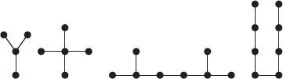

图 6.5 四棵树。

**Figure 6.5.** Four trees.

尽管如此，关于树的无限序列，仍有一个类似上述线形图定理的结果。它由美国数学家约瑟夫$⋅$克鲁斯卡尔于 1960 年发现。

Nevertheless, there is a theorem about infinite sequences of trees analogous to the above theorem about line graphs. It was discovered by the American mathematician Joseph Kruskal in 1960.

克鲁斯卡尔定理。对任意树的无限序列 $T1$、$T2$、$T3$、……，都存在下标 $i<j$，使 $Ti$ 嵌入 $Tj$。

Kruskal’stheorem. *For any infinite sequence of trees T*<sub>1</sub>, *T*<sub>2</sub>, *T*<sub>3</sub>,… *there are indices i < j such that T<sub>i</sub> embeds in T<sub>j</sub>.*

另一种也许更吸引人的表达方式是：任意由互不相同的树组成的无限序列，都含有一个在嵌入次序下无限递增的子序列。因此，克鲁斯卡尔定理又是一个“完全无序是不可能的”的例子。

Another, perhaps more appealing, way to express Kruskal’s theorem is the following: *any infinite sequence of distinct trees contains an infinite increasing subsequence in the embedding order.* Thus Kruskal’s theorem is yet another case where “complete disorder is impossible.”

树的嵌入次序十分复杂，使克鲁斯卡尔定理相当难证，这里甚至不概述其证明。可在 Diestel（2005）一书最后一章找到证明。非凡之处在于，这里表面上的难证，确实对应于它在 PA 等系统中的不可证明性。当然，克鲁斯卡尔定理甚至不能在 PA 中表达，因为它涉及任意无限序列，因此其证明肯定需要关于无穷的假设。不过，这并不是真正的困难来源。

The complexity of the embedding order for trees makes Kruskal’s theorem quite hard to prove, and we will not even outline a proof here. (A proof may be found in the last chapter of the book by Diestel (2005).) What is remarkable is that being *apparently hard* to provein this casecorre-sponds to *actual unprovability* in systems such as PA. Of course, Kruskal’s theorem cannot even be expressed in PA, because it involves arbitrary infinite sequences, so assumptions about infinity are surely needed for its proof. However, this is not really the source of the difficulty.

1981 年，美国逻辑学家哈维$⋅$弗里德曼找到了克鲁斯卡尔定理的一种自然有限形式，它可以在 PA 中表达，却仍不能在 PA 中证明。事实上，证明这个有限形式，需要直到某个远大于 $ε0$ 的序数的归纳。定理涉及树的有限序列，并带有一个简单的“增长率”条件，以避免显然的反例：

In 1981, the American logician Harvey Friedman found a natural *finite form* of Kruskal’s theorem, expressible in PA, but still not provable in PA. In fact, the proof of Friedman’s finite form requires induction up to an ordinal much larger than ε0. The theorem is about finite sequences of trees, with a simple “rate of growth” condition that avoids obvious counterexamples:

弗里德曼的克鲁斯卡尔定理有限形式。对每个 $m$，都存在 $n$，使得若 $T1$、$T2$、……、$Tn$ 是一个树序列，且 $Tk$ 至多有 mk 个顶点，那么存在下标 $i<j$，使 $Ti$ 嵌入 $Tj$。

Friedman’s finite form of Kruskal’s theorem. *Foreach m thereisan nsuchthat, if T*<sub>1</sub>, *T*<sub>2</sub>,…, *T<sub>n</sub> is a sequence of trees in which T<sub>k</sub> has at most mk vertices, then there are indices i < jsuch that T<sub>i</sub> embeds in T<sub>j</sub>.*

这个形式的克鲁斯卡尔定理，隐含地涉及一个可计算函数，即

This form of Kruskal’s theorem implicitly involves a computable function, namely

$f(m)=$满足以下条件的最小 $n$：任意这样的序列 $T1$、$T2$、……、$Tn$，都含有某个嵌入 $Tj$ 的 $Ti$，其中 $i<j$。

$$f(m)= least n such that any such sequence T1,T2,…,Tn includes a Ti that embeds in Tj, for some i<j.$$

克鲁斯卡尔定理真正的困难来源，是 $f$ 增长得惊人地快，不仅快于任何可证可计算函数，而且远快于 $Hε0$，即前面那些 PA 不可证明性例子的标尺。因此，弗里德曼的发现开辟了不可证明性的新天地，不仅处于更高的序数层级，而且可以说处于更低的概念层级。例如，向外星生物解释克鲁斯卡尔定理中的概念，可能比解释古德斯坦定理中的概念更容易。

The real source of difficulty in Kruskal’s theorem is that *f* grows amazingly fast—not just faster than any provably computable function, but much faster than $Hε0$, the yardstick for our previous examples of unprovability in PA. Thus Friedman’s discovery opened new vistas of unprovability—not only at a higher ordinal level, but arguably at a *lower* conceptual level. Explaining the concepts in Kruskal’s theorem to a creature from outer space would probably be easier than explaining the concepts in Goodstein’s theorem, for example.

原则上，把顶点编码为数、把边编码为数对，就能在 PA 中表达有限图论。但图论语言似乎比 PA 的语言更善于表达困难定理。弗里德曼的克鲁斯卡尔定理有限形式就是一个例子；更困难的图子式定理也有类似的有限形式。图子式定理由美国数学家尼尔$⋅$罗伯逊与保罗$⋅$西摩于 1983 至 2004 年间证明。

In principle, finite graph theory can be expressed in PA, by coding vertices as numbers and edges as number pairs. But the *language* of graph theory seems better able to express hard theorems than the language of PA. Friedman’s finite form of Kruskal’s theorem is one example, and there are similar finite forms of the (even harder) *graph minor theorem* proved by the American mathematicians Neil Robertson and Paul Seymour between 1983 and 2004.

### 图子式定理

### The Graph Minor Theorem

图子式定理是克鲁斯卡尔定理的一个变体：用任意有限图取代树，用一个较宽松的概念，即图子式关系，取代嵌入。为使图 6.6 中的多边形图无限序列也满足克鲁斯卡尔型定理，必须放宽嵌入概念，因为这个序列中没有一个图能嵌入其后的图。

The graph minor theorem is a variant of Kruskal’s theorem in which trees are replaced by arbitrary finite graphs, and embedding by a looser concept called the *graph minor relation.* Wehave to relax theconcept of embedding to get a Kruskal-type theorem for the infinite sequence of *polygon graphs* shown in Figure 6.6, no one of which embeds in a later member of the sequence.

图子式关系允许把任意顶点膨胀为由一条边连接的两个顶点，恰到好处地放宽了嵌入概念。若 $G′$ 可由 $G$ 经过有限次顶点膨胀得到，就称图 $G′$ 是图 $G$ 的一个膨胀。例如，显然任意多边形图都是任意顶点更少的多边形图的膨胀。任意树也是单个顶点的膨胀，不过膨胀不能创造新的闭路。

The graph minor relation relaxes the concept of embedding just enough by allowing any vertex to *blow up* into a pair of vertices connected by an edge. We call graph *G*′ a *blowup* of graph *G* if *G*′ results from *G* by a finite sequence of vertex blowups. For example, it is clear that any polygon graph is a blowup of any polygon graph with fewer vertices. (It is also true that any tree is a blowup of a single vertex; however, blowups cannot create new closed paths.)

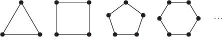

图 6.6 多边形图。

**Figure 6.6.** Polygon graphs.

最后，若 $G$ 的某个膨胀 $G′$ 嵌入 $H$，就称图 $G$ 是图 $H$ 的一个子式。于是，对任意图，有如下类似克鲁斯卡尔定理的结果：

Finally, we say that graph *G* is a *minor of* graph *H* if some blowup *G’* of *G* embeds in H. Then we have the following analogue of Kruskal’s theorem for arbitrary graphs:

图子式定理。对任意图的无限序列 $G1$、$G2$、$G3$、……，都存在下标 $i<j$，使 $Gi$ 是 $Gj$ 的子式。

Graph minor theorem. *For any infinite sequence of graphs G*<sub>1</sub>, *G*<sub>2</sub>, *G*<sub>3</sub>,… *thereare indicesi < jsuch that G<sub>i</sub> is a minor of G<sub>j</sub>.*

罗伯逊与西摩约在 1987 年发现图子式定理，并用一系列共 20 篇论文完成证明，直到 2004 年才结束。这是截至本书写作时图论中最长的证明，尚未压缩成适合教科书的形式，不过 Diestel（2005）最后一章介绍了其中的重要部分。与克鲁斯卡尔定理一样，证明论确认了这个定理表面上呈现的困难。

Robertson and Seymour discovered the graph minor theorem around 1987, and proved it in a sequence of 20 papers completed only in 2004. It is by far the longest proof in graph theory to date, and it has not yet been compressed to a form suitable for textbooks (though important parts of it are given in the last chapter of Diestel (2005)). As with Kruskal’s theorem, the apparent difficulty of the theorem is confirmed by proof theory.

弗里德曼找到了图子式定理的有限形式，与他为克鲁斯卡尔定理找到的有限形式一样，可以在 PA 中表达，却不能在 PA 中证明。这些有限版本的不可证明性层级也高于 $ε0$，不过其确切层级在本书写作时仍未知。

Friedman found finite forms of the graph minor theorem which, like those he found for Kruskal’s theorem, are expressible but not provable in PA. The finite versions of the graph minor theorem also have a level of unprovability higher than *ε*<sub>0</sub>, though their exact level is not yet known.

## 6.8 历史背景

## 6.8 Historical Background

### 拉姆齐理论

### Ramsey Theory

如今被视为拉姆齐理论一部分的最早定理，实际上比拉姆齐的工作早十至二十年出现。它们是关于自然数的定理，属于如今所谓的算术拉姆齐理论。Landman 与 Robertson（2004）有一本很好的著作介绍这个分支。算术拉姆齐理论最初的两个定理，是下面这两个关于整数有限集的定理：

The first theorems that we now consider to be part of Ramsey theory actually appeared a decade or two before Ramsey’s work. They are theorems about the natural numbers of a type now called *arithmetic Ramsey theory.* A nice book on this branch of Ramsey theory is the one by Landman and Robertson (2004). The first two theorems of arithmetic Ramsey theory are the following theorems about finite sets of integers:

- 舒尔定理（1916）。对任意整数 $r≥1$，都存在整数 $s$，使得对 $1,2,$…$,s$ 的任意 $r$ 染色，都存在单色三元组 (x,y,z)，满足 $x+y=z$。
- Schur’stheorem (1916). *For any integer r* ≥ 1 *there is an integer s such that, for any r-coloring of* {1,2,…,*s*}, *there is a monochromatic triple* (*x*, *y, z*) *such that x + y = z.*
- 范德瓦尔登定理（1927）。对任意整数 $k$、$r≥1$，都存在整数 $s$，使得对 $1,2,$…$,s$ 的任意 $r$ 染色，都存在长度为 $k$ 的单色等差数列。
- Van der Waerden’stheorem (1927). *For any integers k, r* ≥ 1 *there is an integer s such that, for any r-coloring of* {1,2,…,*s*},*there is a monochromatic arithmetic progression of length k.*

拉姆齐本人在 1930 年的论文中，先证明无限拉姆齐定理，再单独证明有限版本。他没有指出第 6.6 节给出的二者联系。柯尼希（1936）第六章认识到，某种“紧致性”联系着有限与无限拉姆齐定理；他在那里说明，柯尼希无穷引理使有限范德瓦尔登定理可以容易地从无限版本推出。无限范德瓦尔登定理说，在正整数的任意 $r$ 染色中，至少一种颜色包含任意长的等差数列。

Ramsey himself, in his 1930 paper, proved the infinite Ramsey theorem, then gave a separate proof of the finite version. He did not point out the connection between them that we gave in Section 6.6. The realization that some kind of “compactness” relates finite and infinite Ramsey theorems occurs in König (1936), Chapter VI, where he shows that the König infinity lemma allows the finite van der Waerden theorem to be easily derived from an infinite one. The infinite van der Waerden theorem says that, in any *r*-coloring of the positive integers, at least one color contains arbitrarily long arithmetic progressions.

匈牙利数学家恩德雷$⋅$塞迈雷迪证明了无限范德瓦尔登定理的一个非凡加强。塞迈雷迪（1975）证明，任意具有正密度的正整数集，都包含任意长的等差数列。正整数集 $S$ 的密度，是以下比值的下极限：

A remarkable strengthening of the infinite van der Waerden theorem was proved by the Hungarian mathematician Endre Szemeredi. Szemeredi (1975) proved that any set of positive integers of *positive density* contains arbitrarily long arithmetic progressions. The *density* of a set *S* of positive integers is the lower limit of the ratio

（$S$ 中小于 $n$ 的元素个数）/$n$。

$$(number of members of S less than n ) /n.$$

若把正整数染成有限种颜色，显然至少一种颜色覆盖一个正密度集合，因此范德瓦尔登定理由塞迈雷迪定理推出。不过，塞迈雷迪定理非常困难，并成为组合数学中若干新思想的来源。

If the positive integers are colored in finitely many colors, it is clear that at least one color covers a set of positive density, so van der Waerden’s theorem follows from Szemeredi’s. However, Szemeredi’s theorem is very difficult, and it has been the source of several new ideas in combinatorics.

2004 年，澳大利亚数学家陶哲轩与英国同事本$⋅$格林，在塞迈雷迪定理基础上证明了一个更困难的定理。格林–陶定理说明，素数中存在任意长的等差数列，解决了一个长期悬而未决的问题。也就是说，存在任意大的“等间距”素数集合。较小的例子有 $3,5,7$ 和 $5,11,17,23,29$；本书所列当时已知的最大例子含 24 项，首项为 468395662504823，相邻两项的差为 45872132836530。

An even more difficult theorem, building on Szemeredi’s, was proved by the Australian Terry Tao and his English colleague Ben Green in 2004. The Green-Tao theorem solves a long-standing open problem by showing that *there are arbitrarily long arithmetic progressions in the prime numbers.* That is, there are arbitrarily large sets of “equally spaced” primes. Some small examples are {3, 5, 7} and {5, 11, 17, 23, 29}, and the largest known example has 24 members (initial member 468395662504823 and distance 45872132836530 between successive members).

因此，格林–陶定理证明了某些在实践中极难找到的集合的存在。由于素数集没有正密度，其证明需要比塞迈雷迪定理更强的工具。尽管如此，对应函数

Thus the Green-Tao theorem proves the existence of sets that are extremely hard to find in practice. Its proof requires more firepower than Szemeredi’s theorem, because the primes do *not* have positive density. Nevertheless, the associated function,

$f(m)=$使小于 $n$ 的素数中存在 $m$ 个等间距素数的最小 $n$，

*f*(*m*)=least *n* such that there are *m* equally-spaced primes less than *n*,

因此 $f$ 在 PA 中可证可计算。

so *f* is provably computable in PA.

事实上，据本书写作时所知，所有并非由逻辑学家设计出来的数论定理，都有 PA 中的证明。塞迈雷迪定理与格林–陶定理的证明，可以通过无穷方法简化，甚至获得启发；但必要时，可以消去这些无穷方法。$2$

In fact, as far as we know, all theorems of number theory not devised by logicians have proofs in PA. The Szemeredi and Green-Tao theorems have proofs that are simplified (even motivated) by infinitary methods, but at a pinch the infinitary methods can be eliminated.<sup>2</sup>

由逻辑学家设计并证明的帕里斯–哈林顿定理，则并非如此。参见 Paris 与 Harrington（1977）的证明。尽管如此，使增长率加快到足以保证 PA 中不可证明性的条件，即有限集合的大小大于其最小元素，还是相当自然的。这个定理如今已被组合数学家接纳，Graham 等（1990）将其收入著作就是证明。也许组合数学实际上比数论更亲近逻辑，因为它更自然地表达强于 PA 的原理。

This is not the case for the Paris-Harrington theorem, which was devised and proved by logicians. (See their proof in Paris and Harrington (1977).) Nevertheless, the condition that accelerates growth rate enough to ensure unprovability in PA—that each finite set have size greater than its smallest element—is natural enough. The theorem has now been embraced by combinatorialists, as its inclusion in the book of Graham et al. (1990) shows. It may be that combinatorics is actually more friendly to logic than number theory, in the sense that it more naturally expresses principles stronger than PA.

### 图论

### Graph Theory

> 图论是组合数学巢中的一只杜鹃。

> Graph theory is a cuckoo in the combinatorial nest.

> ——彼得$⋅J$. 卡梅伦（1994），第 159 页。

> —Peter J. Cameron (1994), p. 159.

尝试解决三公用设施谜题之类的经验表明，$K5$ 与 $K3,3$ 都无法在平面上画出而不使边相交。为证明这一点，使用一个可追溯至 1752 年的公式，即欧拉多面体公式：

Experience, such as trying to solve the utilities puzzle, suggests that neither *K*<sub>5</sub> nor *K*<sub>3,3</sub> can bedrawn in theplane without edges crossing. To prove this, we use a formula that goes back to 1752, the *Euler polyhedron formula*,

$$V−E+F=2$$

这里，$V$ 是嵌入平面的连通图的顶点数，$E$ 是边数，$F$ 是面数，即边在平面上划分出的区域数。

Here *V* is the number of vertices, *E* is the number of edges, and *F* is the number of faces (regions of the plane cut out by the edges) of a connected graph embedded in the plane.

非平面性与欧拉多面体公式

Nonplanarity and the Euler polyhedron formula

对 $K5$，有 $V=5$、$E=10$，因此若 $K5$ 嵌入平面，其面数必为 $F=7$。每个面至少有三条边，因为 $K5$ 中任意两顶点之间只有一条边，所以总数至少为 21。当然，这样把每条边数了两次，因为每条边都位于两个面的边界上。但即使除以 2，仍得到超过 10 条边，产生矛盾。因此 $K5$ 非平面。

In thecaseof *K*<sub>5</sub> we have *V* = 5, *E* = 10, so the number of faces in any embedding of *K*<sub>5</sub> in the plane is necessarily *F* = 7. Each face has at least three edges (because in *K*<sub>5</sub> only one edge connects any two vertices), which makes a total of at least 21. Of course, this figure counts each edge twice, since each edge is in the boundary of two faces. But we still get more than 10 edges, which is a contradiction. So *K*<sub>5</sub> is nonplanar.

证明 $K3,3$ 非平面的方法类似，只需利用 $K3,3$ 不含三角形，因此其假想平面嵌入中的每个面至少有四条边这一事实。

There is a similar proof that *K*<sub>3,3</sub> is nonplanar, using the fact that *K*<sub>3,3</sub> contains no triangles, hence any face of its hypothetical planar embedding has at least four edges.

终于来到库拉托夫斯基（1930）的定理。它说，在某种意义上，任意非平面图都“包含”一个 $K5$ 或 $K3,3$。“包含”至少有两种解释：

This brings us, finally, to the theorem of Kuratowski (1930). It says that, in a certain sense, *any nonplanar graph “contains” a K*<sub>5</sub> *or a K*<sub>3,3</sub>.There are at least two ways to interpret the word “contains”:

库拉托夫斯基版本（1930）。任意非平面图，都有一个子图是 $K5$ 或 $K3,3$ 的细分。图 $G$ 的细分，是在 $G$ 的某些边的内部插入新顶点后得到的图。

Kuratowski’s version (1930). *Any nonplanar graph has a subdivision of K*<sub>5</sub> *or K*<sub>3,3</sub> *as a subgraph.* (A *subdivision* of a graph *G* is the result of inserting new vertices in the interior of some edges of *G.*)

瓦格纳版本（1937）。任意非平面图，都以 $K5$ 或 $K3,3$ 为子式，也就是说，它有一个子图是 $K5$ 或 $K3,3$ 的膨胀。

Wagner’sversion (1937). *Any nonplanar graph has K*<sub>5</sub> *or K*<sub>3,3</sub> *as a minor, that is, it has a blowup of K*<sub>5</sub> *or K*<sub>3,3</sub> *as a subgraph.*

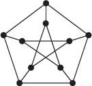

图 6.9 彼得森图。

**Figure 6.9.** The Petersen graph.

两个版本都把 $K5$ 与 $K3,3$ 认定为平面图的禁用子图，但方式不同。图 6.9 中称为彼得森图的非平面图，可以显示这种差别。

Both versions identity *K*<sub>5</sub> and *K*<sub>3,3</sub> as the *forbidden subgraphs* for planar graphs, but in different ways. The difference may be seen from the graph in Figure 6.9, a nonplanar graph known as the *Petersen graph.*

彼得森图显然是 $K5$ 的膨胀，但它没有任何子图是 $K5$ 的细分。相反，它有一个子图是 $K3,3$ 的细分。这并不容易找到，试试看！

The Petersen graph is obviously a blowup of *K*<sub>5</sub>, but it does not have a subdivision of *K*<sub>5</sub> as a subgraph. Instead, it has a subgraph that is a subdivision of *K*<sub>3,3</sub>. (It is not easy to find. Try looking for it!)

把库拉托夫斯基定理与瓦格纳定理推广到其他曲面，竟然十分困难。一个自然起点，是按亏格 $g$，即“洞”的个数，对曲面分类，再确定哪些 $Kn$ 能嵌入亏格为 $g$ 的曲面。图 6.10 显示前几个曲面，从没有洞的球面开始。平面图恰好就是能嵌入球面的图。

Extending the Kuratowski and Wagner theorems to other surfaces proves to be surprisingly difficult. A natural way to start is to classify surfaces by their *genus g* (number of “holes”) and to find which *K<sub>n</sub>* can be embedded in the surface of genus g. Figure 6.10 shows the first few of these, starting with the sphere (zero holes). The planar graphs are precisely those that may be embedded in the sphere.

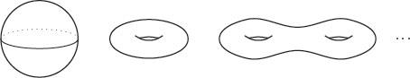

图 6.10 亏格为 0、1、2、……的曲面。

**Figure 6.10.** Surfaces of genus 0,1,2,… .

这个定理为有 $g$ 个洞的曲面上的图，给出了一个禁用子图，即 $Km$，其中 $m$ 是大于 $(7+√(48g+1))$/2 的最小整数。至于其他禁用子图，甚至连其个数是否有限都不清楚！

可以检验，$K5$ 与 $K6$ 能嵌入莫比乌斯带，但 $K7$ 不能。因此，$K7$ 是莫比乌斯带上的图的一个禁用子图。Glover 等（1979）证明，莫比乌斯带有 103 个，没错，103 个禁用子图。$3$ 这个数采用库拉托夫斯基对禁用子图的解释；若采用瓦格纳的解释，则有 35 个。

We can check that *K*<sub>5</sub> and *K*<sub>6</sub> embed in the Mobius band, but it turns out that *K*<sub>7</sub> does not. Thus *K*<sub>7</sub> is a forbidden subgraph for graphs on the Mobius band. Glover et al. (1979) proved that there are 103 (!) forbidden subgraphs for the Mobius band.<sup>3</sup> The number 103 results from taking the Kuratowski interpretation of forbidden subgraph; under the Wagner interpretation there are 35 forbidden subgraphs.

本书写作时，环面上图的禁用子图个数尚未知，但如今已知这个数有限！这个结果，以及任意曲面的相应结果，都是罗伯逊与西摩图子式定理的后果。更准确地说，由图子式定理容易推出，对每个曲面 $S$，都存在一个有限的禁用子式集。$S$ 的禁用子式，是不能作为任何可嵌入 $S$ 的图的子式出现、且在子式次序下极小的图。例如，$K5$ 不作为任何平面图的子式出现，而且是极小的。$K6$ 也不作为任何平面图的子式出现，但它不是极小的，因此不是禁用子式，因为它以 $K5$ 为子式。

We do not yet know the number of forbidden subgraphs for graphs on the torus, but we now know that the number is finite! This, and the corresponding result for any surface, is a consequence of Robertson and Seymour’s graph minor theorem. More precisely, it follows easily from the graph minor theorem that, for each surface *S*, there is a finite set of *forbidden minors.* A forbidden minor for *S* is a graph that does not occur as a minor of a graph embeddable in *S*, and which is minimal in the minor ordering. For example, *K*<sub>5</sub> does not occur as a minor of any planar graph, and it is minimal. *K*<sub>6</sub> also does not occur as a minor for any any planar graph, but it is *not* minimal (and hence not a forbidden minor) because it has *K*<sub>5</sub> as a minor.

由这个定义可知，对任意曲面的禁用子式集，其中没有任何成员是另一个成员的子式。因此，由图子式定理，这个集合有限。尽管如此，本书写作时，对任何亏格大于零的曲面，禁用子式的个数仍未知，而且这个数似乎增长得非常快。已知环面至少有 16000 个禁用子式。

It follows from this definition that, in the set of forbidden minors for any surface, no member is a minor of another. Therefore, by the graph minor theorem, *the set of forbidden minors is finite.* Nevertheless, the number of forbidden minors is still not known for any surface of genus greater than zero, and the number appears to grow very rapidly. It is known that there are at least 16000 forbidden minors for the torus.

### 组合数学与分析

### Combinatorics and Analysis

> 这些原理使人能够利用无穷世界的力量，例如取极限、对对象作完备化或闭包，来确立有限世界中的结果；或者至少把在无穷世界中获得的直觉，转移到有限情境中。

> These principles allow one to tap the power of the infinitary world (for instance, the ability to take limits and perform completions or closures of objects) in order to establish results in the finitary world, or at least to take the intuition gained in the infinitary world and transfer it to a finitary setting.

> ——陶哲轩（2009），第 165 页。

> —Terry Tao (2009), p. 165.

近年来，组合数学越来越受到分析思想的影响，包括实数、极限、实函数与无穷级数。例如，英国数学家蒂姆$⋅$高尔斯于 2002 年给出的塞迈雷迪定理新证明，以及格林与陶哲轩于 2004 年给出的素数中存在任意长等差数列的证明。正如陶哲轩所说，分析提供关于无穷世界的直觉，可用来确立有限世界的结果。本书已展示许多依赖无穷假设的有限世界结果，但其中很少有假设是分析中典型的。下面给出一个涉及经典分析定理的简单例子。

In recent years, combinatorics has been increasingly influenced by ideas from analysis: real numbers, limits, real functions, infinite series. Examples are a new proof of Szemerédi’s theorem in 2002 by the English mathematician Tim Gowers, and the Green-Tao proof that there are arbitrarily long arithmetic progressions in the primes in 2004. As Terry Tao claims, *analysis gives intuition about the infinitary* world,which maybe used to establish results in the finitary world. In this book, we have now seen many examples of results about the finitary world that depend on infinitary assumptions. However, not many of these infinitary assumptions are typical of analysis. Here is a simple example of one that is, involving a classical theorem of analysis.

波尔查诺–魏尔斯特拉斯定理说，单位区间 [0,1] 中任意无限集 $S$ 都有聚点。也就是说，存在一点 $X$，其每个邻域都包含 $S$ 的点。此前在讨论相关的海涅–博雷尔定理与柯尼希无穷引理时，已经提到过这个定理；这两个结果的证明确实相似。不过，可以说波尔查诺–魏尔斯特拉斯定理更直观，因为与无限树相比，我们更熟悉单位区间中的点集。

The *Bolzano-Weierstrass theorem* states that any infinite set *S* in the unit interval [0,1] has a limit point. That is, there is a point X, each neighborhood of which includes points of *S.* We mentioned this theorem once before, in connection with the related Heine-Borel theorem and the Konig infinity lemma, and indeed the two results have similar proofs. However, the Bolzano-Weierstrass theorem is arguably more intuitive, because we are more familiar with sets of points in the unit interval than with infinite trees.

现在考虑下面这个定理，它令人想起关于树的克鲁斯卡尔定理，但更初等：[0,1] 中任意由互不相同的数组成的无限序列 $S$，都包含无限递增子序列或无限递减子序列。这个定理当然可以用组合论证证明，例如把递增数对染红，其余数对染蓝，再应用无限拉姆齐定理；但它也可以直接由波尔查诺–魏尔斯特拉斯定理推出！

Now consider the following theorem, reminiscient of the Kruskal theorem about trees, but more elementary: *every infinite S sequence of distinct numbers in* [0,1] *contains either an infinite increasing subsequence, or an infinite decreasing subsequence.* This theorem can certainly be proved by a combinatorial argument—for example, by coloring increasing pairs red and the other pairs blue it follows from the infinite Ramsey theorem— but it is *immediate* from the Bolzano-Weierstrass theorem!

考虑 $S$ 的元素集的一个聚点 $X$。要么 $S$ 中小于 $X$ 的元素有无限多个，此时能找到一个以 $X$ 为极限的无限递增子序列；要么 $S$ 中大于 $X$ 的元素有无限多个，此时能找到一个以 $X$ 为极限的无限递减子序列。

Consider a limit point *X* of the set of members of *S.* Either there are infinitely many members of *S* less than X, in which case we can find an infinite increasing subsequence (with limit X), or there are infinitely many members of *S* greater than X, in which case we can find an infinite decreasing subsequence (with limit *X*).

虽然这只是拉姆齐理论中一个很初等的定理，我仍认为它说明了分析直觉的力量。分析使我们能够创造聚点之类的对象，让无限集合或过程得以实现，并使之可以直观把握。高尔斯、格林与陶哲轩的结果更有说服力地展示了这种力量，但遗憾的是，它们远超本书范围。

While this theorem is only a baby theorem of Ramsey theory, I think that it illustrates the power of intuition from analysis. Analysis allows us to create objects, such as limit points, that realize infinite sets or processes, and allow us to visualize them. The results of Gowers, Green, and Tao show this power more convincingly, but unfortunately they are far beyond the scope of this book.

另一个应用于组合数学的相关数学分支，是遍历理论。粗略地说，遍历理论研究发生在直线、平面等空间中的无限过程的“极限行为”。20 世纪 70 年代，以色列数学家希勒尔$⋅$弗斯滕伯格，把塞迈雷迪定理与范德瓦尔登定理放到遍历理论中，分别于 1977、1978 年给出简化证明。令人惊讶的是，弗斯滕伯格的证明与范德瓦尔登原来的证明之间，存在结构联系。法国逻辑学家让-伊夫$⋅$吉拉尔在 Girard（1987）一书中说明，适当地通过切割消去展开弗斯滕伯格的证明，就会得到范德瓦尔登的证明！

A related branch of mathematics that has been applied to combinatorics is *ergodic theory.* Roughly speaking, ergodic theory studies “behavior in the limit” of infinite processes taking place in spaces such as the line or plane. In the 1970s, the Israeli mathematician Hillel Furstenberg gave simplified proofs of Szemeredi’s theorem (1977) and van der Waerden’s theorem (1978) by relocating them in ergodic theory. Amazingly, there is a structural connection between Furstenberg’s proof and the original proof by van der Waerden. The French logician Jean-Yves Girard showed in his book Girard (1987) that when Furstenberg’s proof is suitably expanded, by cut elimination, it becomes van der Waerden’s proof!

吉拉尔的发现以实例说明，分析中的无穷原理，如何“重新包装”组合数学中的无穷原理，使主流数学家感到熟悉。关于逻辑在本书写作时对遍历理论的研究概况，参见 Avigad（2009）。

Girard’s discovery shows by example how infinitary principles of analysis can “repackage” infinitary principles of combinatorics so as to make them familiar to mainstream mathematicians. For a survey of what logic currently has to say about ergodic theory, see Avigad (2009).

1 例如，本书写作时还不知道，使任意 $N$ 人中总有五人彼此相识或五人彼此陌生的最小 $N$。当时只知道 $43≤N≤49$。

For example, we do not know the minimal value of *N* such that a group of *N* people always contains five mutual acquaintances or five mutual strangers. It is known only that 43 *≤ N ≤* 49.

2 事实上，主流数学家证明的所有数论定理，似乎都能在 PA 的一个相当小的片段 EFA 中证明。在 EFA 中，任意可证可计算函数都以指数函数的某个有限次迭代为界。关于这个令人惊讶的情形，参见 Avigad（2003）。

In fact, it appears that all theorems of number theory proved by mainstream mathematicians can be proved in quite a small fragment of PA called EFA. In EFA, any provably computable function is bounded by a finite iterate of the exponential function. For a discussion of this surprising situation, see Avigad (2003).

3 严格地说，Glover、Huneke 与 Wang 针对射影平面证明了这个定理。射影平面是把莫比乌斯带的边界曲线用一个圆盘封住后得到的抽象曲面。就图嵌入而言，这没有区别，但射影平面更难画出，因为它不能嵌入普通三维空间。

Strictly speaking, Glover, Huneke, and Wang proved their theorem for the *projective plane*, an abstract surface obtained from the Mobius band by spanning its boundary curve by a disk. This makes no difference as far as graph-embedding is concerned, but it is harder to draw because the projective plane cannot be embedded in ordinary 3-dimensional space.

# 第 7 章 无穷公理

# Chapter 7 Axioms of Infinity

概览

Preview

> 因此，采纳强无穷公理是一种神学式的冒险，涉及我们对宇宙中何者为真的基本信念。不过，也可以把大基数理论中的工作理解为形式数学，也就是说，……研究那些能够在一阶逻辑中证明的形式蕴涵。

> The adaptation of strong axioms of infinity is thus a theological venture, involving basic questions of belief concerning what is true about the universe. However, one can also construe work in the theory of large cardinals as formal mathematics, that is … those formal implications provable in first order logic.

> ——Kanamori 与 Magidor（1978），第 104 页。

> —Kanamori and Magidor (1978), p. 104.

本章带有尾声的性质，将本书前面几章的若干线索汇集起来：无穷的本性，它如何限制可证明性的范围，以及它如何影响我们对自然数的认识。

This chapter is in the nature of an epilogue, tying up several threads from earlier chapters of the book: the nature of infinity, how it limits the scope of provability, and how it affects our knowledge of the natural numbers.

康托尔发现的两条通向无穷之路，即对角线构造与可数序数，原来只是理解不可数集合的广阔宇宙的众多途径中的两条。到 20 世纪 30 年代，数学家已经在思考大到足以模拟宇宙本身的集合，即所谓不可达基数与可测基数。

The roads to infinity discovered by Cantor—via the diagonal construction and via the countable ordinals—turn out to be just two of many ways to comprehend the vast universe of uncountable sets. By the 1930s, mathmaticians were contemplating sets large enough to model the universe itself: the so-called *inaccessible* and *measurable* cardinals.

在回到算术之前，我们先观察这些大得难以理解的集合，对实数性质所产生的神秘影响。在算术中，也能察觉这些不可思议的无穷的影响。事实上，越来越清楚的是，要更好地理解有限对象，就必须更好地理解无穷。

We observe the mysterious influence of these incomprehensibly large sets on the properties of real numbers, before returning to arithmetic, where the influence of these incomprehensible infinities can also be detected. In fact, it becomes clear that a better understanding of finite objects depends on a better understanding of infinity.

## 7.1 没有无穷的集合论

## 7.1 Set Theory without Infinity

当人们猜想外星智慧，以及我们如何得知它的存在时，通常会想到数。整数序列

When people speculate about alien intelligence, and how we might learn of its existence, they usually think about numbers. The sequence of integers

$1,2,3,4,5,6,7,8,9,…$

或者斐波那契数列

or the Fibonacci numbers

$1,2,3,5,8,13,21,34,55,…$

或者素数序列

or the primes

$2,3,5,7,11,13,17,19,23,29,31,…,$

都是我们会立即认作智慧迹象的“信息”。但如果外星数学的语言与我们的完全不同呢？

are “messages” that we would immediately recognize as signs of intelligence. But what if the language of alien math was entirely different from ours?

在第 1.8 节提到冯·诺伊曼对自然数的定义时，我们已经领略过“外星数论”。以空集为 0，冯·诺伊曼把后继函数定义为

We have already had a taste of “alien number theory” when we noted von Neumann’s definition of the natural numbers in Section 1.8. Taking the empty set to be 0, von Neumann defines the successor function by

$S(n)=n+1=n∪{n}.$

这个定义还以尽可能简单的方式给出了“小于”关系：m<n 当且仅当 m 是 n 的元素，记作 m∈n。如我们所知，加法与乘法可以从后继函数归纳定义，因为

This definition also gives the “less than” relation in the simplest possible way: *m < n* if and only if *m* is a member of n, written *m* ∈ *n*.As we know, sum and product are definable inductively from the successor function, because

$m+0=m,m+S(n)=S(m+n)m⋅0=0,m⋅S(n)=m⋅n+m$

因此，要从集合论中提取皮亚诺算术（PA），真正需要的只有归纳。利用第 1.8 节列出的 ZF 公理，这也很容易。我们要证明，对于任意可定义的性质 Ƥ，如果存在具有性质 Ƥ 的自然数，就存在具有性质 Ƥ 的最小自然数。在解释为什么能够做到这一点之前，需要澄清两点。

Thus, all we really need to extract Peano arithmetic (PA) from set theory is induction. This is easy too, using the ZF axioms listed in Section 1.8. We want to prove that, for any definable property *Ƥ*, if there is a natural number with property *Ƥ* then there is a *least* natural number with property *Ƥ*. Before we explain why this is possible, a couple of points need to be clarified.

- 需要用 ZF 集合论的语言定义性质“n 是自然数”。借助冯·诺伊曼对自然数的定义，这个性质可以由若干涉及隶属关系的性质组合而成：

  We need to define the property “n is a natural number” in the language of ZF set theory. Thanks to von Neumann’s definition of natural number, this property is a combination of properties involving membership:
  - 对于任意不同的 p,q∈n，要么 p∈q，要么 q∈p。

    for any distinct *p*, *q* ∈ *n*, either *p* ∈ *q* or *q* ∈ *p.*
  - n 的元素的任意元素，仍然是 n 的元素。

    any member of a member of *n* is a member of *n*.
  - 若 n 不是 0，则 n 有一个最大元素。

    if *n* is not 0, then *n* has a greatest member.
- 需要说明，PA 中可定义的任意性质 Ƥ，在 ZF 集合论中也可定义。这是因为，PA 的基本概念是 0 与后继，而如前所见，二者都可以在 ZF 中定义。

  We need to show that any property *Ƥ* definable in PA is definable in ZF set theory. This follows because the basic concepts of PA are 0 and successor, both of which are definable in ZF, as we have seen.

现在，若 n 是具有性质 Ƥ 的自然数，考虑所有小于 n 的数，它们就是 n 的元素。其中具有性质 Ƥ 的元素构成一个集合，这要归功于替换公理，即第 1.8 节列表中的公理 6。因此，只需说明，任意非空集合相对于隶属关系都有一个最小元素。这本身就是一条公理！即正则公理，也称基础公理，是第 1.8 节列表中的公理 7。

Now, if *n* is a natural number with property *Ƥ*, consider the numbers less than *n*,which are members of *n*. The members with property *Ƥ* form a set (thanks to the replacement axiom, Axiom 6 on the list in Section 1.8). So it remains to show that any nonempty set has a least member with respect to the membership relation. This is an axiom! (The axiom of foundation, Axiom 7 on the list in Section 1.8.)

因此，PA 可以在 ZF 集合论中表达。还要注意，建立 PA 的概念与公理时，并未使用无穷公理，即第 1.8 节列表中的公理 8。所以，PA 实际上可以在更弱的集合论中表达：从 ZF 中去掉无穷公理，简称 ZF−无穷。

Thus PA is expressible in ZF set theory. Notice also that *we have not used the axiom of infinity* (Axiom 8 on the list in Section 1.8) to build the concepts and axioms of PA. So PA is in fact expressible in a weaker set theory: ZF minus the axiom of infinity, or ZF *—* Infinity for short.

可以说 ZF−无穷 比 ZF 弱，因为无穷公理确实不能从其余七条公理推出，除非这些公理不一致。这七条公理有一个模型，由所谓遗传有限集构成，即从空集出发，通过配对、并集、幂集与替换运算构造出的集合。对有限集施行其中任意一种运算，显然仍产生有限集，因此模型中的所有集合都是有限的。而且，这样一个集合的所有元素也都是有限的，元素的元素也都是有限的，依此类推，因此称为遗传有限。由构造可知，遗传有限集满足 ZF 的前七条公理，却不满足无穷公理。因此，无穷公理不能从其他公理推出。

We can say that ZF *—* Infinity is weaker than ZF, because the axiom of infinity is definitely not provable from the remaining seven axioms (unless they are inconsistent). These seven axioms have a model consisting of the so-called *hereditarily finite* sets, the sets built from the empty set by the pairing, union, power, and replacement operations. Any one of these operations on a finite set obviously produces a finite set, hence all sets in the model are finite. (Moreover, all members of such a set are finite, all members of members, and so on, which is why these sets are called *hereditarily* finite.) The hereditarily finite sets satisfy the first seven axioms of ZF, by construction, but they do not satisfy the axiom of infinity. Hence the axiom of infinity does not follow from the others.

事实上，既然 ZF−无穷 可以用遗传有限集建立模型，它就能在 PA 中编码。如第 3.3 节所见，在 PA 中可以定义连接关系，把一个正整数序列编码为单个整数。更深入地运用连接，实际上可以把所有遗传有限集，以及集合上的各种有限运算，都用正整数编码。这种编码说明，ZF−无穷 与 PA 本质上相同。ZF−无穷 就是一种外星数论！

In fact, since ZF *—* Infinity can be modeled by the hereditarily finite sets, *it can be encoded in PA.* In PA, as we saw in Section 3.3, we can define a concatenation relation that encodes a sequence of positive integers by a single integer. By more intensive use of concatenation, we can in fact encode all hereditarily finite sets by positive integers; also the various finite operations on sets. This encoding shows that *ZF — Infinity and PA are essentially the same.* ZF *—* Infinity is an alien number theory!

毫无疑问，多数人类更愿意在 PA 而不是 ZF−无穷 中研究数论，但知道还有另一种选择总是好事。至少，ZF−无穷 为直接以有限集为基础的数学领域，例如拉姆齐理论与图论，提供了良好背景。随着数论与这些领域之间的壁垒逐渐消融，ZF−无穷 也许终将不再显得陌生。它反而可能被视为数学的自然基础理论，而“高等数学”则通过加入各种无穷公理获得。

No doubt most humans would prefer to do number theory in PA rather than in ZF *—* Infinity, but it is good to be aware of the alternative. At the very least, ZF *—* Infinity is a good setting for areas of mathematics based directly on finite sets, such as Ramsey theory and graph theory. As the barriers between number theory and these areas melt away, ZF *—* Infinity may not seem alien after all. It may be seen rather as the natural base theory of mathematics, from which “higher mathematics” is obtained by adding various axioms of infinity.

### 无穷带来何等巨大的差别

### What a Difference Infinity Makes

既然知道 ZF−无穷 本质上就是 PA，就能看出无穷公理带来的巨大差别。原先的宇宙只需存在遗传有限集，而无穷公理把我们带到一个存在大小为 ℵ₀ 的集合的宇宙。随后，幂集公理给出大小为 $2ℵ0$、$22ℵ0$、……的集合；替换公理则给出其他可能不同的集合，例如 ℵ₁、ℵ₂、……。由于存在定义域为集合 ω 的函数 n↦$ℵn$，替换公理给出集合 {ℵ₀,ℵ₁,ℵ₂,…}。对它应用并集公理，得到 $ℵω$，即 ℵ₀、ℵ₁、ℵ₂、……的最小上界。如此继续，不断向上，对任意序数 α 得到 $ℵα$。

Now that we know that ZF *—* Infinity is essentially PA, we can see what an enormous difference the axiom of infinity makes. From a universe in which only the hereditarily finite sets need exist, the axiom of infinity takes us to a universe in which a set of size ℵ<sub>0</sub> exists. Then the power set axiom gives us sets of size $2ℵ0,$, $22H0$, … and the replacement axiom gives others (which may be different) such as ℵ<sub>1</sub> ℵ<sub>2</sub>,… . Since we have afunction $n↦ℵn$ whose domain is the set *ω*, the axiom of replacement gives us the set {ℵ<sub>0</sub>, ℵ<sub>1</sub>, ℵ<sub>2</sub>,…}. Applying the union axiom to this set gives ℵ*<sub>ω</sub>*, the least upper bound of ℵ<sub>0</sub>, ℵ<sub>1</sub>, ℵ<sub>2</sub>,…, and so it goes, onward and upward to ℵ<sub>α</sub> for any ordinal α.

即使在 PA 层级，加入无穷公理也会极大改变可证明的内容。由无穷公理保证存在的集合 {0,1,2,…} 满足 PA 公理，因此证明 PA 一致。由哥德尔不完备性定理可知，Con(PA) 不是 ZF−无穷 的定理，除非 PA 不一致；但加入无穷公理后，它就成为定理。ε₀-归纳也是如此：在 ZF 中发展序数理论，就能证明它。

Even at the level of PA, adding the axiom of infinity makes a big difference to what can be proved. The set {0, 1, 2,…**}**, whose existence follows from the axiom of infinity, satisfies the PA axioms, and hence proves that PA is consistent. Thus Con(PA), which we know from Gödel incompleteness is *not* a theorem of ZF *—* Infinity (unless PA is inconsistent), becomes a theorem when the axiom of infinity is added. It is the same for *ε*<sub>0</sub>-induction, which is provable in ZF by developing the theory of ordinals.

## 7.2 不可达基数

## 7.2 Inaccessible Cardinals

> 当然，从地面看，天空显得遥不可及。

> Of course, the sky looks highly unapproachable from the ground.

> ——Kanamori 与 Magidor（1978），第 115 页。

> —Kanamori and Magidor (1978), p. 115.

由无穷公理产生的宇宙 V，可以用序数“度量”：每个集合都属于 V 的某个初始段 $Vα$，其中包含通过少于 α 次幂集运算构造出的集合。因此，V₀ 是空集；$Vα+1$ 是 $Vα$ 的幂集；对极限序数 λ，$Vλ$ 是所有 β<λ 对应的 $Vβ$ 的并集。使集合 X 作为 $Vα$ 的子集出现的最小 α，称为 X 的秩。正则公理蕴涵每个集合都有秩。

The universe *V* arising from the axiom of infinity is “measured” by ordinals, in the sense that each set belongs to an initial segment *V<sub>α</sub>* of *V* consisting of sets built by *< α* applications of the power set operation. Thus *V*<sub>0</sub> is the empty set; *V<sub>α</sub>*<sub>+1</sub> is the power set of *V<sub>α</sub>*;and *V*<sub>λ</sub>, for limit λ, is the union of the *V<sub>β</sub>* for *<sub>β</sub> <* λ. The least *α* for which a set *X* appears as a subset of *V<sub>α</sub>* is called the *rank* of X. The axiom of foundation implies that every set has a rank.

考虑由秩小于 ω 的集合构成的 $Vω$。$Vω$ 的元素就是所有有限秩的集合，即遗传有限集；上一节已经看到，它们构成 ZF−无穷 的一个模型。如果进入某个更高的秩 α，其中必然包含无限集，是否可以用 $Vα$ 为 ZF 的全部公理建立模型？若可以，$Vα$ 必须对幂集与替换运算封闭。对于一个含有无限元素的集合，这是很高的要求。我们能够列举的序数 α，例如 ℵ₀、ℵ₁、ℵ₂、……、$ℵω$，都不能给出具有这些封闭性质的 $Vα$。

Consider the set *Vco* of sets of rank *< ω.* The members of *V<sub>ω</sub>* are the sets of all finite ranks: the hereditarily finite sets, which we saw in the previous section form a model of ZF *—* Infinity. If we go to some higher rank a, which necessarily includes infinite sets, is it possible to model *all* the axioms of ZF by *V<sub>α</sub>*? If so, *V<sub>α</sub>* must be closed under the power set and replacement operations. This is a tall order for a set with infinite members. None of the ordinals *α* we can name—such as ℵ<sub>0</sub>, ℵ<sub>1</sub>, ℵ<sub>2</sub>,…,ℵ<sub>ω</sub> —give a *V<sub>α</sub>* with these closure properties.

对幂集与替换运算封闭的集合 $Vα$，必定形如某个基数 κ 对应的 $Vκ$。此时称基数 κ 为不可达的，因为在某种意义上，$Vκ$ 不能“从下方到达”。基数 ω 在这个意义上不可达，但在 ZF 中，不能证明存在不可达的 κ>ω。因为可以用 $Vκ$ 为 ZF 的全部公理建立模型，从而在 ZF 中证明断言 ZF 一致的语句 Con(ZF)。然而，ZF 包含 PA，因此由哥德尔第二不完备性定理，不能在 ZF 中证明 Con(ZF)。

Aset *V<sub>α</sub>* that is closed under the power set and replacement operations is necessarily of the form *V<sub>κ</sub>* for some cardinal number *κ*.The cardinal *κ* is then called *inaccessible*, because in some sense *V<sub>κ</sub>* cannot be “reached from below.” The cardinal *ω* is inaccessible in this sense, but *in ZF we cannot prove the existence of an inaccessible κ > ω.* This is because we could use *V<sub>κ</sub>* to model all the axioms of ZF, and hence prove in ZF the sentence Con(ZF) asserting that ZF is consistent. But ZF includes PA, hence *we cannot prove* Con(ZF) *in* ZF, by Gödel’s second incompleteness theorem.

因此，断言存在不可达的 κ>ω，是一种新的无穷公理，比通常的无穷公理更强。顺便说，这表明 ZF 的不可证明语句相对自然，也容易想到。事实上，早在知道 ZF 有不可证明语句之前，人们就已想到不可达基数。任何蕴涵不可达基数存在的语句，例如存在比不可达基数更大的基数，都必定在 ZF 中不可证，除非 ZF 不一致。

Thus, the assertion that an inaccessible *κ > ω* exists is a *new kind of axiom of infinity*, stronger than the ordinary axiom of infinity. Incidentally, this shows that unprovable sentences of ZF are relatively natural and easy to think up. (Indeed, inaccessibles *were* thought up, long before any sentence of ZF was known to be unprovable.) Any sentence implying the existence of inaccessibles, such as existence of cardinals *larger* than inaccessibles, is necessarily unprovable in ZF (unless ZF is inconsistent).

### 不可达基数与可测性

### Inaccessibles and Measurability

> 像伊卡洛斯一样，毫不羞怯地翱翔在“如果存在一个可测基数，那么……”这类陈述所隐含的思辨高空。如果太阳开始融化我们翅膀上的蜡，我们随时可以穿上形式主义的降落伞，说这些不过是有趣的蕴涵……。

> Icarus-like, soar unashamedly in speculative altitudes implicit in forms of statements like “if there is a measurable cardinal, then If the sun begins to melt the wax on our wings, we can always don our formalist parachute by saying that these are interesting implications ….

> ——Kanamori 与 Magidor（1978），第 115 页。

> —Kanamori and Magidor (1978), p. 115.

由于 ZF 有如此多的语句不可证明，人们开始对证明如下形式的相对一致性陈述感兴趣：

Since so many sentences of ZF are unprovable, one becomes interested in proving *relative consistency statements,of the* form:

若 ZF＋公理 A 一致，则 ZF＋公理 B 一致。

If ZF + Axiom A is consistent, then ZF + Axiom B is consistent.

前面已经提到的例子，是哥德尔与科恩关于选择公理（AC）和连续统假设（CH）证明的结果：

Examples we have already mentioned are those proved by Gödel and Cohen concerning the axiom of choice (AC) and the continuum hypothesis (CH):

- 若 ZF 一致，则 ZF＋AC＋CH 一致。哥德尔（1938）。

  If ZF is consistent then ZF + AC + CH is consistent (Gödel (1938)).
- 若 ZF 一致，则 ZF＋¬AC 一致。科恩（1963）。

最非凡的相对一致性陈述之一，由罗伯特·索洛韦于 1964 年证明。他是科恩之后兴起的美国集合论学家之一。索洛韦证明：

One of the most remarkable relative consistency statements was proved in 1964 by Robert Solovay, one of the post-Cohen wave of American set theorists. Solovay proved that:

若 ZF＋AC＋“存在一个不可达基数”一致，

If ZF + AC + “an inaccessible exists” is consistent,

则 ZF＋“每个实数集都勒贝格可测”一致。

then ZF + “every set of reals is Lebesgue measurable” is consistent.

二十年后，以色列数学家萨哈龙·谢拉说明，不可达基数的存在对于索洛韦的结果确实至关重要：仅假定 ZF＋AC 一致，不足以证明“所有实数集都勒贝格可测”与 ZF 相容。

Twenty years later, the Israeli mathematician Saharon Shelah showed that the existence of an inaccessible is really essential to Solovay’s result— assuming only that ZF + AC is consistent is not strong enough to prove the consistency with ZF of having all sets of reals Lebesgue measurable.

若所有实数集都勒贝格可测，则特别地，单位区间 [0,1] 的所有子集都有介于 0 与 1 之间的测度。把基数 $2ℵ0$ 与 [0,1] 中的点集等同起来，就得到基数 $2ℵ0$ 在如下意义上可测：$2ℵ0$ 的每个子集都可以赋予一个实数，称为其测度，并满足以下性质：

If all sets of reals are Lebesgue measurable then, in particular, all subsets of the unit interval [0,1] have measure between 0 and 1. It follows, when we identify the cardinal number $2N0$ with the set of points in [0,1] that *the cardinal number* $2N0$ *is measurable*, in the sense that every subset of $2ℵ0$ can be assigned a real number, called its *measure*, with the following properties:

- $2ℵ0$ 的测度为 1。

  $2ℵ0$ has measure 1.
- 每个单元素子集的测度为 0。

  Each 1-element subset has measure 0.
- 可数多个互不相交子集的并集，若这些子集的测度分别为 m₁、m₂、m₃、……，则其测度为 m₁+m₂+m₃+⋯。

  The union of countably many disjoint subsets, with respective measures *m*<sub>1</sub>, *m*<sub>2</sub>, *m*<sub>3</sub>,…, has measure *m*<sub>1</sub> + *m*<sub>2</sub> + *m*<sub>3</sub> + ⋯.

这引出了两个问题：对于其他基数，“可测”的适当定义是什么？是否存在任何“可测”基数？

This raises the questions: what is an appropriate definition of “measurable” for other cardinal numbers, and do any “measurable” cardinals exist?

这些问题历史悠久，始于 20 世纪 20 年代末斯特凡·巴拿赫领导的波兰学派，详见 Kanamori（2003）。简言之，可测基数确实有适当定义，但其存在性无法证明，因为它蕴涵不可达基数的存在。与不可达基数的存在一样，可测基数的存在也是一条无穷公理，并蕴涵许多仅凭 ZF 无法证明的有趣结果。这类公理断言存在的集合，即大于任何能从 ZF 公理证明其存在的集合的集合，通常简称为大基数。

These questions have a long history, beginning with the Polish school of Stefan Banach in the late 1920s, and we refer to Kanamori (2003) for details. In short, there is an appropriate definition of measurable cardinals, but their existence cannot be proved because it implies the existence of inaccessibles. Like the existence of inaccessibles, the existence of measurable cardinals is an axiom of infinity, and it implies many interesting results not provable in ZF alone. The sets asserted to exist in such axioms— namely, sets larger than any whose existence can be proved from the ZF axioms—are often known simply as *large cardinals.*

Kanamori（2003）是关于大基数最全面的资料。书中不可避免地有大段技术性内容，但也有一些极易阅读、见识丰富的集合论史论述。

Kanamori (2003) is the most complete source of information about large cardinals. Long stretches of it are unavoidably technical, but it contains some highly readable and well-informed passages on the history of set theory.

## 7.3 决定性公理

## 7.3 The Axiom of Determinacy

> 如果很难为假定极大基数存在的公理提供动机，……那么为什么它们仍被如此深入地研究？理由很简单：它们导出了内容充实而优美的数学。

> If axioms postulating the existence of very large cardinals are difficult to motivate … then why have they been studied so thoroughly? The simple reason is that they lead to substantial and beautiful mathematics.

> ——罗伯特·沃尔夫（2005），第 254 页。

> —Robert Wolf (2005), p. 254.

1925 年，斯特凡·巴拿赫与同事斯坦尼斯瓦夫·马祖尔，考虑了一个由玩家 I、II 轮流选取数 x 的十进制数字的游戏，由此开启了实数研究中一条新奇的线索。游戏进行 ω 步，玩家 I 的目标是让 x 落在事先给定的集合 X 中，玩家 II 的目标则是让 x 落在 X 之外。例如，若 X 是有理数集，则 II 可以通过依次选择某个非周期数字序列获胜，例如12112111211112……。无论 I 选择什么数字，数 x 都有一个非周期十进制展开，因此是无理数。于是，当 X 是有理数集时，玩家 II 在巴拿赫–马祖尔游戏中有必胜策略。

In 1925, Stefan Banach and his colleague Stanislaw Mazur started a new and curious thread in the study of real numbers by considering a game in which players I and II take turns to pick alternate decimal digits of a number *x*. The game proceeds for *ω* steps, the aim of player I being to keep *x* in some set *X* given in advance, and the aim of player II being to keep *x* out. For example, if *X* is the set of rational numbers, then II can win by playing some nonperiodic sequence of digits, such as 12112111211112… . No matter which digits are played by I, the number *x* has a nonperiodic decimal expansion, and hence is irrational. Thus *player II has a winning strategy for the Banach-Mazur game when X is the set of rational numbers.*

若其中一名玩家在关于 X 的巴拿赫–马祖尔游戏中有必胜策略，就称实数集 X 是决定的。利用选择公理，巴拿赫与马祖尔能够说明，存在不决定的集合 X。这使决定性问题被搁置了近四十年。虽然不用选择公理就找不到不决定的例子，但寻找决定的例子也几乎没有进展。到 20 世纪 60 年代初，唯一的肯定结果，是博雷尔层级直到第三层的集合都具有决定性。

A set *X* of real numbers is said to be *determined* when one of the players has a winning strategy in the Banach-Mazur game for X.Using the axiom of choice, Banach and Mazur were able to show that there is a set *X* which is not determined. This put the question of determinacy back on the shelf for nearly 40 years. Although no non-determined examples were found without the axiom of choice, there was also very little progress in finding determined examples. By the early 1960s the only positive results were that sets up to the third level of the Borel hierarchy are determined.

随后，在 1964 年，两位波兰数学家扬·梅切尔斯基与斯坦尼斯瓦夫·希维尔奇科夫斯基的一项发现，使决定集焕然一新：所有决定集都勒贝格可测。决定性突然成了一种令人向往的性质，甚至使人想要一条决定性公理，断言所有实数集都是决定的。决定性公理蕴涵选择公理为假，因此不能在 ZF 中证明。但它是选择公理的一种有吸引力的替代，因为在决定性公理下，实数集的性质比在选择公理下更好，至少就可测性而言如此。

Then, in 1964, the two Polish mathematicians Jan Mycielski and Stanislaw Swierczkowski made a find that put determined sets in an entirely new light: *all determined sets are Lebesgue measurable.* Suddenly, determinacy was a desirable property, so much so that one might want an *axiom of determinacy*, stating that all sets of real numbers are determined. The axiom of determinacy implies that the axiom of choice is false, so it cannot be proved in ZF. But it is an attractive *alternative* to the axiom of choice, because sets of reals are better behaved (at least as far as measurability is concerned) under the axiom of determinacy than under the axiom of choice.

决定性公理（AD）的提出，开启了一场长达二十年的探索：为它寻找某种无穷公理基础。这场探索涉及集合论史上一些最深刻、最复杂的工作。主要结果由美国数学家唐纳德·A. 马丁、约翰·斯蒂尔与休·伍丁获得。他们的漫长旅程始于 Martin（1969/1970）的结果：假定存在可测基数，则解析集具有决定性。解析集是平面中所有博雷尔子集在直线上的投影。它们包含直线上的全部博雷尔子集，也包含某些非博雷尔集，因此马丁极大扩展了已知决定集的世界。

The proposal of the axiom of determinacy (AD) initiated a 20-year search to find a basis for it in some axiom of infinity, a search involving some of the deepest and most intricate work in the history of set theory. The main results were obtained by the American mathematicians Donald A. Martin, John Steel, and Hugh Woodin. Their odyssey began with the result of Martin (1969/1970) that, assuming the existence of a measurable cardinal, *analytic* sets are determined. The analytic sets are the projections (on the line) of all Borel subsets of the plane. They include all Borel subsets of the line and also some sets that are not Borel, so Martin vastly extended the known world of determined sets.

遗憾的是，并非所有集合都是解析集，例如某些解析集的补集就不是解析集。因此，马丁的结果还不足以为任何足够广泛的可定义集合类证明决定性。而且，如前所述，马丁必须假定可测基数存在。1974 年，他能够仅在 ZF＋AC 中证明博雷尔集的决定性；但如今已知，解析集的决定性需要大基数，因为它与 ZF＋AC 一起，实际上蕴涵大基数的存在。

Unfortunately, not all sets are analytic—for example, the complements of some analytic sets are not analytic—so Martin’s result falls short of proving determinacy for any reasonably extensive class of definable sets. And, as we have said, Martin had to assume the existence of a measurable cardinal. (In 1974 he was able to prove determinacy of Borel sets in ZF + AC alone, but it is now known that determinacy of analytic sets needs a large cardinal, because with ZF + AC it actually *implies* the existence of large cardinals.)

即使假定极其巨大的基数存在，也不能指望证明完整的 AD，因为它与选择公理矛盾。

One does not expect to prove the full AD, even from extravagantly large cardinal assumptions, because it contradicts the axiom of choice.

不过，若能知道 AD 与 ZF 相容，仍然很好。为证明这一点，需要一条远强于“存在可测基数”的无穷公理。相应的大基数由伍丁于 1984 年引入，称为伍丁基数。若它们存在，就比最小可测基数大得多。要证明 AD 的一致性，需要假定存在无限多个伍丁基数。凭借这个庞大假设，再加上选择公理，伍丁于 1985 年证明：

However, it would be nice to know that AD is *consistent* with ZF. To prove this we need an axiom of infinity much stronger than just the existence of measurable cardinals. The corresponding large cardinals were introduced by Woodin in 1984 and are called *Woodin cardinals.* If they exist, they are much larger than the smallest measurable cardinal. And to prove the consistency of AD, we need to assume that there are *infinitely many* Woodin cardinals. With this massive assumption, together with the axiom of choice, Woodin proved in 1985 that:

ZF＋AD 一致，当且仅当

ZF + AD is consistent if and only if

ZF＋AC＋“存在无限多个伍丁基数”一致。

ZF + AC + “there are infinitely many Woodin cardinals” is consistent.

因此，AD 是一条无穷公理，其意义与“所有实数集都勒贝格可测”这一假设相同，只是程度更甚。

Thus AD is an axiom of infinity, in the same sense (but more so) as the assumption that all sets of reals are Lebesgue measurable.

伍丁基数更强的力量，也体现在它们直接蕴涵的决定性范围上。可测基数蕴涵解析集的决定性，但再往前就不多了。例如，已知它们不蕴涵解析集的补集之投影的决定性。另一方面，伍丁基数蕴涵由解析集经过有限次取补与投影得到的所有集合，即所谓射影集的决定性。这由马丁与斯蒂尔于 1985 年证明。对许多集合论学家来说，这似乎是筑起一道围栏、把不决定集挡在外面的好地方。它使所有射影集都具有可测性等良好性质，同时仍允许选择公理成立。但选择公理所蕴涵的不可测集，位于射影集类之外，因此远离经典数学。

The greater strength of Woodin cardinals can also be seen in the amount of determinacy they directly imply. Measurable cardinals imply the determinacy of analytic sets, but not much more. It is known, for example, that they do not imply determinacy for projections of complements of analytic sets. Woodin cardinals, on the other hand, imply determinacy for *all* sets obtained from analytic sets by a finite number of complementations and projections—the so-called *projective* sets.This was shown by Martin and Steel in 1985. To many set theorists, this seems like a nice place to erect a fence shutting out the indeterminate sets. It allows all projective sets to have nice properties, such as measurability, and the axiom of choice can still hold. But the nonmeasurable sets entailed by the axiom of choice are outside the class of the projective sets, and hence are remote from classical mathematics.

## 7.4 算术的“大”公理

## 7.4 Largeness Axioms for Arithmetic

第 3 和第 5 章已经看到，PA 中的不可证明性，是通过集合论论证的“微型化”发现的。哥德尔的“微型”对角线论证，导出 Con(PA) 的不可证明性；根岑把“存在不可数多个可数序数”的证明微型化，则导出 ε₀-归纳的不可证明性。可以把 ε₀-归纳称为 PA 的一条“大序数公理”。与 ZF 的大基数公理一样，它蕴涵一些以其他方式无法证明的有趣语句，例如古德斯坦定理。

We have seen in Chapters 3 and 5 how unprovability in PA was discovered by “miniaturization” of set theory arguments. Gödel’s “miniature” diagonal argument leads to the unprovability of Con(PA), and Gentzen’s “miniaturization” of the proof that there are uncountably many countable ordinals leads to the unprovability of ε<sub>0</sub>-induction. We might call ε<sub>0</sub>-induction a “large ordinal axiom” for PA. Like the large cardinal axioms for ZF, it implies some interesting sentences that are not otherwise provable, such as Goodstein’s theorem.

在 PA 中表达“大”的另一种方式，是通过蕴涵快速增长函数存在的命题。古德斯坦定理与帕里斯–哈林顿定理都属于这一类型。弗里德曼的克鲁斯卡尔定理有限形式，比古德斯坦定理和帕里斯–哈林顿定理表达了更大的“大”，因为它蕴涵某个远大于 ε₀ 的可数序数 α 上的 α-归纳。因此，PA 潜在地拥有丰富的“大”公理，正如 ZF 已经拥有的那样。

Another way to express “largeness” in PA is via propositions that imply the existence of rapidly growing functions. Goodstein’s theorem is of this type, as is the Paris-Harrington theorem. Friedman’s finite form of Kruskal’s theorem expresses greater “largeness” than the Goodstein and Paris-Harrington theorems, because it implies α-induction for a countable ordinal *α* much larger than ε<sub>0</sub>. Thus there is potentially a plethora of largeness axioms for PA, just as there is already for ZF.

不过，相比 ZF 的大基数公理，PA 的这类公理仍很少得到探索；我们知道的由“大”公理蕴涵的有趣 PA 语句也不多。相较之下，ZF 有几十个有趣的不可证明命题，其中许多由大基数公理解决。大基数公理的数目本身也很“大”。Kanamori（2003）第 472 页有一张整页图表，列出不少于 29 条公理及其已知蕴涵关系。¹ PA 中可表达的“大”公理，是否会像 ZF 中的无穷公理一样富有成果，仍有待观察；但若 PA 继续向拉姆齐理论与图论的方向发展，前景就很好。这也许取决于数学家是否习惯于把 PA 解释为 ZF−无穷。

However, the landscape of such axioms for PA is much less explored than the landscape of large cardinal axioms for ZF, and we know few interesting sentences of PA implied by largeness axioms. In comparison, ZF has dozens of interesting unprovable propositions, many of which are settled by large cardinal axioms. The number of large cardinal axioms is itself “large.” The book Kanamori (2003), p. 472, contains a full-page chart of no less than 29, with the known implications between them.<sup>1</sup> It remains to be seen whether largeness axioms expressible in PA will ever be as fruitful as axioms of infinity in ZF, though chances are good if PA continues to develop in the direction of Ramsey theory and graph theory. This may depend on mathematicians getting used to interpreting PA as ZF — Infinity.

看得更远些，PA 中无法表达的无穷公理，例如不可达基数的存在，当然可以在 PA 中产生以其他方式无法证明的后果。例如，Con(ZF) 可以在 PA 中表达，却不能在 PA 中证明，因为它蕴涵 Con(PA)。然而，如第 7.2 节所见，Con(ZF) 可以在 ZF＋不可达基数 中证明。不可达基数在 PA 中的后果，是否能像 ε₀-归纳的后果一样自然，目前还不清楚。

Looking further afield, axioms of infinity *not* expressible in PA, such as the existence of inaccessibles, can certainly have consequences in PA that are not otherwise provable. For example, Con(ZF) is expressible in PA, but it is not provable in PA because it implies Con(PA). However, Con(ZF) is provable in ZF + Inaccessible, as we have seen in Section 7.2. Whether there are consequences of inaccessibles in PA as natural as the consequences of ε<sub>0</sub>-induction is not yet clear.

## 7.5 大基数与有限数学

## 7.5 Large Cardinals and Finite Mathematics

> 在我们看来，集合论在这些情形中的作用，很像物理学的作用：后者为某些随后将由数学家证明的陈述提供启发性证据……我们认为，辫序是集合论的一项应用；更准确地说，是集合论中研究大基数的那个最富思辨性的部分的一项应用。

> It seems to us that the role of set theory in such cases is quite similar to the role of physics when the latter gives heuristic evidence for some statements that mathematicians are to prove subsequently… we think that the braid order is an application of set theory, and, more precisely, of this most speculative part of set theory that investigates large cardinals.

> ——帕特里克·德奥尔努瓦（2000），第 600 页。

> —Patrick Dehornoy (2000), p. 600

集合论很少被拿来与物理学比较，但帕特里克·德奥尔努瓦的说法有道理，因为物理直觉是无穷世界的馈赠。毕竟，我们对连续统的直觉来自空间与时间这两个物理概念，而自康托尔以来，我们就知道，这是关于不可数性的直觉。

Set theory is rarely compared with physics, but Patrick Dehornoy has a point, because physical intuition is a gift from the infinitary world. After all, our intuition of the continuum comes from the physical concepts of space and time, and we have known since Cantor that this is intuition about *uncountability.*

德奥尔努瓦基于对一个来自极大基数世界的对象，即自相似 $Vα$ 的存在的直觉，在有限对象的世界中发现了辫的线性排序。要理解如何跨越这两个世界之间的鸿沟，需要阅读 Dehornoy（1995）的文章或 Dehornoy（2000）的著作；不过，我们至少可以描述这座非凡桥梁两端的世界。

Dehornoy made a discovery in the world of finite objects, namely, the *linear ordering of braids*, based on his intuition about an object fromthe world of (very) large cardinals, namely, *existence of a self-similar V<sub>α</sub>*. To understand how one bridges the gap between these two worlds one needs to read the article Dehornoy (1995) or the book Dehornoy (2000), but we can at least describe the two worlds at the ends of Dehornoy’s remarkable bridge.

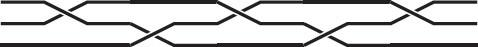

图 7.1 一条典型的辫。

**Figure 7.1.** A typical braid.

首先是辫的世界。辫是三维空间中互不相交的曲线的排列，这些曲线称为弦。例如，图 7.1 所示的是一条三弦辫，类似编头发所用的辫子。

First, the world of braids. A *braid* is an arrangement in 3-dimensional space of disjoint curves, called *strings.* For example, the arrangement shown in Figure 7.1 is a 3-string braid, similar to the braiding used for hair.

它的以下特征，也就是一般辫的定义：

Its characteristic features, which define braids in general, are these:

- 对于某个正值 k，n 条弦把点 (0,0,1)、(0,0,2)、……、(0,0,n)，连接到点 (k,0,1)、(k,0,2)、……、(k,0,n)。

  The *n* threads connect the points (0, 0, 1), (0, 0, 2),…, (0, 0, *n*) with the points (*k*, 0, 1), (*k*, 0, 2),…, (*k*, 0, *n*) for some positive value *k*.
- 每条弦都不“回头”。也就是说，沿弦从起点走向终点时，速度的 x 分量始终为正。

  Each thread is without “backtracking.” That is, as one travels along a thread from initial point to final point the x-component of velocity is always positive.
- 辫在一个竖直平面上的投影，只有有限多个重点，而且每个重点都只是一条弦与另一条弦的交叉。

  The projection of the braid on a vertical plane has only finitely many multiple points, and each multiple point is a *crossing* of one thread by another.

由于这些特征，每条辫都可以用二维图表示，正如图 7.1 已经做的那样。辫图基本上就是辫在竖直平面上的投影，只是在每个交叉处，画法会标明哪条弦更靠近观察者。若两条辫只相差一种保持起点与终点不动、并始终保持各弦互不相交的形变，就认为它们相同。

Because of these characteristics, each braid can be represented by a 2-dimensional diagram (as we have already done in Figure 7.1). The *braid diagram* is basically the projection of the braid on a vertical plane, except that each crossing is drawn so as to show which thread is nearest to the viewer. Two braids are considered to be the *same* if they differ by a deformation of the threads that leaves the initial and final points fixed and keeps the threads disjoint.

如何识别两条给定的辫是否相同，并不显然，因为形变可能改变交叉的位置与个数。不过，把辫图变形为一种标准形式，使任意两个交叉的 x 坐标不同，就能澄清这个问题。此时，辫的一切本质信息都包含在交叉的序列中，例如按从左到右的顺序。图 7.1 中的发辫，就由以下序列描述：

It is not obvious how one recognizes whether two given braids are the same, because deformation may alter the position and number of crossings. However, one can clarify this problem by deforming the braid diagram to a standard form, in which no two crossings have the same *x* coordinate. Then all the essential information about the braid is contained in the sequence of crossings in, say, left to right order. For example, the hair braid in Figure 7.1 is described by the sequence

上弦越过中弦，下弦越过中弦，上弦越过中弦，下弦越过中弦，上弦越过中弦。

$top over middle, bottom over middle, top over middle, bottom over middle, top over middle.$

两条弦数相同的辫 A、ℬ 有乘积 Aℬ：如图 7.2 所示，把 A 与 ℬ 接在一起。对于每个 n，都有 n 弦辫群 $Bn$，由所有 n 弦辫及辫乘法构成。通过研究 $Bn$ 的代数结构，可以解决判定两条 n 弦辫是否相同的问题；Artin（1925）首先这样做。较近以来，人们常把所有群 $Bn$ 合并为一个群 B_∞，同时研究它们。B_∞ 中的每条辫 A_∞ 都有无限多条弦，但只有有限多个交叉，因此 A_∞ 的行为与某个 $Bn$ 中的辫相同，也就是取足够多的弦，以实现 A_∞ 全部交叉的辫 A。

Two braids $A,ℬ$ with the same number of threads have a *product* $Aℬ:$ the result of joining $A$ and $ℬ$ together as shown in Figure 7.2. For each *n*, one has the *n-string braid group B<sub>n</sub>*, consisting of all the *n*-string braids under the braid product operation. The problem of deciding when two *n*-string braids are the same may be solved by studying the algebraic structure of *B<sub>n</sub>*, as was first done by Artin (1925). More recently, it has become common to investigate all the groups *B<sub>n</sub>* simultaneously by merging them into a group *B<sub>∞</sub>* .Each braid $A∞$ in *B<sub>∞</sub>* has infinitely many strings, but only finitely many crossings, so $A∞$ behaves like a braid in some *B<sub>n</sub>*—namely, the braid *A* with enough strings to realize all the crossings of $A∞.$.

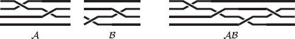

图 7.2 两条辫及其乘积。

**Figure 7.2.** Two braids and their product.

德奥尔努瓦于 1992 年发现，B_∞ 中的辫存在一个左不变线序，极大促进了 B_∞ 的研究。也就是说，辫上存在一个线序 <_B，满足

Study of *B<sub>∞</sub>* was greatly assisted by Dehornoy’s discovery, in 1992, that *there is a left-invariant linear order on the braids in B<sub>∞.</sub>* That is, there is a linear order <*<sub>B</sub>* on the braids for which

A<_Bℬ 蕴涵 CA<_BCℬ，对 B_∞ 中任意 C 都成立。

$A<Bℬ implies CA<BCℬ for any C in B∞.$

由于 B_∞ 中的辫本质上是有限对象，德奥尔努瓦的定理讨论的是有限对象。特别是，它可以编码为 PA 的一个定理。然而，他通过研究大基数发现这个定理，并坚持认为这才是通向它的自然道路，尽管如今已有较低层级的证明。在 Dehornoy（1995）第 33 页，他写道：

Since the braids in *B<sub>∞</sub>* are essentially finite objects, Dehornoy’s theorem is about finite objects. In particular, it can be encoded as a theorem of PA. Yet he discovered the theorem through a study of large cardinals, and he insists that this is the natural path to it, even though lower-level proofs are now known. In Dehornoy (1995), p. 33, he writes,

> 更准确地说，我们想解释，集合论直觉如何在某种意义上必然导向这些结果；特别是，为什么引入一种“奇特”的分配运算，以及辫上的线性排序，实际上是十年前始于集合论的一项研究的自然发展。

> More precisely we would like to explain how the set theoretical intuitions somehow *had to* lead these results, and in particular why the introduction of an ‘exotic’ distributive operation and of a linear ordering on braids is actually a natural development of an investigation initiated a decade ago in set theory.

对于德奥尔努瓦提到的研究，我们前面已经说过一些。它就是试图通过大基数公理理解射影决定性；这一尝试导出了伍丁、马丁与斯蒂尔的结果，说明射影决定性与无限多个伍丁基数存在之间的等价关系。

We have already said something about the investigation that Dehornoy refers to. Namely, it was the attempt to understand projective determinacy through large cardinal axioms, which led to the results of Woodin, Martin, and Steel asserting the equivalence of projective determinacy with the existence of infinitely many Woodin cardinals.

在寻找蕴涵射影决定性的最弱大基数假设的过程中，人们也研究了其他大基数假设。其中之一，即存在自相似的 $Vα$，最终被证明强于射影决定性所需，但它对其他目的很有用。特别是，它是最早已知能蕴涵辫排序的假设。

In the course of searching for the minimal large cardinal assumption that implies projective determinacy, other large cardinal assumptions were studied. One of these, the existence of a self-similar *V<sub>α</sub>*, ultimately proved stronger than needed for projective determinacy, but it was good for other purposes. In particular, it was the first assumption known to imply braid ordering.

回顾第 7.2 节，$Vα$ 是由秩低于 α 的集合构成的集合，也就是通过少于 α 次幂集运算构造出的全部集合。若存在从 $Vα$ 到自身的映射 f，它并不固定 $Vα$ 的所有元素，却保持一切可用 ZF 语言定义的性质，就称 $Vα$ 是自相似的。这些性质包括，例如“X 是空的”“X 是 Y 的元素”“X 是序数”“X 是后继”，等等。由此可知，映射 f 确实固定几乎所有我们能想到的集合。例如，

Recall from Section 7.2 that *V<sub>α</sub>* is the set of sets of rank *α*, that is, all sets that can be constructed by *α* applications of the power set operation. We say that *V<sub>α</sub>* is *self-similar* if there is a map *f* of *V<sub>α</sub>* into itself, not fixing all members of *V<sub>α</sub>*, but preserving all properties that can be defined in the language of ZF. Such properties include, for example, *“X* is empty,” *“X* is a member of *Y,” “X* is an ordinal,” *“X* is a successor,” and so on. It follows that the map *f does* fix almost any set one can think of. For example

f(0)=0，因为 0 是唯一的空集；  
f(1)=1，因为 1 是 0 的唯一后继；  
⋮  
f(ω)=ω，因为 ω 是唯一一个以 0、1、2、……为元素的集合。

$f(0)=0, because 0 is the unique empty set, f(1)=1, because 1 is the unique successor of 0, ⋮f(ω)=ω because ω is the unique set with members 0,1,2,….$

事实上，可以证明，不被 f 固定的最小序数，大于无限多个伍丁基数，因此，存在自相似的 $Vα$ 是一条大基数公理，甚至强于无限多个伍丁基数的存在。

In fact, it can be shown that the least ordinal *not* fixed by *f* is greater than infinitely many Woodin cardinals, so the existence of a self-similar *V<sub>α</sub>* is a large cardinal axiom, even stronger than the existence of infinitely many Woodin cardinals.

如前所述，这条特定的大基数公理之所以有趣，是因为它导向了辫排序的发现。如今我们知道，辫排序可以从 ZF 等较弱假设证明。不过，关于有限对象的定理，并不总能消去其中的大基数假设。在一项仍在进行的研究计划中，哈维·弗里德曼找到了极大的基数公理，它们具有极其有限、且以其他方式无法证明的后果。他找到了许多后果属于 PA 的例子。这些例子是否像辫排序一样“自然”，尚可争论；但它们仍说明，即使在有限数学中，也有必须使用无穷的地方。

As we have said, this particular large cardinal axiom is interesting because it led to the *discovery* of the braid ordering. We now know that braid ordering can be proved from weaker assumptions, such as ZF. However, it is not always possible to eliminate large cardinal assumptions from theorems about finite objects. In a research program that is still under way, Harvey Friedman has found very large cardinal axioms with very finite consequences that are not otherwise provable. He has found many examples where the consequences are in PA. It is debatable whether his examples are as “natural” as the braid ordering, but they nevertheless make the point that *there are necessary uses of infinity, even in finite mathematics.*

## 7.6 历史背景

## 7.6 Historical Background

### 无穷公理

### Axioms of infinity

> 这样一个数，即不可达基数，的存在……至少看来是可疑的；不过，在下文中必须把它作为一种可能性考虑。

> The existence of one such number [an inaccessible cardinal] … seems at least problematic; however, it must be considered as a possibility in what follows.

> ——费利克斯·豪斯多夫（1908），第 444 页。

> —Felix Hausdorff (1908), p. 444.

ZF−无穷 本质上就是 PA 这一观察，归功于希尔伯特的学生威廉·阿克曼。1937 年，他把 ZF−无穷 编码到 PA 中，再诉诸根岑对 PA 的一致性证明，从而证明 ZF−无穷 的一致性。他还说明，PA 也可以编码到 ZF−无穷 中，因此这两个理论等一致。

The observation that ZF — Infinity is essentially PA is due to Hilbert’s student Wilhelm Ackermann. In 1937 he proved the consistency of ZF — Infinity by encoding it in PA, then appealing to Gentzen’s consistency proof for PA. He also showed that PA may be encoded in ZF — Infinity, so the two theories are equiconsistent.

不可达基数最早由费利克斯·豪斯多夫于 1908 年考虑，随后保罗·马洛于 1911–1913 年作了推广。马洛考虑不可达基数递增序列的极限，如今称为马洛基数。豪斯多夫与马洛实际考虑的概念，如今称为弱不可达性；在所谓广义连续统假设 2^{$ℵα$}=$ℵα+1$ 下，它与通常的不可达性一致。这个假设也是豪斯多夫在 1908 年的论文中引入的，因此在某种意义上，他也考虑了通常的不可达性。

Inaccessible cardinals were first considered by Felix Hausdorff in 1908, and studied more thoroughly by Paul Mahlo in 1911–1913. Mahlo considered limits of increasing sequences of inaccessibles, now known as *Mahlo cardinals.* Hausdorff and Mahlo actually considered a concept now called *weak inaccessibility*, which agrees with ordinary inaccessibility under the so-called *generalized continuum hypothesis:*$2ℵα=ℵα+1$. This hypothesis was also introduced by Hausdorff in his 1908 paper, so in a way he considered ordinary inaccessibility too.

更强的不可达性概念，涉及对替换与幂集运算都封闭，由谢尔平斯基与塔尔斯基于 1930 年引入。他们还为这个概念引入“不可达”一词，并把这个术语归于库拉托夫斯基。在一篇非凡的论文中，Kuratowski（1924）指出，不可达基数的存在不是 ZF＋AC 的定理；他未给证明，并假定一致性。也就是说，如果不可达基数存在，它们的存在就不能在 ZF＋AC 中证明，这是一种绝妙的神学式困境。不过，库拉托夫斯基使用的是豪斯多夫的弱不可达概念，因此当时若不假定广义连续统假设，就无法证明他的主张。Kanamori（2003）第 18 页指出了这个障碍。金森把第一个证明不可达基数存在性不可证的结果，归于 Zermelo（1930）。

The stronger concept of inaccessibility, involving closure under both the replacement and power operations, was introduced by Sierpiński and Tarski in 1930. They also introduced the term “inaccessible” for the concept, attributing it to Kuratowski. In a remarkable paper, Kuratowski (1924) pointed out (without proof, and assuming consistency) that the existence of inaccessibles is not a theorem of ZF + AC. Namely, *if inaccessibles exist, then their existence is not provable in ZF + AC*—an exquisitely theological predicament. However, Kuratowski was using the weak inaccessible concept of Hausdorff, so his claim could not have been proved at that time without assuming the generalized continuum hypothesis. This obstacle was pointed out by Kanamori (2003), p. 18. Kanamori credits the first proof that the existence of inaccessibles is unprovable to Zermelo (1930).

事实上，策梅洛于 1928 年 2 月 2 日在弗赖堡的一次报告中介绍了这个结果，Baer（1928）第 383 页对此有报道。按今天的标准，策梅洛的证明不算严格，但其思想极其简单，因此很容易重写为符合现代标准的证明。它不涉及哥德尔不完备性定理那样复杂的内容，尽管其中第二定理也说明，不可达基数的存在不能在 ZF＋AC 中证明。²

In fact, Zermelo presented his result in a talk at Freiburg on February 2, 1928, and it was reported in Baer (1928), p. 383. Zermelo’s proof would not be considered rigorous today, but his idea is so exquisitely simple that the proof can be easily rewritten to comply with current standards. It does not involve anything as sophisticated as Gödel’s incompleteness theorems, the second of which also shows that the existence of inaccessibles cannot be proved in ZF + AC.<sup>2</sup>

策梅洛不完备性定理

Zermelo’s incompleteness theorem

若不可达的 κ 存在，这一事实就不能在 ZF＋AC 中证明。这是因为 $Vκ$ 是 ZF＋AC 的一个模型。因此，若 κ 是具有这一性质的最小序数，则 $Vκ$ 满足

*If inaccessible κ exist, then this fact is not provable in* ZF + AC. This is because *V<sub>κ</sub>* is a model of ZF+AC. So, if *κ* is the *smallest* ordinal with this property, then *V<sub>κ</sub>* satisfies

ZF＋AC＋“不存在不可达基数”，

$ZF+AC+ "there is no inaccessible,"$

因为 $Vκ$ 中的序数 α 都满足 α<κ，因此都不是不可达的。

because the *a* in *V<sub>κ</sub>* are such that *α < κ*, hence they are not inaccessible.

同样在 1930 年，库拉托夫斯基的学生斯坦尼斯瓦夫·乌拉姆发现，可测基数是不可达的。因此，库拉托夫斯基称乌拉姆为“我最伟大的发现”。但直到 1960 年，塔尔斯基与学生威廉·汉夫才发现，可测基数大于最小不可达基数，因而具有独立的研究价值。³ 由此可知，若可测基数存在，即使在 ZF＋AC＋不可达基数 中，也不能证明它们的存在。这是因为存在一个最小可测基数 κ，于是 $Vκ$ 不仅满足 ZF＋AC＋不可达基数，也满足“不存在可测基数”，因为 $Vκ$ 中的所有基数都小于 κ。从 $Vκ$ 的观点看，其中的基数也都不可测，不过这一点并不显然。

Also in 1930, Kuratowski’s student Stanisław Ulam found that measurable cardinals are inaccessible. (Because of this, Kuratowski described Ulam as “my greatest discovery.”) But it was not until 1960 that measurable cardinals were found to be larger than the smallest inaccessible cardinal—by Tarski and his student William Hanf—and hence of independent interest.<sup>3</sup> It follows that, if measurable cardinals exist, one cannot *prove* their existence even in ZF + AC + Inaccessible. This is because there is a smallest measurable cardinal κ,and then *V<sub>κ</sub>* satisfies not only ZF + AC + Inaccessible but also “there is no measurable cardinal,” since all the cardinals in *V<sub>κ</sub>* are less than *κ*. (The cardinals in *V<sub>κ</sub>* are also non-measurable *from the viewpoint of κ*, though this not obvious.)

此后，大基数世界迅速扩张。Kanamori（2003）对这个世界及其历史作了精彩介绍。真正无畏的读者，也许愿意查阅 Jech（2003），了解更多技术细节，例如索洛韦关于“所有实数集都勒贝格可测”一致性的定理。

After this, the world of large cardinals expanded rapidly. A fine account of this world, and its history, is given in Kanamori (2003). Really intrepid readers may wish to consult Jech (2003) for further technical details, such as Solovay’s theorem on the consistency of “all sets of reals are Lebesgue measurable.”

### 描述集合论

### Descriptive Set Theory

> 勒贝格那个微不足道的错误，我是这样称呼它的，竟然极其有用：它引发了新概念与新定理的雪崩。

> Lebesgue’s trivial (as I have called it) mistake proved to be very useful: it unleashed an avalanche of new concepts and theorems.

> ——卡齐米日·库拉托夫斯基（1980），第 70 页。

> —Kazimierz Kuratowski (1980), p. 70.

起初，集合论主要是一门“基础性”学科，旨在澄清分析的基本概念：数、函数、极限、测度。当然，康托尔很快就遇到了分析学家未曾想到的问题，即连续统假设（CH）。但有理由相信，CH 可以通过分析似乎也需要的同一个思想解决：按定义的复杂性对实数集分类。为研究这个分类问题而发展的理论，后来称为描述集合论。

In the beginning, set theory was mainly a “foundational” discipline that aimed to clarify the basic concepts of analysis: numbers, functions, limits, measure. Of course, Cantor quickly encountered a problem that the analysts had not thought of—the continuum hypothesis (CH). But there was reason to suppose that CH would be solved by the same idea that analysis seemed to need: a *classification* of sets of real numbers in terms of the *complexity* of their definitions. The theory developed to attack this classification problem came to be known as *descriptive set theory.*

第 2.9 节已经看到，到 1905 年，博雷尔、贝尔与勒贝格已把博雷尔集分为 ℵ₁ 个层级，部分目的是描述可测集。这是描述集合论中第一个实质性结果。康托尔本人对实数集的分类并未走得很远，但他引入的一种集合性质，极大影响了描述集合论此后的发展，即完全集性质。

We saw in Section 2.9 that by 1905 Borel, Baire, and Lebesgue had developed a classification of the Borel sets into ℵ<sub>1</sub> levels, partly as a means to describe the measurable sets. This was the first substantial result in descriptive set theory. Cantor himself did not get far in classifying sets of reals, but he introduced a property of sets that greatly influenced the future evolution of descriptive set theory—the *perfect set property.*

若一个集合非空、闭合且不含孤立点，就称它为完全集。例如，区间 [0,1] 是完全集，但整数点集不是。很容易说明，任意完全集的基数都是 $2ℵ0$。Cantor（1883）证明，每个不可数闭集都包含一个完全集，因此任意不可数闭集的基数都是 $2ℵ0$。如今，我们把康托尔的结果表述为：闭集类具有完全集性质。更一般地，若实数集的一个类 S 中，每个不可数集合 X 都包含一个完全集，就称 S 具有完全集性质。由此可知，“S 满足 CH”，意思是 S 中任意不可数元素 X 的基数都是 $2ℵ0$。

A set is called *perfect* if it is nonempty, closed, and contains no isolated points. For example, the interval [0,1] is a perfect set, but the set of integer points is not. It is quite easy to show that any perfect set has cardinality $2N0$. Cantor (1883) proved that every uncountable closed set contains a perfect set, so any uncountable closed set has cardinality $2N0.$. We now express Cantor’s result by saying that *the class ofclosed sets has the perfect set property.* More generally, we say that *aclass S of sets of reals has the perfect set property* if any uncountable set *X* in *S* contains a perfect set. It follows that “*S* satisfies CH,” in the sense that any uncountable member *X* of *S* has cardinality $2N0.$.

闭集位于博雷尔层级的最底部，因此康托尔的结果距离证明 CH 还很远。不过，可以希望证明，完全集性质与可测性一样，延伸到整个博雷尔层级。事实上，所有博雷尔集确实都有完全集性质，但这直到 1916 年才由帕维尔·亚历山德罗夫确立；他属于尼古拉·卢津领导的俄罗斯学派。

The closed sets lie at the very bottom of the Borel hierarchy, so Cantor’s result is a long way from a proof of CH. However, one might hope to show that the perfect set property extends all the way up the Borel hierarchy, just as measurability extends all the way. In fact, all Borel sets *d<sub>0</sub>* have the perfect set property, but this was established only in 1916, by Pavel Aleksandrov, a member of the Russian school headed by Nikolai Luzin.

卢津于 1905 年在巴黎学习，受到博雷尔与勒贝格影响。起初，他的兴趣在分析，但到 1916 年，他意识到自己真正的志业是描述集合论。他的学派因学生米哈伊尔·苏斯林的一项发现而声名鹊起：博雷尔集的投影不一定是博雷尔集，这正是勒贝格 1905 年论文中的错误。由此，一个全新的集合类浮出水面：博雷尔集的投影，后来称为解析集。随之而来的挑战，是把博雷尔集的已知结果，例如可测性与完全集性质，推广到它们。

Luzin studied in Paris in 1905 and was influenced by Borel and Lebesgue. At first his interests were in analysis, but by 1916 he had realized that his true calling was in descriptive set theory. His school gained fame through the discovery of his student, Mikhael Suslin, that the projections of Borel sets are *not* always Borel (the mistake in Lebesgue’s 1905 paper). This brought to light a whole new class of sets: the projections of Borel sets, later known as the analytic sets. With them came the challenge of extending the results already known for Borel sets, such as measurability and the perfect set property.

1917 年，卢津证明解析集可测，苏斯林证明它们具有完全集性质，因此，康托尔迈向连续统假设的漫长征程又前进一步。下一步是什么？1925 年，卢津与瓦茨瓦夫·谢尔平斯基考虑了由任意维数的博雷尔集通过投影与取补得到的全部集合，预示着向解析集类之外的推进；他们把这些集合称为射影集。

In 1917 Luzin proved that analytic sets are measurable, and Suslin proved that they have the perfect set property, so Cantor’s long march towards the continuum hypothesis was taken a step further. What was next? In 1925, Luzin and Wacław Sierpiński foreshadowed a move beyond the class of analytic sets by considering *all* sets obtainable from Borel sets (of any dimension) by projection and complementation—what they called the projective sets.

射影集构成一个具有 ω 个层级的层级结构，最初称为

The projective sets form a hierarchy of *ω* levels, originally called

A 与 CA，即解析集及其补集；PCA 与 CPCA，即 CA 集的投影及其补集；

$A and CA (analytic sets, and their complements), PCA and CPCA (projections of CA sets, and their complements),$

依此类推。今天有一种更简短的记号，但解释起来更费时间。每个层级都有新集合，但即使在第二层，证明可测性与完全集性质的任务也似乎无法克服。事实上，Luzin（1925）作出了大胆而富有预见性的宣言：对于所有射影集是否都可测、是否都具有完全集性质，“人们不知道，也永远不会知道”。Luzin（1930）第 323 页进一步阐述：

and so on. (Today there is a shorter notation, but it takes longer to explain.) There are new sets in each level, but the task of proving measurability and the perfect set property seems insuperable even at the second level. Indeed, Luzin (1925) made the bold and prophetic declaration that “one does not know and *one will never know”* whether all projective sets are measurable and have the perfect set property. Luzin (1930), p. 323, elaborated:

> ……作者认为，判断所有射影集是否可测的问题不可解，因为在他看来，射影集与勒贝格可测性的定义不可比较，因此在逻辑上没有联系。

> … the author considers the question of knowing whether all projective sets are measurable to be insoluble, because in his view the definitions of projective set and Lebesgue measurability are incomparable and hence not logically related.

后来的发展表明，卢津的预言相当接近事实。ZF 公理不能判定所有射影集是否都可测，也不能判定它们是否都具有完全集性质；采用不同的附加公理，会得到不同答案。

Luzin’s prophecy was close to the mark, as later developments showed. The ZF axioms do not decide whether all the projective sets are measurable, or whether they all have the perfect set property—and one gets different answers depending on which additional axioms are used.

若像哥德尔于 1938 年证明选择公理的一致性时那样，取“所有集合都可构造”为公理，见第 2.9 节，就得到实数集 ℝ 的一个可定义良序，并由此得到一个可定义的不可测集。哥德尔注意到，显然得到过乌拉姆的一些帮助，这个定义把不可测集放在射影层级的第二层。此外，还会得到一个不具有完全集性质的 CA 集。另一方面，如第 7.3 节所见，假定存在无限多个伍丁基数，就能证明所有射影集都具有决定性，因而可测。同一假设也蕴涵所有射影集都有完全集性质，因为完全集性质是决定性的另一个良好后果。

If one takes the axiom that all sets are constructible, as Gödel did in 1938 when proving the consistency of the axiom of choice (see Section 2.9), then one gets a definable well-ordering of R,and with it a definable nonmeasurable set. Gödel noticed (apparently with some help from Ulam) that the definition puts the nonmeasurable set in the second level of the projective hierarchy. Moreover, one gets a CA set without the perfect set property. On the other hand, as we saw in Section 7.3, assuming the existence of infinitely many Woodin cardinals allows us to prove that all projective sets are determined, and hence measurable. The same assumption implies that all projective sets have the perfect set property, because the perfect set property is another of the nice consequences of determinacy.

集合论中当前的一种看法是，大基数公理这样的“包容性”公理，比哥德尔可构造性公理这样的“限制性”公理更可信。例如，由选择公理得到的集合，似乎理应尽可能远离“可定义”，而大基数公理似乎做到了这一点。但基数越大，我们离可证明性就越远。也许我们已经越过界线，进入矛盾。人们不知道，也许永远不会知道。

Current thinking in set theory is that “inclusive” axioms, such as the large cardinal axioms, are more plausible than “restrictive” axioms such as Gödel’s axiom of constructibility. It seems right, for example, that sets obtained by the axiom of choice should be as far from “definable” as possible, and large cardinal axioms seem to achieve this. But the larger the cardinal, the further we are from provability. Perhaps we have already crossed the line into contradiction. One does not know, and one may never know.

### 无穷公理能解决一切吗？

### Do Axioms of Infinity Settle Everything?

> 并非不可能……存在某种完备性定理，断言每个可用集合论表达的命题，都能由现有公理加上某个关于集合宇宙之“大”的真断言来判定。

> It is not impossible that … some completeness theorem would hold which would say that every proposition expressible in set theory is decidable from the present axioms plus some true assertion about the largeness of the universe of sets.

> ——库尔特·哥德尔

> —Kurt Gödel

> 1946 年普林斯顿大学二百周年纪念会议前的评论，载于 Gödel（1990），第 151 页。

> *Remarks before the Princeton bicentennial conference*, 1946, in Gödel (1990), p. 151.

1930 年证明不完备性定理后不久，哥德尔就开始思考，这些定理所蕴涵的对更强新公理的无尽需求。我们无法以任何可计算方式枚举一个完备的公理序列，但也许可以说明，公理不断增长的“强度”应如何用数学描述。集合论似乎是检验哥德尔“纲领”的好场所，因为它善于通过序数与基数度量无尽的复杂性，而且有大量未获证明的定理。大基数的历史似乎印证了这一点：索洛韦、马丁、斯蒂尔与伍丁使用越来越大的基数，导出关于实数集的越来越强的定理。

Soon after he proved his incompleteness theorems in 1930, Gödel began to think about the endless need for new and stronger axioms that his theorems imply. We cannot enumerate a complete sequence of such axioms in any computable way, but perhaps it is possible to say how increasing “strength” of axioms might be described mathematically. Set theory looks like a good arena for testing Gödel’s “program,” because it is good at measuring endless complexity—by ordinals and cardinals— and it is rich in unproved theorems. The history of large cardinals seems to bear this out, with Solovay, Martin, Steel, and Woodin using larger and larger cardinals to derive stronger and stronger theorems about sets of real numbers.

确实，可以理解：若基数 κ 大到使 $Vκ$ 成为 ZF 的模型，而 λ>κ 且 $Vλ$ 也是 ZF 的模型，那么 λ 的存在所蕴涵的内容，比 κ 的存在更多。这是因为 $Vκ$ 是 ZF＋“κ 不存在”的模型，因为 κ 不在 $Vκ$ 中；而 $Vλ$ 是 ZF＋“κ 存在”的模型，因为 κ<λ，故 κ 在 $Vλ$ 中。因此，人们也许开始希望，ZF 公理无法解决的任何语句，都能由适当的大基数公理解决。

哥德尔也知道，无穷公理可以判定 PA 中不可证明的整数语句。例如，Con(PA) 在 PA 中不可证，因而在 ZF−无穷 中也不可证；但在 ZF 中，通过展示 PA 公理的一个模型，例如 $Vω$，就能证明 Con(PA)。因此，ZF 通常的无穷公理，已经足以证明 Con(PA)。更强的无穷公理能证明更多。例如，由哥德尔第二定理，Con(ZF) 在 ZF 中不可证，但它在 ZF＋不可达基数 中可证，因为对于不可达的 κ，$Vκ$ 是 ZF 的模型，依此类推。

Gödel was also aware that axioms of infinity decide sentences about *integers* that are unprovable in PA. For example, Con(PA) is not provable in PA and hence not in ZF — Infinity either, but in ZF we can prove Con(PA) by exhibiting a model for the PA axioms, such as *V<sub>ω</sub>* .Thus the ordinary ZF axiom of infinity is strong enough to prove Con(PA). Stronger axioms of infinity can prove more. For example, Con(ZF) is not provable in ZF, by Gödel’s second theorem, but it is provable in ZF + Inaccessible because, for inaccessible κ, is a model of ZF, and so on.

如上一节所述，大基数公理可以证明关于整数的新定理，例如 Con(ZF)，超出 ZF 无穷公理这样“小”基数公理所能证明的范围。这些新定理包括形如“p(x₁,x₂,…,$xn$)=0 没有整数解”的语句，其中 p 是整系数多项式。这由第 3.8 节提到的马季亚谢维奇关于多项式方程的工作推出。因此，大基数的长臂一直伸到基本算术。

As mentioned in the previous section, large cardinal axioms can prove new theorems about integers, such as Con(ZF), beyond those provable from “small” cardinal axioms such as the ZF axiom of infinity. The new theorems include some of the form “*p*(*x*<sub>1</sub>, *x*<sub>2</sub>,…, *x<sub>n</sub>*)= 0 has no integer solution,” where *p* is a polynomial with integer coefficients. This follows from the Matiyasevich work on polynomial equations mentioned in Section 3.8. Thus the long arm of large cardinals reaches all the way down to basic arithmetic.

我们也知道，某些“微型”无穷公理会影响 PA：ε₀-归纳证明 Con(PA) 与古德斯坦定理，而 Γ-归纳证明弗里德曼的克鲁斯卡尔定理有限形式，其中 Γ 是一个远大于 ε₀ 的特定可数序数。这里，ε₀-归纳类似 ZF 通常的无穷公理，而 Γ-归纳也许类似某种不可达基数公理。归纳公理及其后果的理论，不如大基数公理及其后果的理论发达，但未来值得期待。通向无穷的道路，不应只有两条，而应有三条、四条、许多条。

We also know that certain “miniature” axioms of infinity have an influence on PA: ε<sub>0</sub>-induction proves Con(PA) and Goodstein’s theorem, while Γ-induction proves Friedman’s finite form of Kruskal’s theorem, where Γ is a particular countable ordinal much larger than ε0.Here ε<sub>0</sub>-induction is analogous to the ordinary ZF axiom of infinity, and Γ-induction is perhaps the analogue of some axiom of inaccessibles. The theory of induction axioms and their consequences is not as developed as the theory of large cardinal axioms and their consequences, but we can expect more from it in the future. There should be not just two, but three, four, many roads to infinity.

尽管无穷公理取得了种种成功，我们仍须承认，它们迄今未能解决集合论最大的难题：连续统假设。1947 年，哥德尔写了一篇题为《什么是康托尔的连续统问题？》的论文，以类似上面引文的形式，表达了他对无穷公理的希望，但也对当时已知的公理有所怀疑，参见 Gödel（1990），第 182 页。

Nevertheless, for all the successes of axioms of infinity, we must admit that they have thus far failed to settle the biggest question of set theory: the continuum hypothesis. In 1947, Gödel wrote a paper called *What is Cantor’s Continuum Problem*? that expressed his hopes for axioms of infinity in a form similar to the quote above, but tempered with doubts about the axioms then known (see Gödel (1990), p. 182).

> 至于连续统问题，几乎没有希望借助那些可以在今日已知原则基础上建立的无穷公理来解决……但也许存在其他公理，建立在迄今未知的原则之上……

> As for the continuum problem, there is little hope of solving it by means of those axioms of infinity which can be set up on the basis of principles known today …But probably there exist others based on hitherto unknown principles …

20 世纪 60 年代，汉夫与塔尔斯基发现，可测基数强于单纯的不可达基数，随后又发现许多更强基数，一度重新燃起希望。但到 1967 年，由莱维与索洛韦的一个结果已清楚可见，科恩的方法可以构造集合论模型，使连续统假设不受这些新大基数的影响。

In the 1960s, hopes were temporarily raised by the discovery of Hanf and Tarski that measurable cardinals are stronger than mere inaccessibles, and the subsequent discovery of many stronger cardinals. But by 1967 it was clear (from a result of Levy and Solovay) that Cohen’s methods could be used to build models of set theory in which the continuum hypothesis was not affected by the new large cardinals.

如今，我们知道更多无穷公理，但它们似乎仍不能解决连续统假设。另一方面，据我们所知，其他合理公理也都不能。我们只能与希尔伯特一起希望：“我们必须知道，我们终将知道。”

Today, we know more axioms of infinity, but they still do not appear to settle the continuum hypothesis. On the other hand, neither do any other reasonable axioms, as far as we know. We can only hope, with Hilbert, that “we must know, we shall know.”

1 金森图表最上面的“公理”是“0=1”，反映了某些曾被提出的大基数公理后来被证明为假这一事实。追求能够蕴涵越来越多 ZF 语句的公理，就要承担这种风险。一个假公理在能够蕴涵每个语句的意义上，是“强”到极致的，但我们并不希望公理强到这种程度！

The top “axiom” on Kanamori’s chart is “0 = 1,” reflecting the fact that some proposed large cardinal axioms have turned out to be false. This is a risk one runs when pursuing axioms that imply more and more sentences of ZF. A false axiom is maximally “strong” in the sense that it implies every sentence, but one does not want axioms to be this strong!

2 事实上，策梅洛未能理解哥德尔对对角线论证的运用，也不相信哥德尔的定理正确。即使哥德尔于 1931 年给他写了一封长信，他仍未领会其中思想；这封信见 Gödel（2003），第 423 页。这也许证实了策梅洛的不完备性定理比哥德尔的更简单。

Indeed, Zermelo failed to understand Gödel’s use of the diagonal argument and did not believe that Gödel’s theorems were correct. He still did not get the idea even after Gödel wrote him a long letter in 1931, which may be found in Gödel (2003), p. 423. This perhaps confirms that Zermelo’s incompleteness theorem is simpler than Gödel’s.

3 这次轮到哥德尔不理解了。他于 1961 年 8 月起草了一封给塔尔斯基的信，但大概没有寄出，其中写道，见 Gödel（2003），第 273 页：

This time it was Gödel’s turn not to understand. In a letter to Tarski that he drafted, but probably did not send, in August 1961 he wrote (see Gödel (2003), p. 273),

> 我听说，已经证明第一个不可达数上不存在二值可数可加测度。我仍然不能相信这是真的……。

> I have heard it has been proved that there is no two valued denumerably additive measure for the first inacc. number. I still can’t believe that this is true ….

# 参考文献

# Bibliography

- Irving H. Annellis. 《从语义表到斯穆里安树：证伪树方法的发展史》. Modern Logic, 1:36–69, 1990.

  Irving H. Annellis. From semantic tableaux to Smullyan trees: a history of the development of the falsification tree method. Modern Logic, 1:36–69, 1990.
- Emil Artin. 《辫理论》. Abhandlungen aus dem Mathematischen Seminar der Universität Hamburg, 4:42-72, 1925.

  Emil Artin. Theorie der Zöpfe. Abhandlungen aus dem Mathematischen Seminar der Universität Hamburg, 4:42-72, 1925.
- Jeremy Avigad. 《数论与初等算术》. Philosophia Mathematica, 11(3):257–284, 2003.

  Jeremy Avigad. Number theory and elementary arithmetic. Philosophia Mathematica, 11(3):257–284, 2003.
- Jeremy Avigad. 《遍历理论的元数学》. Annals of Pure 与 Applied Logic, 157:64–76, 2009.

  Jeremy Avigad. The metamathematics of ergodic theory. Annals of Pure and Applied Logic, 157:64–76, 2009.
- Reinhold Baer. 《论基数算术的公理化》. Mathematische Zeitschrift, 29:381–396, 1928.

  Reinhold Baer. Zur Axiomatik der Kardinalarithmetik. Mathematische Zeitschrift, 29:381–396, 1928.
- Stefan Banach 与 Alfred Tarski. 《论点集分解为分别全等的部分》. Fundamenta Mathematicae, 6:244–277, 1924.

  Stefan Banach and Alfred Tarski. Sur la décomposition des ensembles de points en parties respectivement congruents. Fundamenta Mathematicae, 6:244–277, 1924.
- Jon Barwise. 《数理逻辑手册》. North-Holland Publishing Co., Amsterdam, 1977. Jon Barwise 主编，H. J. Keisler、K. Kunen、Y. N. Moschovakis 与 A. S. Troelstra 协助编纂。

  Jon Barwise. Handbook of Mathematical Logic. North-Holland Publishing Co., Amsterdam, 1977. Edited by Jon Barwise, With the cooperation of H. J. Keisler, K. Kunen, Y. N. Moschovakis and A. S. Troelstra.
- Emile Borel. 《函数论讲义》. Gauthier-Villars, Paris, 1898.

  Emile Borel. Leçons sur la théorie des fonctions. Gauthier-Villars, Paris, 1898.
- P. W. Bridgman. 《一位物理学家的思考》. Philosophical Library, New York, 1955.

  P. W. Bridgman. Reflections of a Physicist. Philosophical Library, New York, 1955.
- Peter J. Cameron. 《组合数学：专题、技巧与算法》. Cambridge University Press, Cambridge, 1994.

  Peter J. Cameron. Combinatorics: Topics, Techniques, Algorithms. Cambridge University Press, Cambridge, 1994.
- Georg Cantor. 《论无限线性点集》. Mathematische Annalen, 21:545–591, 1883. William Ewald 的英译文见 Ewald (1996), 第 II 卷, 第 881–920.

  Georg Cantor. Über unendliche, lineare Punktmannigfaltigkeiten. Mathematische Annalen, 21:545–591, 1883. English translation by William Ewald in Ewald (1996), volume II, pp. 881–920.
- Alonzo Church. 《数理逻辑导论，第 I 卷》. Princeton University Press, Princeton, N. J., 1956.

  Alonzo Church. Introduction to Mathematical Logic. Vol. I. Princeton University Press, Princeton, N. J., 1956.
- E. A. Cichon. 《用递归论方法简证两个新近发现的独立性结果》. Proceedings of the American Mathematical Society ,87 (4):704–706, 1983.

  E. A. Cichon. A short proof of two recently discovered independence results using recursion theoretic methods. Proceedings of the American Mathematical Society,87 (4):704–706, 1983.
- Paul J. Cohen. 《连续统假设的独立性》. Proceedings of the National Academy of Sciences, 50:1143–1148, 1963.

  Paul J. Cohen. The independence of the continuum hypothesis. Proceedings of the National Academy of Sciences, 50:1143–1148, 1963.
- Paul J. Cohen. 《集合论与连续统假设》. W. A. Benjamin, Inc., New York-Amsterdam, 1966.

  Paul J. Cohen. Set Theory and the Continuum Hypothesis. W. A. Benjamin, Inc., New York-Amsterdam, 1966.
- Stephen A. Cook. 《定理证明程序的复杂性》. Proceedings of the 3rd Annual ACM Symposium on the Theory of Computing, 第 151–158, 1971. Association of Computing Machinery, New York.

  Stephen A. Cook. The complexity of theorem-proving procedures. Proceedings of the 3rd Annual ACM Symposium on the Theory of Computing, pages 151–158, 1971. Association of Computing Machinery, New York.
- Martin Davis, editor. 《不可判定者》. Dover Publications Inc., Mineola, NY, 2004. 1965 年原版的修订重印本［Raven Press，Hewlett，NY］。

  Martin Davis, editor. The Undecidable. Dover Publications Inc., Mineola, NY, 2004. Corrected reprint of the 1965 original [Raven Press, Hewlett, NY].
- Liesbeth De Mol. 《标签系统与类科拉茨函数》. Theoretical Computer Science, 390(1):92–101, 2008. doi: 10.1016/j.tcs.2007.10.020. URL http://dx.doi.org/10.1016/j.tcs.2007.10.020 .

  Liesbeth De Mol. Tag systems and Collatz-like functions. Theoretical Computer Science, 390(1):92–101, 2008. doi: 10.1016/j.tcs.2007.10.020. URL http://dx.doi.org/10.1016/j.tcs.2007.10.020.
- Richard Dedekind. 《数论论文集》. Open Court, Chicago, 1901. Wooster Woodruff Beman 译。

  Richard Dedekind. Essays on the Theory of Numbers. Open Court, Chicago, 1901. Translated by Wooster Woodruff Beman.
- Patrick Dehornoy. 《经由分配代数从大基数走向辫》. Journal of Knot Theory 与 its Ramifications, 4(1):33–79, 1995.

  Patrick Dehornoy. From large cardinals to braids via distributive algebra. Journal of Knot Theory and its Ramifications, 4(1):33–79, 1995.
- Patrick Dehornoy. 《辫与自分配性》. Birkhäuser Verlag, Basel, 2000.

  Patrick Dehornoy. Braids and Self-distributivity. Birkhäuser Verlag, Basel, 2000.
- Reinhard Diestel. 《图论》. Springer-Verlag, Berlin, 第 3 版, 2005.

  Reinhard Diestel. Graph Theory. Springer-Verlag, Berlin, third edition, 2005.
- William Ewald. 《从康德到希尔伯特：数学基础史料集，第 I、II 卷》. The Clarendon Press Oxford University Press, New York, 1996.

  William Ewald. From Kant to Hilbert: A Source Book in the Foundations of Mathematics. Vol. I, II. The Clarendon Press Oxford University Press, New York, 1996.
- Dov M. Gabbay 与 John Woods. 《逻辑史手册》, 第 5 卷.Elsevier, Amsterdam, 2009. Dov M. Gabbay 与 John Woods 主编。

  Dov M. Gabbay and John Woods. Handbook of the History of Logic, volume 5.Elsevier, Amsterdam, 2009. Edited by Dov M. Gabbay and John Woods.
- George Gamow. 《从一到无穷大》. Viking Press, New York, 1947.

  George Gamow. One, Two, Three,Infinity. Viking Press, New York, 1947.
- Gerhard Gentzen. 《逻辑推理研究》. Mathematische Zeitschrift, 19:176–210, 1935. M. E. Szabo 的英译文见 Gentzen (1969), 第 68–131.

  Gerhard Gentzen. Untersuchungen über das logische Schliessen. Mathematische Zeitschrift, 19:176–210, 1935. English translation by M.E. Szabo in Gentzen (1969), pp. 68–131.
- Gerhard Gentzen. 《纯数论的无矛盾性》. Mathematische Annalen, 112:493–565, 1936. M. E. Szabo 的英译文见 Gentzen (1969), 第 132–213.

  Gerhard Gentzen. Die Widerspruchsfreiheit der reinen Zahlentheorie. Mathematische Annalen, 112:493–565, 1936. English translation by M.E. Szabo in Gentzen (1969), pp. 132–213.
- Gerhard Gentzen. 《纯数论中超限归纳初始情形的可证明性与不可证明性》. Mathematische Annalen, 119: 140–161, 1943. M. E. Szabo 的英译文见 Gentzen (1969), 第 287–308.

  Gerhard Gentzen. Beweisbarkeit und Unbeweisbarkeit von Anfangsfällen der transfiniten Induktion in der reinen Zahlentheorie. Mathematische Annalen, 119: 140–161, 1943. English translation by M.E. Szabo in Gentzen (1969), pp. 287–308.
- Gerhard Gentzen. 《格哈德·根岑论文集》. M. E. Szabo 主编。 North-Holland Publishing Co., Amsterdam, 1969.

  Gerhard Gentzen. The Collected Papers of Gerhard Gentzen. Edited by M. E. Szabo. North-Holland Publishing Co., Amsterdam, 1969.
- Jean-Yves Girard. 《证明论与逻辑复杂性》. Bibliopolis, Naples, 1987.

  Jean-Yves Girard. Proof Theory and Logical Complexity. Bibliopolis, Naples, 1987.
- Henry H. Glover, John P. Huneke, 与 Chin San Wang. 《射影平面的 103 个不可约图》. Journal of Combinatorial Theory, Series B, 27 (3):332–370, 1979.

  Henry H. Glover, John P. Huneke, and Chin San Wang. 103 graphs that are irreducible for the projective plane. Journal of Combinatorial Theory, Series B, *27* (3):332–370, 1979.
- Kurt Gödel. 《论证明的长度》. Ergebnisse eines mathematischen Kolloquiums, 7:23–24, 1936. 英译文见 Gödel (1986), 第 397–399.

  Kurt Gödel. Über die Länge von Beweisen. Ergebnisse eines mathematischen Kolloquiums, 7:23–24, 1936. English translation in Gödel (1986), pp. 397–399.
- Kurt Gödel. 《选择公理与广义连续统假设的一致性》. Proceedings of the National Academy of Sciences, 24:556–557, 1938.

  Kurt Gödel. The consistency of the axiom of choice and the generalized continuum-hypothesis. Proceedings of the National Academy of Sciences, 24:556–557, 1938.
- Kurt Gödel. 《广义连续统假设的一致性证明》. Proceedings of the National Academy of Sciences, 25:220–224, 1939.

  Kurt Gödel. Consistency proof for the generalized continuum hypothesis. Proceedings of the National Academy of Sciences, 25:220–224, 1939.
- Kurt Gödel. 《文集，第 I 卷》. The Clarendon Press Oxford Üniversity Press, New York, 1986. 收录 1929–1936 年的著作，Solomon Feferman 编辑并作序。

  Kurt Gödel. Collected works. Vol. I. The Clarendon Press Oxford Üniversity Press, New York, 1986. Publications 1929–1936, Edited and with a preface by Solomon Feferman.
- Kurt Gödel. 《文集，第 II 卷》. The Clarendon Press Oxford Üniversity Press, New York, 1990. 收录 1938–1974 年的著作，Solomon Feferman 编辑并作序。

  Kurt Gödel. Collected Works. Vol. II. The Clarendon Press Oxford Üniversity Press, New York, 1990. Publications 1938–1974, Edited and with a preface by Solomon Feferman.
- Kurt Gödel. 《文集，第 V 卷》. The Clarendon Press Oxford Üniversity Press, Oxford, 2003. 书信 H–Z，Solomon Feferman、John W. Dawson, Jr.、Warren Goldfarb、Charles Parsons 与 Wilfried Sieg 编辑。

  Kurt Gödel. Collected Works. Vol. V. The Clarendon Press Oxford Üniversity Press, Oxford, 2003. Correspondence H–Z, Edited by Solomon Feferman, John W. Dawson, Jr., Warren Goldfarb, Charles Parsons and Wilfried Sieg.
- R. L. Goodstein. 《论受限序数定理》. The Journal of Symbolic Logic, 9:33–41, 1944.

  R. L. Goodstein. On the restricted ordinal theorem. The Journal of Symbolic Logic, 9:33–41, 1944.
- Ronald L. Graham, Bruce L. Rothschild, 与 Joel H. Spencer. 《拉姆齐理论》 .John Wiley & Sons Inc., New York, 第 2 版, 1990.

  Ronald L. Graham, Bruce L. Rothschild, and Joel H. Spencer. Ramsey Theory.John Wiley & Sons Inc., New York, second edition, 1990.
- Hermann Grassmann. 《算术教科书》. Enslin, Berlin, 1861.

  Hermann Grassmann. Lehrbuch der Arithmetik. Enslin, Berlin, 1861.
- G. H. Hardy. 《一个关于无限基数的定理》. The Quarterly Journal of Pure 与 Applied Mathematics, 35:87–94, 1904.

  G. H. Hardy. A theorem concerning the infinite cardinal numbers. The Quarterly Journal of Pure and Applied Mathematics, 35:87–94, 1904.
- Felix Hausdorff. 《有序集理论纲要》. Mathematische Annalen, 65:435–505, 1908. 英译文见 Hausdorff (2005), 第 197–258.

  Felix Hausdorff. Grundzüge einer Theorie der geordneten Mengen. Mathematische Annalen, 65:435–505, 1908. English translation in Hausdorff (2005), pp. 197–258.
- Felix Hausdorff. 《集合论》. Chelsea Publishing Company, New York, 1937/1957. 由 John R. Aumann 等人根据 1937 年德文版翻译。

  Felix Hausdorff. Set Theory. Chelsea Publishing Company, New York, 1937/1957. Translation of the 1937 German edition by John R. Aumann, et al.
- Felix Hausdorff. 《豪斯多夫论有序集》. American Mathematical Society, Providence, RI, 2005. J. M. Plotkin 从德文翻译、编辑并加注。

  Felix Hausdorff. Hausdorff on Ordered Sets. American Mathematical Society, Providence, RI, 2005. Translated from the German, edited and with commentary by J. M. Plotkin.
- David Hilbert. 《数学的新奠基（第一报告）》. Abhandlungen aus dem mathematischen Seminar der Hamburgischen Universität, 1:157–177, 1922. 英译文见 Ewald (1996), 第 II 卷, 第 1117–1134.

  David Hilbert. Neubegründung der mathematik (erste mitteilung). Abhandlungen aus dem mathematischen Seminar der Hamburgischen Universität, 1:157–177, 1922. English translation in Ewald (1996), vol. II, pp. 1117–1134.
- David Hilbert. 《论无穷》. Mathematische Annalen, 95:161–190, 1926. 英译文见 van Heijenoort (1967), 第 367–392.

  David Hilbert. Über das Unendliche. Mathematische Annalen, 95:161–190, 1926. English translation in van Heijenoort (1967), pp. 367–392.
- Thomas Jech. 《集合论》. Springer-Verlag, Berlin, 第 3 版, 2003.

  Thomas Jech. Set Theory. Springer-Verlag, Berlin, third edition, 2003.
- Akihiro Kanamori. 《更高的无穷》. Springer-Verlag, Berlin, 第 2 版, 2003.

  Akihiro Kanamori. The Higher Infinite. Springer-Verlag, Berlin, second edition, 2003.
- Akihiro Kanamori 与 Menachem Magidor. 《集合论中大基数公理的演化》. 载于 Higher Set Theory, 第 99–275. Springer, Berlin, 1978.

  Akihiro Kanamori and Menachem Magidor. The evolution of large cardinal axioms in set theory. In Higher Set Theory, pages 99–275. Springer, Berlin, 1978.
- Laurie Kirby 与 Jeff Paris. 《皮亚诺算术的易于理解的独立性结果》. The Bulletin of the London Mathematical Society, 14(4):285–293, 1982.

  Laurie Kirby and Jeff Paris. Accessible independence results for Peano arithmetic. The Bulletin of the London Mathematical Society, 14(4):285–293, 1982.
- Dénes König. 《有限图与无限图理论》.Birkhäuser Boston Inc., Boston, MA, 1936/1990. Richard McCoart 根据 1936 年德文版翻译。

  Dénes König. Theory of Finite and Infinite Graphs.Birkhäuser Boston Inc., Boston, MA, 1936/1990. Translated from the 1936 German edition by Richard McCoart.
- Kazimierz Kuratowski. 《论集合论公理化的现状》. Annales de la Société Polonaise de Mathématique, 3:146–149, 1924. 载于 Kuratowski (1988), 第 179.

  Kazimierz Kuratowski. Sur l’ état actuel de l’axiomatique de la théorie des ensembles. Annales de la Société Polonaise de Mathématique, 3:146–149, 1924. In Kuratowski (1988), p. 179.
- Kazimierz Kuratowski. 《论拓扑学中的空间曲线问题》. Fundamenta Mathematicae, 15:271–283, 1930. 载于 Kuratowski (1988), 第 345–357.

  Kazimierz Kuratowski. Sur le problème des courbes gauches en topologie. Fundamenta Mathematicae, 15:271–283, 1930. In Kuratowski (1988), pp. 345–357.
- Kazimierz Kuratowski. 《波兰数学半世纪》. Pergamon Press Inc., Elmsford, N.Y., 1980. Andrzej Kirkor 从波兰文翻译，S. Ulam 作序。

  Kazimierz Kuratowski. A Half Century of Polish Mathematics. Pergamon Press Inc., Elmsford, N.Y., 1980. Translated from the Polish by Andrzej Kirkor, With a preface by S. Ulam.
- Kazimierz Kuratowski. 《论文选集》. PWN—Polish Scientific Publishers, Warsaw, 1988.

  Kazimierz Kuratowski. Selected Papers. PWN—Polish Scientific Publishers, Warsaw, 1988.
- Bruce M. Landman 与 Aaron Robertson. 《整数上的拉姆齐理论》.American Mathematical Society, Providence, RI, 2004.

  Bruce M. Landman and Aaron Robertson. Ramsey Theory on the Integers.American Mathematical Society, Providence, RI, 2004.
- Azriel Levy. 《基础集合论》. Springer-Verlag, Berlin, 1979.

  Azriel Levy. Basic Set Theory. Springer-Verlag, Berlin, 1979.
- Nikolai N. Luzin. 《论亨利·勒贝格的射影集》. Comptes Rendus de l’Academie des Sciences, Paris, 180:1572–1574, 1925.

  Nikolai N. Luzin. Sur les ensembles projectifs de M. Henri Lebesgue. Comptes Rendus de l’Academie des Sciences, Paris, 180:1572–1574, 1925.
- Nikolai N. Luzin. 《解析集讲义》. Gauthier-Villars, Paris, 1930. Chelsea 于 1972 年在纽约修订重印。

  Nikolai N. Luzin. Leçons sur les ensembles analytiques. Gauthier-Villars, Paris, 1930. Reprinted with corrections by Chelsea, New York, 1972.
- Donald A. Martin. 《可测基数与解析博弈》. Fundamenta Mathematicae, 66:287–291, 1969/1970.

  Donald A. Martin. Measurable cardinals and analytic games. Fundamenta Mathematicae, 66:287–291, 1969/1970.
- Herman Melville. 《霍桑与他的《古屋青苔》》. Literary World, 24, August 17, 1850. 载于 Herman Melville. Pierre, Israel Potter, The Piazza Tales, The Confidence Man, Uncollected Prose, 与 Billy Budd, Library of America, 1984, 第 1154–1171.

  Herman Melville. Hawthorne and his mosses. Literary World, 24, August 17, 1850. In *Herman Melville. Pierre, Israel Potter, The Piazza Tales, The Confidence Man, Uncollected Prose, and Billy Budd,* Library of America, 1984, pp. 1154–1171.
- Elliott Mendelson. 《数理逻辑导论》. D. Van Nostrand Co., Inc., Princeton, NJ, 1964.

  Elliott Mendelson. Introduction to Mathematical Logic. D. Van Nostrand Co., Inc., Princeton, NJ, 1964.
- Gregory H. Moore. 《策梅洛的选择公理》. Springer-Verlag, New York, 1982.

  Gregory H. Moore. Zermelo’s Axiom of Choice. Springer-Verlag, New York, 1982.
- Theodore S. Motzkin. 《一维及多维有限集的协作类》. Journal of Combinatorial Theory, 3:244–251, 1967.

  Theodore S. Motzkin. Cooperative classes of finite sets in one and more dimensions. Journal of Combinatorial Theory, 3:244–251, 1967.
- Reviel Netz 与 William Noel. 《阿基米德抄本》. Weidenfeld 与 Nicholson, London, 2007.

  Reviel Netz and William Noel. The Archimedes Codex. Weidenfeld and Nicholson, London, 2007.
- Jeff Paris 与 Leo Harrington. 《皮亚诺算术中的一个数学不完备性结果》. 1977. 载于 Barwise (1977), 第 1133–1142.

  Jeff Paris and Leo Harrington. A mathematical incompleteness in Peano arithmetic. 1977. In Barwise (1977), pp. 1133–1142.
- Emil L. Post. 《绝对不可解问题与相对不可判定命题：一项先期发现的记述》, 1941. 载于 Davis (2004), 第 338–433.

  Emil L. Post. Absolutely unsolvable problems and relatively undecidable propositions—an account of an anticipation, 1941. In Davis (2004), pp. 338–433.
- Emil L. Post. 《一般组合判定问题的形式归约》. American Journal of Mathematics, 65:197–215, 1943.

  Emil L. Post. Formal reductions of the general combinatorial decision problem. American Journal of Mathematics, 65:197–215, 1943.
- Emil L. Post. 《可解性、可证明性、可定义性：埃米尔·L. 波斯特文集》. Birkhäuser Boston Inc., Boston, MA, 1994. Edited 与 with an introduction by Martin Davis.

  Emil L. Post. Solvability, Provability, Definability: the Collected Works of Emil L. Post. Birkhäuser Boston Inc., Boston, MA, 1994. Edited and with an introduction by Martin Davis.
- Frank P. Ramsey. 《论形式逻辑的一个问题》. Proceedings of the London Mathematical Society, 30:264–286, 1930.

  Frank P. Ramsey. On a problem of formal logic. Proceedings of the London Mathematical Society, 30:264–286, 1930.
- Gerhard Ringel. 《地图着色定理》. Springer-Verlag, New York, 1974.

  Gerhard Ringel. Map Color Theorem. Springer-Verlag, New York, 1974.
- Paul C. Rosenbloom. 《数理逻辑基础》. Dover Publications Inc., New York, N. Y., 1950.

  Paul C. Rosenbloom. The Elements of Mathematical Logic. Dover Publications Inc., New York, N. Y., 1950.
- Stephen G. Simpson. 《二阶算术的子系统》.Springer-Verlag, Berlin, 1999.

  Stephen G. Simpson. Subsystems of Second Order Arithmetic.Springer-Verlag, Berlin, 1999.
- Raymond M. Smullyan. 《形式系统理论》. Annals of Mathematics Studies, No. 47. Princeton University Press, Princeton, NJ, 1961.

  Raymond M. Smullyan. Theory of Formal Systems. Annals of Mathematics Studies, No. 47. Princeton University Press, Princeton, NJ, 1961.
- E. Szemerédi. 《论不含 k 项等差数列的整数集》. Acta Arithmetica, 27:199–245, 1975.

  E. Szemerédi. On sets of integers containing no *k* elements in arithmetic progression. Acta Arithmetica, 27:199–245, 1975.
- Terence Tao. 《结构与随机：数学博客第一年选页》. American Mathematical Society, 2009.

  Terence Tao. Structure and Randomness: Pages from Year One of a Mathematical Blog. American Mathematical Society, 2009.
- A. S. Troelstra 与 H. Schwichtenberg. 《基础证明论》. Cambridge University Press, Cambridge, 1996.

  A. S. Troelstra and H. Schwichtenberg. Basic Proof Theory. Cambridge University Press, Cambridge, 1996.
- A. M. Turing. 《论可计算数及其在判定问题中的应用》. Proceedings of the London Mathematical Society, 42:230–265, 1936.

  A. M. Turing. On computable numbers, with an application to the Entscheidungsproblem. Proceedings of the London Mathematical Society, 42:230–265, 1936.
- Alasdair Urquhart. 《埃米尔·波斯特》. 2009. 载于 Gabbay 与 Woods (2009), 第 617–666.

  Alasdair Urquhart. Emil Post. 2009. In Gabbay and Woods (2009), pp. 617–666.
- Mark van Atten 与 Juliette Kennedy. 《哥德尔的逻辑》. 2009. 载于 Gabbay 与 Woods (2009), 第 449–510.

  Mark van Atten and Juliette Kennedy. Gödel’s Logic. 2009. In Gabbay and Woods (2009), pp. 449–510.
- Jean van Heijenoort. 《从弗雷格到哥德尔：数理逻辑史料集，1879–1931》. Harvard Üniversity Press, Cambridge, Mass., 1967.

  Jean van Heijenoort. From Frege to Gödel. A Source Book in Mathematical Logic, 1879–1931. Harvard Üniversity Press, Cambridge, Mass., 1967.
- Stan Wagon. 《巴拿赫–塔尔斯基悖论》. Cambridge Üniversity Press, Cambridge, 1993.

  Stan Wagon. The Banach-Tarski Paradox. Cambridge Üniversity Press, Cambridge, 1993.
- S. S. Wainer. 《序数递归函数的一种分类》. Archiv für Mathematische Logik nd Grundlagenforschung, 13:136–153, 1970.

  S. S. Wainer. A classification of the ordinal recursive functions. Archiv für Mathematische Logik nd Grundlagenforschung, 13:136–153, 1970.
- Alfred North Whitehead 与 Bertrand Russell. 《数学原理》 , 第 1 卷. Cambridge Üniversity Press, Cambridge, 1910.

  Alfred North Whitehead and Bertrand Russell. Principia Mathematica, volume 1. Cambridge Üniversity Press, Cambridge, 1910.
- Robert S. Wolf. 《数理逻辑之旅》. Mathematical Association of America, Washington, DC, 2005.

  Robert S. Wolf. A Tour through Mathematical Logic. Mathematical Association of America, Washington, DC, 2005.
- Ernst Zermelo. 《每个集合都可以良序化的证明》. Mathematische Annalen, 59:514–516, 1904. 英译文见 van Heijenoort (1967), 第 139–141.

  Ernst Zermelo. Beweis dass jede Menge wohlgeordnet werden kann. Mathematische Annalen, 59:514–516, 1904. English translation in van Heijenoort (1967), pp. 139–141.
- Ernst Zermelo. 《集合论基础研究 I》. Mathematische Annalen, 65:261–281, 1908. 英译文见 van Heijenoort (1967), 第 200–215.

  Ernst Zermelo. Untersuchungen über die Grundlagen der Mengenlehre I. Mathematische Annalen, 65:261–281, 1908. English translation in van Heijenoort (1967), pp. 200–215.
- Ernst Zermelo. 《论极限数与集合域》. Fundamenta Mathematicae, 16:29–47, 1930.

  Ernst Zermelo. Über Grenzzahlen und Mengenbereiche. Fundamenta Mathematicae, 16:29–47, 1930.